# Cross-Cohort Cell-Cell Communication in Breast Cancer

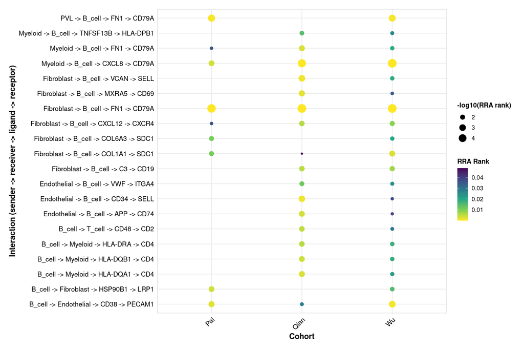

Figure 33: Top conserved LIANA interactions in which B cell cells are sender or receiver.

```r
liana_ct_plots[["B_cell"]]
```

**PVL**

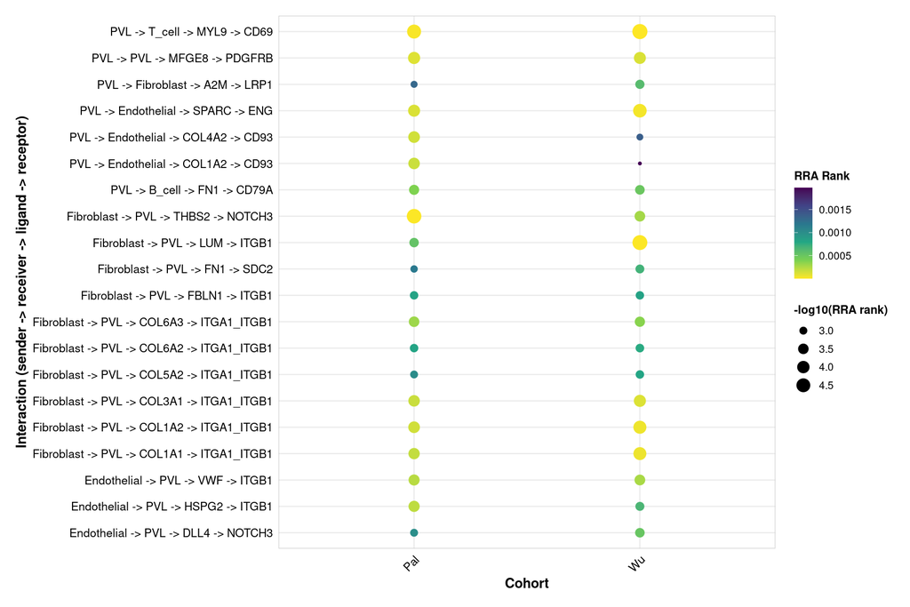

Figure 34: Top conserved LIANA interactions in which PVL cells are sender or receiver.

```r
liana_ct_plots[["PVL"]]
```

**Normal epithelial**

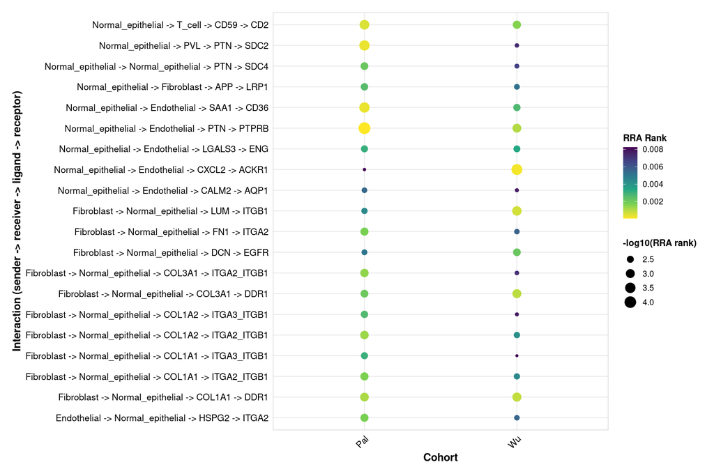

Figure 35: Top conserved LIANA interactions in which Normal epithelial cells are sender or receiver.

```r
liana_ct_plots[["Normal_epithelial"]]
```

**Significant in all three cohorts**

| Source | Target | Ligand | Receptor | Mean_Rank |
| --- | --- | --- | --- | --- |
| Fibroblast | Endothelial | SPARC | ENG | 1.826986430752814e-06 |
| Fibroblast | B_cell | FN1 | CD79A | 3.116495818696797e-06 |
| Fibroblast | Endothelial | COL1A1 | CD93 | 5.065143324276564e-06 |
| Fibroblast | Endothelial | COL1A2 | CD93 | 6.932273132065122e-06 |
| Endothelial | Endothelial | MMRN2 | CLEC14A | 7.429244443535894e-06 |
| Fibroblast | Endothelial | MMP2 | PECAM1 | 1.453781202066428e-05 |
| T_cell | Endothelial | CCL5 | ACKR1 | 2.9591206424444e-05 |
| Endothelial | Endothelial | VWF | SELP | 3.875445966424424e-05 |
| Fibroblast | Endothelial | COL1A2 | CD36 | 4.454299867927187e-05 |
| Fibroblast | Endothelial | COL1A1 | CD36 | 4.890928603803485e-05 |

[output cut: 468 more lines]

**Significant in exactly two cohorts**

| Source | Target | Ligand | Receptor | Cohorts_Present | Mean_Rank |
| --- | --- | --- | --- | --- | --- |
| PVL | T_cell | MYL9 | CD69 | 2 | 9.85200210921707e-06 |
| Fibroblast | Endothelial | COL1A2 | FLT4 | 2 | 5.08068130805012e-05 |
| Fibroblast | Endothelial | COL1A1 | FLT4 | 2 | 6.605447094793027e-05 |
| PVL | Endothelial | SPARC | ENG | 2 | 7.309439701961344e-05 |
| Fibroblast | Myeloid | DCN | TLR2 | 2 | 8.88897335675038e-05 |
| Fibroblast | PVL | COL1A2 | ITGA1_ITGB1 | 2 | 0.0001002353802732149 |
| PVL | PVL | MFGE8 | PDGFRB | 2 | 0.00011192305278692 |
| Fibroblast | PVL | COL1A1 | ITGA1_ITGB1 | 2 | 0.0001223669906949203 |
| Fibroblast | PVL | COL3A1 | ITGA1_ITGB1 | 2 | 0.0001396364864164707 |
| Fibroblast | PVL | THBS2 | NOTCH3 | 2 | 0.0001455450226330708 |

[output cut: 877 more lines]

## Consensus between CellChat and LIANA

We keep an interaction when both frameworks call it conserved, which means it is detected by CellChat and by LIANA in at least two cohorts each. The overlap of the two sets, and of the per-cohort sets within each framework, is shown in Figure 36.

```r
venn_label_size <- 6.5
venn_region_size <- 5.0

cc_summary <- read_csv("results/cross_cohort_comparison/all_interactions_summary.csv", show_col_types = FALSE)
cc_venn_list <- list(
  Pal = cc_summary %>% filter(str_detect(cohorts_list, "Pal")) %>% pull(interaction_key),
  Wu = cc_summary %>% filter(str_detect(cohorts_list, "Wu")) %>% pull(interaction_key),
  Qian = cc_summary %>% filter(str_detect(cohorts_list, "Qian")) %>% pull(interaction_key)
)
p_venn_a <- ggVennDiagram::ggVennDiagram(cc_venn_list, set_color = "black", set_size = venn_label_size, label = "both", label_size = venn_region_size) +
  scale_fill_distiller(palette = "Blues", direction = 1) +
  theme(legend.position = "none")

liana_all_venn <- bind_rows(lapply(c("pal", "wu", "qian"), function(coh) {
  read_csv(sprintf("results/liana/liana_%s_results.csv", coh), show_col_types = FALSE) %>%
    mutate(cohort = str_to_title(coh)) %>%
    rename(ligand = ligand.complex, receptor = receptor.complex)
})) %>%
  filter(aggregate_rank <= 0.05) %>%
  mutate(interaction_key = paste(source, target, ligand, receptor, sep = " -> "))
liana_venn_list <- lapply(c(Pal = "Pal", Wu = "Wu", Qian = "Qian"), function(coh) unique(liana_all_venn$interaction_key[liana_all_venn$cohort == coh]))
p_venn_b <- ggVennDiagram::ggVennDiagram(liana_venn_list, set_color = "black", set_size = venn_label_size, label = "both", label_size = venn_region_size) +
  scale_fill_distiller(palette = "Reds", direction = 1) +
  theme(legend.position = "none")

liana_prep_venn <- liana_all %>% filter(cohort_count >= 2, mean_aggregate_rank <= 0.05) %>%
  mutate(interaction_key = paste(source, target, ligand, receptor, sep = " -> "))
method_list <- list(
  CellChat = unique(as.character(cc_2_of_3 %>% mutate(interaction_key = paste(source, target, ligand, receptor, sep = " -> ")) %>% pull(interaction_key))),
  LIANA = unique(as.character(liana_prep_venn$interaction_key))
)
p_venn_c <- ggVennDiagram::ggVennDiagram(method_list, set_color = "black", set_size = 0, label = "both", label_size = venn_region_size)
# Remove the digit-alignment padding in the count text, which pushes the numbers off center
p_venn_c$layers[[4]]$data$count <- trimws(p_venn_c$layers[[4]]$data$count)
p_venn_c$layers[[4]]$data$both <- trimws(p_venn_c$layers[[4]]$data$both)
# Fill regions by id instead of count, for solid categorical colors
p_venn_c$layers[[1]]$mapping <- aes(fill = id, group = id)
p_venn_c <- p_venn_c +
  scale_fill_manual(values = c("1" = "#6BAED6", "2" = "#FC9272", "1/2" = "#C4A4D6")) +
  annotate("text", x = 0, y = -4.8, label = "CellChat", size = venn_label_size, fontface = "bold", color = "#3182BD") +
  annotate("text", x = 0, y = 8.8, label = "LIANA", size = venn_label_size, fontface = "bold", color = "#DE2D26") +
  scale_x_continuous(expand = expansion(mult = 0.25)) +
  scale_y_continuous(expand = expansion(mult = 0.25)) +
  theme(legend.position = "none")

venn_files <- list(
  list(p = p_venn_a, paths = c("figures/cellchat_venn.png", "figures/venn_A_cellchat.png", "results/cross_cohort_comparison/cellchat_venn.png")),
  list(p = p_venn_b, paths = c("figures/liana_venn.png", "figures/venn_B_liana.png", "results/cross_cohort_comparison/liana_venn.png")),
  list(p = p_venn_c, paths = c("figures/cellchat_liana_intersection_venn.png", "figures/venn_C_method_overlap.png", "results/cross_cohort_comparison/cellchat_liana_intersection_venn.png"))
)
for (v in venn_files) for (path in v$paths) ggsave(path, plot = v$p, width = 6, height = 6, dpi = 300, bg = "white")
```

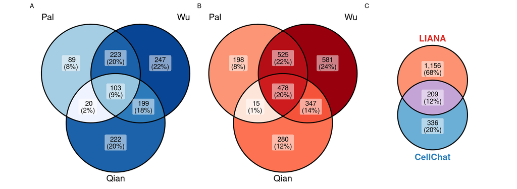

Figure 36: Conservation of ligand-receptor interactions across cohorts and methods. A, significant CellChat pairs in the three discovery cohorts. B, significant LIANA pairs (aggregate rank at most 0.05). C, overlap of the CellChat and LIANA sets that are conserved in at least two cohorts. The intersection in C is the consensus set.

```r
(p_venn_a + p_venn_b + p_venn_c) + plot_annotation(tag_levels = "A")
```

For each interaction in the consensus set, we compute three scores between 0 and 1 and average them with equal weights into a composite priority score.

- The **conservation score** is the number of cohorts in which CellChat detects the interaction plus the number in which LIANA does, divided by 6.
- The **agreement score** is based on the ranks of the interaction in the two methods, CellChat by communication probability and LIANA by aggregate rank. We average the two ranks and rescale the average to the unit interval, so that interactions ranked high by both methods score close to 1.
- The **druggability score** is 1 if any receptor subunit is a target in the Therapeutic Target Database (TTD) and 0 otherwise. We split multi-subunit receptors, such as `ITGA5_ITGB1`, before matching, and we treat the score as a translational annotation. It does not change which axes rise to the top, as shown below.

| Source | Target | Ligand | Receptor | Pathway | Annotation | Cons_Score | Agree_Score | Therap_Score | Priority | Rationale |
| --- | --- | --- | --- | --- | --- | --- | --- | --- | --- | --- |
| Fibroblast | Myeloid | COL1A1 | CD44 | COLLAGEN | ECM-Receptor | 1 | 0.9591346153846154 | 1 | 0.9863782051282052 | Conserved in 3/3 cohorts by CellChat and LIANA, highly ranked by both methods, mediating COLLAGEN signaling (ECM-Receptor), and targets Extracellular matrix receptor III (CD44) (Clinical trial target)… |
| Fibroblast | Myeloid | COL1A2 | CD44 | COLLAGEN | ECM-Receptor | 1 | 0.9543269230769232 | 1 | 0.9847756410256412 | Conserved in 3/3 cohorts by CellChat and LIANA, highly ranked by both methods, mediating COLLAGEN signaling (ECM-Receptor), and targets Extracellular matrix receptor III (CD44) (Clinical trial target)… |
| Fibroblast | T_cell | COL1A1 | CD44 | COLLAGEN | ECM-Receptor | 1 | 0.9447115384615384 | 1 | 0.9815705128205128 | Conserved in 3/3 cohorts by CellChat and LIANA, highly ranked by both methods, mediating COLLAGEN signaling (ECM-Receptor), and targets Extracellular matrix receptor III (CD44) (Clinical trial target)… |
| Fibroblast | T_cell | COL1A2 | CD44 | COLLAGEN | ECM-Receptor | 1 | 0.9375 | 1 | 0.9791666666666666 | Conserved in 3/3 cohorts by CellChat and LIANA, highly ranked by both methods, mediating COLLAGEN signaling (ECM-Receptor), and targets Extracellular matrix receptor III (CD44) (Clinical trial target)… |
| T_cell | Endothelial | CCL5 | ACKR1 | CCL | Secreted Signaling | 1 | 0.935096153846154 | 1 | 0.9783653846153846 | Conserved in 3/3 cohorts by CellChat and LIANA, highly ranked by both methods, mediating CCL signaling (Secreted Signaling), and targets Duffy antigen chemokine receptor (ACKR1) (Successful target). |
| Endothelial | Myeloid | APP | CD74 | APP | Cell-Cell Contact | 1 | 0.9302884615384616 | 1 | 0.9767628205128206 | Conserved in 3/3 cohorts by CellChat and LIANA, highly ranked by both methods, mediating APP signaling (Cell-Cell Contact), and targets HLA-DR antigens-associated invariant (CD74) (Clinical trial targ… |
| Fibroblast | T_cell | CXCL12 | CXCR4 | CXCL | Secreted Signaling | 1 | 0.8918269230769231 | 1 | 0.9639423076923078 | Conserved in 3/3 cohorts by CellChat and LIANA, highly ranked by both methods, mediating CXCL signaling (Secreted Signaling), and targets C-X-C chemokine receptor type 4 (CXCR4) (Successful target). |
| Fibroblast | Myeloid | COL6A2 | CD44 | COLLAGEN | ECM-Receptor | 1 | 0.8870192307692307 | 1 | 0.9623397435897436 | Conserved in 3/3 cohorts by CellChat and LIANA, highly ranked by both methods, mediating COLLAGEN signaling (ECM-Receptor), and targets Extracellular matrix receptor III (CD44) (Clinical trial target)… |
| Fibroblast | Myeloid | COL6A1 | CD44 | COLLAGEN | ECM-Receptor | 1 | 0.8870192307692307 | 1 | 0.9623397435897436 | Conserved in 3/3 cohorts by CellChat and LIANA, highly ranked by both methods, mediating COLLAGEN signaling (ECM-Receptor), and targets Extracellular matrix receptor III (CD44) (Clinical trial target)… |
| Fibroblast | Myeloid | COL6A3 | CD44 | COLLAGEN | ECM-Receptor | 1 | 0.8677884615384616 | 1 | 0.9559294871794872 | Conserved in 3/3 cohorts by CellChat and LIANA, highly ranked by both methods, mediating COLLAGEN signaling (ECM-Receptor), and targets Extracellular matrix receptor III (CD44) (Clinical trial target)… |

[output cut: 199 more lines]

The consensus set has 209 interactions. Their most frequent signaling themes are collagen and other extracellular matrix pathways, MHC-II antigen presentation, and chemokine and growth-factor signaling (Table 5).

```r
# Summarize dominant signaling themes across all consensus interactions
dominant_themes <- merged_annotated %>%
  dplyr::group_by(pathway_name, annotation) %>%
  dplyr::summarise(
    interaction_count = dplyr::n(),
    mean_priority = mean(composite_priority_score, na.rm = TRUE),
    .groups = "drop"
  ) %>%
  dplyr::arrange(desc(interaction_count), desc(mean_priority))

# View the themes for the written summary
knitr::kable(dominant_themes, caption = "Top Conserved Signaling Themes Across Consensus Interactions")
```

Table 5: Signaling themes in the consensus set.

Top Conserved Signaling Themes Across Consensus Interactions

| pathway_name | annotation | interaction_count | mean_priority |
| --- | --- | --- | --- |
| COLLAGEN | ECM-Receptor | 61 | 0.8137304 |
| LAMININ | ECM-Receptor | 30 | 0.6642139 |
| MHC-II | Cell-Cell Contact | 20 | 0.7696648 |
| MHC-I | Cell-Cell Contact | 17 | 0.4315375 |
| THBS | ECM-Receptor | 12 | 0.5836116 |
| MK | Secreted Signaling | 11 | 0.7397654 |
| PTN | Secreted Signaling | 10 | 0.6910524 |
| SPP1 | Secreted Signaling | 6 | 0.7597044 |
| FN1 | ECM-Receptor | 5 | 0.8994124 |
| CXCL | Secreted Signaling | 5 | 0.8567842 |
| VISFATIN | Secreted Signaling | 4 | 0.6970486 |
| APP | Cell-Cell Contact | 3 | 0.9054487 |
| CCL | Secreted Signaling | 3 | 0.8737536 |
| NOTCH | Cell-Cell Contact | 3 | 0.7586360 |
| GALECTIN | Secreted Signaling | 3 | 0.7366898 |
| PDGF | Secreted Signaling | 3 | 0.6557158 |
| CD99 | Cell-Cell Contact | 3 | 0.3418803 |
| MIF | Secreted Signaling | 2 | 0.8514957 |
| THY1 | Cell-Cell Contact | 1 | 0.8386752 |
| PERIOSTIN | Secreted Signaling | 1 | 0.8050214 |
| JAM | Cell-Cell Contact | 1 | 0.7104701 |
| PARs | Secreted Signaling | 1 | 0.6984509 |
| COMPLEMENT | Secreted Signaling | 1 | 0.6621261 |
| ANGPTL | Secreted Signaling | 1 | 0.6567842 |
| ICAM | Cell-Cell Contact | 1 | 0.6348825 |
| ANNEXIN | Secreted Signaling | 1 | 0.6132479 |

The top 30 interactions by composite score are listed in Table 6 and ranked in Figure 37.

```r
top_candidates <- merged_annotated %>%
  dplyr::arrange(desc(composite_priority_score)) %>%
  head(30) %>%
  dplyr::select(
    source, target, ligand, receptor, pathway_name, annotation, composite_priority_score)

knitr::kable(top_candidates, caption = "Top 30 Consensus Ligand-Receptor Interactions Prioritized by Composite Score")
```

Table 6: Top 30 consensus interactions by composite priority score.

Top 30 Consensus Ligand-Receptor Interactions Prioritized by Composite Score

| source | target | ligand | receptor | pathway_name | annotation | composite_priority_score |
| --- | --- | --- | --- | --- | --- | --- |
| Fibroblast | Myeloid | COL1A1 | CD44 | COLLAGEN | ECM-Receptor | 0.9863782 |
| Fibroblast | Myeloid | COL1A2 | CD44 | COLLAGEN | ECM-Receptor | 0.9847756 |
| Fibroblast | T_cell | COL1A1 | CD44 | COLLAGEN | ECM-Receptor | 0.9815705 |
| Fibroblast | T_cell | COL1A2 | CD44 | COLLAGEN | ECM-Receptor | 0.9791667 |
| T_cell | Endothelial | CCL5 | ACKR1 | CCL | Secreted Signaling | 0.9783654 |
| Endothelial | Myeloid | APP | CD74 | APP | Cell-Cell Contact | 0.9767628 |
| Fibroblast | T_cell | CXCL12 | CXCR4 | CXCL | Secreted Signaling | 0.9639423 |
| Fibroblast | Myeloid | COL6A2 | CD44 | COLLAGEN | ECM-Receptor | 0.9623397 |
| Fibroblast | Myeloid | COL6A1 | CD44 | COLLAGEN | ECM-Receptor | 0.9623397 |
| Fibroblast | Myeloid | COL6A3 | CD44 | COLLAGEN | ECM-Receptor | 0.9559295 |
| Fibroblast | T_cell | COL6A1 | CD44 | COLLAGEN | ECM-Receptor | 0.9479167 |
| Fibroblast | Fibroblast | MDK | LRP1 | MK | Secreted Signaling | 0.9463141 |
| Fibroblast | T_cell | COL6A2 | CD44 | COLLAGEN | ECM-Receptor | 0.9407051 |
| Fibroblast | T_cell | COL6A3 | CD44 | COLLAGEN | ECM-Receptor | 0.9391026 |
| Fibroblast | Endothelial | FN1 | ITGA5_ITGB1 | FN1 | ECM-Receptor | 0.9294872 |
| Fibroblast | Myeloid | FN1 | CD44 | FN1 | ECM-Receptor | 0.9270833 |
| Fibroblast | Fibroblast | COL1A1 | SDC1 | COLLAGEN | ECM-Receptor | 0.9131944 |
| Fibroblast | Fibroblast | COL1A2 | SDC1 | COLLAGEN | ECM-Receptor | 0.9131944 |
| Fibroblast | T_cell | FN1 | CD44 | FN1 | ECM-Receptor | 0.9086538 |
| Fibroblast | B_cell | CXCL12 | CXCR4 | CXCL | Secreted Signaling | 0.8974359 |
| Myeloid | Myeloid | HLA-DRA | CD4 | MHC-II | Cell-Cell Contact | 0.8915598 |
| Endothelial | B_cell | APP | CD74 | APP | Cell-Cell Contact | 0.8883547 |
| Myeloid | Endothelial | CXCL8 | ACKR1 | CXCL | Secreted Signaling | 0.8878205 |
| Fibroblast | PVL | COL1A1 | ITGA1_ITGB1 | COLLAGEN | ECM-Receptor | 0.8800748 |
| Fibroblast | PVL | COL1A2 | ITGA1_ITGB1 | COLLAGEN | ECM-Receptor | 0.8800748 |
| Fibroblast | Fibroblast | FN1 | SDC1 | FN1 | ECM-Receptor | 0.8795406 |
| Fibroblast | Fibroblast | COL6A2 | SDC1 | COLLAGEN | ECM-Receptor | 0.8787393 |
| Endothelial | Myeloid | COL4A1 | CD44 | COLLAGEN | ECM-Receptor | 0.8766026 |
| Myeloid | Myeloid | HLA-DRB1 | CD4 | MHC-II | Cell-Cell Contact | 0.8755342 |
| Fibroblast | Fibroblast | COL6A3 | SDC1 | COLLAGEN | ECM-Receptor | 0.8715278 |

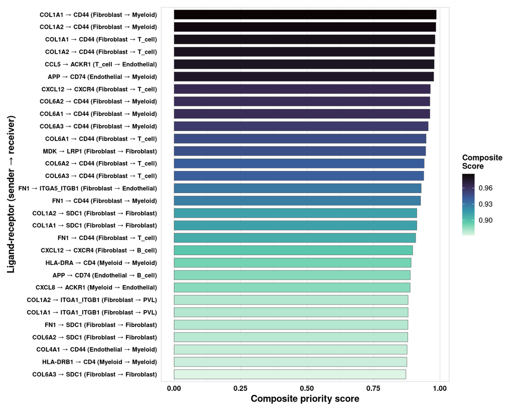

Figure 37: The 30 consensus interactions with the highest composite priority score.

```r
# Bar plot of the top interactions by composite score
top_candidates$interaction_label <- paste0(
  top_candidates$ligand, " \u2192 ", top_candidates$receptor,
  " (", top_candidates$source, " \u2192 ", top_candidates$target, ")"
)

p_top30 <- ggplot(top_candidates, aes(x = reorder(interaction_label, composite_priority_score), y = composite_priority_score, fill = composite_priority_score)) +
  geom_col(width = 0.75, color = "grey30", linewidth = 0.2) +
  coord_flip() +
  scale_fill_viridis_c(option = "mako", direction = -1, name = "Composite\nScore") +
  labs(
    x = "Ligand-receptor (sender \u2192 receiver)",
    y = "Composite priority score"
  ) +
  theme_publication() +
  theme(
    axis.text.y = element_text(size = 8.5, face = "bold"),
    axis.text.x = element_text(size = 10, face = "bold"),
    panel.grid.major.y = element_blank(),
    plot.margin = margin(t = 10, r = 10, b = 10, l = 10)
  )

ggsave("results/cross_cohort_comparison/top_30_priority_barplot.png", plot = p_top30, width = 10, height = 8, dpi = 300)
p_top30
```

The top 30 fall into three groups.

**Stromal matrix remodeling.** Cancer-associated fibroblasts are the main senders of collagens and fibronectin. Their receptors include syndecan-1 (SDC1) on other fibroblasts, integrin α1β1 (`ITGA1_ITGB1`) on perivascular cells, and integrin α5β1 (`ITGA5_ITGB1`) on endothelial cells. The collagen pathway alone contributes 61 interactions with a mean priority of 0.81.

**Chemokine signaling at the endothelium and in T cells.** Endothelial ACKR1 receives CCL5 from T cells and CXCL8 from myeloid cells. ACKR1 is an atypical receptor that transports chemokines across the endothelium without signaling through G proteins. Fibroblast-derived CXCL12 reaches CXCR4 on T and B cells.

**Antigen presentation and related immune interfaces.** Myeloid MHC-II molecules pair with CD4, endothelial COL4A1 pairs with CD44 on myeloid cells, and endothelial APP pairs with CD74 on B and myeloid cells.

The consensus set is a list of candidates for follow-up, not a list of validated mechanisms.

## Prioritization and the adhesion-receptor rule

The top of the list is dominated by collagen and fibronectin pairs that bind CD44 or syndecan-1. Promiscuous matrix receptors of this kind recur across many ligands and sender types, and they mostly describe the desmoplastic stroma in general. We are interested in receptor-specific axes, so we apply a filter to every interaction before ranking. The filter is a rule, written down after the original curation, which it formalizes. It does not depend on where any single interaction ranks, and the variants below show how much the selection depends on it:

> An interaction is excluded if its receptor is a single-chain receptor (not a multi-subunit complex in CellChatDB) that binds at least 10 distinct ligands through extracellular-matrix-receptor interactions in CellChatDB.

The rule flags CD44, SDC1, SDC4, GP6, DAG1 and SV2A/B/C. The next single-chain matrix receptors, CD36 and CD47, bind 5 ligands each, so the threshold sits at a clear gap. Integrin α5β1 is a heterodimer with one matrix ligand in CellChatDB and passes. After the rule, the five axes in the table below rank first to fifth. For APP-CD74 the highest-ranked instance has myeloid receivers; the downstream single-cell and spatial analyses use its endothelial-to-B-cell instance, which is also in the consensus set (eighth after the rule), and the comparison with normal tissue shows both.

```r
# Candidate Registry Definition
candidate_registry <- tibble::tribble(
  ~axis_id, ~ligand, ~receptor, ~sender_celltype, ~receiver_celltype,
  "cxcl12_cxcr4", "CXCL12", "CXCR4", "Fibroblast", "T_cell",
  "ccl5_ackr1", "CCL5", "ACKR1", "T_cell", "Endothelial",
  "mdk_lrp1", "MDK", "LRP1", "Fibroblast", "Fibroblast",
  "fn1_itga5_itgb1", "FN1", "ITGA5_ITGB1", "Fibroblast", "Endothelial",
  "app_cd74", "APP", "CD74", "Endothelial", "B_cell"
)

knitr::kable(
  candidate_registry %>% dplyr::select(ligand, receptor, sender_celltype, receiver_celltype),
  digits = 4,
  caption = "The five candidate axes carried into the downstream analyses, with the sender and receiver used downstream."
)
```

The five candidate axes carried into the downstream analyses, with the sender and receiver used downstream.

| ligand | receptor | sender_celltype | receiver_celltype |
| --- | --- | --- | --- |
| CXCL12 | CXCR4 | Fibroblast | T_cell |
| CCL5 | ACKR1 | T_cell | Endothelial |
| MDK | LRP1 | Fibroblast | Fibroblast |
| FN1 | ITGA5_ITGB1 | Fibroblast | Endothelial |
| APP | CD74 | Endothelial | B_cell |

```r
cons <- read_csv("results/cross_cohort_comparison/consensus_interactions_all.csv", show_col_types = FALSE)
db_int <- CellChat::CellChatDB.human$interaction
db_cx <- CellChat::CellChatDB.human$complex

receptor_props <- db_int %>%
  group_by(receptor) %>%
  summarise(
    n_ligands = n_distinct(ligand),
    n_ecm_ligands = n_distinct(ligand[annotation == "ECM-Receptor"]),
    .groups = "drop"
  ) %>%
  mutate(is_complex = receptor %in% rownames(db_cx))
receptor_subunits <- lapply(setNames(receptor_props$receptor, receptor_props$receptor), function(r) {
  if (r %in% rownames(db_cx)) {
    s <- unlist(db_cx[r, grep("^subunit", colnames(db_cx))])
    s[s != ""]
  } else {
    r
  }
})

fails_rule <- function(threshold, include_complexes = FALSE) {
  receptor_props$receptor[receptor_props$n_ecm_ligands >= threshold & (include_complexes | !receptor_props$is_complex)]
}
failing_main <- fails_rule(10)
failing_t5 <- fails_rule(5)
failing_complex <- fails_rule(10, include_complexes = TRUE)
failing_subunits <- unique(unlist(receptor_subunits[failing_complex]))
failing_subunit_level <- receptor_props$receptor[vapply(receptor_props$receptor, function(r) any(receptor_subunits[[r]] %in% failing_subunits), logical(1))]

prio <- cons %>%
  mutate(
    score_no_drug = (Cons_Score + Agree_Score) / 2,
    rank_uncurated = rank(-Priority, ties.method = "min"),
    rank_uncurated_no_drug = rank(-score_no_drug, ties.method = "min"),
    pass_main = !Receptor %in% failing_main,
    pass_t5 = !Receptor %in% failing_t5,
    pass_complex = !Receptor %in% failing_complex,
    pass_subunit = !Receptor %in% failing_subunit_level
  )
rank_within <- function(score, pass) {
  out <- rep(NA_integer_, length(score))
  out[pass] <- rank(-score[pass], ties.method = "min")
  out
}
prio <- prio %>%
  mutate(
    rank_rule = rank_within(Priority, pass_main),
    rank_rule_no_drug = rank_within(score_no_drug, pass_main),
    rank_rule_t5 = rank_within(Priority, pass_t5),
    rank_rule_complex = rank_within(Priority, pass_complex),
    rank_rule_subunit = rank_within(Priority, pass_subunit)
  )
write_csv(prio, "results/revision/prioritisation_all_interactions.csv")

axis_keys <- candidate_registry %>%
  transmute(axis_id, Source = sender_celltype, Target = ifelse(axis_id == "app_cd74", "Myeloid", receiver_celltype), Ligand = ligand, Receptor = receptor)
axis_ranks <- axis_keys %>%
  left_join(prio, by = c("Source", "Target", "Ligand", "Receptor")) %>%
  transmute(
    Axis = axis_labels[axis_id], Source, Target, Priority = round(Priority, 3), `Score without druggability` = round(score_no_drug, 3),
    `Rank (uncurated)` = rank_uncurated, `Rank (uncurated, no druggability)` = rank_uncurated_no_drug,
    `Rank (rule)` = rank_rule, `Rank (rule, no druggability)` = rank_rule_no_drug,
    `Rank (threshold 5)` = rank_rule_t5, `Rank (rule incl. complexes)` = rank_rule_complex, `Rank (subunit-level)` = rank_rule_subunit
  )
write_csv(axis_ranks, "results/revision/prioritisation_axis_ranks.csv")
knitr::kable(axis_ranks, caption = sprintf("Rank of the five axes among the %d consensus interactions, with and without druggability and under the adhesion-receptor rule and its variants", nrow(prio)))
```

Rank of the five axes among the 209 consensus interactions, with and without druggability and under the adhesion-receptor rule and its variants

| Axis | Source | Target | Priority | Score without druggability | Rank (uncurated) | Rank (uncurated, no druggability) | Rank (rule) | Rank (rule, no druggability) | Rank (threshold 5) | Rank (rule incl. complexes) | Rank (subunit-level) |
| --- | --- | --- | --- | --- | --- | --- | --- | --- | --- | --- | --- |
| CXCL12-CXCR4 | Fibroblast | T_cell | 0.964 | 0.946 | 7 | 7 | 3 | 3 | 3 | 3 | 3 |
| CCL5-ACKR1 | T_cell | Endothelial | 0.978 | 0.968 | 5 | 5 | 1 | 1 | 1 | 1 | 1 |
| MDK-LRP1 | Fibroblast | Fibroblast | 0.946 | 0.919 | 12 | 12 | 4 | 4 | 4 | 4 | 4 |
| FN1-ITGA5/ITGB1 | Fibroblast | Endothelial | 0.929 | 0.894 | 15 | 15 | 5 | 5 | 5 | 5 | NA |
| APP-CD74 | Endothelial | Myeloid | 0.977 | 0.965 | 6 | 6 | 2 | 2 | 2 | 2 | 2 |

```r
rule_summary <- tibble::tribble(
  ~Variant, ~`Failing receptors in CellChatDB`, ~`Interactions removed`, ~`Lead receptors failing`,
  "Main rule (single-chain, >= 10 ECM ligands)", paste(sort(failing_main), collapse = ", "), sum(!prio$pass_main), paste(intersect(candidate_registry$receptor, failing_main), collapse = ", "),
  "Threshold 5", paste(sort(failing_t5), collapse = ", "), sum(!prio$pass_t5), paste(intersect(candidate_registry$receptor, failing_t5), collapse = ", "),
  "Rule extended to complexes", paste(sort(intersect(failing_complex, prio$Receptor)), collapse = ", "), sum(!prio$pass_complex), paste(intersect(candidate_registry$receptor, failing_complex), collapse = ", "),
  "Subunit-level", paste(sort(intersect(failing_subunit_level, prio$Receptor)), collapse = ", "), sum(!prio$pass_subunit), paste(intersect(candidate_registry$receptor, failing_subunit_level), collapse = ", ")
)
write_csv(rule_summary, "results/revision/prioritisation_rule_summary.csv")
knitr::kable(rule_summary, caption = "Adhesion-receptor rule and sensitivity variants")
```

Adhesion-receptor rule and sensitivity variants

| Variant | Failing receptors in CellChatDB | Interactions removed | Lead receptors failing |
| --- | --- | --- | --- |
| Main rule (single-chain, >= 10 ECM ligands) | CD44, DAG1, GP6, SDC1, SDC4, SV2A, SV2B, SV2C | 84 |  |
| Threshold 5 | CD36, CD44, CD47, DAG1, GP6, SDC1, SDC4, SV2A, SV2B, SV2C | 91 |  |
| Rule extended to complexes | CD44, ITGA1_ITGB1, ITGA6_ITGB1, SDC1, SDC4 | 108 |  |
| Subunit-level | CD44, ITGA1_ITGB1, ITGA5_ITGB1, ITGA6_ITGB1, ITGAV_ITGB1, ITGAV_ITGB5, SDC1, SDC4 | 117 | ITGA5_ITGB1 |

```r
knitr::kable(
  tibble::tibble(
    `Druggable interactions` = sum(prio$Therap_Score == 1),
    `Druggable in top 30` = sum(head(prio$Therap_Score[order(-prio$Priority)], 30) == 1),
    `Spearman rho, score with vs without druggability` = round(cor(prio$Priority, prio$score_no_drug, method = "spearman"), 3)
  ),
  caption = "Druggability term in the composite score"
)
```

Druggability term in the composite score

| Druggable interactions | Druggable in top 30 | Spearman rho, score with vs without druggability |
| --- | --- | --- |
| 184 | 30 | 0.821 |

```r
knitr::kable(
  prio %>% filter(pass_main) %>% arrange(rank_rule) %>% head(15) %>%
    select(rank_rule, rank_uncurated, rank_rule_no_drug, Source, Target, Ligand, Receptor, Pathway, Priority, score_no_drug),
  digits = 3,
  caption = "Top 15 interactions after the adhesion-receptor rule"
)
```

Top 15 interactions after the adhesion-receptor rule

| rank_rule | rank_uncurated | rank_rule_no_drug | Source | Target | Ligand | Receptor | Pathway | Priority | score_no_drug |
| --- | --- | --- | --- | --- | --- | --- | --- | --- | --- |
| 1 | 5 | 1 | T_cell | Endothelial | CCL5 | ACKR1 | CCL | 0.978 | 0.968 |
| 2 | 6 | 2 | Endothelial | Myeloid | APP | CD74 | APP | 0.977 | 0.965 |
| 3 | 7 | 3 | Fibroblast | T_cell | CXCL12 | CXCR4 | CXCL | 0.964 | 0.946 |
| 4 | 12 | 4 | Fibroblast | Fibroblast | MDK | LRP1 | MK | 0.946 | 0.919 |
| 5 | 15 | 5 | Fibroblast | Endothelial | FN1 | ITGA5_ITGB1 | FN1 | 0.929 | 0.894 |
| 6 | 20 | 6 | Fibroblast | B_cell | CXCL12 | CXCR4 | CXCL | 0.897 | 0.846 |
| 7 | 21 | 7 | Myeloid | Myeloid | HLA-DRA | CD4 | MHC-II | 0.892 | 0.837 |
| 8 | 22 | 8 | Endothelial | B_cell | APP | CD74 | APP | 0.888 | 0.833 |
| 9 | 23 | 9 | Myeloid | Endothelial | CXCL8 | ACKR1 | CXCL | 0.888 | 0.832 |
| 10 | 24 | 10 | Fibroblast | PVL | COL1A1 | ITGA1_ITGB1 | COLLAGEN | 0.880 | 0.820 |
| 10 | 24 | 10 | Fibroblast | PVL | COL1A2 | ITGA1_ITGB1 | COLLAGEN | 0.880 | 0.820 |
| 12 | 29 | 12 | Myeloid | Myeloid | HLA-DRB1 | CD4 | MHC-II | 0.876 | 0.813 |
| 13 | 31 | 13 | Myeloid | Myeloid | HLA-DPA1 | CD4 | MHC-II | 0.869 | 0.804 |
| 14 | 32 | 14 | Fibroblast | PVL | COL6A3 | ITGA1_ITGB1 | COLLAGEN | 0.869 | 0.803 |
| 15 | 34 | 15 | Fibroblast | PVL | COL6A2 | ITGA1_ITGB1 | COLLAGEN | 0.867 | 0.801 |

The druggability term does not drive the ranking. Without it, the five axes keep their ranks (CCL5-ACKR1 5, APP-CD74 6, CXCL12-CXCR4 7, MDK-LRP1 12, FN1-ITGA5/ITGB1 15 of 209), and the Spearman correlation between the scores with and without the term is 0.82. Before the rule is applied, the five axes occupy ranks 5 to 15, which is already near the top of 209. After it, they take ranks 1 to 5, with CCL5-ACKR1 first, APP-CD74 second, CXCL12-CXCR4 third, MDK-LRP1 fourth and FN1-ITGA5/ITGB1 fifth. A lower threshold (5 ligands), extending the rule to multi-subunit receptors, and the subunit-level variant do not change the order of the first four, and the first two variants also keep FN1-ITGA5/ITGB1 fifth. Under the subunit-level variant `ITGA5_ITGB1` fails through `ITGB1`, a promiscuous β subunit that it shares with the α1β1 and α6β1 integrins. We keep the axis, because the rule is applied to the functional heterodimer.

The five axes are the five carried into the rest of the analysis. All five are conserved in all three cohorts and are found by both frameworks.

## Robustness to subsampling

Every cohort is subsampled to 20,000 cells, which corresponds to 12% of the Pal cells, 26% of the Wu cells and 66% of the Qian cells, so the retention fraction differs between cohorts. We checked that the consensus set and the axis ranks do not depend on this choice or on the random seed. We re-sketched each cohort from the full harmonized object with the same leverage-score procedure and four configurations, with seeds 1 to 3 each: a common retention fraction of 25% (Pal 40,144, Wu 19,420 and Qian 7,540 cells), a fixed 10,000 cells, a fixed 30,000 cells (Qian is then essentially complete, with 30,000 of its 30,161 cells), and the original 20,000 cells with new seeds. This gives 12 runs per cohort. CellChat and LIANA were rerun with the original settings in each, and the conserved and consensus sets and the composite score were rebuilt as before. Rerunning the seed-123 sketch reproduces the original sketch exactly, as well as the per-cohort CellChat and LIANA results, so the pipeline is deterministic, and all variation below comes from subsampling.

```r
suppressMessages({
  library(dplyr)
  library(qs2)
  library(Seurat)
  library(CellChat)
  library(liana)
  library(SingleCellExperiment)
})

n_workers <- min(num_cores, 6)
out_dir <- "objects/revision/resketch"
dir.create(out_dir, recursive = TRUE, showWarnings = FALSE)

cohorts <- c("pal", "wu", "qian")
seeds <- c(1, 2, 3)

run_cellchat_lr <- function(data_input, meta) {
  cellchat <- createCellChat(object = data_input, meta = meta, group.by = "harmonized_label")
  cellchat@DB <- CellChatDB.human
  cellchat <- subsetData(cellchat)
  cellchat <- identifyOverExpressedGenes(cellchat)
  cellchat <- identifyOverExpressedInteractions(cellchat)
  cellchat <- computeCommunProb(cellchat, raw.use = TRUE)
  cellchat <- filterCommunication(cellchat, min.cells = 10)
  subsetCommunication(cellchat)
}

run_liana_agg <- function(counts, data_input, meta) {
  sce <- SingleCellExperiment(
    assays = list(counts = counts, logcounts = data_input),
    colData = meta
  )
  liana_res <- liana_wrap(
    sce,
    method = c("natmi", "connectome", "logfc", "sca", "cellphonedb"),
    idents_col = "harmonized_label",
    expr_prop = 0.1,
    min_cells = 10,
    permutation.params = list(nperms = 1000)
  )
  liana_aggregate(liana_res)
}

for (cohort in cohorts) {
  message(sprintf("[%s] %s: loading harmonized object", Sys.time(), cohort))
  seu <- qs_read(sprintf("objects/seu_%s_harmonized_20000.qs2", cohort))
  DefaultAssay(seu) <- "RNA"
  n_total <- ncol(seu)
  orig_cells <- colnames(seu[["sketch"]])

  # Leverage scores are recomputed per seed, as SketchData() does internally
  cells_path <- file.path(out_dir, sprintf("sketch_cells_%s.qs2", cohort))
  if (file.exists(cells_path)) {
    sketch_cells <- qs_read(cells_path)
  } else {
    sizes <- c(
      frac25 = round(0.25 * n_total),
      n10k = 10000,
      n20k = 20000,
      n30k = min(30000, n_total)
    )
    sketch_cells <- list()
    for (s in c(123, seeds)) {
      lev_name <- paste0("lev_s", s)
      seu <- LeverageScore(seu, assay = "RNA", seed = s, var.name = lev_name, over.write = TRUE, verbose = FALSE)
      lev <- seu[[lev_name]][, 1]
      run_sizes <- if (s == 123) c(n20k = 20000) else sizes
      for (cfg in names(run_sizes)) {
        set.seed(s)
        sketch_cells[[sprintf("%s_s%d", cfg, s)]] <- sample(colnames(seu), size = min(run_sizes[[cfg]], n_total), prob = lev)
      }
    }
    qs_save(sketch_cells, cells_path)
  }
  message(sprintf("[%s] %s: original sketch reproduced = %s", Sys.time(), cohort,
                  setequal(sketch_cells[["n20k_s123"]], orig_cells)))

  counts_all <- GetAssayData(seu, assay = "RNA", layer = "counts")
  data_all <- GetAssayData(seu, assay = "RNA", layer = "data")
  meta_all <- seu@meta.data
  rm(seu)
  gc()

  run_ids <- names(sketch_cells)
  todo <- run_ids[!file.exists(file.path(out_dir, sprintf("%s_%s.qs2", cohort, run_ids)))]
  parallel::mclapply(todo, function(run_id) {
    cells <- sketch_cells[[run_id]]
    meta <- meta_all[cells, ]
    data_input <- data_all[, cells]
    t0 <- Sys.time()
    cc_df <- run_cellchat_lr(data_input, meta)
    liana_df <- run_liana_agg(counts_all[, cells], data_input, meta)
    qs_save(
      list(cohort = cohort, run_id = run_id, n_cells = length(cells), cc_df = cc_df, liana_df = liana_df,
           minutes = as.numeric(difftime(Sys.time(), t0, units = "mins"))),
      file.path(out_dir, sprintf("%s_%s.qs2", cohort, run_id))
    )
    message(sprintf("[%s] %s %s done (%d cells)", Sys.time(), cohort, run_id, length(cells)))
    NULL
  }, mc.cores = n_workers, mc.preschedule = FALSE)

  rm(counts_all, data_all, meta_all)
  gc()
}
message(sprintf("[%s] all re-sketch runs finished", Sys.time()))
```

The next step rebuilds the conserved and consensus sets for every run and compares them with the sets from the reference sketch (20,000 cells, seed 123) with the Jaccard index. It also records where each of the five axes ranks in every run, both before and after the adhesion-receptor rule.

```r
rs_files <- list.files("objects/revision/resketch", pattern = "^(pal|wu|qian)_.*\\.qs2$", full.names = TRUE)
rs_runs <- lapply(rs_files, qs_read)
rs_index <- tibble::tibble(
  cohort = vapply(rs_runs, `[[`, character(1), "cohort"),
  run_id = vapply(rs_runs, `[[`, character(1), "run_id"),
  n_cells = vapply(rs_runs, `[[`, numeric(1), "n_cells"),
  minutes = vapply(rs_runs, `[[`, numeric(1), "minutes")
)
complete_runs <- rs_index %>% count(run_id) %>% filter(n == 3) %>% pull(run_id)

# TTD gene symbols parsed as in consensus-validation-calculations
ttd_lines <- readLines("data/ext/P2-01-TTD_uniprot_all.txt")
ttd_fields <- lapply(c("^TARGETID", "^UNIPROID", "^TARGNAME", "^TARGTYPE"), function(tag) ttd_lines[grep(tag, ttd_lines)])
ttd_n <- min(lengths(ttd_fields))
ttd_symbols <- str_match(sub("^TARGNAME\\s+", "", ttd_fields[[3]][1:ttd_n]), "\\(([^\\)]+)\\)$")[, 2]

build_consensus <- function(cc_list, liana_list) {
  cc_cons <- bind_rows(cc_list, .id = "cohort") %>%
    group_by(source, target, ligand, receptor, interaction_name) %>%
    summarise(cc_cohort_count = n_distinct(cohort), cc_mean_prob = mean(prob), .groups = "drop") %>%
    filter(cc_cohort_count >= 2)
  liana_cons <- bind_rows(liana_list, .id = "cohort") %>%
    filter(aggregate_rank <= 0.05) %>%
    rename(ligand = ligand.complex, receptor = receptor.complex) %>%
    group_by(source, target, ligand, receptor) %>%
    summarise(liana_cohort_count = n_distinct(cohort), liana_mean_rank = mean(aggregate_rank), .groups = "drop") %>%
    filter(liana_cohort_count >= 2, liana_mean_rank <= 0.05)
  merged <- inner_join(cc_cons, liana_cons, by = c("source", "target", "ligand", "receptor"))
  avg_rank <- (rank(-merged$cc_mean_prob) + rank(merged$liana_mean_rank)) / 2
  merged %>%
    mutate(
      conservation_score = (cc_cohort_count + liana_cohort_count) / 6,
      agreement_score = 1 - (avg_rank - 1) / (n() - 1),
      therapeutic_score = as.numeric(vapply(strsplit(receptor, "_"), function(s) any(s %in% ttd_symbols), logical(1))),
      composite = (conservation_score + agreement_score + therapeutic_score) / 3,
      rank_uncurated = rank(-composite, ties.method = "min"),
      rank_rule = rank_within(composite, !receptor %in% failing_main),
      key = paste(source, target, ligand, receptor, sep = " -> ")
    ) %>%
    list(cc_keys = paste(cc_cons$source, cc_cons$target, cc_cons$ligand, cc_cons$receptor, sep = " -> "),
         liana_keys = paste(liana_cons$source, liana_cons$target, liana_cons$ligand, liana_cons$receptor, sep = " -> "),
         consensus = .)
}

jaccard <- function(a, b) length(intersect(a, b)) / length(union(a, b))
# "Published" refers to the earlier tables archived in results/revision/published_208_backup/
pub_dir <- "results/revision/published_208_backup"
orig_cc_keys <- read_csv(file.path(pub_dir, "conserved_interactions_2_of_3.csv"), show_col_types = FALSE) %>%
  transmute(key = paste(source, target, ligand, receptor, sep = " -> ")) %>% pull(key)
orig_liana_keys <- read_csv(file.path(pub_dir, "liana_conserved_all.csv"), show_col_types = FALSE) %>%
  filter(cohort_count >= 2, mean_aggregate_rank <= 0.05) %>%
  transmute(key = paste(source, target, ligand, receptor, sep = " -> ")) %>% pull(key)
orig_cons_keys <- read_csv(file.path(pub_dir, "consensus_interactions_all.csv"), show_col_types = FALSE) %>%
  transmute(key = paste(Source, Target, Ligand, Receptor, sep = " -> ")) %>% pull(key)
axis_key_vec <- setNames(paste(axis_keys$Source, axis_keys$Target, axis_keys$Ligand, axis_keys$Receptor, sep = " -> "), axis_keys$axis_id)

# The published LIANA-conserved table predates the final per-cohort LIANA outputs, so each run is also
# compared with the sets rebuilt from the original sketch (n20k_s123), which isolates the subsampling effect
rebuild_run <- function(rid) {
  runs <- rs_runs[rs_index$run_id == rid]
  names(runs) <- vapply(runs, `[[`, character(1), "cohort")
  c(list(runs = runs), build_consensus(lapply(runs, `[[`, "cc_df"), lapply(runs, `[[`, "liana_df")))
}
ref <- rebuild_run("n20k_s123")

rs_rows <- list()
rs_axis_rows <- list()
for (rid in complete_runs) {
  bc <- rebuild_run(rid)
  runs <- bc$runs
  rs_rows[[rid]] <- tibble::tibble(
    run_id = rid, config = sub("_s[0-9]+$", "", rid), seed = as.integer(sub(".*_s", "", rid)),
    cells_pal = runs$pal$n_cells, cells_wu = runs$wu$n_cells, cells_qian = runs$qian$n_cells,
    n_cc_conserved = length(bc$cc_keys), n_liana_conserved = length(bc$liana_keys), n_consensus = nrow(bc$consensus),
    jaccard_cc = jaccard(bc$cc_keys, orig_cc_keys), jaccard_liana = jaccard(bc$liana_keys, orig_liana_keys),
    jaccard_consensus = jaccard(bc$consensus$key, orig_cons_keys),
    jaccard_cc_rebuilt = jaccard(bc$cc_keys, ref$cc_keys), jaccard_liana_rebuilt = jaccard(bc$liana_keys, ref$liana_keys),
    jaccard_consensus_rebuilt = jaccard(bc$consensus$key, ref$consensus$key)
  )
  rs_axis_rows[[rid]] <- tibble::tibble(run_id = rid, axis_id = names(axis_key_vec), key = unname(axis_key_vec)) %>%
    left_join(bc$consensus %>% select(key, composite, rank_uncurated, rank_rule), by = "key") %>%
    mutate(in_consensus = !is.na(rank_uncurated), n_consensus = nrow(bc$consensus))
}
rs_summary <- bind_rows(rs_rows) %>% mutate(config = factor(config, levels = c("n20k", "n10k", "frac25", "n30k"))) %>% arrange(config, seed)
rs_axis <- bind_rows(rs_axis_rows) %>% left_join(rs_summary %>% select(run_id, config, seed), by = "run_id")
write_csv(rs_summary, "results/revision/resketch_runs.csv")
write_csv(rs_axis, "results/revision/resketch_axis_ranks.csv")
knitr::kable(rs_summary, digits = 3, caption = "Re-sketching runs: conserved and consensus set sizes and Jaccard overlap with the original sets (n20k_s123 = original sketch reproduced)")
```

Re-sketching runs: conserved and consensus set sizes and Jaccard overlap with the original sets (n20k_s123 = original sketch reproduced)

| run_id | config | seed | cells_pal | cells_wu | cells_qian | n_cc_conserved | n_liana_conserved | n_consensus | jaccard_cc | jaccard_liana | jaccard_consensus | jaccard_cc_rebuilt | jaccard_liana_rebuilt | jaccard_consensus_rebuilt |
| --- | --- | --- | --- | --- | --- | --- | --- | --- | --- | --- | --- | --- | --- | --- |
| n20k_s1 | n20k | 1 | 20000 | 20000 | 20000 | 545 | 1362 | 203 | 0.964 | 0.893 | 0.957 | 0.964 | 0.904 | 0.953 |
| n20k_s2 | n20k | 2 | 20000 | 20000 | 20000 | 544 | 1323 | 199 | 0.959 | 0.915 | 0.947 | 0.959 | 0.926 | 0.943 |
| n20k_s3 | n20k | 3 | 20000 | 20000 | 20000 | 533 | 1366 | 210 | 0.915 | 0.923 | 0.883 | 0.915 | 0.940 | 0.887 |
| n20k_s123 | n20k | 123 | 20000 | 20000 | 20000 | 545 | 1365 | 209 | 1.000 | 0.973 | 0.986 | 1.000 | 1.000 | 1.000 |
| n10k_s1 | n10k | 1 | 10000 | 10000 | 10000 | 536 | 1377 | 206 | 0.896 | 0.884 | 0.882 | 0.896 | 0.896 | 0.886 |
| n10k_s2 | n10k | 2 | 10000 | 10000 | 10000 | 529 | 1332 | 199 | 0.925 | 0.899 | 0.911 | 0.925 | 0.909 | 0.907 |
| n10k_s3 | n10k | 3 | 10000 | 10000 | 10000 | 506 | 1333 | 200 | 0.907 | 0.886 | 0.880 | 0.907 | 0.896 | 0.876 |
| frac25_s1 | frac25 | 1 | 40144 | 19420 | 7540 | 564 | 1363 | 210 | 0.919 | 0.902 | 0.891 | 0.919 | 0.913 | 0.887 |
| frac25_s2 | frac25 | 2 | 40144 | 19420 | 7540 | 541 | 1347 | 199 | 0.950 | 0.905 | 0.929 | 0.950 | 0.918 | 0.925 |
| frac25_s3 | frac25 | 3 | 40144 | 19420 | 7540 | 557 | 1388 | 216 | 0.944 | 0.890 | 0.893 | 0.944 | 0.903 | 0.889 |
| n30k_s1 | n30k | 1 | 30000 | 30000 | 30000 | 568 | 1129 | 174 | 0.929 | 0.750 | 0.819 | 0.929 | 0.763 | 0.815 |
| n30k_s2 | n30k | 2 | 30000 | 30000 | 30000 | 562 | 1110 | 172 | 0.946 | 0.774 | 0.818 | 0.946 | 0.786 | 0.814 |
| n30k_s3 | n30k | 3 | 30000 | 30000 | 30000 | 560 | 1150 | 176 | 0.935 | 0.767 | 0.820 | 0.935 | 0.779 | 0.816 |

```r
rs_axis_wide <- rs_axis %>%
  transmute(run_id, Axis = axis_labels[axis_id], cell = ifelse(in_consensus, sprintf("%d (%d)", rank_uncurated, rank_rule), "absent")) %>%
  tidyr::pivot_wider(names_from = Axis, values_from = cell)
write_csv(rs_axis_wide, "results/revision/resketch_axis_ranks_wide.csv")
knitr::kable(rs_axis_wide, caption = "Axis rank in every run: uncurated rank (rank after the adhesion-receptor rule)")
```

Axis rank in every run: uncurated rank (rank after the adhesion-receptor rule)

| run_id | CXCL12-CXCR4 | CCL5-ACKR1 | MDK-LRP1 | FN1-ITGA5/ITGB1 | APP-CD74 |
| --- | --- | --- | --- | --- | --- |
| frac25_s1 | 7 (3) | 6 (2) | 13 (4) | 15 (5) | 5 (1) |
| frac25_s2 | 7 (3) | 6 (2) | 13 (4) | 15 (5) | 4 (1) |
| frac25_s3 | 7 (3) | 6 (2) | 13 (4) | 15 (5) | 5 (1) |
| n10k_s1 | 8 (3) | 6 (2) | 12 (4) | 16 (5) | 5 (1) |
| n10k_s2 | 8 (3) | 6 (2) | 13 (4) | 15 (5) | 5 (1) |
| n10k_s3 | 7 (3) | 5 (1) | 14 (4) | 15 (5) | 5 (1) |
| n20k_s1 | 7 (3) | 5 (1) | 12 (4) | 15 (5) | 5 (1) |
| n20k_s123 | 7 (3) | 5 (1) | 12 (4) | 15 (5) | 6 (2) |
| n20k_s2 | 7 (3) | 6 (2) | 13 (4) | 15 (5) | 5 (1) |
| n20k_s3 | 7 (3) | 6 (2) | 12 (4) | 15 (5) | 5 (1) |
| n30k_s1 | 7 (3) | 5 (1) | 11 (4) | 13 (5) | 5 (1) |
| n30k_s2 | 7 (3) | 5 (1) | 11 (4) | 13 (5) | 5 (1) |
| n30k_s3 | 7 (3) | 5 (1) | 12 (4) | 13 (5) | 6 (2) |

```r
knitr::kable(
  rs_axis %>% filter(run_id != "n20k_s123") %>% group_by(Axis = axis_labels[axis_id]) %>%
    summarise(runs = n(), in_consensus = sum(in_consensus), median_rank = median(rank_uncurated, na.rm = TRUE),
              range_rank = paste(range(rank_uncurated, na.rm = TRUE), collapse = "-"),
              median_rank_rule = median(rank_rule, na.rm = TRUE), range_rank_rule = paste(range(rank_rule, na.rm = TRUE), collapse = "-"),
              top5_after_rule = sum(rank_rule <= 5, na.rm = TRUE), top10_after_rule = sum(rank_rule <= 10, na.rm = TRUE), .groups = "drop"),
  caption = "Axis stability across the re-sketching runs (original sketch excluded)"
)
```

Axis stability across the re-sketching runs (original sketch excluded)

| Axis | runs | in_consensus | median_rank | range_rank | median_rank_rule | range_rank_rule | top5_after_rule | top10_after_rule |
| --- | --- | --- | --- | --- | --- | --- | --- | --- |
| APP-CD74 | 12 | 12 | 5.0 | 4-6 | 1 | 1-2 | 12 | 12 |
| CCL5-ACKR1 | 12 | 12 | 6.0 | 5-6 | 2 | 1-2 | 12 | 12 |
| CXCL12-CXCR4 | 12 | 12 | 7.0 | 7-8 | 3 | 3-3 | 12 | 12 |
| FN1-ITGA5/ITGB1 | 12 | 12 | 15.0 | 13-16 | 5 | 5-5 | 12 | 12 |
| MDK-LRP1 | 12 | 12 | 12.5 | 11-14 | 4 | 4-4 | 12 | 12 |

Across the 12 alternative sketches, the consensus set overlapped the set rebuilt from the reference sketch with Jaccard indices of 0.81 to 0.95, with the lowest agreement at 30,000 cells. At that size LIANA’s conserved set is smaller (about 1,130 against about 1,360 interactions), probably because its rank aggregation becomes more stringent with more cells. All five axes remained in the consensus set in every run, and after the adhesion-receptor rule they ranked first to fifth in every run (Figure 38). Before the rule their ranks varied within narrow ranges: APP-CD74 4 to 6, CCL5-ACKR1 5 to 6, CXCL12-CXCR4 7 to 8, MDK-LRP1 11 to 14 and FN1-ITGA5/ITGB1 13 to 16. The choice of sketch size does not change which axes are selected.

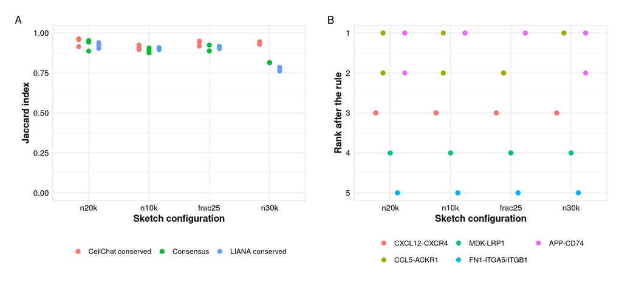

Figure 38: Stability of the consensus set across 12 re-sketching runs. A, Jaccard overlap with the sets rebuilt from the reference sketch (20,000 cells, seed 123). B, rank of each axis after the adhesion-receptor rule.

```r
p_rs_j <- rs_summary %>%
  filter(run_id != "n20k_s123") %>%
  tidyr::pivot_longer(ends_with("_rebuilt"), names_to = "set", values_to = "jaccard") %>%
  mutate(set = recode(set, jaccard_cc_rebuilt = "CellChat conserved", jaccard_liana_rebuilt = "LIANA conserved", jaccard_consensus_rebuilt = "Consensus")) %>%
  ggplot(aes(x = config, y = jaccard, color = set)) +
  geom_point(size = 2.5, position = position_dodge(width = 0.5)) +
  scale_y_continuous(limits = c(0, 1)) +
  labs(x = "Sketch configuration", y = "Jaccard index", color = NULL) +
  theme_publication() +
  theme(legend.position = "bottom")
p_rs_rank <- rs_axis %>%
  filter(in_consensus) %>%
  mutate(Axis = factor(axis_labels[axis_id], levels = axis_labels)) %>%
  ggplot(aes(x = config, y = rank_rule, color = Axis)) +
  geom_point(size = 2.5, position = position_dodge(width = 0.6)) +
  scale_y_reverse() +
  labs(x = "Sketch configuration", y = "Rank after the rule", color = NULL) +
  theme_publication() +
  theme(legend.position = "bottom")
p_rs_rank <- p_rs_rank + guides(color = guide_legend(nrow = 2))
p_rs <- p_rs_j + p_rs_rank + plot_annotation(tag_levels = "A")
ggsave("results/revision/fig_resketch_stability.png", p_rs, width = 14, height = 6, dpi = 300)
p_rs
```

# The candidate axes

Five receptor-specific interactions move forward from the prioritized list. All five are conserved in all three cohorts and are detected by both frameworks:

- **CCL5-ACKR1**, from T cells to endothelial cells. ACKR1 is an atypical chemokine receptor that carries chemokines across the endothelium and does not signal through G proteins.
- **FN1-ITGA5/ITGB1**, from fibroblasts to endothelial cells. Fibronectin binds the α5β1 integrin on endothelium.
- **APP-CD74**, from endothelial cells to B and myeloid cells.
- **MDK-LRP1**, an autocrine loop between fibroblasts.
- **CXCL12-CXCR4**, from fibroblasts to T cells.

The chord diagrams show who sends and who receives each axis in each cohort. A node is a cell type and an edge is the pair’s communication probability. They show at a glance whether an axis is specific to one sender-receiver pair or spread over several cell types. CCL5-ACKR1 is the most specific: it runs only from T cells to endothelial cells. APP-CD74 is the most promiscuous, with several cell types expressing the ligand and the receptor (Figure 39 and the other tabs of the set).

```r
dir.create("results/cellchat_chords", showWarnings = FALSE, recursive = TRUE)

db_interaction <- CellChat::CellChatDB.human$interaction
chord_axes <- list()
for (i in 1:nrow(candidate_registry)) {
  axis_id <- candidate_registry$axis_id[i]
  lig <- candidate_registry$ligand[i]
  rec <- candidate_registry$receptor[i]
  pair_str <- paste0(lig, "_", rec)

  match_row <- db_interaction %>% dplyr::filter(ligand == lig & (receptor == rec | interaction_name == pair_str))
  if (nrow(match_row) == 0) match_row <- db_interaction %>% dplyr::filter(ligand == lig)
  pw <- if (nrow(match_row) > 0) match_row$pathway_name[1] else lig

  chord_axes[[axis_id]] <- list(pathway = pw, pair = pair_str)
}

draw_chord <- function(cohort_name, axis_id) {
  info <- chord_axes[[axis_id]]
  par(mfrow = c(1, 1), mar = c(1, 1, 3, 1))
  CellChat::netVisual_individual(
    cellchat_list[[cohort_name]],
    signaling = info$pathway,
    pairLR.use = info$pair,
    layout = "chord",
    vertex.label.cex = 1.3,
    title.name = NULL
  )
}

for (axis_id in names(chord_axes)) {
  for (cohort_name in names(cellchat_list)) {
    png(sprintf("results/cellchat_chords/chord_%s_%s.png", tolower(cohort_name), axis_id), width = 1400, height = 1400, res = 150)
    draw_chord(cohort_name, axis_id)
    dev.off()
  }
}
```

````r
fig_tabs(
  c("```{r}",
    "#| label: fig-chord-{{key}}-{{inner}}",
    "#| eval: true",
    "#| fig-cap: \"Chord diagram of {{title}} in the {{inner_title}} cohort.\"",
    "#| fig-width: 7",
    "#| fig-height: 7",
    "#| out-width: 65%",
    "invisible(draw_chord(\"{{inner_title}}\", \"{{key}}\"))",
    "```", ""),
  keys = candidate_registry$axis_id,
  titles = gsub("_", "/", gsub("_itgb1", "/ITGB1", axis_labels[candidate_registry$axis_id], fixed = TRUE)),
  inner = c("pal", "wu", "qian"),
  inner_titles = c("Pal", "Wu", "Qian")
)
````

**CXCL12-CXCR4**

**Pal**

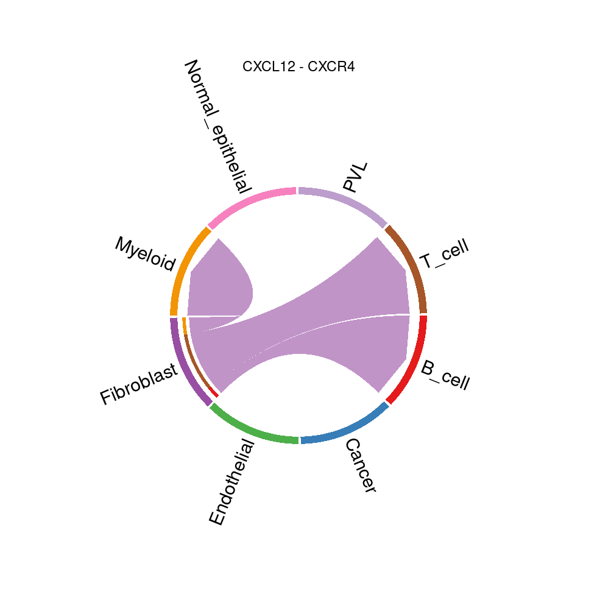

Figure 39: Chord diagram of CXCL12-CXCR4 in the Pal cohort.

```r
invisible(draw_chord("Pal", "cxcl12_cxcr4"))
```

**Wu**

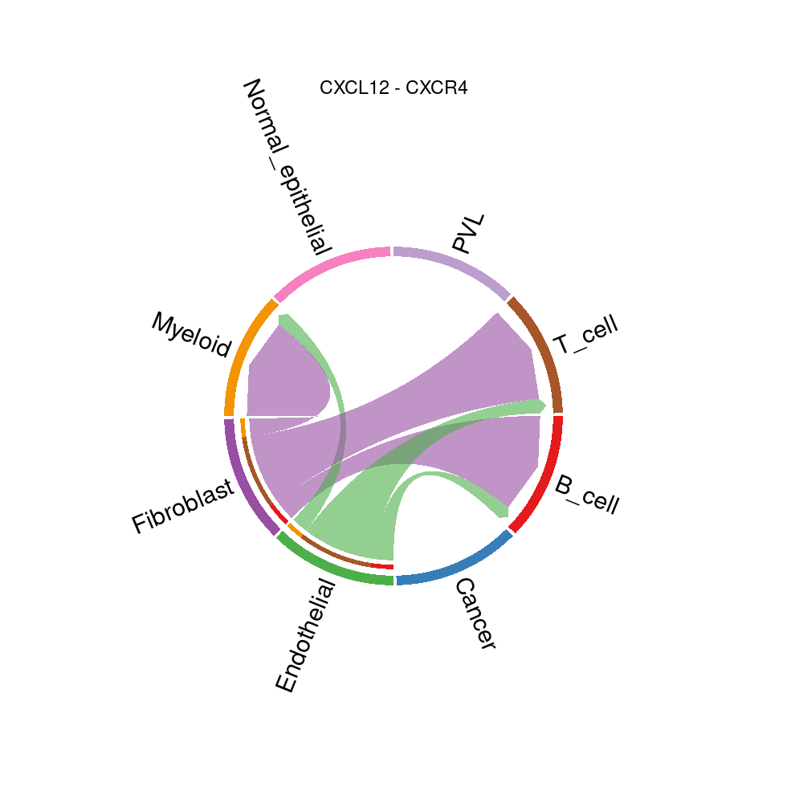

Figure 40: Chord diagram of CXCL12-CXCR4 in the Wu cohort.

```r
invisible(draw_chord("Wu", "cxcl12_cxcr4"))
```

**Qian**

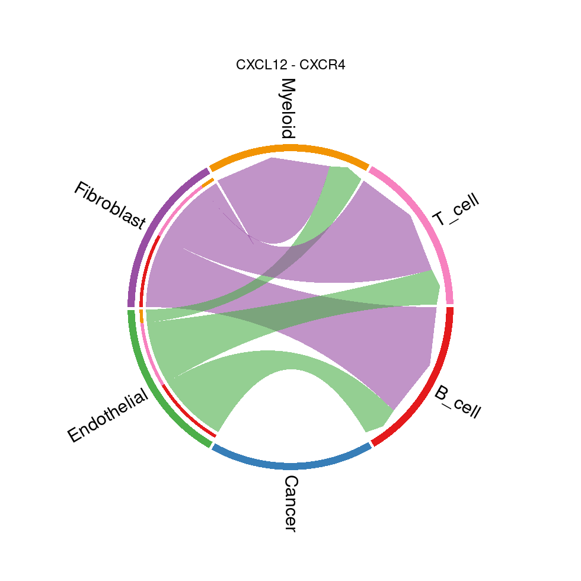

Figure 41: Chord diagram of CXCL12-CXCR4 in the Qian cohort.

```r
invisible(draw_chord("Qian", "cxcl12_cxcr4"))
```

**CCL5-ACKR1**

**Pal**

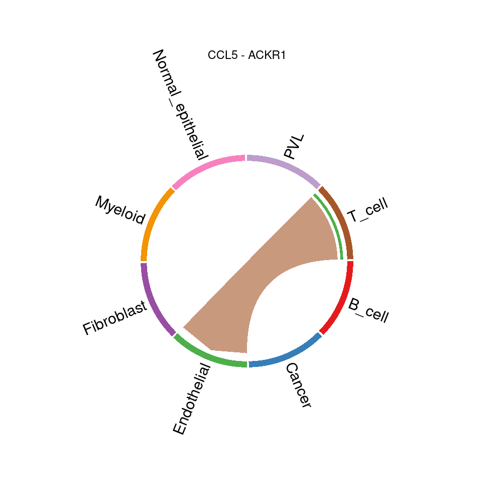

Figure 42: Chord diagram of CCL5-ACKR1 in the Pal cohort.

```r
invisible(draw_chord("Pal", "ccl5_ackr1"))
```

**Wu**

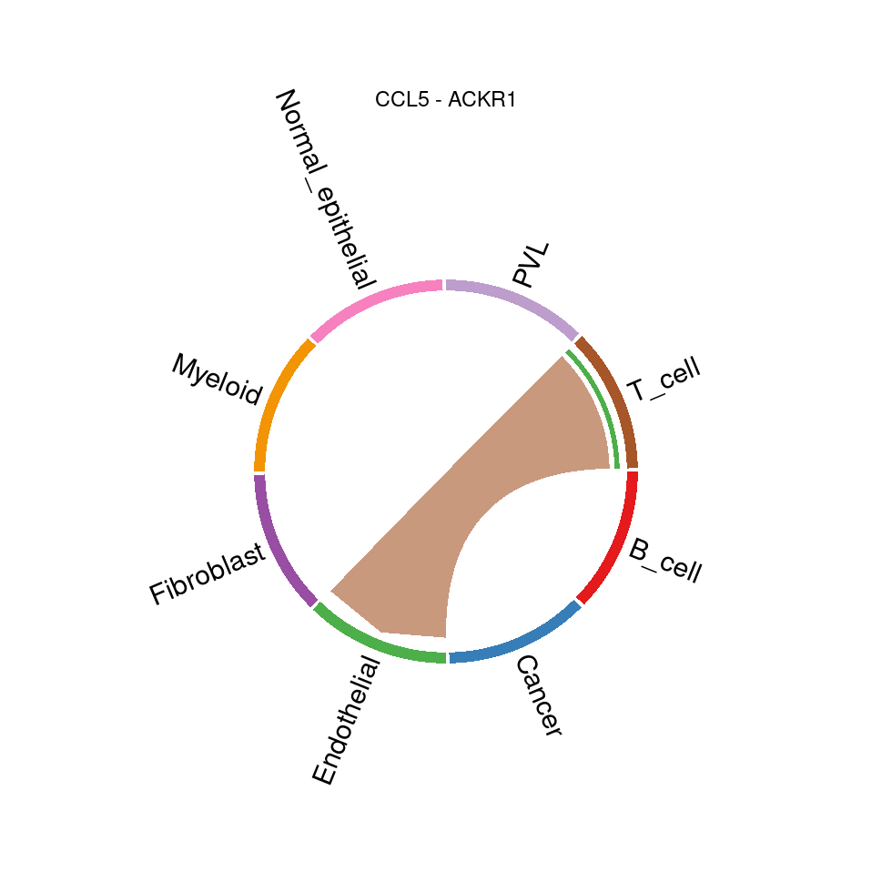

Figure 43: Chord diagram of CCL5-ACKR1 in the Wu cohort.

```r
invisible(draw_chord("Wu", "ccl5_ackr1"))
```

**Qian**

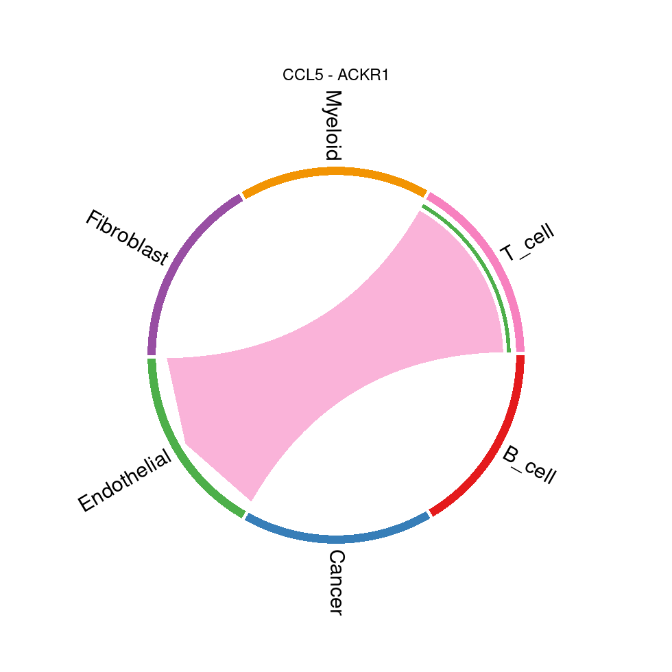

Figure 44: Chord diagram of CCL5-ACKR1 in the Qian cohort.

```r
invisible(draw_chord("Qian", "ccl5_ackr1"))
```

**MDK-LRP1**

**Pal**

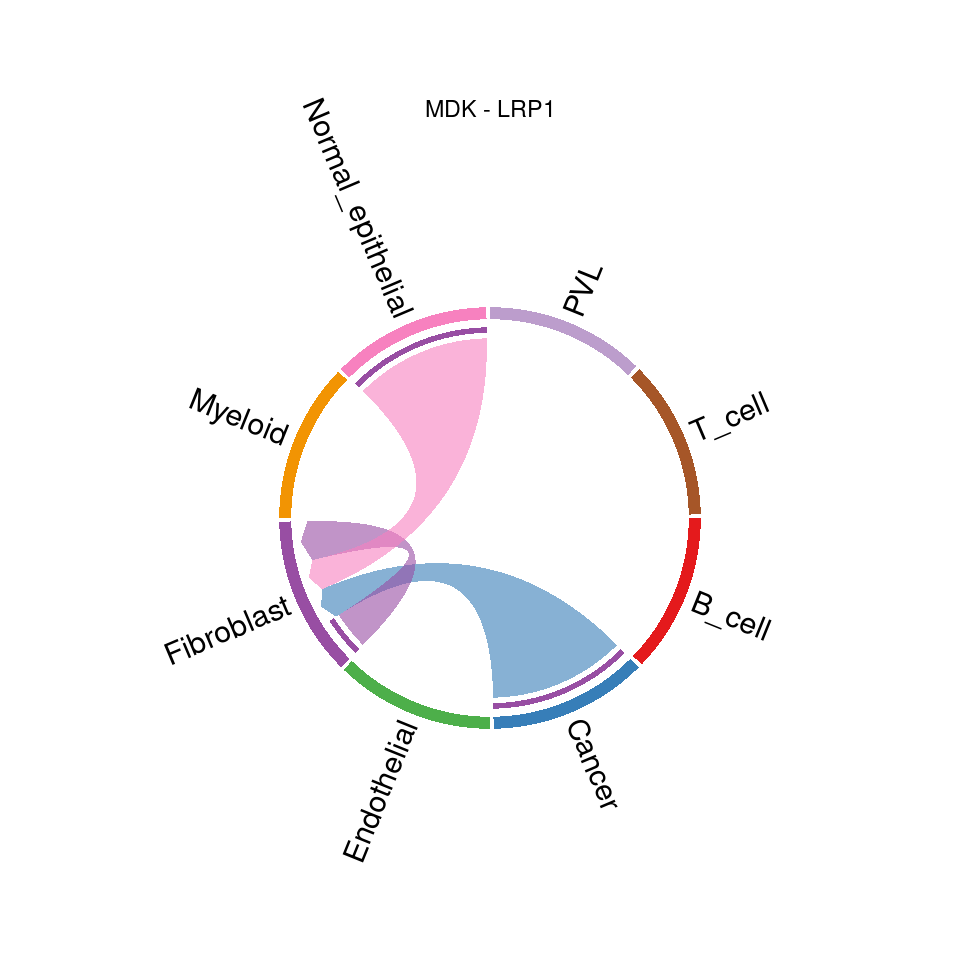

Figure 45: Chord diagram of MDK-LRP1 in the Pal cohort.

```r
invisible(draw_chord("Pal", "mdk_lrp1"))
```

**Wu**

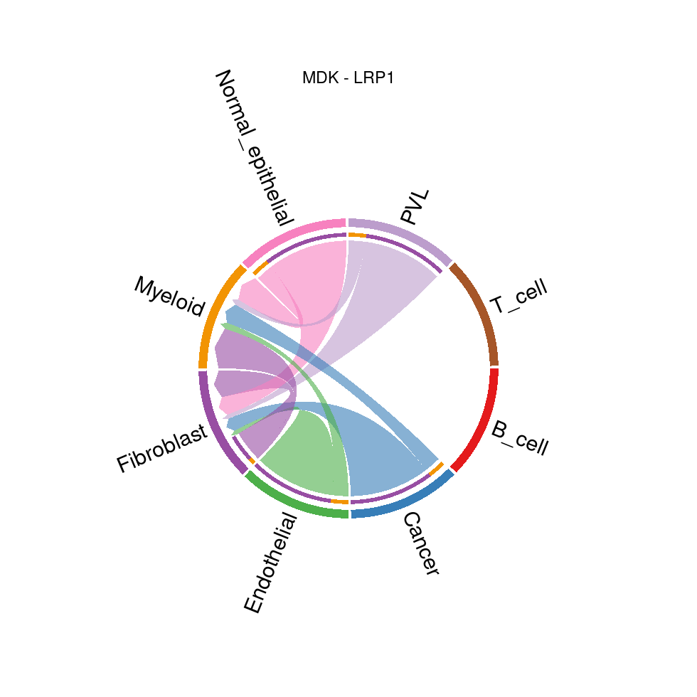

Figure 46: Chord diagram of MDK-LRP1 in the Wu cohort.

```r
invisible(draw_chord("Wu", "mdk_lrp1"))
```

**Qian**

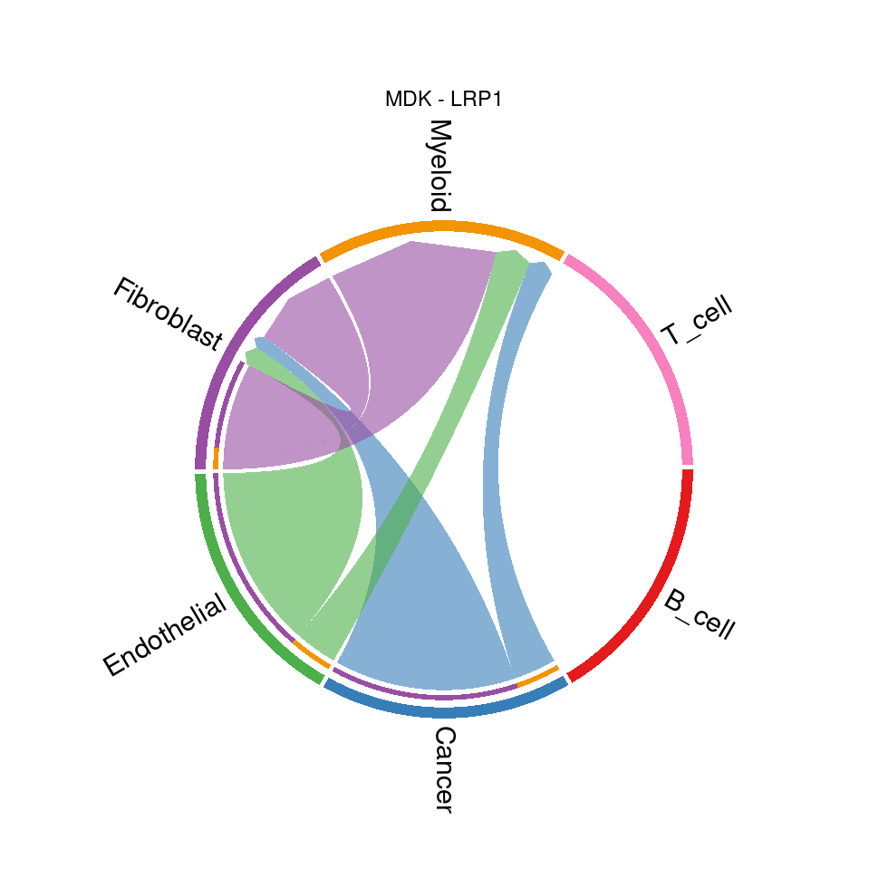

Figure 47: Chord diagram of MDK-LRP1 in the Qian cohort.

```r
invisible(draw_chord("Qian", "mdk_lrp1"))
```

**FN1-ITGA5/ITGB1**

**Pal**

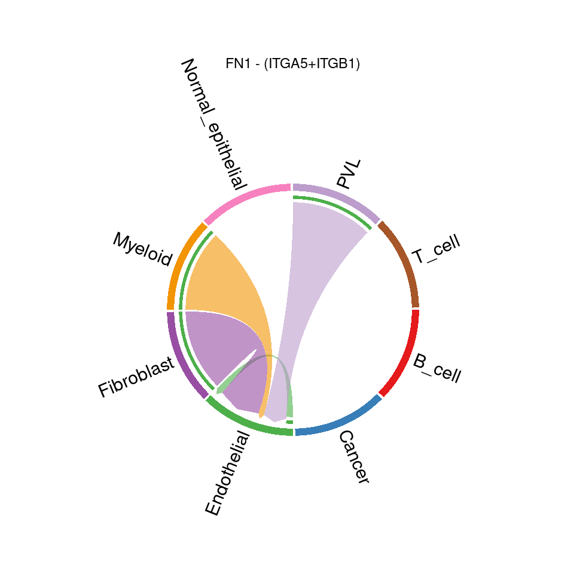

Figure 48: Chord diagram of FN1-ITGA5/ITGB1 in the Pal cohort.

```r
invisible(draw_chord("Pal", "fn1_itga5_itgb1"))
```

**Wu**

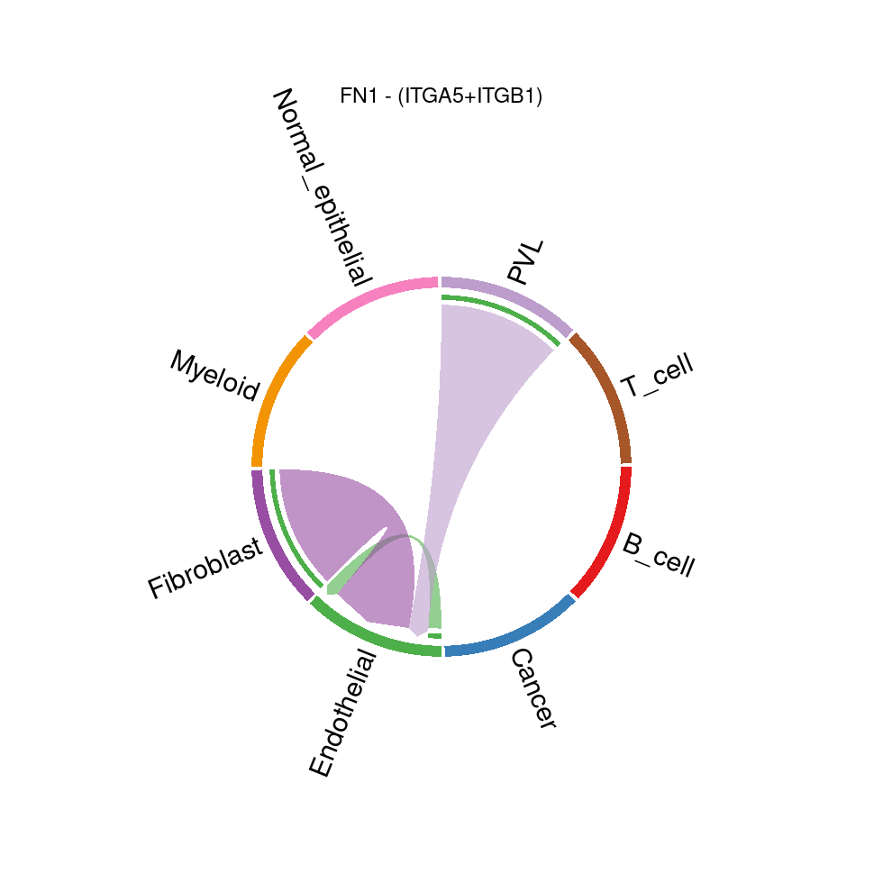

Figure 49: Chord diagram of FN1-ITGA5/ITGB1 in the Wu cohort.

```r
invisible(draw_chord("Wu", "fn1_itga5_itgb1"))
```

**Qian**

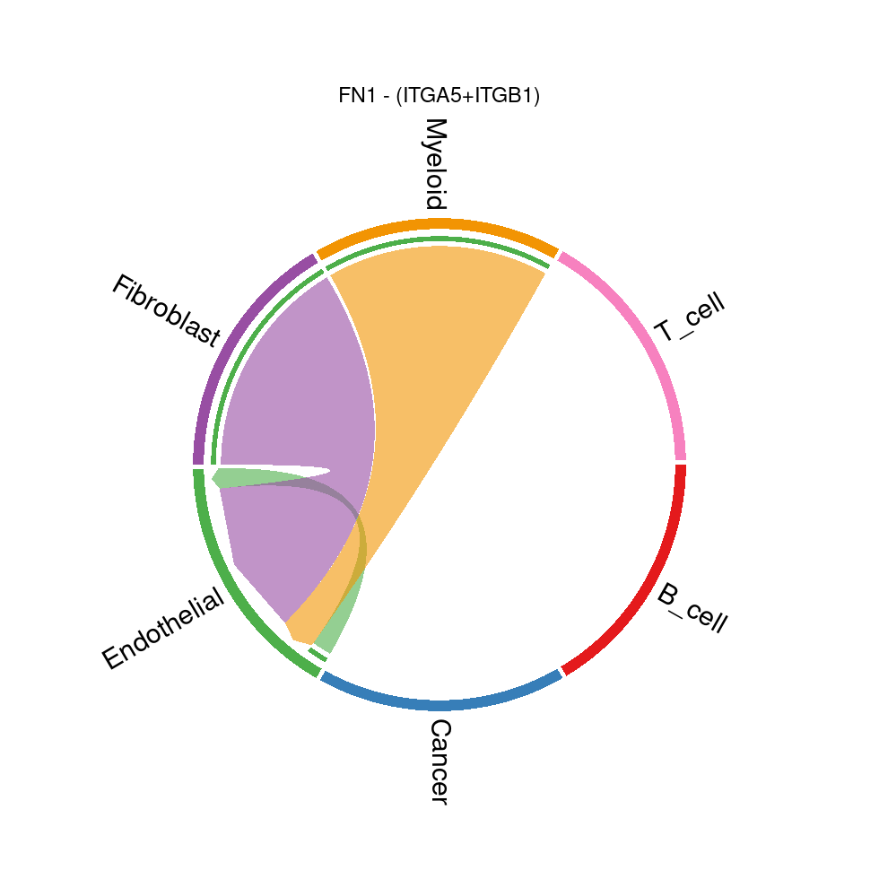

Figure 50: Chord diagram of FN1-ITGA5/ITGB1 in the Qian cohort.

```r
invisible(draw_chord("Qian", "fn1_itga5_itgb1"))
```

**APP-CD74**

**Pal**

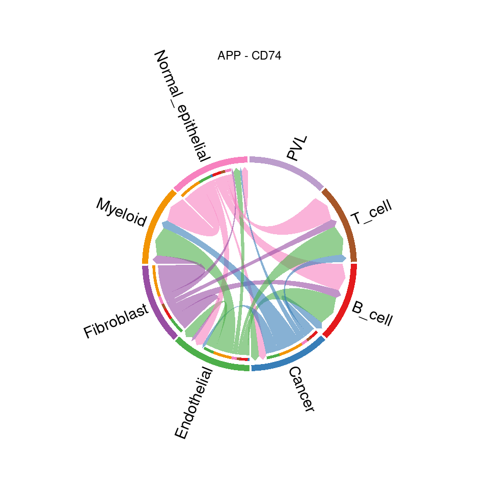

Figure 51: Chord diagram of APP-CD74 in the Pal cohort.

```r
invisible(draw_chord("Pal", "app_cd74"))
```

**Wu**

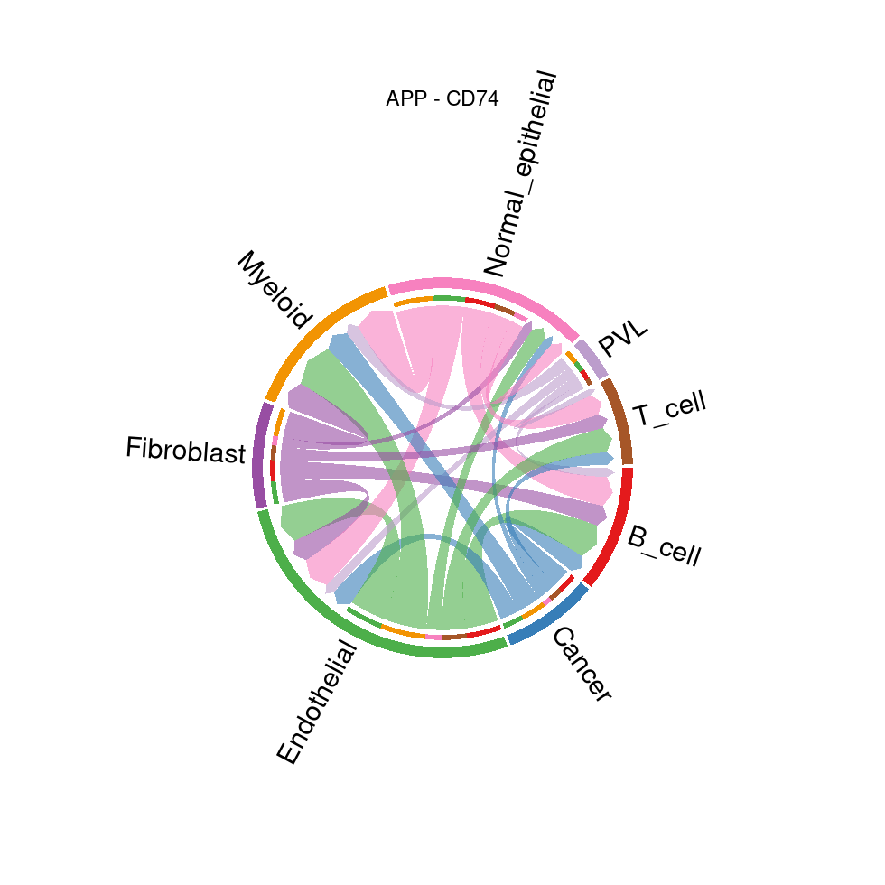

Figure 52: Chord diagram of APP-CD74 in the Wu cohort.

```r
invisible(draw_chord("Wu", "app_cd74"))
```

**Qian**

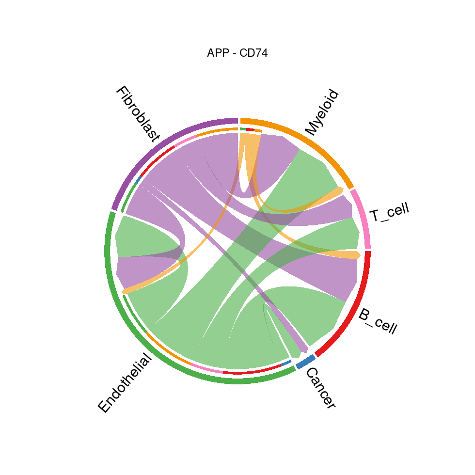

Figure 53: Chord diagram of APP-CD74 in the Qian cohort.

```r
invisible(draw_chord("Qian", "app_cd74"))
```

# Downstream programs

A conserved interaction is only a candidate. To see whether an axis comes with a transcriptional footprint, we look at the cells that would receive the signal and ask what differs between tumors with a high and a low supply of the ligand. We use three readouts. Transcription factor (TF) activity, estimated with decoupleR, describes the regulators that move with the ligand. NicheNet adds prior knowledge about which target genes a ligand is known to regulate. And a per-sample pseudobulk differential expression analysis tests the receiver programs with the tumor sample as the unit of replication.

The unit of replication matters. Tumors, not cells, are the independent observations, and a cell-level test treats thousands of cells from a handful of patients as independent. We therefore define the groups at the level of samples throughout. In each cohort, samples are split at the median of the fraction of sender cells that detect the ligand (samples with at least 10 sender cells), and expression is summed over the receiver cells of each sample (samples with at least 10 receiver cells). The receptor must be detected in at least 2% of the receiver cells of the cohort, otherwise the axis is skipped for that cohort.

## Transcription factor activity

For every cohort and axis, we aggregate the raw counts of the receiver cells of each sample into a log2 counts-per-million profile, and estimate TF activity per sample with the weighted-mean method of decoupleR against the CollecTRI regulons (at least 5 targets per regulon). We then regress each TF activity on the sender ligand and the receiver receptor expression across samples, and take the ligand term and its p-value. Correlations are corrected with the Benjamini-Hochberg procedure across the roughly 765 TFs tested per run. The results are saved in `results/tf_activity/`.

```r
seu_pal <- qs_read("objects/seu_pal_harmonized_20000.qs2")
seu_wu <- qs_read("objects/seu_wu_harmonized_20000.qs2")
seu_qian <- qs_read("objects/seu_qian_harmonized_20000.qs2")

cc_pal <- qs_read("objects/cc_pal_20000.qs2")
cc_wu <- qs_read("objects/cc_wu_20000.qs2")
cc_qian <- qs_read("objects/cc_qian_20000.qs2")
```

```r
dir.create("data/decoupler", showWarnings = FALSE, recursive = TRUE)
dir.create("results/tf_activity", showWarnings = FALSE, recursive = TRUE)

collectri_file <- "data/decoupler/collectri.csv"
if (!file.exists(collectri_file)) {
  collectri_db <- get_collectri(organism = "human", split_complexes = FALSE)
  write.csv(collectri_db, collectri_file, row.names = FALSE)
} else {
  collectri_db <- read.csv(collectri_file)
}

cohort_list <- list(pal = seu_pal, wu = seu_wu, qian = seu_qian)

for (cohort_name in names(cohort_list)) {
  message(sprintf("Processing cohort: %s", cohort_name))
  seu <- cohort_list[[cohort_name]]
  Idents(seu) <- "harmonized_label"
  available <- levels(Idents(seu))

  for (i in 1:nrow(candidate_registry)) {
    message(sprintf(" - Processing axis: %s", candidate_registry$axis_id[i]))
    row <- candidate_registry[i, ]
    axis_id <- row$axis_id
    l <- row$ligand
    r <- row$receptor
    sender <- row$sender_celltype
    receiver <- row$receiver_celltype

    if (!(sender %in% available) || !(receiver %in% available)) next

    seu_rec <- subset(seu, harmonized_label == receiver)
    counts <- GetAssayData(seu_rec, assay = "RNA", layer = "counts")
    samples <- as.factor(seu_rec$sample_id)

    design <- model.matrix(~ 0 + samples)
    colnames(design) <- levels(samples)
    pb_counts <- as.matrix(counts %*% design)
    pb_logcpm <- log2(t(t(pb_counts) / colSums(pb_counts)) * 1e6 + 1)

    activities <- run_wmean(
      mat = pb_logcpm,
      net = collectri_db,
      .source = "source",
      .target = "target",
      .mor = "weight",
      times = 100,
      minsize = 5
    ) %>% filter(statistic == "norm_wmean")

    seu_send <- subset(seu, harmonized_label == sender)
    counts_send <- GetAssayData(seu_send, assay = "RNA", layer = "counts")
    if (!(l %in% rownames(counts_send))) next

    ligand_counts <- counts_send[l, ]
    samples_send <- as.factor(seu_send$sample_id)
    ligand_pb <- tapply(ligand_counts, samples_send, sum)
    libsizes_send <- tapply(colSums(counts_send), samples_send, sum)
    ligand_logcpm <- log2((ligand_pb / libsizes_send) * 1e6 + 1)

    if (r %in% rownames(pb_counts)) {
      receptor_pb <- pb_counts[r, ]
      receptor_logcpm <- log2((receptor_pb / colSums(pb_counts)) * 1e6 + 1)
    } else {
      receptor_logcpm <- rep(0, ncol(pb_counts))
      names(receptor_logcpm) <- colnames(pb_counts)
    }

    common_samples <- intersect(names(ligand_logcpm), colnames(pb_logcpm))
    if (length(common_samples) < 5) next

    ligand_aligned <- ligand_logcpm[common_samples]
    receptor_aligned <- receptor_logcpm[common_samples]

    act_wide <- activities %>%
      filter(condition %in% common_samples) %>%
      dplyr::select(source, condition, score) %>%
      pivot_wider(names_from = source, values_from = score) %>%
      arrange(match(condition, common_samples))

    tf_names <- setdiff(colnames(act_wide), "condition")
    cor_df <- data.frame(TF = character(), Correlation = numeric(), PValue = numeric(), stringsAsFactors = FALSE)

    for (tf in tf_names) {
      tf_scores <- act_wide[[tf]]
      sd_val <- sd(tf_scores, na.rm = TRUE)
      if (is.na(sd_val) || sd_val == 0) next

      # Multiple regression adjusting for receptor availability
      fit <- tryCatch(lm(tf_scores ~ ligand_aligned + receptor_aligned), error = function(e) NULL)
      if (is.null(fit)) next
      fit_summary <- summary(fit)
      coef_mat <- fit_summary$coefficients

      if ("ligand_aligned" %in% rownames(coef_mat)) {
        r_val <- cor(tf_scores, ligand_aligned, use = "complete.obs")
        pval <- coef_mat["ligand_aligned", "Pr(>|t|)"]
        if (!is.na(r_val) && !is.na(pval)) {
          cor_df <- rbind(cor_df, data.frame(
            TF = tf,
            Correlation = r_val,
            PValue = pval,
            stringsAsFactors = FALSE
          ))
        }
      }
    }

    if (nrow(cor_df) > 0) {
      cor_df$FDR <- p.adjust(cor_df$PValue, method = "BH")
      cor_df <- cor_df %>% arrange(FDR, desc(abs(Correlation)))
    }

    write.csv(cor_df, sprintf("results/tf_activity/tf_activity_%s_%s.csv", axis_id, cohort_name), row.names = FALSE)
  }
}
```

Across cohorts, per-TF correlations are combined with Fisher’s z transformation, and a TF is called concordant if the sign of its correlation is the same in every cohort in which it was tested (TFs seen in a single cohort are dropped). We write the integrated tables and draw the strongest TFs per axis (Figure 54 and the other tabs of the set). It also draws the per-cohort correlations (Figure 55 and the other tabs of the set).

```r
dir.create("results/tf_activity/plots", showWarnings = FALSE, recursive = TRUE)
tf_cohort_plots <- list()
for (i in seq_len(nrow(candidate_registry))) {
  axis <- candidate_registry$axis_id[i]
  plots <- list()
  for (ch in c("pal", "wu", "qian")) {
    f <- sprintf("results/tf_activity/tf_activity_%s_%s.csv", axis, ch)
    if (!file.exists(f)) next
    df <- read.csv(f)
    if (nrow(df) == 0) next
    p <- ggplot(head(df, 20), aes(x = reorder(TF, Correlation), y = Correlation, fill = Correlation)) +
      geom_col(width = 0.75, alpha = 0.9) +
      geom_hline(yintercept = 0, color = "grey30", linewidth = 0.6) +
      coord_flip() +
      scale_fill_gradient2(low = "#2166AC", mid = "grey95", high = "#B2182B", midpoint = 0, guide = "none") +
      labs(x = NULL, y = "Correlation (r)") +
      theme_publication() +
      theme(
        axis.text.y = element_text(size = 11, face = "bold"),
        panel.grid.major.y = element_blank(),
        panel.grid.minor = element_blank()
      )
    plots[[ch]] <- p
    ggsave(sprintf("results/tf_activity/plots/tf_%s_%s.png", axis, ch), plot = p, width = 4.5, height = 6, dpi = 300, bg = "white")
  }
  tf_cohort_plots[[axis]] <- wrap_plots(plots, ncol = 3) + plot_annotation(tag_levels = "A")
}
```

```r
dir.create("results/tf_activity/plots", showWarnings = FALSE, recursive = TRUE)
dir.create("results/tf_activity/tables", showWarnings = FALSE, recursive = TRUE)

cohorts <- c("pal", "wu", "qian")
tf_integrated_plots <- list()

for (i in seq_len(nrow(candidate_registry))) {
  row <- candidate_registry[i, ]
  axis <- row$axis_id
  l <- row$ligand
  r <- row$receptor
  sender <- row$sender_celltype
  receiver <- row$receiver_celltype

  dfs <- list()
  for (ch in cohorts) {
    f <- sprintf("results/tf_activity/tf_activity_%s_%s.csv", axis, ch)
    if (file.exists(f)) {
      d <- read.csv(f)
      d$Correlation <- pmin(pmax(d$Correlation, -0.999), 0.999)
        d$Cohort <- ch
        dfs[[ch]] <- d
    }
  }

  if (length(dfs) == 0) next
  all_tfs <- bind_rows(dfs)

  integrated_tfs <- all_tfs %>%
    group_by(TF) %>%
    summarise(
      CohortCount = n(),
      # Fisher z before averaging the correlations
      MeanCorrelation = tanh(mean(atanh(Correlation), na.rm = TRUE)),
      Concordance = ifelse(all(Correlation > 0) || all(Correlation < 0), "Concordant", "Discordant"),
      .groups = "drop"
    ) %>%
    # Keep only TFs tested in at least two cohorts
    filter(CohortCount > 1) %>%
    # Sort by concordance, then cohort count, then correlation strength
    arrange(desc(Concordance == "Concordant"), desc(CohortCount), desc(abs(MeanCorrelation)))

  if(nrow(integrated_tfs) == 0) next

  top_tfs <- head(integrated_tfs, 15)

  p_tf <- ggplot(top_tfs, aes(x = reorder(TF, MeanCorrelation), y = MeanCorrelation, fill = MeanCorrelation)) +
    geom_col(width = 0.75, alpha = 0.9) +
    geom_hline(yintercept = 0, color = "grey30", linewidth = 0.6) +
    coord_flip() +
    scale_fill_gradient2(
      low = "#2166AC", mid = "grey95", high = "#B2182B",
      midpoint = 0, guide = "none"
    ) +
    theme_minimal(base_size = 12) +
    labs(
      x = NULL,
      y = "Mean Pearson r (Fisher Z-adjusted)"
    ) +
    theme(
      axis.text.y = element_text(size = 10, face = "bold", color = "black"),
      axis.text.x = element_text(size = 10, color = "black"),
      axis.title.x = element_text(size = 11, face = "bold", color = "black"),
      panel.grid.major.y = element_blank(),
      panel.grid.minor = element_blank(),
      panel.grid.major.x = element_line(color = "grey85", linewidth = 0.4),
      plot.margin = margin(t = 10, r = 15, b = 15, l = 15)
    )
  tf_integrated_plots[[axis]] <- p_tf

  ggsave(sprintf("results/tf_activity/plots/tf_integrated_%s.png", axis), plot = p_tf, width = 4.6, height = 5.0, dpi = 300, bg = "white")
  ggsave(sprintf("figures/tf_integrated_%s.png", axis), plot = p_tf, width = 4.6, height = 5.0, dpi = 300, bg = "white")
  ggsave(sprintf("figures/tf_integrated_mean_%s.png", axis), plot = p_tf, width = 4.6, height = 5.0, dpi = 300, bg = "white")

  write.csv(head(integrated_tfs, 8), sprintf("results/tf_activity/tables/tf_table_%s.csv", axis), row.names = FALSE)
}
```

````r
fig_tabs(
  c("```{r}",
    "#| label: fig-tf-integrated-{{key}}",
    "#| eval: true",
    "#| fig-cap: \"Transcription factors whose activity in {{title}} receiver cells is most consistently correlated with the ligand across the three discovery cohorts (mean Pearson r after Fisher's z transformation, among TFs tested in at least two cohorts; concordant TFs first).\"",
    "#| fig-width: 4.6",
    "#| fig-height: 5",
    "#| out-width: 50%",
    "tf_integrated_plots[[\"{{key}}\"]]",
    "```", "",
    "```{r}",
    "#| label: fig-tf-cohort-{{key}}",
    "#| eval: true",
    "#| fig-cap: \"The 20 TFs most strongly associated with the ligand of {{title}} in each cohort (A, Pal; B, Wu; C, Qian).\"",
    "#| fig-width: 12",
    "#| fig-height: 7.5",
    "tf_cohort_plots[[\"{{key}}\"]]",
    "```", ""),
  keys = candidate_registry$axis_id,
  titles = axis_labels[candidate_registry$axis_id]
)
````

**CXCL12-CXCR4**

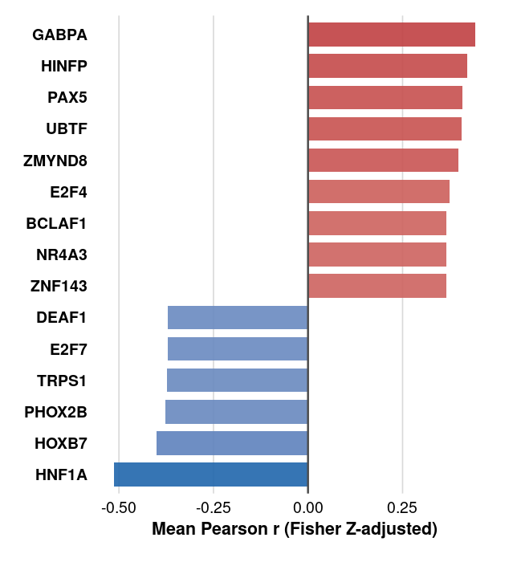

Figure 54: Transcription factors whose activity in CXCL12-CXCR4 receiver cells is most consistently correlated with the ligand across the three discovery cohorts (mean Pearson r after Fisher’s z transformation, among TFs tested in at least two cohorts; concordant TFs first).

```r
tf_integrated_plots[["cxcl12_cxcr4"]]
```

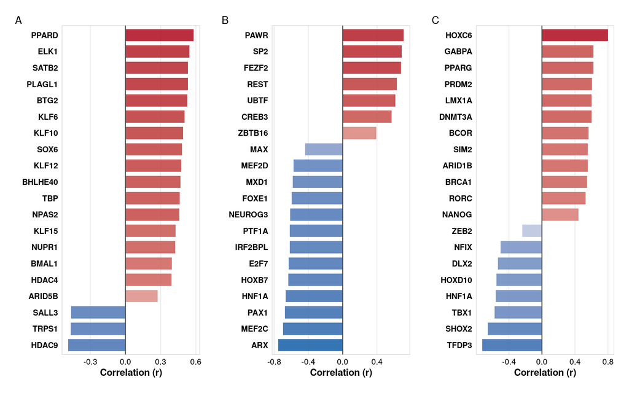

Figure 55: The 20 TFs most strongly associated with the ligand of CXCL12-CXCR4 in each cohort (A, Pal; B, Wu; C, Qian).

```r
tf_cohort_plots[["cxcl12_cxcr4"]]
```

**CCL5-ACKR1**

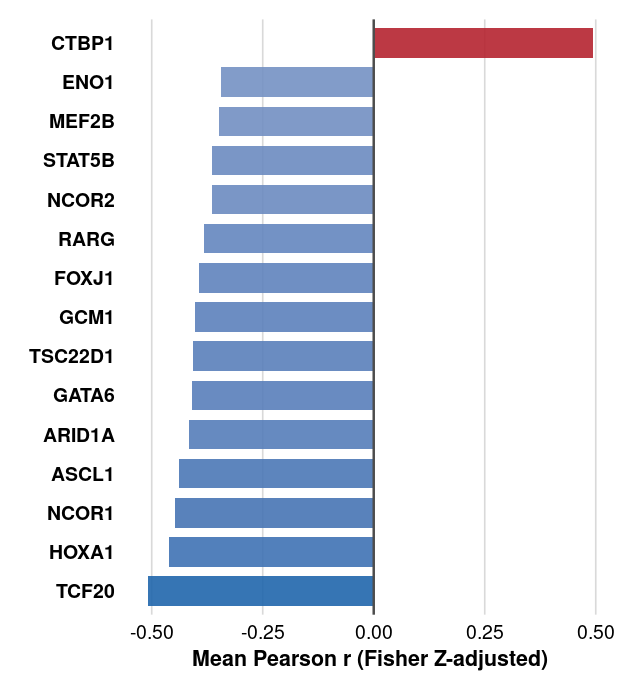

Figure 56: Transcription factors whose activity in CCL5-ACKR1 receiver cells is most consistently correlated with the ligand across the three discovery cohorts (mean Pearson r after Fisher’s z transformation, among TFs tested in at least two cohorts; concordant TFs first).

```r
tf_integrated_plots[["ccl5_ackr1"]]
```

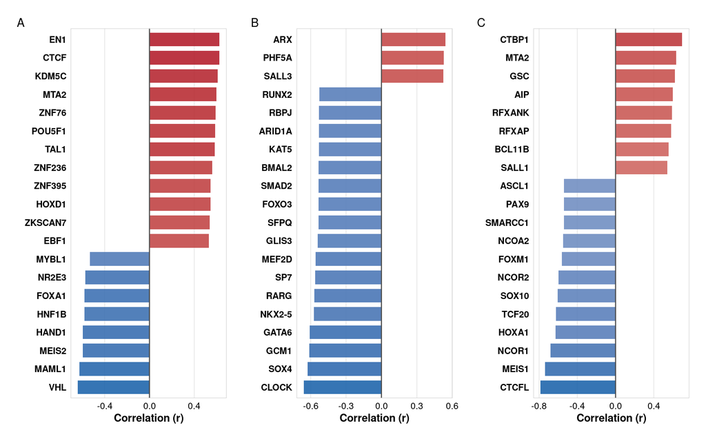

Figure 57: The 20 TFs most strongly associated with the ligand of CCL5-ACKR1 in each cohort (A, Pal; B, Wu; C, Qian).

```r
tf_cohort_plots[["ccl5_ackr1"]]
```

**MDK-LRP1**

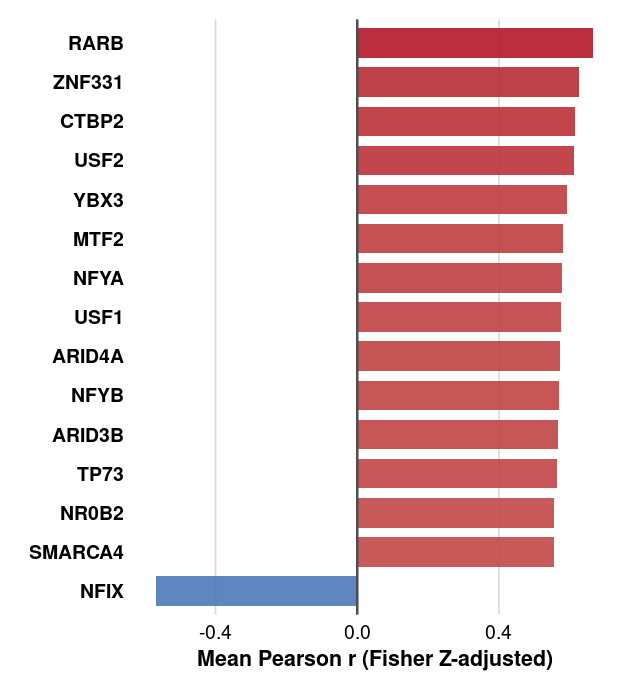

Figure 58: Transcription factors whose activity in MDK-LRP1 receiver cells is most consistently correlated with the ligand across the three discovery cohorts (mean Pearson r after Fisher’s z transformation, among TFs tested in at least two cohorts; concordant TFs first).

```r
tf_integrated_plots[["mdk_lrp1"]]
```

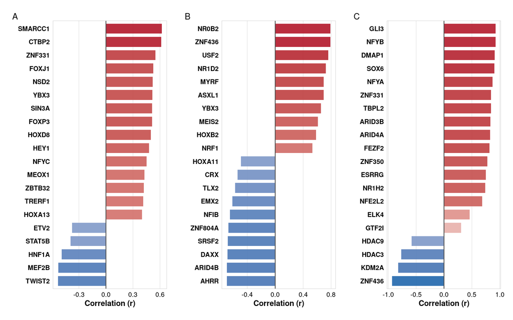

Figure 59: The 20 TFs most strongly associated with the ligand of MDK-LRP1 in each cohort (A, Pal; B, Wu; C, Qian).

```r
tf_cohort_plots[["mdk_lrp1"]]
```

**FN1-ITGA5/ITGB1**

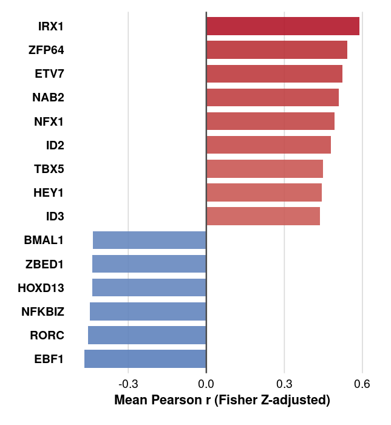

Figure 60: Transcription factors whose activity in FN1-ITGA5/ITGB1 receiver cells is most consistently correlated with the ligand across the three discovery cohorts (mean Pearson r after Fisher’s z transformation, among TFs tested in at least two cohorts; concordant TFs first).

```r
tf_integrated_plots[["fn1_itga5_itgb1"]]
```

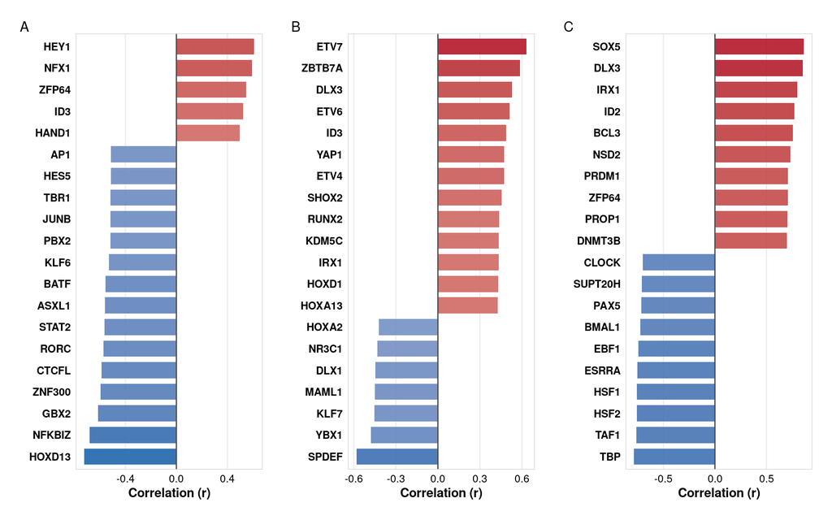

Figure 61: The 20 TFs most strongly associated with the ligand of FN1-ITGA5/ITGB1 in each cohort (A, Pal; B, Wu; C, Qian).

```r
tf_cohort_plots[["fn1_itga5_itgb1"]]
```

**APP-CD74**

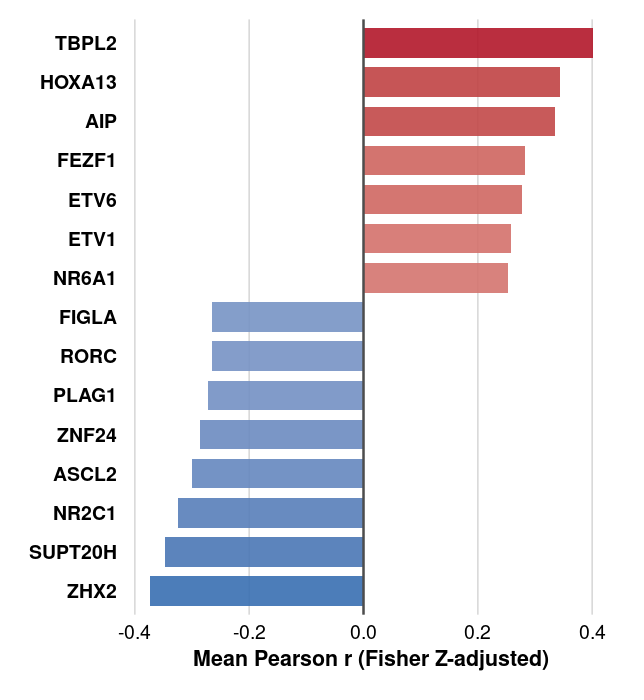

Figure 62: Transcription factors whose activity in APP-CD74 receiver cells is most consistently correlated with the ligand across the three discovery cohorts (mean Pearson r after Fisher’s z transformation, among TFs tested in at least two cohorts; concordant TFs first).

```r
tf_integrated_plots[["app_cd74"]]
```

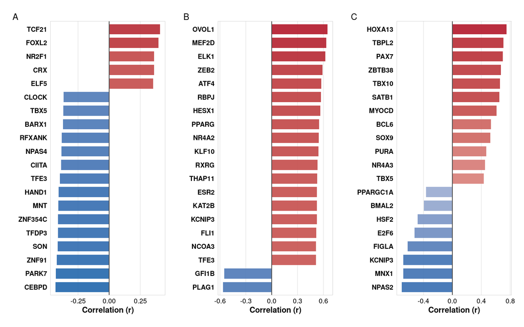

Figure 63: The 20 TFs most strongly associated with the ligand of APP-CD74 in each cohort (A, Pal; B, Wu; C, Qian).

```r
tf_cohort_plots[["app_cd74"]]
```

These TF analyses are descriptive. After correction for the roughly 765 TFs tested in each run, the number of TFs with FDR below 0.05 is small, and no TF passes in more than one cohort for any axis (the table in the next section lists the counts per axis and cohort). The “cohort-concordant” TFs in the figures are concordant in sign, and should be read as candidate regulators and not as established master regulators.

## Per-cohort pseudobulk differential expression

For each axis and cohort we compare the pseudobulk profiles of receiver cells between ligand-high and ligand-low samples with edgeR’s quasi-likelihood framework (genes filtered with `filterByExpr`, TMM normalization). The groups have 7 to 16 samples per group in Pal, 10 to 13 in Wu and 4 to 7 in Qian, so power is limited, especially in Qian. Differentially expressed genes are those with FDR below 0.05. When fewer than 10 genes pass, we fall back to nominal p below 0.05, and we flag these runs. The differentially expressed genes of each run then go through NicheNet. Candidate targets are ranked by the composite regulatory potential, the product of NicheNet’s prior potential of the ligand for the gene and one plus the absolute log fold change, and we also record the activity rank of the axis ligand among all potential ligands. A contrast-level TF activity is computed by decoupleR’s univariate linear model on the differential expression statistic.

```r
suppressMessages({
  library(dplyr)
  library(qs2)
  library(Matrix)
  library(Seurat)
  library(edgeR)
  library(nichenetr)
  library(decoupleR)
})

set.seed(42)
ligand_target_matrix <- readRDS("data/nichenet/ligand_target_matrix_nsga2r_final.rds")
lr_network <- readRDS("data/nichenet/lr_network_human_21122021.rds")
collectri_db <- read.csv("data/decoupler/collectri.csv")


out_path <- "objects/revision/pseudobulk_nichenet.qs2"
results <- if (file.exists(out_path)) qs_read(out_path) else list()

for (cohort in c("pal", "wu", "qian")) {
  if (all(paste(cohort, candidate_registry$axis_id, sep = "_") %in% names(results))) next
  message(sprintf("[%s] %s: loading", Sys.time(), cohort))
  seu <- qs_read(sprintf("objects/seu_%s_harmonized_20000.qs2", cohort))
  counts <- GetAssayData(seu, assay = "RNA", layer = "counts")
  meta <- seu@meta.data
  rm(seu)
  gc()

  for (i in seq_len(nrow(candidate_registry))) {
    row <- candidate_registry[i, ]
    key <- paste(cohort, row$axis_id, sep = "_")
    send_idx <- which(meta$harmonized_label == row$sender_celltype)
    rec_idx <- which(meta$harmonized_label == row$receiver_celltype)
    rec_genes <- strsplit(row$receptor, "_")[[1]]
    rec_pct <- max(sapply(intersect(rec_genes, rownames(counts)), function(g) mean(counts[g, rec_idx] > 0)))
    if (length(send_idx) == 0 || length(rec_idx) == 0 || rec_pct < 0.02) {
      results[[key]] <- list(cohort = cohort, axis_id = row$axis_id, status = "receptor below 2% or cell type absent")
      next
    }

    # Stratification: median split of the per-sample ligand detection rate in sender cells
    send_tab <- data.frame(sample = meta$sample_id[send_idx], det = as.numeric(counts[row$ligand, send_idx] > 0)) %>%
      group_by(sample) %>%
      summarise(n_sender = n(), det_rate = mean(det), .groups = "drop") %>%
      filter(n_sender >= 10)
    send_tab$ligand_group <- ifelse(send_tab$det_rate >= median(send_tab$det_rate), "High", "Low")

    rec_n <- table(meta$sample_id[rec_idx])
    samples <- intersect(names(rec_n)[rec_n >= 10], send_tab$sample)
    send_tab <- send_tab %>% filter(sample %in% samples)
    group <- factor(send_tab$ligand_group, levels = c("Low", "High"))
    if (min(table(group)) < 2) {
      results[[key]] <- list(cohort = cohort, axis_id = row$axis_id, status = "fewer than 2 samples per group", send_tab = send_tab)
      next
    }

    rec_cells <- rec_idx[meta$sample_id[rec_idx] %in% samples]
    sample_factor <- factor(meta$sample_id[rec_cells], levels = send_tab$sample)
    pb <- as.matrix(counts[, rec_cells] %*% sparse.model.matrix(~ 0 + sample_factor))
    colnames(pb) <- levels(sample_factor)

    y <- DGEList(pb, group = group)
    y <- y[filterByExpr(y, group = group), , keep.lib.sizes = FALSE]
    y <- calcNormFactors(y)
    design <- model.matrix(~ group)
    y <- estimateDisp(y, design)
    fit <- glmQLFit(y, design, robust = TRUE)
    de <- topTags(glmQLFTest(fit, coef = 2), n = Inf)$table
    de$gene <- rownames(de)

    n_fdr <- sum(de$FDR < 0.05)
    fallback <- n_fdr < 10
    deg <- if (fallback) de %>% filter(PValue < 0.05) else de %>% filter(FDR < 0.05)

    # Background: genes detected in >= 5% of receiver cells and present in the prior
    pct_rec <- Matrix::rowMeans(counts[, rec_idx] > 0)
    background <- intersect(names(pct_rec)[pct_rec >= 0.05], rownames(ligand_target_matrix))
    goi <- intersect(deg$gene, background)

    targets <- data.frame(Gene = goi, stringsAsFactors = FALSE) %>%
      left_join(deg %>% select(Gene = gene, logFC, PValue, FDR), by = "Gene") %>%
      mutate(PriorPotential = ligand_target_matrix[Gene, row$ligand],
             RegulatoryPotential = PriorPotential * (1 + abs(logFC))) %>%
      arrange(desc(RegulatoryPotential))

    expressed_receptors <- names(pct_rec)[pct_rec >= 0.05]
    potential_ligands <- intersect(unique(lr_network$from[lr_network$to %in% expressed_receptors]), colnames(ligand_target_matrix))
    potential_ligands <- union(potential_ligands, row$ligand)
    activity <- if (length(goi) >= 5) {
      predict_ligand_activities(geneset = goi, background_expressed_genes = background,
                                ligand_target_matrix = ligand_target_matrix, potential_ligands = potential_ligands) %>%
        arrange(desc(aupr_corrected)) %>%
        mutate(rank = row_number())
    } else {
      NULL
    }

    stat_mat <- matrix(sign(de$logFC) * sqrt(de$F), ncol = 1, dimnames = list(de$gene, "contrast"))
    tf <- run_ulm(mat = stat_mat, net = collectri_db, .source = "source", .target = "target", .mor = "weight", minsize = 5) %>%
      mutate(FDR = p.adjust(p_value, method = "BH"))

    results[[key]] <- list(
      cohort = cohort, axis_id = row$axis_id, status = "ok",
      send_tab = send_tab, n_high = sum(group == "High"), n_low = sum(group == "Low"),
      n_genes_tested = nrow(de), n_fdr = n_fdr, fallback = fallback, n_deg_used = nrow(deg),
      de = de, targets = targets, activity = activity, n_potential_ligands = length(potential_ligands), tf = tf
    )
    message(sprintf("[%s] %s: %d vs %d samples, %d genes FDR<0.05, %d targets", Sys.time(), key,
                    sum(group == "High"), sum(group == "Low"), n_fdr, nrow(targets)))
    qs_save(results, out_path)
  }
  rm(counts, meta)
  gc()
}
qs_save(results, out_path)
message("Pseudobulk / NicheNet pipeline finished")
```

```r
pb_res <- qs_read("objects/revision/pseudobulk_nichenet.qs2")
tf_dir <- "results/tf_activity"

# TF counts at FDR < 0.05 from the original decoupleR regressions
orig_tf_counts <- bind_rows(lapply(candidate_registry$axis_id, function(ax) {
  bind_rows(lapply(c("pal", "wu", "qian"), function(ch) {
    f <- file.path(tf_dir, sprintf("tf_activity_%s_%s.csv", ax, ch))
    if (!file.exists(f)) return(NULL)
    d <- read.csv(f)
    data.frame(axis_id = ax, cohort = ch, tfs_tested_orig = nrow(d), tfs_fdr05_orig = sum(d$FDR < 0.05), min_fdr_orig = min(d$FDR))
  }))
}))

pb_summary <- bind_rows(lapply(pb_res, function(x) {
  if (x$status != "ok") {
    return(data.frame(axis_id = x$axis_id, cohort = x$cohort, status = x$status))
  }
  new_top <- head(x$targets$Gene, 20)
  lig <- candidate_registry$ligand[candidate_registry$axis_id == x$axis_id]
  act <- x$activity
  data.frame(
    axis_id = x$axis_id, cohort = x$cohort, status = x$status,
    samples_high = x$n_high, samples_low = x$n_low, genes_tested = x$n_genes_tested,
    degs_fdr05 = x$n_fdr, deg_rule = ifelse(x$fallback, "nominal p < 0.05 (fallback)", "FDR < 0.05"), degs_used = x$n_deg_used,
    nichenet_targets = nrow(x$targets), top5_targets = paste(head(new_top, 5), collapse = ", "),
    ligand_activity_rank = if (is.null(act)) NA_integer_ else act$rank[act$test_ligand == lig],
    ligand_activity_n = if (is.null(act)) NA_integer_ else nrow(act),
    ligand_aupr_corrected = if (is.null(act)) NA_real_ else act$aupr_corrected[act$test_ligand == lig],
    tfs_tested_contrast = nrow(x$tf), tfs_fdr05_contrast = sum(x$tf$FDR < 0.05)
  )
})) %>%
  left_join(orig_tf_counts, by = c("axis_id", "cohort")) %>%
  mutate(Axis = axis_labels[axis_id], ligand_activity_percentile = round(100 * (1 - (ligand_activity_rank - 1) / ligand_activity_n), 1)) %>%
  arrange(match(axis_id, candidate_registry$axis_id), match(cohort, c("pal", "wu", "qian")))
write_csv(pb_summary, "results/revision/pseudobulk_nichenet_summary.csv")
knitr::kable(
  pb_summary %>% select(Axis, cohort, samples_high, samples_low, genes_tested, degs_fdr05, deg_rule, degs_used, nichenet_targets,
                        top5_targets, ligand_activity_rank, ligand_activity_n, ligand_activity_percentile,
                        tfs_fdr05_contrast, tfs_fdr05_orig, tfs_tested_orig),
  caption = "Pseudobulk DE (edgeR QL), NicheNet rerun and TF counts at FDR < 0.05 per axis and cohort"
)
```

Pseudobulk DE (edgeR QL), NicheNet rerun and TF counts at FDR < 0.05 per axis and cohort

| Axis | cohort | samples_high | samples_low | genes_tested | degs_fdr05 | deg_rule | degs_used | nichenet_targets | top5_targets | ligand_activity_rank | ligand_activity_n | ligand_activity_percentile | tfs_fdr05_contrast | tfs_fdr05_orig | tfs_tested_orig |
| --- | --- | --- | --- | --- | --- | --- | --- | --- | --- | --- | --- | --- | --- | --- | --- |
| CXCL12-CXCR4 | pal | 16 | 16 | 5793 | 239 | FDR < 0.05 | 239 | 102 | RHOB, DUSP4, NUPR1, TFF3, TNFAIP3 | 327 | 374 | 12.8 | 30 | 0 | 769 |
| CXCL12-CXCR4 | wu | 12 | 12 | 8117 | 0 | nominal p < 0.05 (fallback) | 570 | 330 | DUSP5, MT2A, JUND, MT1E, GADD45A | 119 | 464 | 74.6 | 12 | 38 | 765 |
| CXCL12-CXCR4 | qian | 6 | 6 | 10398 | 1 | nominal p < 0.05 (fallback) | 208 | 89 | CDKN1B, HSPA1A, ARHGAP17, HOXB2, SEMA4D | 71 | 578 | 87.9 | 0 | 0 | 769 |
| CCL5-ACKR1 | pal | 15 | 14 | 964 | 0 | nominal p < 0.05 (fallback) | 122 | 122 | TNFSF10, IFITM1, VIM, IFI16, NR4A1 | 476 | 671 | 29.2 | 4 | 17 | 769 |
| CCL5-ACKR1 | wu | 12 | 13 | 4968 | 0 | nominal p < 0.05 (fallback) | 94 | 93 | IL6, BIRC3, IFIT3, PLAT, CDKN3 | 151 | 734 | 79.6 | 1 | 0 | 765 |
| CCL5-ACKR1 | qian | 7 | 6 | 2002 | 0 | nominal p < 0.05 (fallback) | 47 | 45 | STAT1, CD36, MX1, ISG15, MT2A | 69 | 736 | 90.8 | 0 | 0 | 769 |
| MDK-LRP1 | pal | 16 | 16 | 3782 | 0 | nominal p < 0.05 (fallback) | 103 | 102 | CDKN1A, IFIT1, MX1, IRF1, KLF4 | 194 | 642 | 69.9 | 20 | 0 | 769 |
| MDK-LRP1 | wu | 12 | 12 | 4201 | 0 | nominal p < 0.05 (fallback) | 414 | 392 | ID1, ID3, PIM1, CEBPB, IGF1 | 433 | 760 | 43.2 | 2 | 62 | 765 |
| MDK-LRP1 | qian | 7 | 6 | 6022 | 0 | nominal p < 0.05 (fallback) | 514 | 484 | ATF3, MGLL, GAS7, MAN1A1, TM4SF1 | 591 | 826 | 28.6 | 10 | 1 | 769 |
| FN1-ITGA5/ITGB1 | pal | 14 | 15 | 964 | 0 | nominal p < 0.05 (fallback) | 96 | 94 | FOS, EGR1, JUN, MMP2, SAT1 | 165 | 671 | 75.6 | 16 | 7 | 769 |
| FN1-ITGA5/ITGB1 | wu | 11 | 12 | 5223 | 1 | nominal p < 0.05 (fallback) | 347 | 329 | SERPINE1, IGFBP5, THBS1, PPARG, TXNIP | 243 | 734 | 67.0 | 6 | 0 | 765 |
| FN1-ITGA5/ITGB1 | qian | 7 | 6 | 3987 | 55 | FDR < 0.05 | 55 | 51 | EGR1, JUN, CA2, ESM1, EDN1 | 305 | 736 | 58.7 | 15 | 2 | 769 |
| APP-CD74 | pal | 9 | 7 | 350 | 0 | nominal p < 0.05 (fallback) | 61 | 59 | HSPA5, FOSB, CIRBP, RPL15, BTG2 | 12 | 318 | 96.5 | 2 | 0 | 768 |
| APP-CD74 | wu | 12 | 10 | 3304 | 0 | nominal p < 0.05 (fallback) | 196 | 184 | MGP, IER3, GADD45A, SLAMF7, FOXO3 | 375 | 431 | 13.2 | 9 | 0 | 765 |
| APP-CD74 | qian | 4 | 6 | 6333 | 0 | nominal p < 0.05 (fallback) | 63 | 44 | GBP4, AAAS, ANXA5, LMNA, PPP1R15A | 157 | 487 | 68.0 | 0 | 0 | 768 |

```r
write_csv(bind_rows(lapply(pb_res, function(x) if (x$status == "ok") x$targets %>% head(20) %>% mutate(axis_id = x$axis_id, cohort = x$cohort))),
          "results/revision/pseudobulk_nichenet_top20_targets.csv")
write_csv(bind_rows(lapply(pb_res, function(x) if (x$status == "ok") x$tf %>% mutate(axis_id = x$axis_id, cohort = x$cohort))),
          "results/revision/pseudobulk_tf_activity_contrast.csv")

# FN1 axis: NF-kB-related genes and TFs in the pseudobulk contrast
fn1_genes <- c("NFKBIA", "MAPK8", "NFKBIZ", "RELA", "NFKB1", "TNFAIP3", "ICAM1", "VCAM1", "SELE")
fn1_tfs <- c("RELA", "NFKB1", "NFKB2", "REL", "RELB", "NFKBIZ", "RORC", "IRX1", "ETV7", "ZFP64")
fn1_de <- bind_rows(lapply(pb_res[grepl("fn1_itga5_itgb1", names(pb_res))], function(x) {
  if (x$status != "ok") return(NULL)
  x$de %>% filter(gene %in% fn1_genes) %>% transmute(cohort = x$cohort, gene, logFC, PValue, FDR)
}))
fn1_tf <- bind_rows(lapply(pb_res[grepl("fn1_itga5_itgb1", names(pb_res))], function(x) {
  if (x$status != "ok") return(NULL)
  contrast <- x$tf %>% filter(source %in% fn1_tfs) %>% transmute(cohort = x$cohort, TF = source, contrast_score = score, contrast_p = p_value, contrast_fdr = FDR)
  orig <- read.csv(file.path(tf_dir, sprintf("tf_activity_fn1_itga5_itgb1_%s.csv", x$cohort))) %>%
    filter(TF %in% fn1_tfs) %>% transmute(TF, orig_r = Correlation, orig_p = PValue, orig_fdr = FDR)
  full_join(contrast, orig, by = "TF") %>% mutate(cohort = x$cohort)
}))
write_csv(fn1_de, "results/revision/fn1_pseudobulk_nfkb_genes.csv")
write_csv(fn1_tf, "results/revision/fn1_tf_concordance.csv")
knitr::kable(fn1_de, digits = 4, caption = "FN1-ITGA5/ITGB1: NF-kB-related genes in the pseudobulk high- vs low-FN1 contrast (endothelial receivers)")
```

FN1-ITGA5/ITGB1: NF-kB-related genes in the pseudobulk high- vs low-FN1 contrast (endothelial receivers)

|  | cohort | gene | logFC | PValue | FDR |
| --- | --- | --- | --- | --- | --- |
| NFKBIA…1 | pal | NFKBIA | -0.3031 | 0.2994 | 0.7672 |
| TNFAIP3 | wu | TNFAIP3 | 0.6309 | 0.0579 | 0.7491 |
| NFKB1 | wu | NFKB1 | 0.5083 | 0.0626 | 0.7528 |
| SELE…4 | wu | SELE | 0.7099 | 0.0672 | 0.7568 |
| NFKBIZ | wu | NFKBIZ | -0.3085 | 0.3124 | 0.8658 |
| RELA…6 | wu | RELA | 0.2090 | 0.3272 | 0.8771 |
| NFKBIA…7 | wu | NFKBIA | 0.3123 | 0.4022 | 0.8898 |
| VCAM1 | wu | VCAM1 | 0.2139 | 0.4237 | 0.8976 |
| ICAM1…9 | wu | ICAM1 | 0.0858 | 0.8009 | 0.9775 |
| NFKBIA…10 | qian | NFKBIA | -0.8263 | 0.0311 | 0.2532 |
| ICAM1…11 | qian | ICAM1 | -0.7751 | 0.0377 | 0.2712 |
| SELE…12 | qian | SELE | 0.1732 | 0.7503 | 0.9243 |
| RELA…13 | qian | RELA | -0.0950 | 0.7979 | 0.9412 |

```r
knitr::kable(fn1_tf, digits = 4, caption = "FN1-ITGA5/ITGB1: contrast-level TF activity (ULM) next to the original decoupleR regression")
```

FN1-ITGA5/ITGB1: contrast-level TF activity (ULM) next to the original decoupleR regression

| cohort | TF | contrast_score | contrast_p | contrast_fdr | orig_r | orig_p | orig_fdr |
| --- | --- | --- | --- | --- | --- | --- | --- |
| pal | NFKB1 | -1.8151 | 0.0698 | 0.2657 | -0.1293 | 0.4734 | 0.8036 |
| pal | NFKB2 | -0.4979 | 0.6187 | 0.7986 | -0.2301 | 0.1977 | 0.6374 |
| pal | REL | -3.1235 | 0.0018 | 0.0338 | -0.2196 | 0.2194 | 0.6634 |
| pal | RELA | -1.0221 | 0.3070 | 0.5950 | -0.0600 | 0.7401 | 0.9280 |
| pal | RELB | 1.2805 | 0.2007 | 0.4886 | -0.1235 | 0.4936 | 0.8131 |
| pal | NFKBIZ | NA | NA | NA | -0.6802 | 0.0000 | 0.0051 |
| pal | RORC | NA | NA | NA | -0.5709 | 0.0005 | 0.0501 |
| pal | ZFP64 | NA | NA | NA | 0.5465 | 0.0010 | 0.0641 |
| pal | IRX1 | NA | NA | NA | 0.4389 | 0.0106 | 0.2094 |
| pal | ETV7 | NA | NA | NA | 0.4123 | 0.0171 | 0.2695 |
| wu | ETV7 | 3.0062 | 0.0027 | 0.0750 | 0.6305 | 0.0006 | 0.4248 |
| wu | NFKB1 | 2.2119 | 0.0270 | 0.2745 | 0.0480 | 0.8157 | 0.9999 |
| wu | NFKB2 | -2.0234 | 0.0431 | 0.3494 | 0.0694 | 0.7364 | 0.9999 |
| wu | REL | 1.4303 | 0.1527 | 0.5139 | 0.0098 | 0.9621 | 0.9999 |
| wu | RELA | 4.0729 | 0.0000 | 0.0063 | 0.1457 | 0.4775 | 0.9999 |
| wu | RELB | -0.6115 | 0.5409 | 0.8373 | 0.0339 | 0.8696 | 0.9999 |
| wu | RORC | 0.4581 | 0.6469 | 0.8833 | -0.2497 | 0.2185 | 0.9999 |
| wu | IRX1 | NA | NA | NA | 0.4323 | 0.0274 | 0.9999 |
| wu | NFKBIZ | NA | NA | NA | -0.3864 | 0.0512 | 0.9999 |
| wu | ZFP64 | NA | NA | NA | 0.3168 | 0.1148 | 0.9999 |
| qian | ETV7 | 0.3173 | 0.7511 | 0.8847 | 0.5094 | 0.0628 | 0.4058 |
| qian | NFKB1 | -1.2760 | 0.2020 | 0.5200 | -0.3637 | 0.2011 | 0.6088 |
| qian | NFKB2 | -0.6859 | 0.4928 | 0.7314 | 0.0595 | 0.8399 | 0.9583 |
| qian | REL | -2.9827 | 0.0029 | 0.0749 | -0.4005 | 0.1559 | 0.5400 |
| qian | RELA | -0.7121 | 0.4764 | 0.7165 | -0.3745 | 0.1871 | 0.5895 |
| qian | RELB | -0.4158 | 0.6776 | 0.8551 | -0.2415 | 0.4055 | 0.7844 |
| qian | IRX1 | NA | NA | NA | 0.7989 | 0.0006 | 0.1418 |
| qian | ZFP64 | NA | NA | NA | 0.7059 | 0.0048 | 0.1763 |
| qian | RORC | NA | NA | NA | -0.5158 | 0.0591 | 0.4019 |
| qian | NFKBIZ | NA | NA | NA | -0.2060 | 0.4798 | 0.8127 |

At the level of samples, most contrasts are underpowered: 13 of the 15 axis-cohort runs yield fewer than 10 genes at FDR below 0.05 and use the nominal fallback. The exceptions are CXCL12-CXCR4 in Pal (239 genes) and FN1-ITGA5/ITGB1 in Qian (55 genes), which is the smallest cohort. Cell-level gene lists therefore overstate the evidence, because cells from the same sample are not independent. The ligand activity of FN1 sits above the median of potential ligands in all three cohorts (59th to 76th percentile), without being top-ranked, and CCL5 ranks at the 29th, 80th and 91st percentiles. No TF reaches FDR below 0.05 in more than one cohort for any axis, with either the regression or the contrast-level activity.

## Pooling the cohorts

Because the per-cohort contrasts are small, we pooled the samples of the three cohorts. Ligand groups are defined within each cohort as above, so the stratification is unchanged. The model is `~ cohort + ligand_group`, which absorbs differences between cohorts and tests the ligand-group coefficient on 48 to 69 samples per axis. Genes are restricted to those measured in all three cohorts, and the NicheNet target ranking, ligand activity and contrast-level TF activity are computed as before on the genes at FDR below 0.05.

```r
suppressMessages({
  library(dplyr)
  library(qs2)
  library(Matrix)
  library(Seurat)
  library(edgeR)
  library(nichenetr)
  library(decoupleR)
})

set.seed(42)
ligand_target_matrix <- readRDS("data/nichenet/ligand_target_matrix_nsga2r_final.rds")
lr_network <- readRDS("data/nichenet/lr_network_human_21122021.rds")
collectri_db <- read.csv("data/decoupler/collectri.csv")


# Per cohort: receiver pseudobulks, per-sample ligand groups and receiver detection counts per gene
inputs_path <- "objects/revision/pseudobulk_pooled_inputs.qs2"
if (file.exists(inputs_path)) {
  inputs <- qs_read(inputs_path)
} else {
  inputs <- list()
  for (cohort in c("pal", "wu", "qian")) {
    message(sprintf("[%s] %s: loading", Sys.time(), cohort))
    seu <- qs_read(sprintf("objects/seu_%s_harmonized_20000.qs2", cohort))
    counts <- GetAssayData(seu, assay = "RNA", layer = "counts")
    meta <- seu@meta.data
    rm(seu)
    gc()
    for (i in seq_len(nrow(candidate_registry))) {
      row <- candidate_registry[i, ]
      send_idx <- which(meta$harmonized_label == row$sender_celltype)
      rec_idx <- which(meta$harmonized_label == row$receiver_celltype)
      if (length(send_idx) == 0 || length(rec_idx) == 0) next
      send_tab <- data.frame(sample = meta$sample_id[send_idx], det = as.numeric(counts[row$ligand, send_idx] > 0)) %>%
        group_by(sample) %>%
        summarise(n_sender = n(), det_rate = mean(det), .groups = "drop") %>%
        filter(n_sender >= 10)
      send_tab$ligand_group <- ifelse(send_tab$det_rate >= median(send_tab$det_rate), "High", "Low")
      rec_n <- table(meta$sample_id[rec_idx])
      samples <- intersect(names(rec_n)[rec_n >= 10], send_tab$sample)
      send_tab <- send_tab %>% filter(sample %in% samples) %>% mutate(cohort = cohort)
      rec_cells <- rec_idx[meta$sample_id[rec_idx] %in% samples]
      sample_factor <- factor(meta$sample_id[rec_cells], levels = send_tab$sample)
      pb <- as.matrix(counts[, rec_cells] %*% sparse.model.matrix(~ 0 + sample_factor))
      colnames(pb) <- paste(cohort, levels(sample_factor), sep = "__")
      inputs[[paste(cohort, row$axis_id, sep = "_")]] <- list(
        pb = pb, send_tab = send_tab,
        detected = Matrix::rowSums(counts[, rec_idx] > 0), n_receiver = length(rec_idx)
      )
    }
    rm(counts, meta)
    gc()
  }
  qs_save(inputs, inputs_path)
}

results <- list()
for (i in seq_len(nrow(candidate_registry))) {
  row <- candidate_registry[i, ]
  parts <- inputs[paste(c("pal", "wu", "qian"), row$axis_id, sep = "_")]
  parts <- parts[!vapply(parts, is.null, logical(1))]
  genes <- Reduce(intersect, lapply(parts, function(x) rownames(x$pb)))
  pb <- do.call(cbind, lapply(parts, function(x) x$pb[genes, , drop = FALSE]))
  send_tab <- bind_rows(lapply(parts, `[[`, "send_tab"))
  cohort <- factor(send_tab$cohort)
  group <- factor(send_tab$ligand_group, levels = c("Low", "High"))

  y <- DGEList(pb, group = group)
  y <- y[filterByExpr(y, group = group), , keep.lib.sizes = FALSE]
  y <- calcNormFactors(y)
  design <- model.matrix(~ cohort + group)
  y <- estimateDisp(y, design)
  fit <- glmQLFit(y, design, robust = TRUE)
  de <- topTags(glmQLFTest(fit, coef = "groupHigh"), n = Inf)$table
  de$gene <- rownames(de)
  deg <- de %>% filter(FDR < 0.05)

  pct_rec <- Reduce(`+`, lapply(parts, function(x) x$detected[genes])) / sum(vapply(parts, `[[`, numeric(1), "n_receiver"))
  background <- intersect(names(pct_rec)[pct_rec >= 0.05], rownames(ligand_target_matrix))
  goi <- intersect(deg$gene, background)
  targets <- data.frame(Gene = goi, stringsAsFactors = FALSE) %>%
    left_join(deg %>% select(Gene = gene, logFC, PValue, FDR), by = "Gene") %>%
    mutate(PriorPotential = ligand_target_matrix[Gene, row$ligand], RegulatoryPotential = PriorPotential * (1 + abs(logFC))) %>%
    arrange(desc(RegulatoryPotential))
  expressed_receptors <- names(pct_rec)[pct_rec >= 0.05]
  potential_ligands <- union(intersect(unique(lr_network$from[lr_network$to %in% expressed_receptors]), colnames(ligand_target_matrix)), row$ligand)
  activity <- if (length(goi) >= 5) {
    predict_ligand_activities(geneset = goi, background_expressed_genes = background,
                              ligand_target_matrix = ligand_target_matrix, potential_ligands = potential_ligands) %>%
      arrange(desc(aupr_corrected)) %>%
      mutate(rank = row_number())
  } else {
    NULL
  }
  stat_mat <- matrix(sign(de$logFC) * sqrt(de$F), ncol = 1, dimnames = list(de$gene, "contrast"))
  tf <- run_ulm(mat = stat_mat, net = collectri_db, .source = "source", .target = "target", .mor = "weight", minsize = 5) %>%
    mutate(FDR = p.adjust(p_value, method = "BH"))

  results[[ row$axis_id]] <- list(
    axis_id = row$axis_id, n_samples = ncol(pb), n_high = sum(group == "High"), n_low = sum(group == "Low"),
    samples_by_cohort = table(send_tab$cohort, send_tab$ligand_group), n_genes_tested = nrow(de), n_fdr = nrow(deg),
    de = de, targets = targets, activity = activity, n_potential_ligands = length(potential_ligands), tf = tf
  )
  message(sprintf("[%s] %s: %d samples (%d high / %d low), %d genes tested, %d FDR<0.05, %d NicheNet targets",
                  Sys.time(), row$axis_id, ncol(pb), sum(group == "High"), sum(group == "Low"), nrow(de), nrow(deg), nrow(targets)))
}
qs_save(results, "objects/revision/pseudobulk_pooled.qs2")
message("Pooled pseudobulk finished")
```

```r
pooled_pb <- qs_read("objects/revision/pseudobulk_pooled.qs2")
pooled_summary <- bind_rows(lapply(pooled_pb, function(x) {
  lig <- candidate_registry$ligand[candidate_registry$axis_id == x$axis_id]
  act <- x$activity
  data.frame(
    axis_id = x$axis_id, samples = x$n_samples, high = x$n_high, low = x$n_low, genes_tested = x$n_genes_tested,
    degs_fdr05 = x$n_fdr, up = sum(x$de$FDR < 0.05 & x$de$logFC > 0), down = sum(x$de$FDR < 0.05 & x$de$logFC < 0),
    nichenet_targets = nrow(x$targets),
    ligand_activity_rank = if (is.null(act)) NA_integer_ else act$rank[act$test_ligand == lig],
    ligand_activity_n = if (is.null(act)) NA_integer_ else nrow(act),
    tfs_fdr05 = sum(x$tf$FDR < 0.05)
  )
})) %>%
  mutate(Axis = axis_labels[axis_id], ligand_activity_percentile = round(100 * (1 - (ligand_activity_rank - 1) / ligand_activity_n), 1))
write_csv(pooled_summary, "results/revision/pseudobulk_pooled_summary.csv")
knitr::kable(pooled_summary %>% select(Axis, everything(), -axis_id),
             caption = "Pooled pseudobulk DE across Pal, Wu and Qian (edgeR QL, ~ cohort + ligand group)")
```

Pooled pseudobulk DE across Pal, Wu and Qian (edgeR QL, ~ cohort + ligand group)

| Axis | samples | high | low | genes_tested | degs_fdr05 | up | down | nichenet_targets | ligand_activity_rank | ligand_activity_n | tfs_fdr05 | ligand_activity_percentile |
| --- | --- | --- | --- | --- | --- | --- | --- | --- | --- | --- | --- | --- |
| CXCL12-CXCR4 | 68 | 34 | 34 | 7611 | 34 | 6 | 28 | 19 | 272 | 441 | 8 | 38.5 |
| CCL5-ACKR1 | 67 | 34 | 33 | 2094 | 0 | 0 | 0 | 0 | NA | NA | 9 | NA |
| MDK-LRP1 | 69 | 35 | 34 | 4305 | 0 | 0 | 0 | 0 | NA | NA | 3 | NA |
| FN1-ITGA5/ITGB1 | 65 | 32 | 33 | 2260 | 99 | 70 | 29 | 96 | 130 | 727 | 12 | 82.3 |
| APP-CD74 | 48 | 25 | 23 | 1903 | 2 | 2 | 0 | 2 | NA | NA | 1 | NA |

```r
write_csv(bind_rows(lapply(pooled_pb, function(x) x$de %>% mutate(axis_id = x$axis_id))), "results/revision/pseudobulk_pooled_de_all.csv")
write_csv(bind_rows(lapply(pooled_pb, function(x) x$tf %>% mutate(axis_id = x$axis_id))), "results/revision/pseudobulk_pooled_tf.csv")
write_csv(bind_rows(lapply(pooled_pb, function(x) x$targets %>% mutate(axis_id = x$axis_id))), "results/revision/pseudobulk_pooled_nichenet_targets.csv")

fn1_pooled <- pooled_pb$fn1_itga5_itgb1
knitr::kable(fn1_pooled$de %>% filter(FDR < 0.05) %>% arrange(desc(logFC)) %>% transmute(gene, logFC, FDR),
             digits = 3, caption = "FN1-ITGA5/ITGB1: endothelial genes at FDR < 0.05, FN1-high vs FN1-low samples (pooled)")
```

FN1-ITGA5/ITGB1: endothelial genes at FDR < 0.05, FN1-high vs FN1-low samples (pooled)

|  | gene | logFC | FDR |
| --- | --- | --- | --- |
| IGFBP5 | IGFBP5 | 1.986 | 0.012 |
| CASC15 | CASC15 | 1.240 | 0.005 |
| ADAMTS6 | ADAMTS6 | 1.168 | 0.012 |
| PMEPA1 | PMEPA1 | 1.150 | 0.017 |
| COL6A2 | COL6A2 | 1.113 | 0.021 |
| THY1 | THY1 | 1.084 | 0.026 |
| MMP2 | MMP2 | 1.084 | 0.021 |
| UNC5B | UNC5B | 1.055 | 0.021 |
| SPRY4 | SPRY4 | 1.032 | 0.023 |
| RAB31 | RAB31 | 1.015 | 0.027 |
| NID1 | NID1 | 0.992 | 0.011 |
| LBH | LBH | 0.966 | 0.023 |
| MMP14 | MMP14 | 0.955 | 0.026 |
| MAP1B | MAP1B | 0.898 | 0.017 |
| TP53I11 | TP53I11 | 0.889 | 0.021 |
| TNFRSF4 | TNFRSF4 | 0.872 | 0.039 |
| HECW2 | HECW2 | 0.855 | 0.031 |
| COL4A1 | COL4A1 | 0.830 | 0.023 |
| CALCRL | CALCRL | 0.808 | 0.012 |
| RASGRP3 | RASGRP3 | 0.791 | 0.012 |
| NRP2 | NRP2 | 0.759 | 0.014 |
| LAMA4 | LAMA4 | 0.730 | 0.019 |
| PTPRE | PTPRE | 0.729 | 0.014 |
| PLEKHA1 | PLEKHA1 | 0.725 | 0.005 |
| PODXL | PODXL | 0.723 | 0.015 |
| PHLDB1 | PHLDB1 | 0.716 | 0.050 |
| ADGRL2 | ADGRL2 | 0.714 | 0.014 |
| AFAP1L1 | AFAP1L1 | 0.711 | 0.021 |
| SAT1 | SAT1 | 0.710 | 0.050 |
| PDGFB | PDGFB | 0.704 | 0.050 |

[output cut: 69 more lines]

```r
knitr::kable(fn1_pooled$tf %>% filter(FDR < 0.05) %>% arrange(p_value) %>% transmute(TF = source, score, FDR),
             digits = 4, caption = "FN1-ITGA5/ITGB1: contrast-level TF activity at FDR < 0.05 (pooled)")
```

FN1-ITGA5/ITGB1: contrast-level TF activity at FDR < 0.05 (pooled)

| TF | score | FDR |
| --- | --- | --- |
| RFXANK | -5.5750 | 0.0000 |
| RFXAP | -5.5750 | 0.0000 |
| RFX5 | -5.2678 | 0.0000 |
| CIITA | -4.7687 | 0.0002 |
| GATA3 | 3.4652 | 0.0394 |
| NCOA1 | 3.3857 | 0.0398 |
| ID2 | 3.3704 | 0.0398 |
| RUNX1 | -3.3112 | 0.0431 |
| KLF8 | 3.2455 | 0.0483 |
| EOMES | 3.1916 | 0.0492 |
| FOXC2 | 3.1819 | 0.0492 |
| PAX6 | 3.1527 | 0.0499 |

```r
knitr::kable(head(fn1_pooled$activity %>% select(test_ligand, aupr_corrected, rank), 15), digits = 4,
             caption = "FN1-ITGA5/ITGB1: NicheNet ligand activity for the pooled FDR gene set (top 15 and FN1 rank in the summary table)")
```

FN1-ITGA5/ITGB1: NicheNet ligand activity for the pooled FDR gene set (top 15 and FN1 rank in the summary table)

| test_ligand | aupr_corrected | rank |
| --- | --- | --- |
| MMP14 | 0.0455 | 1 |
| RELN | 0.0433 | 2 |
| SHBG | 0.0405 | 3 |
| COL1A2 | 0.0387 | 4 |
| COL1A1 | 0.0379 | 5 |
| COL17A1 | 0.0373 | 6 |
| TGFB3 | 0.0363 | 7 |
| TGFB1 | 0.0360 | 8 |
| COL9A1 | 0.0356 | 9 |
| VEGFA | 0.0348 | 10 |
| FGF2 | 0.0346 | 11 |
| SPON1 | 0.0337 | 12 |
| CD47 | 0.0335 | 13 |
| TGFB2 | 0.0332 | 14 |
| BMP4 | 0.0328 | 15 |

```r
knitr::kable(fn1_pooled$de %>% filter(gene %in% c(fn1_genes, "EGR1", "FOS", "JUN", "JUNB", "ESM1", "EDN1", "SERPINE1", "THBS1", "MMP2", "COL4A1", "ITGA5", "ITGB1")) %>%
               transmute(gene, logFC, PValue, FDR), digits = 3,
             caption = "FN1-ITGA5/ITGB1: genes discussed in the text and in the per-cohort rerun, pooled contrast")
```

FN1-ITGA5/ITGB1: genes discussed in the text and in the per-cohort rerun, pooled contrast

|  | gene | logFC | PValue | FDR |
| --- | --- | --- | --- | --- |
| EGR1 | EGR1 | -0.947 | 0.000 | 0.019 |
| ITGA5 | ITGA5 | 0.536 | 0.000 | 0.019 |
| MMP2 | MMP2 | 1.084 | 0.000 | 0.021 |
| COL4A1 | COL4A1 | 0.830 | 0.000 | 0.023 |
| JUNB | JUNB | -0.812 | 0.001 | 0.038 |
| ITGB1 | ITGB1 | 0.367 | 0.001 | 0.041 |
| SERPINE1 | SERPINE1 | 0.977 | 0.003 | 0.067 |
| JUN | JUN | -0.612 | 0.004 | 0.067 |
| FOS | FOS | -0.721 | 0.006 | 0.083 |
| NFKBIZ | NFKBIZ | -0.467 | 0.016 | 0.140 |
| EDN1 | EDN1 | -0.566 | 0.042 | 0.223 |
| ESM1 | ESM1 | 0.948 | 0.047 | 0.238 |
| SELE | SELE | 0.495 | 0.102 | 0.349 |
| THBS1 | THBS1 | 0.379 | 0.162 | 0.455 |
| NFKBIA | NFKBIA | -0.176 | 0.405 | 0.669 |
| ICAM1 | ICAM1 | -0.179 | 0.424 | 0.679 |
| VCAM1 | VCAM1 | -0.125 | 0.622 | 0.811 |
| TNFAIP3 | TNFAIP3 | 0.114 | 0.659 | 0.829 |

Pooling gives 99 genes at FDR below 0.05 for FN1-ITGA5/ITGB1 (70 up and 29 down, in 65 samples), 34 for CXCL12-CXCR4, 2 for APP-CD74 and none for CCL5-ACKR1 and MDK-LRP1 (Figure 64).

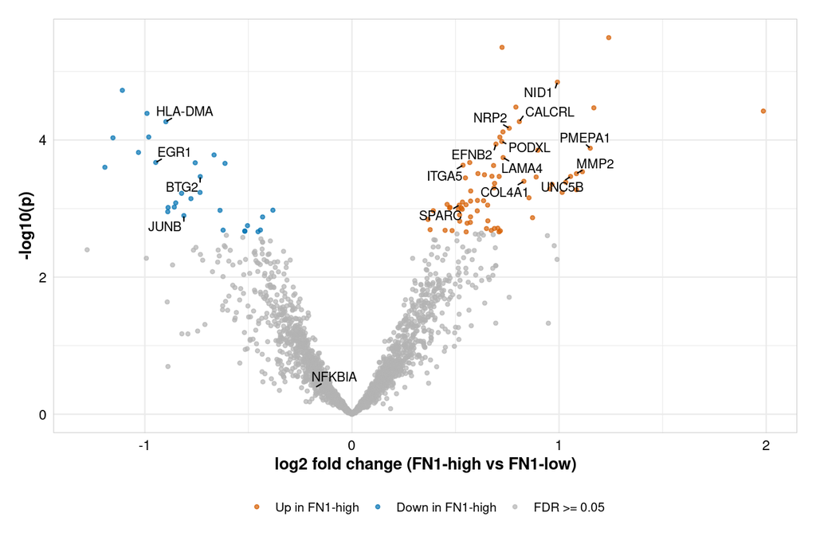

Figure 64: Pooled pseudobulk contrast of FN1-high against FN1-low samples in endothelial cells (65 samples from three cohorts). Genes at FDR below 0.05 are colored; labeled genes are those discussed in the text.

```r
volcano_labels <- c("NID1", "LAMA4", "COL4A1", "MMP2", "SPARC", "NRP2", "UNC5B", "EFNB2", "PODXL", "CALCRL", "PMEPA1", "ITGA5",
                    "EGR1", "JUNB", "BTG2", "HLA-DMA", "NFKBIA")
volcano_df <- fn1_pooled$de %>%
  mutate(
    status = case_when(FDR < 0.05 & logFC > 0 ~ "Up in FN1-high", FDR < 0.05 & logFC < 0 ~ "Down in FN1-high", TRUE ~ "FDR >= 0.05"),
    status = factor(status, levels = c("Up in FN1-high", "Down in FN1-high", "FDR >= 0.05"))
  )
ggplot(volcano_df, aes(x = logFC, y = -log10(PValue), color = status)) +
  geom_point(size = 1.2, alpha = 0.7) +
  ggrepel::geom_text_repel(data = volcano_df %>% filter(gene %in% volcano_labels), aes(label = gene),
                           color = "black", size = 3.6, max.overlaps = Inf, min.segment.length = 0) +
  scale_color_manual(values = c("Up in FN1-high" = "#D55E00", "Down in FN1-high" = "#0072B2", "FDR >= 0.05" = "grey70")) +
  labs(x = "log2 fold change (FN1-high vs FN1-low)", y = "-log10(p)", color = NULL) +
  theme_publication() +
  theme(legend.position = "bottom")
```

FN1-high endothelium shows two coordinated changes.

- **Up:** a basement-membrane and angiogenic remodeling program: NID1, LAMA4, COL4A1, MMP2 and SPARC, the guidance and sprouting receptors NRP2, UNC5B, EFNB2, PODXL and CALCRL, the TGF-β target PMEPA1, and the α5 integrin subunit ITGA5 itself (log fold change 0.54, FDR 0.019).
- **Down:** the immediate-early genes EGR1, JUNB and BTG2, and the endothelial MHC-II program. CIITA and the RFX complex are the strongest TF changes, together with HLA-DMA.

There is no NF-κB signal: NFKBIA changes by -0.18 log2 units (FDR 0.67). The immediate-early genes that appeared among the per-cohort top targets were ranked by absolute fold change on nominal gene lists, which hid their direction. In the pooled analysis they go down. In the NicheNet ligand-activity analysis, FN1 ranks 130 of 727 potential ligands, at percentile 82, behind collagens, MMP14, TGF-β and VEGFA. That points to a fibroblast-derived matrix niche acting on the endothelium as a whole, of which FN1 is one component. Some of the up-regulated genes are usually fibroblast or mural transcripts (THY1, MMP14 and COL6A2), and NID1, SPARC, MMP2 and COL4A1 are also expressed by fibroblasts. In stroma-rich FN1-high tumors they may reflect ambient RNA or contaminating cells in the endothelial pseudobulk, so we rest the interpretation on the endothelial-enriched genes NRP2, UNC5B, EFNB2, PODXL and CALCRL and on the CIITA/MHC-II program.

Our reading is that FN1-high microenvironments are associated with an endothelial program of basement-membrane remodeling and angiogenic sprouting, together with a reduced endothelial MHC-II antigen-presentation program. The second element was not anticipated, and it links to the finding of the section “Tumor microenvironment deconvolution” that FN1-ITGA5/ITGB1 is the only axis negatively correlated with CD8+ T cells. We treat that link as a hypothesis.

Among the other axes:

- CCL5-ACKR1 and MDK-LRP1 have no gene at FDR below 0.05 even with about 67 samples.
- The 34 CXCL12-CXCR4 genes in T cells are dominated by luminal epithelial transcripts (TFF3, TRPS1, SLC39A6, STARD10 and GSTM3), which suggests ambient RNA or contamination in stroma-rich samples more than a T-cell response. We do not interpret them.
- The two APP-CD74 genes are immunoglobulin transcripts.

## ACKR1 as a non-signaling reference axis

ACKR1 is an atypical chemokine receptor. It transports chemokines across endothelial cells and presents them on the luminal surface, and it lacks the intracellular domain for G-protein signaling. A transcriptional program downstream of CCL5-ACKR1 engagement is therefore not expected. The pooled analysis has no gene at FDR below 0.05, although nine TF activities pass, all higher in CCL5-high samples and pointing to an interferon and MHC class II state (CIITA, IRF1 and STAT1, among others). We use CCL5-ACKR1 as a reference axis whose results describe the neighborhood of T-cell-rich venules and not a signaling cascade. The nominal, ligand-associated programs in the per-cohort analyses are of an interferon and inflammatory endothelial state (TNFSF10, IFITM1 and IFI16 in Pal, IL6, BIRC3 and IFIT3 in Wu, STAT1, MX1 and ISG15 in Qian), which co-occurs with CCL5-producing T cells, in line with T-cell-infiltrated, inflamed vasculature. We describe these as ligand-associated receiver programs, and we read the lack of a pooled signal as consistent with an axis that moves cells and chemokines and does not alter endothelial transcription.

Power limits all of these results. Qian has 14 samples, with 4 to 7 per group, and Wu 22 to 25 usable samples, so a null result here is weak evidence of absence.

## Pathway scores and survival

The programs above can also be scored and tested against survival, which is done in the section “Clinical associations”.

# Tumor vs normal tissue

Do the axes also describe normal breast tissue? We address this in bulk with patient-matched TCGA samples, and at the single-cell level with normal breast samples from the Pal cohort.

## TCGA tumors against adjacent normal tissue

The TCGA expression on disk is the PanCancer Atlas release (`brca_tcga_pan_can_atlas_2018`, batch-normalized RSEM). Its adjacent-normal profiles come from the same release, so tumor and normal samples are normalized identically: library-size scaling to counts per million, then log2(CPM + 1). The comparison is paired by patient (114 tumor-normal pairs) and uses a Wilcoxon signed-rank test with Benjamini-Hochberg correction across the genes and axis scores.

```r
read_rsem_cpm <- function(path) {
  raw <- fread(path)
  raw <- raw[Hugo_Symbol != "" & !is.na(Hugo_Symbol)]
  raw <- raw[!duplicated(Hugo_Symbol)]
  m <- as.matrix(raw[, -c("Hugo_Symbol", "Entrez_Gene_Id"), with = FALSE])
  rownames(m) <- raw$Hugo_Symbol
  m <- apply(m, 2, function(x) x / sum(x, na.rm = TRUE) * 1e6)
  rownames(m)[rownames(m) == "DARC"] <- "ACKR1"
  rownames(m)[rownames(m) == "IL8"] <- "CXCL8"
  log2(m + 1)
}
tn_genes <- c("CCL5", "ACKR1", "FN1", "ITGA5", "ITGB1", "CXCL12", "CXCR4", "MDK", "LRP1", "APP", "CD74")
tcga_normal_log <- read_rsem_cpm("data/ext/brca_tcga/normals/data_mrna_seq_v2_rsem_normal_samples.txt")[tn_genes, ]
tcga_tumour_log <- read_rsem_cpm("data/ext/brca_tcga/data_mrna_seq_v2_rsem.txt")[tn_genes, ]

pairs <- tibble::tibble(normal = colnames(tcga_normal_log), patient = substr(normal, 1, 12)) %>%
  inner_join(tibble::tibble(tumour = colnames(tcga_tumour_log), patient = substr(tumour, 1, 12)), by = "patient") %>%
  distinct(patient, .keep_all = TRUE)

feature_values <- function(m) {
  out <- as.data.frame(t(m))
  out$ITGA5_ITGB1 <- (out$ITGA5 + out$ITGB1) / 2
  for (i in seq_len(nrow(candidate_registry))) {
    out[[paste0("score_", candidate_registry$axis_id[i])]] <- (out[[candidate_registry$ligand[i]]] + out[[candidate_registry$receptor[i]]]) / 2
  }
  out
}
tum_feat <- feature_values(tcga_tumour_log[, pairs$tumour])
norm_feat <- feature_values(tcga_normal_log[, pairs$normal])

tn_res <- bind_rows(lapply(colnames(tum_feat), function(f) {
  d <- tum_feat[[f]] - norm_feat[[f]]
  wt <- wilcox.test(tum_feat[[f]], norm_feat[[f]], paired = TRUE)
  data.frame(feature = f, n_pairs = length(d), median_tumour = median(tum_feat[[f]]), median_normal = median(norm_feat[[f]]),
             median_log2fc = median(d), frac_tumour_higher = mean(d > 0), p = wt$p.value)
})) %>% mutate(q_bh = p.adjust(p, method = "BH"))
write_csv(tn_res, "results/revision/tcga_tumour_vs_adjacent_normal.csv")
knitr::kable(tn_res %>% rename_with(~ sub("tumour", "tumor", .x)), digits = 4, caption = sprintf("TCGA tumor vs patient-matched adjacent normal (%d pairs; paired Wilcoxon, BH)", nrow(pairs)))
```

TCGA tumor vs patient-matched adjacent normal (114 pairs; paired Wilcoxon, BH)

| feature | n_pairs | median_tumor | median_normal | median_log2fc | frac_tumor_higher | p | q_bh |
| --- | --- | --- | --- | --- | --- | --- | --- |
| CCL5 | 114 | 4.7182 | 4.5730 | 0.1557 | 0.5263 | 0.2053 | 0.2093 |
| ACKR1 | 114 | 3.5683 | 6.8598 | -3.1014 | 0.0789 | 0.0000 | 0.0000 |
| FN1 | 114 | 12.5375 | 9.1402 | 3.0621 | 0.9737 | 0.0000 | 0.0000 |
| ITGA5 | 114 | 6.9122 | 6.6418 | 0.3506 | 0.6404 | 0.0012 | 0.0015 |
| ITGB1 | 114 | 9.4252 | 9.8477 | -0.3990 | 0.2632 | 0.0000 | 0.0000 |
| CXCL12 | 114 | 6.8725 | 8.9306 | -2.0158 | 0.0877 | 0.0000 | 0.0000 |
| CXCR4 | 114 | 6.3104 | 5.4005 | 0.8757 | 0.8333 | 0.0000 | 0.0000 |
| MDK | 114 | 6.8679 | 6.2848 | 0.8090 | 0.7018 | 0.0000 | 0.0000 |
| LRP1 | 114 | 8.5805 | 9.9214 | -1.4431 | 0.1579 | 0.0000 | 0.0000 |
| APP | 114 | 10.1610 | 10.6912 | -0.5272 | 0.2807 | 0.0000 | 0.0000 |
| CD74 | 114 | 10.6457 | 10.3669 | 0.2238 | 0.6228 | 0.0189 | 0.0230 |
| ITGA5_ITGB1 | 114 | 8.1824 | 8.3295 | -0.1586 | 0.4298 | 0.1830 | 0.2074 |
| score_cxcl12_cxcr4 | 114 | 6.6119 | 7.1642 | -0.4052 | 0.2895 | 0.0000 | 0.0000 |
| score_ccl5_ackr1 | 114 | 4.2359 | 5.6768 | -1.4858 | 0.2018 | 0.0000 | 0.0000 |
| score_mdk_lrp1 | 114 | 7.6554 | 8.0328 | -0.2609 | 0.3684 | 0.0005 | 0.0007 |
| score_fn1_itga5_itgb1 | 114 | 10.3373 | 8.7644 | 1.4418 | 0.9298 | 0.0000 | 0.0000 |
| score_app_cd74 | 114 | 10.4059 | 10.5088 | -0.0762 | 0.4561 | 0.2093 | 0.2093 |

FN1 is higher in the tumor in 97% of pairs, by a median of 3.1 log2 units, and the FN1-ITGA5/ITGB1 score is higher by 1.44, with ITGA5 up and ITGB1 slightly down. ACKR1 goes the other way: it is lower in the tumor in 92% of pairs, by 3.1 log2 units, while CCL5 is unchanged, so the CCL5-ACKR1 score is lower in tumors (-1.49). CXCL12 and LRP1 are lower in tumors and CXCR4 and MDK are higher (Figure 65). The lower ACKR1 expression in bulk tumors reflects, at least in part, the venule-rich architecture of normal breast tissue.

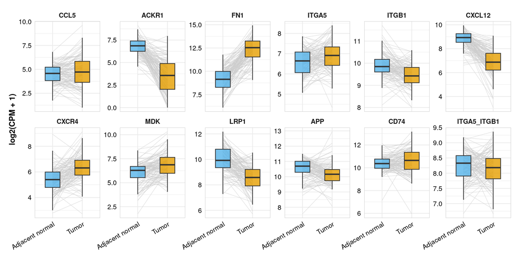

Figure 65: Expression of the axis genes in TCGA tumors and patient-matched adjacent normal tissue. Lines connect the two samples of a patient.

```r
tn_plot_df <- bind_rows(
  tum_feat %>% mutate(patient = pairs$patient, tissue = "Tumour"),
  norm_feat %>% mutate(patient = pairs$patient, tissue = "Adjacent normal")
) %>%
  select(patient, tissue, all_of(c(tn_genes, "ITGA5_ITGB1"))) %>%
  tidyr::pivot_longer(-c(patient, tissue), names_to = "gene", values_to = "log2cpm") %>%
  mutate(tissue = factor(recode(tissue, Tumour = "Tumor"), levels = c("Adjacent normal", "Tumor")), gene = factor(gene, levels = c(tn_genes, "ITGA5_ITGB1")))
p_tn <- ggplot(tn_plot_df, aes(x = tissue, y = log2cpm)) +
  geom_line(aes(group = patient), color = "grey80", linewidth = 0.2) +
  geom_boxplot(aes(fill = tissue), width = 0.5, outlier.shape = NA, alpha = 0.8) +
  facet_wrap(~gene, scales = "free_y", nrow = 2) +
  scale_fill_manual(values = c("Adjacent normal" = "#56B4E9", "Tumor" = "#E69F00")) +
  labs(x = NULL, y = "log2(CPM + 1)") +
  theme_publication() +
  theme(legend.position = "none", axis.text.x = element_text(angle = 30, hjust = 1))
ggsave("results/revision/fig_tcga_tumour_vs_normal.png", p_tn, width = 12, height = 6, dpi = 300)
p_tn
```

## Normal breast tissue in the Pal cohort

The Pal cohort also profiled 13 normal breast samples (“Total” fraction) from women who had reduction mammoplasty, who are different women from the tumor patients. We process them with the tumor QC and integration settings, which gives 45,807 singlets from 63,970 raw cells. The Figshare annotation mapping covers tumors only, so we transfer labels from the annotated Pal tumor sketch with Seurat anchors. Reduction mammoplasty tissue contains no malignant cells, so we merge the “Cancer” predictions into `Normal_epithelial`. The cells are sketched to 20,000 and run through CellChat with the original settings. Because the donors are not the tumor patients, the comparison with tumors is unpaired.

```r
suppressMessages({
  library(dplyr)
  library(readr)
  library(qs2)
  library(Matrix)
  library(Seurat)
  library(harmony)
  library(scDblFinder)
  library(SingleCellExperiment)
  library(CellChat)
})

set.seed(42)
raw_dir <- "data/raw/BCS010_normal"
dir.create(raw_dir, recursive = TRUE, showWarnings = FALSE)
dir.create("objects/revision", recursive = TRUE, showWarnings = FALSE)

# Normal "Total" (unsorted) samples only, matching the tumor selection on cell population = Total
tar_members <- untar("data/GSE161529_RAW.tar", list = TRUE)
normal_members <- tar_members[grepl("_N-.*-Total-(matrix|barcodes)", tar_members)]
if (!all(file.exists(file.path(raw_dir, normal_members)))) {
  untar("data/GSE161529_RAW.tar", files = normal_members, exdir = raw_dir)
}
file.copy("data/raw/BCS010/GSE161529_features.tsv.gz", raw_dir, overwrite = FALSE)
normal_gsm <- unique(sub("_.*", "", normal_members))
message(sprintf("Normal Total samples: %d", length(normal_gsm)))

filtered_path <- "objects/revision/seu_pal_normal_filtered.qs2"
if (file.exists(filtered_path)) {
  seu_norm <- qs_read(filtered_path)
} else {
  features <- read.table(file.path(raw_dir, "GSE161529_features.tsv.gz"), sep = "\t", header = FALSE, stringsAsFactors = FALSE)
  norm_objects <- list()
  norm_stats <- list()
  for (gsm in normal_gsm) {
    files <- list.files(raw_dir, full.names = TRUE)
    mat <- readMM(files[grep(paste0("^", gsm, ".*matrix.mtx.gz$"), basename(files))])
    barcodes <- readLines(files[grep(paste0("^", gsm, ".*barcodes.tsv.gz$"), basename(files))])
    rownames(mat) <- make.unique(features$V2)
    colnames(mat) <- paste0(gsm, "_", barcodes)
    title <- sub("^GSM[0-9]+_", "", basename(files[grep(paste0("^", gsm, ".*matrix.mtx.gz$"), basename(files))]))

    seu <- CreateSeuratObject(counts = mat, project = gsm)
    seu$sample_id <- gsm
    seu$patient_id <- paste0("PalN_", sub("-Total.*", "", sub("^N-", "", title)))
    seu$cohort <- "Pal_normal"
    seu[["percent.mt"]] <- PercentageFeatureSet(seu, pattern = "^MT-")

    feat_lim <- get_mad_limits(seu$nFeature_RNA, nmads = 3)
    count_lim <- get_mad_limits(seu$nCount_RNA, nmads = 3)
    mt_lim <- get_mad_limits(seu$percent.mt, nmads = 3)
    feat_lower <- max(feat_lim$lower, 200)
    feat_upper <- feat_lim$upper
    count_upper <- count_lim$upper
    mt_upper <- min(max(mt_lim$upper, 5), 15)
    n_raw <- ncol(seu)

    seu_qc <- subset(
      seu,
      subset = nFeature_RNA >= feat_lower &
               nFeature_RNA <= feat_upper &
               nCount_RNA <= count_upper &
               percent.mt <= mt_upper
    )
    if (ncol(seu_qc) > 10) {
      sce <- as.SingleCellExperiment(seu_qc)
      sce <- scDblFinder(sce, BPPARAM = BiocParallel::MulticoreParam(workers = 16))
      seu_qc$doublet_class <- sce$scDblFinder.class
      seu_final <- subset(seu_qc, doublet_class == "singlet")
    } else {
      seu_final <- seu_qc
    }
    norm_stats[[gsm]] <- data.frame(sample = gsm, cells_raw = n_raw, cells_qc = ncol(seu_qc), cells_final = ncol(seu_final))
    norm_objects[[gsm]] <- seu_final
  }
  write_csv(bind_rows(norm_stats), "results/revision/pal_normal_qc_stats.csv")
  seu_norm <- merge(norm_objects[[1]], norm_objects[-1])
  seu_norm <- JoinLayers(seu_norm)
  qs_save(seu_norm, filtered_path)
}

integrated_path <- "objects/revision/seu_pal_normal_integrated.qs2"
if (file.exists(integrated_path)) {
  seu_norm <- qs_read(integrated_path)
} else {
  seu_norm <- NormalizeData(seu_norm)
  seu_norm <- FindVariableFeatures(seu_norm, nfeatures = 2000)
  seu_norm <- ScaleData(seu_norm)
  seu_norm <- RunPCA(seu_norm, npcs = 30)
  seu_norm <- RunHarmony(seu_norm, group.by.vars = "patient_id", max_iter = 10)
  seu_norm <- RunUMAP(seu_norm, reduction = "harmony", dims = 1:30, reduction.name = "umap_after")
  seu_norm <- FindNeighbors(seu_norm, reduction = "harmony", dims = 1:30)
  seu_norm <- FindClusters(seu_norm, resolution = 0.8)
  qs_save(seu_norm, integrated_path)
}

# The Figshare mappings cover tumors only, so labels are transferred from the annotated Pal tumor sketch
harmonized_path <- "objects/revision/seu_pal_normal_harmonized_20000.qs2"
if (file.exists(harmonized_path)) {
  seu_norm <- qs_read(harmonized_path)
} else {
  seu_ref <- qs_read("objects/seu_pal_harmonized_20000.qs2")
  seu_ref <- subset(seu_ref, cells = colnames(seu_ref[["sketch"]]))
  DefaultAssay(seu_ref) <- "sketch"
  seu_ref[["RNA"]] <- NULL
  seu_ref <- ScaleData(seu_ref, verbose = FALSE)
  seu_ref <- RunPCA(seu_ref, npcs = 30, verbose = FALSE)

  anchors <- FindTransferAnchors(reference = seu_ref, query = seu_norm, dims = 1:30, reference.reduction = "pca")
  pred <- TransferData(anchorset = anchors, refdata = seu_ref$harmonized_label, dims = 1:30)
  seu_norm$transfer_label <- pred[colnames(seu_norm), "predicted.id"]
  seu_norm$transfer_score <- pred[colnames(seu_norm), "prediction.score.max"]
  # Normal reduction mammoplasty tissue contains no malignant cells
  seu_norm$harmonized_label <- ifelse(seu_norm$transfer_label == "Cancer", "Normal_epithelial", seu_norm$transfer_label)
  rm(seu_ref)
  gc()

  seu_norm <- SketchData(object = seu_norm, ncells = min(ncol(seu_norm), 20000), method = "LeverageScore", sketched.assay = "sketch")
  DefaultAssay(seu_norm) <- "sketch"
  seu_norm <- NormalizeData(seu_norm)
  qs_save(seu_norm, harmonized_path)
}

markers <- c("EPCAM", "KRT18", "KRT19", "CD3D", "CD3E", "CD19", "MS4A1", "CD14", "LYZ", "COL1A1", "DCN", "PECAM1", "VWF", "ACTA2", "RGS5")
marker_expr <- AverageExpression(seu_norm, assays = "RNA", features = markers, group.by = "harmonized_label", layer = "data")$RNA
write.csv(round(as.matrix(marker_expr), 3), "results/revision/pal_normal_marker_expression.csv")
write_csv(as.data.frame(table(harmonized_label = seu_norm$harmonized_label, transfer_label = seu_norm$transfer_label)),
          "results/revision/pal_normal_label_counts.csv")

cc_path <- "objects/revision/cc_pal_normal_20000.qs2"
if (!file.exists(cc_path)) {
  seu_sub <- subset(seu_norm, cells = colnames(seu_norm[["sketch"]]))
  data_input <- GetAssayData(seu_sub, assay = "sketch", layer = "data")
  cellchat <- createCellChat(object = data_input, meta = seu_sub@meta.data, group.by = "harmonized_label")
  cellchat@DB <- CellChatDB.human
  cellchat <- subsetData(cellchat)
  cellchat <- identifyOverExpressedGenes(cellchat)
  cellchat <- identifyOverExpressedInteractions(cellchat)
  cellchat <- computeCommunProb(cellchat, raw.use = TRUE)
  cellchat <- filterCommunication(cellchat, min.cells = 10)
  cellchat <- computeCommunProbPathway(cellchat)
  cellchat <- aggregateNet(cellchat)
  qs_save(cellchat, cc_path)
}

# Sample-level co-expression: mean ligand in sender cells x mean receptor in receiver cells (all cells, >= 10 per type)
normal_axes <- tibble::tribble(
  ~axis_id, ~ligand, ~receptor, ~sender_celltype, ~receiver_celltype,
  "cxcl12_cxcr4", "CXCL12", "CXCR4", "Fibroblast", "T_cell",
  "ccl5_ackr1", "CCL5", "ACKR1", "T_cell", "Endothelial",
  "mdk_lrp1", "MDK", "LRP1", "Fibroblast", "Fibroblast",
  "fn1_itga5_itgb1", "FN1", "ITGA5_ITGB1", "Fibroblast", "Endothelial",
  "app_cd74", "APP", "CD74", "Endothelial", "B_cell",
  "app_cd74_myeloid", "APP", "CD74", "Endothelial", "Myeloid"
)

sample_scores <- function(seu, tissue) {
  expr <- GetAssayData(seu, assay = "RNA", layer = "data")
  meta <- seu@meta.data
  out <- list()
  for (i in seq_len(nrow(normal_axes))) {
    rec_genes <- strsplit(normal_axes$receptor[i], "_")[[1]]
    for (smp in unique(meta$sample_id)) {
      send_cells <- rownames(meta)[meta$sample_id == smp & meta$harmonized_label == normal_axes$sender_celltype[i]]
      rec_cells <- rownames(meta)[meta$sample_id == smp & meta$harmonized_label == normal_axes$receiver_celltype[i]]
      if (length(send_cells) < 10 || length(rec_cells) < 10) next
      lig_mean <- mean(expr[normal_axes$ligand[i], send_cells])
      rec_mean <- mean(sapply(rec_genes, function(g) mean(expr[g, rec_cells])))
      out[[length(out) + 1]] <- data.frame(
        axis_id = normal_axes$axis_id[i], tissue = tissue, sample_id = smp,
        n_sender = length(send_cells), n_receiver = length(rec_cells),
        ligand_mean = lig_mean, receptor_mean = rec_mean, coexpression = lig_mean * rec_mean
      )
    }
  }
  bind_rows(out)
}

DefaultAssay(seu_norm) <- "RNA"
scores_normal <- sample_scores(seu_norm, "Normal")
rm(seu_norm)
gc()
seu_tum <- qs_read("objects/seu_pal_harmonized_20000.qs2")
DefaultAssay(seu_tum) <- "RNA"
scores_tumour <- sample_scores(seu_tum, "Tumour")
qs_save(bind_rows(scores_normal, scores_tumour), "objects/revision/pal_normal_tumour_sample_scores.qs2")
message("Normal-tissue pipeline finished")
```

Normal breast has almost no B cells (40 cells in total), which affects the APP-CD74 axis, whose receiver in the registry is the B cell. For that axis we also report the version with myeloid receivers, which is the receiver of the APP-CD74 interaction in the consensus set. We first compare the CellChat communication probability of each axis in tumor and normal, and then a sample-level score of ligand-receptor co-expression: the mean ligand expression in sender cells times the mean receptor expression in receiver cells, in samples with at least 10 cells of each type, tested with a Wilcoxon test and corrected within each measure (Figure 66).

```r
cc_normal <- qs_read("objects/revision/cc_pal_normal_20000.qs2")
cc_tumour <- qs_read("objects/cc_pal_20000.qs2")
normal_qc <- read_csv("results/revision/pal_normal_qc_stats.csv", show_col_types = FALSE)
knitr::kable(normal_qc %>% summarise(samples = n(), raw_cells = sum(cells_raw), post_qc = sum(cells_qc), singlets = sum(cells_final)),
             caption = "Pal normal-breast Total samples: QC attrition")
```

Pal normal-breast Total samples: QC attrition

| samples | raw_cells | post_qc | singlets |
| --- | --- | --- | --- |
| 13 | 63970 | 48713 | 45807 |

```r
knitr::kable(read_csv("results/revision/pal_normal_label_counts.csv", show_col_types = FALSE) %>% filter(Freq > 0),
             caption = "Label transfer from the Pal tumor reference (all normal cells)")
```

Label transfer from the Pal tumor reference (all normal cells)

| harmonized_label | transfer_label | Freq |
| --- | --- | --- |
| B_cell | B_cell | 40 |
| Normal_epithelial | Cancer | 14339 |
| Endothelial | Endothelial | 6435 |
| Fibroblast | Fibroblast | 10569 |
| Myeloid | Myeloid | 1627 |
| Normal_epithelial | Normal_epithelial | 7499 |
| PVL | PVL | 3923 |
| T_cell | T_cell | 1375 |

```r
knitr::kable(read.csv("results/revision/pal_normal_marker_expression.csv", check.names = FALSE), digits = 2,
             caption = "Canonical markers by transferred label (normal tissue)")
```

Canonical markers by transferred label (normal tissue)

|  | B-cell | Endothelial | Fibroblast | Myeloid | Normal-epithelial | PVL | T-cell |
| --- | --- | --- | --- | --- | --- | --- | --- |
| RGS5 | 0.00 | 0.93 | 0.07 | 0.42 | 0.07 | 6.23 | 0.08 |
| EPCAM | 0.18 | 0.08 | 0.06 | 0.13 | 2.30 | 0.06 | 0.26 |
| CD14 | 0.00 | 0.27 | 0.11 | 1.83 | 0.07 | 0.43 | 0.05 |
| MS4A1 | 0.00 | 0.00 | 0.00 | 0.08 | 0.00 | 0.00 | 0.01 |
| CD3E | 0.04 | 0.00 | 0.00 | 0.00 | 0.00 | 0.00 | 1.07 |
| CD3D | 0.00 | 0.01 | 0.00 | 0.00 | 0.00 | 0.00 | 3.73 |
| ACTA2 | 0.00 | 0.09 | 0.25 | 0.10 | 3.31 | 3.70 | 0.14 |
| VWF | 0.00 | 0.93 | 0.01 | 0.01 | 0.00 | 0.01 | 0.01 |
| KRT18 | 0.07 | 0.47 | 0.22 | 0.32 | 9.10 | 0.35 | 1.70 |
| LYZ | 0.00 | 0.00 | 0.00 | 3.40 | 0.01 | 0.00 | 0.01 |
| DCN | 0.00 | 0.21 | 39.57 | 1.78 | 0.11 | 1.25 | 0.54 |
| CD19 | 0.00 | 0.00 | 0.00 | 0.01 | 0.00 | 0.00 | 0.01 |
| KRT19 | 0.02 | 0.30 | 0.21 | 0.36 | 8.67 | 0.22 | 1.66 |
| COL1A1 | 0.00 | 0.02 | 5.79 | 0.07 | 0.06 | 0.22 | 0.04 |
| PECAM1 | 0.03 | 1.75 | 0.01 | 0.18 | 0.01 | 0.01 | 0.02 |

```r
axis_pairs_cc <- bind_rows(
  candidate_registry %>% select(axis_id, ligand, receptor, sender = sender_celltype, receiver = receiver_celltype),
  candidate_registry %>% filter(axis_id == "app_cd74") %>% transmute(axis_id, ligand, receptor, sender = sender_celltype, receiver = "Myeloid")
) %>% mutate(interaction_name = paste(ligand, receptor, sep = "_"))

cc_axis_value <- function(cc, sender, receiver, lr) {
  dn <- dimnames(cc@net$prob)
  if (!(sender %in% dn[[1]] && receiver %in% dn[[2]] && lr %in% dn[[3]])) return(c(prob = 0, pval = NA_real_))
  c(prob = cc@net$prob[sender, receiver, lr], pval = cc@net$pval[sender, receiver, lr])
}
nt_cc <- axis_pairs_cc %>%
  rowwise() %>%
  mutate(
    prob_tumour = cc_axis_value(cc_tumour, sender, receiver, interaction_name)[["prob"]],
    pval_tumour = cc_axis_value(cc_tumour, sender, receiver, interaction_name)[["pval"]],
    prob_normal = cc_axis_value(cc_normal, sender, receiver, interaction_name)[["prob"]],
    pval_normal = cc_axis_value(cc_normal, sender, receiver, interaction_name)[["pval"]]
  ) %>%
  ungroup() %>%
  mutate(log2_ratio_tumour_normal = log2((prob_tumour + 1e-6) / (prob_normal + 1e-6)))
write_csv(nt_cc, "results/revision/pal_normal_vs_tumour_cellchat.csv")
knitr::kable(nt_cc %>% mutate(Axis = axis_labels[axis_id]) %>% select(Axis, sender, receiver, prob_tumour, pval_tumour, prob_normal, pval_normal, log2_ratio_tumour_normal) %>% rename_with(~ sub("tumour", "tumor", .x)),
             digits = 4, caption = "CellChat communication probability of each axis in Pal tumor vs Pal normal breast (same settings, 20,000-cell sketches)")
```

CellChat communication probability of each axis in Pal tumor vs Pal normal breast (same settings, 20,000-cell sketches)

| Axis | sender | receiver | prob_tumor | pval_tumor | prob_normal | pval_normal | log2_ratio_tumor_normal |
| --- | --- | --- | --- | --- | --- | --- | --- |
| CXCL12-CXCR4 | Fibroblast | T_cell | 0.0378 | 0 | 0.0302 | 0 | 0.3240 |
| CCL5-ACKR1 | T_cell | Endothelial | 0.0228 | 0 | 0.0051 | 0 | 2.1556 |
| MDK-LRP1 | Fibroblast | Fibroblast | 0.0102 | 0 | 0.0000 | 1 | 13.3206 |
| FN1-ITGA5/ITGB1 | Fibroblast | Endothelial | 0.0808 | 0 | 0.0071 | 0 | 3.5098 |
| APP-CD74 | Endothelial | B_cell | 0.0637 | 0 | 0.0268 | 0 | 1.2526 |
| APP-CD74 | Endothelial | Myeloid | 0.1605 | 0 | 0.0633 | 0 | 1.3418 |

```r
nt_scores <- qs_read("objects/revision/pal_normal_tumour_sample_scores.qs2")
nt_tests <- nt_scores %>%
  tidyr::pivot_longer(c(ligand_mean, receptor_mean, coexpression), names_to = "measure", values_to = "value") %>%
  group_by(axis_id, measure) %>%
  summarise(
    n_tumour = sum(tissue == "Tumour"), n_normal = sum(tissue == "Normal"),
    median_tumour = median(value[tissue == "Tumour"]), median_normal = median(value[tissue == "Normal"]),
    p = if (n_tumour >= 3 && n_normal >= 3) wilcox.test(value[tissue == "Tumour"], value[tissue == "Normal"])$p.value else NA_real_,
    .groups = "drop"
  ) %>%
  group_by(measure) %>%
  mutate(q_bh = p.adjust(p, method = "BH")) %>%
  ungroup() %>%
  mutate(log2_ratio = log2(median_tumour / median_normal))
write_csv(nt_tests, "results/revision/pal_normal_vs_tumour_sample_scores.csv")
nt_label <- c(axis_labels, app_cd74_myeloid = "APP-CD74 (to Myeloid)")
knitr::kable(nt_tests %>% mutate(Axis = nt_label[axis_id]) %>% select(Axis, measure, everything(), -axis_id) %>% rename_with(~ sub("tumour", "tumor", .x)), digits = 4,
             caption = "Sample-level sender ligand, receiver receptor and co-expression (ligand x receptor) in Pal tumors vs normal breast (Wilcoxon, BH within measure)")
```

Sample-level sender ligand, receiver receptor and co-expression (ligand x receptor) in Pal tumors vs normal breast (Wilcoxon, BH within measure)

| Axis | measure | n_tumor | n_normal | median_tumor | median_normal | p | q_bh | log2_ratio |
| --- | --- | --- | --- | --- | --- | --- | --- | --- |
| APP-CD74 | coexpression | 16 | 1 | 2.6122 | 1.0589 | NA | NA | 1.3027 |
| APP-CD74 | ligand_mean | 16 | 1 | 1.5674 | 1.1179 | NA | NA | 0.4876 |
| APP-CD74 | receptor_mean | 16 | 1 | 1.5485 | 0.9472 | NA | NA | 0.7091 |
| APP-CD74 (to Myeloid) | coexpression | 29 | 12 | 5.3331 | 1.9119 | 0.0000 | 0.0000 | 1.4800 |
| APP-CD74 (to Myeloid) | ligand_mean | 29 | 12 | 1.5521 | 0.9789 | 0.0006 | 0.0008 | 0.6649 |
| APP-CD74 (to Myeloid) | receptor_mean | 29 | 12 | 3.7670 | 1.8143 | 0.0000 | 0.0000 | 1.0539 |
| CCL5-ACKR1 | coexpression | 29 | 13 | 0.9790 | 0.3253 | 0.0094 | 0.0117 | 1.5897 |
| CCL5-ACKR1 | ligand_mean | 29 | 13 | 1.5410 | 0.4974 | 0.0006 | 0.0008 | 1.6313 |
| CCL5-ACKR1 | receptor_mean | 29 | 13 | 0.8015 | 0.7959 | 0.8932 | 0.8932 | 0.0102 |
| CXCL12-CXCR4 | coexpression | 32 | 13 | 1.6319 | 1.0313 | 0.1246 | 0.1246 | 0.6621 |
| CXCL12-CXCR4 | ligand_mean | 32 | 13 | 0.9783 | 0.4239 | 0.0020 | 0.0020 | 1.2066 |
| CXCL12-CXCR4 | receptor_mean | 32 | 13 | 1.8070 | 2.0871 | 0.7573 | 0.8932 | -0.2079 |
| FN1-ITGA5/ITGB1 | coexpression | 29 | 13 | 3.0015 | 0.4171 | 0.0000 | 0.0000 | 2.8471 |
| FN1-ITGA5/ITGB1 | ligand_mean | 29 | 13 | 2.6816 | 0.4094 | 0.0000 | 0.0000 | 2.7114 |
| FN1-ITGA5/ITGB1 | receptor_mean | 29 | 13 | 1.0888 | 0.9725 | 0.1849 | 0.3082 | 0.1629 |
| MDK-LRP1 | coexpression | 32 | 13 | 1.0318 | 0.1225 | 0.0000 | 0.0000 | 3.0746 |
| MDK-LRP1 | ligand_mean | 32 | 13 | 1.1098 | 0.2914 | 0.0000 | 0.0000 | 1.9293 |
| MDK-LRP1 | receptor_mean | 32 | 13 | 0.8373 | 0.3456 | 0.0000 | 0.0001 | 1.2766 |

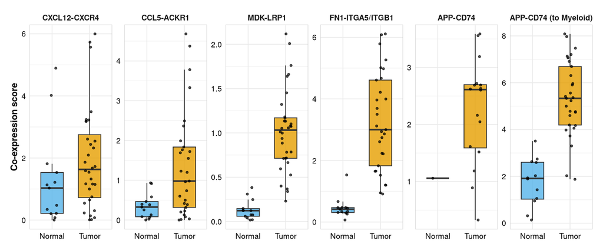

Figure 66: Sample-level co-expression of the ligand and receptor of each axis in Pal normal breast and tumor samples. Each point is a sample; the score is the mean log-normalized ligand in sender cells times the mean receptor in receiver cells.

```r
p_nt <- nt_scores %>%
  mutate(Axis = factor(nt_label[axis_id], levels = nt_label), tissue = factor(recode(tissue, Tumour = "Tumor"), levels = c("Normal", "Tumor"))) %>%
  ggplot(aes(x = tissue, y = coexpression, fill = tissue)) +
  geom_boxplot(outlier.shape = NA, alpha = 0.8, width = 0.6) +
  geom_jitter(width = 0.15, size = 1.2, alpha = 0.7) +
  facet_wrap(~Axis, scales = "free_y", nrow = 1) +
  scale_fill_manual(values = c("Normal" = "#56B4E9", "Tumor" = "#E69F00")) +
  labs(x = NULL, y = "Co-expression score") +
  theme_publication() +
  theme(legend.position = "none")
ggsave("results/revision/fig_pal_normal_vs_tumour.png", p_nt, width = 14, height = 5, dpi = 300)
p_nt
```

At the single-cell level, FN1-ITGA5/ITGB1 communication is 11-fold higher in tumors than in normal breast (probability 0.081 against 0.007) and CCL5-ACKR1 is 4.5-fold higher. MDK-LRP1 is detected only in tumors, and APP-CD74 toward myeloid cells is higher in tumors. CXCL12-CXCR4 differs little. At the sample level, the FN1-ITGA5/ITGB1 co-expression score is higher in tumors by 2.85 log2 units (q = 3.7 × 10<sup>-9</sup>), and the difference comes from fibroblast FN1, while endothelial ITGA5 and ITGB1 are unchanged. For CCL5-ACKR1 the score is higher by 1.59 log2 units (q = 0.012), driven by T-cell CCL5, with per-cell ACKR1 in endothelial cells preserved.

FN1-ITGA5/ITGB1 is higher in breast cancer at both levels, and fibroblast fibronectin drives the increase. CCL5-ACKR1 communication is higher in tumors in single cells, driven by T cells, while ACKR1 is lower in bulk tumors compared with the venule-rich normal breast. A reading that fits both is that tumors which keep the ACKR1-positive venular niche, and T cells that deliver CCL5 to it, fare better, which is the protective reading of the survival results below. The caveats are that Wu and Qian have no normal samples, the Pal normal donors are unpaired with the tumor patients, and the TCGA “normal” tissue is tumor-adjacent.

# Spatial co-localization

Single-cell inference says which cell types could talk to each other. It does not say whether they are neighbors. We use spatial transcriptomics to ask whether the senders and receivers of each axis sit next to each other in tissue, and whether the ligand and receptor are co-expressed where they do. Co-localization supports but does not prove ligand-receptor engagement, because Visium spots hold several cells and a ligand and a receptor can be expressed near each other without binding.

## Visium sections from Wu et al.

We use the six Visium sections of Wu et al. (1142243F, 1160920F, CID4290, CID4465, CID44971 and CID4535). Four of them (CID4290, CID4465, CID44971 and CID4535) come from patients who are also in the Wu single-cell cohort, so they corroborate the discovery data but do not form an independent test. The FN1-ITGA5/ITGB1 axis is the primary hypothesis, CCL5-ACKR1 is the key secondary hypothesis, and the three remaining axes are exploratory.

### Data and spot quality control

In-tissue spots of the filtered count matrices are kept, apart from spots the pathologist annotated “Artefact” and spots with fewer than 500 UMIs or 250 detected genes. Expression is log-normalized per section (`LogNormalize`, scale factor 10,000), and the ITGA5_ITGB1 receptor is the mean of the log-normalized ITGA5 and ITGB1 values, matching the bulk definition.

```r
library(Matrix)

spatial_dir <- "data/spatial/wu2021_visium"
spatial_obj_dir <- "objects/revision/spatial"
spatial_res_dir <- "results/revision/spatial"
dir.create(spatial_obj_dir, recursive = TRUE, showWarnings = FALSE)
dir.create(spatial_res_dir, recursive = TRUE, showWarnings = FALSE)

section_ids <- c("1142243F", "1160920F", "CID4290", "CID4465", "CID44971", "CID4535")
wu_sc_samples <- list.dirs("data/raw/BCS014", full.names = FALSE, recursive = FALSE)
sections_path <- file.path(spatial_obj_dir, "visium_sections.qs2")

if (file.exists(sections_path)) {
  visium <- qs_read(sections_path)
} else {
  visium <- lapply(setNames(section_ids, section_ids), function(sid) {
    mdir <- file.path(spatial_dir, "filtered_count_matrices", paste0(sid, "_filtered_count_matrix"))
    counts <- as(readMM(file.path(mdir, "matrix.mtx.gz")), "CsparseMatrix")
    rownames(counts) <- make.unique(readLines(file.path(mdir, "features.tsv.gz")))
    colnames(counts) <- readLines(file.path(mdir, "barcodes.tsv.gz"))

    pos <- read_csv(file.path(spatial_dir, "spatial", paste0(sid, "_spatial"), "tissue_positions_list.csv"),
                    col_names = c("barcode", "in_tissue", "array_row", "array_col", "pxl_row", "pxl_col"), show_col_types = FALSE)
    ann <- read_csv(file.path(spatial_dir, "metadata", paste0(sid, "_metadata.csv")), show_col_types = FALSE, name_repair = "unique_quiet") %>%
      transmute(barcode = `...1`, subtype, classification = Classification)
    spots <- tibble(barcode = colnames(counts), n_umi = colSums(counts), n_genes = colSums(counts > 0)) %>%
      left_join(pos, by = "barcode") %>%
      left_join(ann, by = "barcode") %>%
      mutate(qc_pass = in_tissue == 1 & !classification %in% "Artefact" & n_umi >= 500 & n_genes >= 250)

    keep <- spots$qc_pass
    list(counts = counts[, keep], spots = spots[keep, ], spots_all = spots,
         scalef = jsonlite::fromJSON(file.path(spatial_dir, "spatial", paste0(sid, "_spatial"), "scalefactors_json.json")))
  })
  qs_save(visium, sections_path)
}

spatial_qc <- bind_rows(lapply(names(visium), function(sid) {
  s <- visium[[sid]]$spots_all
  tibble(
    section = sid,
    subtype = unique(na.omit(s$subtype))[1],
    in_scrna_cohort = sid %in% wu_sc_samples | paste0(sid, "A") %in% wu_sc_samples,
    scrna_sample = c(intersect(c(sid, paste0(sid, "A")), wu_sc_samples), NA)[1],
    spots_in_tissue = sum(s$in_tissue == 1),
    spots_artefact = sum(s$classification %in% "Artefact"),
    spots_low_quality = sum(s$in_tissue == 1 & !s$classification %in% "Artefact" & (s$n_umi < 500 | s$n_genes < 250)),
    spots_qc = sum(s$qc_pass),
    median_umi = median(s$n_umi[s$qc_pass]),
    median_genes = median(s$n_genes[s$qc_pass]),
    genes_measured = nrow(visium[[sid]]$counts)
  )
}))
write_csv(spatial_qc, file.path(spatial_res_dir, "table_spatial_qc.csv"))
knitr::kable(spatial_qc, caption = "Wu et al. Visium sections: subtype, overlap with the scRNA-seq cohort and spot QC")
```

Wu et al. Visium sections: subtype, overlap with the scRNA-seq cohort and spot QC

| section | subtype | in_scrna_cohort | scrna_sample | spots_in_tissue | spots_artefact | spots_low_quality | spots_qc | median_umi | median_genes | genes_measured |
| --- | --- | --- | --- | --- | --- | --- | --- | --- | --- | --- |
| 1142243F | TNBC | FALSE | NA | 4784 | 119 | 29 | 4636 | 5458.5 | 2566.0 | 28402 |
| 1160920F | TNBC | FALSE | NA | 4895 | 48 | 5 | 4842 | 11263.5 | 3598.0 | 28402 |
| CID4290 | ER | TRUE | CID4290A | 2426 | 7 | 0 | 2419 | 7875.0 | 3011.0 | 19237 |
| CID4465 | TNBC | TRUE | CID4465 | 1211 | 4 | 0 | 1207 | 11304.0 | 4014.0 | 19237 |
| CID44971 | TNBC | TRUE | CID44971 | 1160 | 1 | 0 | 1159 | 10136.0 | 3777.0 | 19237 |
| CID4535 | ER | TRUE | CID4535 | 1125 | 23 | 0 | 1102 | 12883.0 | 4526.5 | 19237 |

```r
spatial_axis_genes <- c("FN1", "ITGA5", "ITGB1", "CCL5", "ACKR1", "CXCL12", "CXCR4", "MDK", "LRP1", "APP", "CD74")
axis_detection <- bind_rows(lapply(names(visium), function(sid) {
  cnt <- visium[[sid]]$counts
  tibble(section = sid, gene = spatial_axis_genes,
         measured = spatial_axis_genes %in% rownames(cnt),
         pct_spots_detected = sapply(spatial_axis_genes, function(g) if (g %in% rownames(cnt)) round(100 * mean(cnt[g, ] > 0), 1) else NA_real_))
}))
write_csv(axis_detection, file.path(spatial_res_dir, "table_spatial_axis_gene_detection.csv"))
knitr::kable(axis_detection %>% select(section, gene, pct_spots_detected) %>% tidyr::pivot_wider(names_from = section, values_from = pct_spots_detected),
             caption = "Axis genes: percentage of QC spots with at least one UMI")
```

Axis genes: percentage of QC spots with at least one UMI

| gene | 1142243F | 1160920F | CID4290 | CID4465 | CID44971 | CID4535 |
| --- | --- | --- | --- | --- | --- | --- |
| FN1 | 93.1 | 90.4 | 99.7 | 100.0 | 87.5 | 87.4 |
| ITGA5 | 13.0 | 33.3 | 24.1 | 63.5 | 25.8 | 37.3 |
| ITGB1 | 68.3 | 77.8 | 68.5 | 97.5 | 88.8 | 84.5 |
| CCL5 | 29.7 | 83.4 | 5.7 | 75.1 | 48.4 | 63.9 |
| ACKR1 | 0.2 | 13.4 | 1.4 | 8.8 | 21.1 | 14.5 |
| CXCL12 | 22.2 | 20.0 | 50.6 | 59.2 | 56.9 | 47.6 |
| CXCR4 | 37.6 | 48.6 | 26.2 | 65.5 | 71.2 | 67.2 |
| MDK | 85.0 | 87.8 | 61.2 | 96.3 | 93.6 | 79.8 |
| LRP1 | 30.8 | 39.8 | 54.7 | 84.3 | 58.9 | 43.5 |
| APP | 97.2 | 73.7 | 81.9 | 90.2 | 85.3 | 89.2 |
| CD74 | 89.1 | 99.5 | 92.8 | 100.0 | 97.5 | 99.0 |

### Deconvolution with RCTD

Each spot holds several cells, so we estimate the cell-type composition of every spot with RCTD (`spacexr`, full mode) against the Wu single-cell data. The reference holds all 77,680 cells that pass QC, labeled with the harmonized taxonomy, except that endothelial cells are split into an ACKR1-positive venular class and the rest, giving nine classes with at most 3,000 randomly sampled cells each (seed 42). Weights are normalized to sum to 1 per spot, and for the FN1 and APP axes the endothelial weight is the sum of the two classes. As a sensitivity analysis, for the four sections whose patient is in the single-cell cohort, RCTD is rerun with a reference that leaves out that patient’s cells. A finer reference, for the exploratory analyses, splits fibroblasts into myCAF-like and iCAF-like cells and T cells into CD8+, CD4+ and other. The RCTD weights are saved to `objects/revision/spatial/rctd_weights.qs2`.

```r
suppressMessages({
  library(dplyr)
  library(readr)
  library(qs2)
  library(Matrix)
  library(SeuratObject)
  library(spacexr)
})

set.seed(42)
num_cores <- parallel::detectCores() - 1
out_dir <- "objects/revision/spatial"
visium <- qs_read(file.path(out_dir, "visium_sections.qs2"))

seu_ref <- qs_read("objects/seu_wu_filtered.qs2")
ref_counts <- LayerData(seu_ref, assay = "RNA", layer = "counts")
ref_sample <- seu_ref$sample_id
rm(seu_ref)

wu_dirs <- list.dirs("data/raw/BCS014", full.names = FALSE, recursive = FALSE)
wu_meta <- bind_rows(lapply(wu_dirs, function(d) {
  read_csv(file.path("data/raw/BCS014", d, "metadata.csv"), show_col_types = FALSE, name_repair = "unique_quiet") %>%
    transmute(barcode = paste0(d, "_", `...1`), celltype_major, celltype_minor)
}))
ref_meta <- wu_meta[match(colnames(ref_counts), wu_meta$barcode), ]

# Eight harmonized classes as in harmonize-wu-labels, with Endothelial split on the ACKR1+ venular subset
label_primary <- case_when(
  ref_meta$celltype_minor == "Endothelial ACKR1" ~ "Endothelial_ACKR1",
  ref_meta$celltype_major == "Endothelial" ~ "Endothelial_other",
  ref_meta$celltype_major == "CAFs" ~ "Fibroblast",
  ref_meta$celltype_major == "PVL" ~ "PVL",
  ref_meta$celltype_major %in% c("B-cells", "Plasmablasts") ~ "B_cell",
  ref_meta$celltype_major == "T-cells" ~ "T_cell",
  ref_meta$celltype_major == "Myeloid" ~ "Myeloid",
  ref_meta$celltype_major == "Normal Epithelial" ~ "Normal_epithelial",
  TRUE ~ "Cancer"
)
# Finer reference for exploratory analysis E3
label_fine <- case_when(
  ref_meta$celltype_minor == "CAFs myCAF-like" ~ "CAF_myCAF",
  ref_meta$celltype_major == "CAFs" ~ "CAF_iCAF",
  ref_meta$celltype_minor == "T cells CD8+" ~ "T_CD8",
  ref_meta$celltype_minor == "T cells CD4+" ~ "T_CD4",
  ref_meta$celltype_major == "T-cells" ~ "T_other",
  TRUE ~ label_primary
)
qs_save(data.frame(barcode = colnames(ref_counts), sample_id = ref_sample, label_primary, label_fine),
        file.path(out_dir, "rctd_reference_labels.qs2"))

build_reference <- function(labels, exclude_sample = NULL) {
  keep <- if (is.null(exclude_sample)) rep(TRUE, length(labels)) else ref_sample != exclude_sample
  set.seed(42)
  cells <- unlist(lapply(split(which(keep), labels[keep]), function(ix) if (length(ix) > 3000) sample(ix, 3000) else ix))
  counts <- ref_counts[, cells]
  Reference(counts, factor(setNames(labels[cells], colnames(counts))), nUMI = colSums(counts), n_max_cells = 3000)
}

run_rctd <- function(section, reference) {
  counts <- section$counts
  coords <- data.frame(x = section$spots$pxl_col, y = -section$spots$pxl_row, row.names = section$spots$barcode)
  puck <- SpatialRNA(coords, counts, nUMI = colSums(counts))
  rctd <- create.RCTD(puck, reference, max_cores = num_cores)
  rctd <- run.RCTD(rctd, doublet_mode = "full")
  as.matrix(normalize_weights(rctd@results$weights))
}

ref_primary <- build_reference(label_primary)
ref_fine <- build_reference(label_fine)

# Sections whose patient is also in the scRNA-seq cohort (Visium CID4290 is scRNA sample CID4290A)
overlap_sample <- c(CID4290 = "CID4290A", CID4465 = "CID4465", CID44971 = "CID44971", CID4535 = "CID4535")

weights_path <- file.path(out_dir, "rctd_weights.qs2")
rctd_weights <- if (file.exists(weights_path)) qs_read(weights_path) else list(primary = list(), fine = list(), lopo = list())
for (sid in names(visium)) {
  if (is.null(rctd_weights$primary[[sid]])) {
    message(sprintf("RCTD primary: %s", sid))
    rctd_weights$primary[[sid]] <- run_rctd(visium[[sid]], ref_primary)
    qs_save(rctd_weights, weights_path)
  }
}
for (sid in names(visium)) {
  if (is.null(rctd_weights$fine[[sid]])) {
    message(sprintf("RCTD fine: %s", sid))
    rctd_weights$fine[[sid]] <- run_rctd(visium[[sid]], ref_fine)
    qs_save(rctd_weights, weights_path)
  }
}
for (sid in names(overlap_sample)) {
  if (is.null(rctd_weights$lopo[[sid]])) {
    message(sprintf("RCTD leave-patient-out: %s", sid))
    rctd_weights$lopo[[sid]] <- run_rctd(visium[[sid]], build_reference(label_primary, exclude_sample = overlap_sample[[sid]]))
    qs_save(rctd_weights, weights_path)
  }
}
message("RCTD done")
```

Before testing anything we inspect the deconvolution. The median dominant-type weight per section and the mean weight of each class by pathologist annotation are reported below (Figure 67). Dominant-type weights have medians of 0.43 to 0.80, and the cancer weight is highest in invasive-cancer spots, as expected. Absolute weights are skewed toward cancer even in stroma, so all tests use within-section ranks or rank correlations.

```r
rctd_weights <- qs_read(file.path(spatial_obj_dir, "rctd_weights.qs2"))

collapse_annotation <- function(x) {
  case_when(
    x %in% c("Stroma", "Stroma + adipose tissue") ~ "Stroma",
    x == "Invasive cancer" ~ "Invasive cancer",
    x == "Invasive cancer + stroma" ~ "Invasive cancer + stroma",
    x %in% c("Invasive cancer + lymphocytes", "Invasive cancer + adipose tissue + lymphocytes", "Cancer trapped in lymphocyte aggregation") ~ "Invasive cancer + lymphocytes",
    x == "Invasive cancer + stroma + lymphocytes" ~ "Invasive cancer + stroma + lymphocytes",
    x %in% c("Lymphocytes", "TLS") ~ "Lymphocytes / TLS",
    x %in% c("Normal glands + lymphocytes", "Normal + stroma + lymphocytes", "Normal duct", "DCIS") ~ "Normal / DCIS",
    TRUE ~ "Other"
  )
}
annotation_levels <- c("Invasive cancer", "Invasive cancer + stroma", "Invasive cancer + lymphocytes", "Invasive cancer + stroma + lymphocytes",
                       "Stroma", "Lymphocytes / TLS", "Normal / DCIS", "Other")

deconv_diag <- bind_rows(lapply(names(rctd_weights$primary), function(sid) {
  w <- rctd_weights$primary[[sid]]
  dom <- colnames(w)[max.col(w, ties.method = "first")]
  bind_cols(
    tibble(section = sid, spots_deconvolved = nrow(w), median_dominant_weight = median(apply(w, 1, max)),
           most_frequent_dominant_type = names(which.max(table(dom))),
           median_dominant_weight_fine_ref = median(apply(rctd_weights$fine[[sid]], 1, max))),
    as_tibble(t(round(colMeans(w), 3)))
  )
}))
write_csv(deconv_diag, file.path(spatial_res_dir, "table_spatial_deconvolution_diagnostics.csv"))
knitr::kable(deconv_diag, digits = 3, caption = "RCTD diagnostics per section: median dominant-type weight and mean weight of each class")
```

RCTD diagnostics per section: median dominant-type weight and mean weight of each class

| section | spots_deconvolved | median_dominant_weight | most_frequent_dominant_type | median_dominant_weight_fine_ref | B_cell | Cancer | Endothelial_ACKR1 | Endothelial_other | Fibroblast | Myeloid | Normal_epithelial | PVL | T_cell |
| --- | --- | --- | --- | --- | --- | --- | --- | --- | --- | --- | --- | --- | --- |
| 1142243F | 4636 | 0.562 | Cancer | 0.558 | 0.003 | 0.554 | 0.011 | 0.026 | 0.149 | 0.070 | 0.160 | 0.007 | 0.021 |
| 1160920F | 4842 | 0.694 | Cancer | 0.688 | 0.005 | 0.642 | 0.026 | 0.031 | 0.067 | 0.128 | 0.021 | 0.012 | 0.068 |
| CID4290 | 2419 | 0.804 | Cancer | 0.784 | 0.008 | 0.779 | 0.006 | 0.019 | 0.133 | 0.029 | 0.014 | 0.008 | 0.004 |
| CID4465 | 1207 | 0.427 | Fibroblast | 0.433 | 0.002 | 0.219 | 0.015 | 0.083 | 0.380 | 0.193 | 0.033 | 0.028 | 0.047 |
| CID44971 | 1159 | 0.456 | Cancer | 0.446 | 0.011 | 0.294 | 0.026 | 0.031 | 0.168 | 0.082 | 0.305 | 0.022 | 0.060 |
| CID4535 | 1102 | 0.745 | Cancer | 0.735 | 0.016 | 0.664 | 0.012 | 0.039 | 0.084 | 0.077 | 0.022 | 0.014 | 0.073 |

```r
weights_long <- bind_rows(lapply(names(rctd_weights$primary), function(sid) {
  w <- rctd_weights$primary[[sid]]
  spots <- visium[[sid]]$spots[match(rownames(w), visium[[sid]]$spots$barcode), ]
  as_tibble(w) %>% mutate(section = sid, annotation = collapse_annotation(spots$classification))
})) %>%
  tidyr::pivot_longer(-c(section, annotation), names_to = "cell_type", values_to = "weight")
weight_by_annotation <- weights_long %>%
  group_by(annotation, cell_type) %>%
  summarise(mean_weight = mean(weight), n_spots = n(), n_sections = n_distinct(section), .groups = "drop") %>%
  mutate(annotation = factor(annotation, levels = annotation_levels))
write_csv(weights_long %>% group_by(section, annotation, cell_type) %>% summarise(mean_weight = mean(weight), n_spots = n(), .groups = "drop"),
          file.path(spatial_res_dir, "table_spatial_weight_by_annotation.csv"))
```

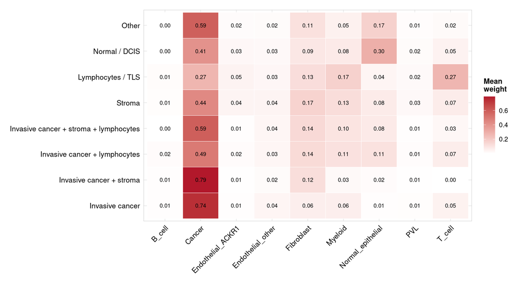

Figure 67: Mean RCTD weight of each cell-type class by pathologist annotation, with the six sections pooled.

```r
p_ann <- ggplot(weight_by_annotation, aes(x = cell_type, y = annotation, fill = mean_weight)) +
  geom_tile(color = "white") +
  geom_text(aes(label = sprintf("%.2f", mean_weight)), size = 3) +
  scale_fill_gradient(low = "white", high = "#B2182B", name = "Mean\nweight") +
  labs(x = NULL, y = NULL) +
  theme_publication() +
  theme(axis.text.x = element_text(angle = 45, hjust = 1))
ggsave(file.path(spatial_res_dir, "fig_spatial_weights_by_annotation.png"), p_ann, width = 11, height = 6, dpi = 300)
p_ann
```

The leave-patient-out reference gives weights that correlate with the primary ones at r of at least 0.94 in the four overlapping sections, so the deconvolution does not depend on the overlap between the single-cell cohort and the spatial sections.

```r
# Leave-patient-out reference: agreement with the primary weights in the overlapping sections
lopo_agreement <- bind_rows(lapply(names(rctd_weights$lopo), function(sid) {
  w0 <- rctd_weights$primary[[sid]]
  w1 <- rctd_weights$lopo[[sid]][rownames(w0), colnames(w0)]
  tibble(section = sid, cell_type = colnames(w0),
         pearson_r = sapply(colnames(w0), function(ct) cor(w0[, ct], w1[, ct])),
         mean_primary = colMeans(w0), mean_lopo = colMeans(w1))
}))
write_csv(lopo_agreement, file.path(spatial_res_dir, "table_spatial_lopo_weight_agreement.csv"))
knitr::kable(lopo_agreement %>% select(section, cell_type, pearson_r) %>% tidyr::pivot_wider(names_from = section, values_from = pearson_r),
             digits = 3, caption = "S1: correlation between primary and leave-patient-out RCTD weights")
```

S1: correlation between primary and leave-patient-out RCTD weights

| cell_type | CID4290 | CID4465 | CID44971 | CID4535 |
| --- | --- | --- | --- | --- |
| B_cell | 0.997 | 0.993 | 1.000 | 1.000 |
| Cancer | 0.996 | 1.000 | 0.999 | 0.999 |
| Endothelial_ACKR1 | 0.983 | 0.989 | 0.997 | 0.996 |
| Endothelial_other | 0.996 | 0.996 | 0.997 | 0.996 |
| Fibroblast | 0.998 | 0.998 | 0.999 | 1.000 |
| Myeloid | 0.999 | 0.999 | 0.999 | 0.999 |
| Normal_epithelial | 0.939 | 0.997 | 0.999 | 0.986 |
| PVL | 0.998 | 0.997 | 0.997 | 0.995 |
| T_cell | 0.983 | 0.999 | 0.998 | 0.999 |

### Co-localization and co-expression tests

For each axis we run three tests in every section, and the section is the unit of replication, because spots within a section are not independent.

- **(a) Weight correlation.** Spearman’s rho between the sender and receiver weights across spots, analyzed on the Fisher-z scale.
- **(b) Neighborhood enrichment.** A spot’s neighborhood is the spot and its six immediate neighbors on the Visium hexagonal array. A spot is “high” for a cell type if its weight is at or above the 75th percentile of the section and at least 0.05. We count how often a sender-high spot has a receiver-high spot in its neighborhood and compare this with 1,000 permutations of the receiver-high labels across the section (seed 42). The effect is the log2 ratio of observed to expected counts. A label permutation ignores spatial autocorrelation, so we also compute the same enrichment for every pair of distinct cell types in the section and report the percentile of the axis pair among them, as a descriptive comparison.
- **(c) Ligand-receptor co-expression.** For each spot, the product of the mean ligand and the mean receptor expression over its neighborhood. The effect is Hedges’ g between niche spots (neighborhoods holding both a sender-high and a receiver-high spot) and all other spots.

Section effects are pooled with a random-effects meta-analysis (REML) and Knapp-Hartung inference, which bases the test on the variation between sections. Within a family the p-values are corrected with Benjamini-Hochberg: the primary family is the three tests of FN1-ITGA5/ITGB1, the key secondary family the three tests of CCL5-ACKR1, and the exploratory family the tests of the other axes. A test meets our criterion when the pooled effect has the expected direction with q below 0.05 and the expected direction in at least five of the six sections. MDK-LRP1 is autocrine, so only test (c) applies.

```r
spatial_types <- c("Cancer", "Fibroblast", "Endothelial", "Endothelial_ACKR1", "Endothelial_other", "Myeloid", "T_cell", "B_cell", "PVL", "Normal_epithelial")
spatial_axes <- candidate_registry %>%
  transmute(axis_id, ligand, receptor, sender = sender_celltype,
            receiver = if_else(axis_id == "ccl5_ackr1", "Endothelial_ACKR1", receiver_celltype),
            family = case_when(axis_id == "fn1_itga5_itgb1" ~ "Primary", axis_id == "ccl5_ackr1" ~ "Key secondary", TRUE ~ "Exploratory axes"))

# Hexagonal distance in Visium doubled-column array coordinates, for all spot pairs up to max_d rings apart
hex_pairs <- function(spots, max_d = 3) {
  key <- paste(spots$array_row, spots$array_col)
  offs <- expand.grid(dr = -max_d:max_d, dc = (-2 * max_d):(2 * max_d)) %>%
    filter((dr + dc) %% 2 == 0) %>%
    mutate(d = abs(dr) + pmax(0, (abs(dc) - abs(dr)) / 2)) %>%
    filter(d <= max_d)
  bind_rows(lapply(seq_len(nrow(offs)), function(k) {
    data.frame(i = seq_len(nrow(spots)), j = match(paste(spots$array_row + offs$dr[k], spots$array_col + offs$dc[k]), key), d = offs$d[k])
  })) %>%
    filter(!is.na(j))
}

ring_adjacency <- function(sec, rings) {
  p <- sec$pairs[sec$pairs$d %in% rings, ]
  sparseMatrix(i = p$i, j = p$j, x = 1, dims = rep(nrow(sec$spots), 2))
}

prepare_section <- function(sid, w) {
  v <- visium[[sid]]
  spots <- v$spots[match(rownames(w), v$spots$barcode), ] %>% mutate(annotation = collapse_annotation(classification))
  w <- cbind(w, Endothelial = w[, "Endothelial_ACKR1"] + w[, "Endothelial_other"])
  counts <- v$counts[, spots$barcode]
  expr <- counts
  expr@x <- log1p(expr@x / rep(colSums(counts), diff(counts@p)) * 1e4)
  list(sid = sid, spots = spots, w = w, expr = expr, pairs = hex_pairs(spots))
}

subset_section <- function(sec, keep) {
  idx <- which(keep)
  new_index <- match(seq_len(nrow(sec$spots)), idx)
  list(sid = sec$sid, spots = sec$spots[idx, ], w = sec$w[idx, , drop = FALSE], expr = sec$expr[, idx],
       pairs = sec$pairs %>% mutate(i = new_index[i], j = new_index[j]) %>% filter(!is.na(i), !is.na(j)))
}

high_spots <- function(x, q = 0.75) as.numeric(x >= quantile(x, q) & x >= 0.05)
nb_mean <- function(A, x) as.vector(A %*% x) / rowSums(A)
gene_score <- function(expr, genes) {
  g <- strsplit(genes, "_")[[1]]
  if (!all(g %in% rownames(expr))) return(NULL)
  colMeans(as.matrix(expr[g, , drop = FALSE]))
}

spearman_stat <- function(x, y) {
  rho <- cor(x, y, method = "spearman")
  data.frame(est = atanh(rho), var = 1 / (length(x) - 3), rho = rho)
}

enrich_stat <- function(S, R, A, n_perm = 1000) {
  if (sum(S) < 10 || sum(R) < 10) return(data.frame(est = NA_real_, var = NA_real_, obs = NA_real_, expected = NA_real_, z = NA_real_, p_perm = NA_real_))
  obs <- sum(S * as.vector(A %*% R))
  set.seed(42)
  perm <- colSums(S * as.matrix(A %*% replicate(n_perm, sample(R))))
  e <- mean(perm)
  s <- sd(perm)
  data.frame(est = log2(obs / e), var = (s / (e * log(2)))^2, obs = obs, expected = e, z = (obs - e) / s, p_perm = (1 + sum(perm >= obs)) / (n_perm + 1))
}

hedges_g <- function(x, grp) {
  n1 <- sum(grp)
  n0 <- sum(!grp)
  sp <- sqrt(((n1 - 1) * var(x[grp]) + (n0 - 1) * var(x[!grp])) / (n1 + n0 - 2))
  if (n1 < 10 || n0 < 10 || !is.finite(sp) || sp == 0) return(data.frame(est = NA_real_, var = NA_real_))
  g <- (1 - 3 / (4 * (n1 + n0) - 9)) * (mean(x[grp]) - mean(x[!grp])) / sp
  data.frame(est = g, var = (n1 + n0) / (n1 * n0) + g^2 / (2 * (n1 + n0)))
}

# Random-effects (REML) pooling over sections with Knapp-Hartung inference
pool_sections <- function(est, v, expected_sign = 1) {
  keep <- is.finite(est) & is.finite(v)
  out <- data.frame(k = sum(keep), n_expected_dir = sum(sign(est[keep]) == expected_sign),
                    est = NA_real_, lo = NA_real_, hi = NA_real_, p = NA_real_, tau2 = NA_real_, i2 = NA_real_)
  if (sum(keep) < 2) return(out)
  fit <- rma(yi = est[keep], vi = v[keep], method = "REML", test = "knha", control = list(maxiter = 1000, stepadj = 0.5))
  out %>% mutate(est = fit$b[1], lo = fit$ci.lb, hi = fit$ci.ub, p = fit$pval, tau2 = fit$tau2, i2 = fit$I2)
}

# Niche of an axis: neighborhoods holding a sender-high and a receiver-high spot (any sender-high spot if autocrine)
axis_niche <- function(sec, ax, A, high_q = 0.75) {
  S <- high_spots(sec$w[, ax$sender], high_q)
  R <- high_spots(sec$w[, ax$receiver], high_q)
  niche <- if (ax$sender == ax$receiver) as.vector(A %*% S) > 0 else as.vector(A %*% S) > 0 & as.vector(A %*% R) > 0
  list(S = S, R = R, niche = niche, estimable = sum(S) >= 10 && sum(R) >= 10)
}

axis_section_tests <- function(sec, ax, rings = 0:1, high_q = 0.75, colocalisation = TRUE) {
  A <- ring_adjacency(sec, rings)
  nc <- axis_niche(sec, ax, A, high_q)
  lr <- nb_mean(A, gene_score(sec$expr, ax$ligand)) * nb_mean(A, gene_score(sec$expr, ax$receptor))
  rows <- list(hedges_g(lr, nc$niche) %>% mutate(test = "(c) L-R co-expression"))
  if (colocalisation && ax$sender != ax$receiver) {
    rows <- c(rows, list(
      spearman_stat(sec$w[, ax$sender], sec$w[, ax$receiver]) %>% mutate(test = "(a) weight correlation"),
      enrich_stat(nc$S, nc$R, A) %>% mutate(test = "(b) neighborhood enrichment")
    ))
  }
  out <- bind_rows(rows) %>% mutate(section = sec$sid, axis_id = ax$axis_id, n_spots = nrow(sec$spots),
                                    n_sender_high = sum(nc$S), n_receiver_high = sum(nc$R), n_niche = sum(nc$niche))
  out$est[out$test != "(a) weight correlation" & !nc$estimable] <- NA_real_
  out
}

run_axis_tests <- function(secs, axes = spatial_axes, ...) {
  bind_rows(lapply(secs, function(sec) bind_rows(lapply(seq_len(nrow(axes)), function(k) axis_section_tests(sec, axes[k, ], ...)))))
}

pool_axis_tests <- function(section_res, axes = spatial_axes) {
  section_res %>%
    group_by(axis_id, test) %>%
    group_modify(~ pool_sections(.x$est, .x$var)) %>%
    ungroup() %>%
    left_join(axes %>% select(axis_id, family), by = "axis_id") %>%
    group_by(family) %>%
    mutate(q_bh = p.adjust(p, method = "BH")) %>%
    ungroup() %>%
    mutate(criterion_met = !is.na(est) & est > 0 & q_bh < 0.05 & n_expected_dir >= 5)
}

fmt_pooled <- function(test, est, lo, hi) {
  ifelse(grepl("^\\(a\\)", test), sprintf("rho %.2f (%.2f to %.2f)", tanh(est), tanh(lo), tanh(hi)), sprintf("%.2f (%.2f to %.2f)", est, lo, hi))
}

secs_primary <- lapply(setNames(names(rctd_weights$primary), names(rctd_weights$primary)), function(sid) prepare_section(sid, rctd_weights$primary[[sid]]))
```

```r
spatial_section_res <- run_axis_tests(secs_primary)
spatial_pooled <- pool_axis_tests(spatial_section_res)
write_csv(spatial_section_res, file.path(spatial_res_dir, "spatial_tests_by_section.csv"))
write_csv(spatial_pooled, file.path(spatial_res_dir, "spatial_tests_pooled.csv"))

knitr::kable(
  spatial_pooled %>%
    mutate(family = factor(family, levels = c("Primary", "Key secondary", "Exploratory axes"))) %>%
    arrange(family, factor(axis_id, levels = spatial_axes$axis_id), test) %>%
    transmute(family, Axis = axis_labels[axis_id], test, k, `Pooled (95% CI)` = fmt_pooled(test, est, lo, hi),
              p = signif(p, 3), q = signif(q_bh, 3), `Expected direction` = paste0(n_expected_dir, "/", k), I2 = round(i2, 1), criterion_met),
  caption = "Tests: random-effects pooled estimates over sections (Knapp-Hartung), BH within each family. (a) Spearman rho; (b) log2 observed/expected co-occurrence; (c) Hedges' g of the L-R score, niche vs other spots"
)
```

Tests: random-effects pooled estimates over sections (Knapp-Hartung), BH within each family. (a) Spearman rho; (b) log2 observed/expected co-occurrence; (c) Hedges’ g of the L-R score, niche vs other spots

| family | Axis | test | k | Pooled (95% CI) | p | q | Expected direction | I2 | criterion_met |
| --- | --- | --- | --- | --- | --- | --- | --- | --- | --- |
| Primary | FN1-ITGA5/ITGB1 | (a) weight correlation | 6 | rho 0.31 (0.07 to 0.51) | 0.022100 | 0.03310 | 6/6 | 99.2 | TRUE |
| Primary | FN1-ITGA5/ITGB1 | (b) neighborhood enrichment | 6 | 0.55 (0.22 to 0.89) | 0.008290 | 0.02490 | 6/6 | 95.5 | TRUE |
| Primary | FN1-ITGA5/ITGB1 | (c) L-R co-expression | 6 | 0.60 (-0.05 to 1.24) | 0.062700 | 0.06270 | 5/6 | 99.5 | FALSE |
| Key secondary | CCL5-ACKR1 | (a) weight correlation | 6 | rho 0.30 (0.20 to 0.39) | 0.000565 | 0.00170 | 6/6 | 95.5 | TRUE |
| Key secondary | CCL5-ACKR1 | (b) neighborhood enrichment | 6 | 1.02 (0.57 to 1.47) | 0.002130 | 0.00288 | 6/6 | 84.2 | TRUE |
| Key secondary | CCL5-ACKR1 | (c) L-R co-expression | 6 | 1.39 (0.73 to 2.05) | 0.002880 | 0.00288 | 6/6 | 99.0 | TRUE |
| Exploratory axes | CXCL12-CXCR4 | (a) weight correlation | 6 | rho 0.35 (-0.02 to 0.64) | 0.059100 | 0.09940 | 5/6 | 99.7 | FALSE |
| Exploratory axes | CXCL12-CXCR4 | (b) neighborhood enrichment | 6 | 0.59 (-0.20 to 1.38) | 0.113000 | 0.13100 | 5/6 | 98.8 | FALSE |
| Exploratory axes | CXCL12-CXCR4 | (c) L-R co-expression | 6 | 0.99 (0.56 to 1.42) | 0.001920 | 0.00672 | 6/6 | 98.3 | TRUE |
| Exploratory axes | MDK-LRP1 | (c) L-R co-expression | 6 | 0.70 (0.25 to 1.16) | 0.010800 | 0.02520 | 6/6 | 99.0 | TRUE |
| Exploratory axes | APP-CD74 | (a) weight correlation | 6 | rho 0.26 (0.17 to 0.36) | 0.000980 | 0.00672 | 6/6 | 95.3 | TRUE |
| Exploratory axes | APP-CD74 | (b) neighborhood enrichment | 5 | 0.51 (-0.07 to 1.09) | 0.071000 | 0.09940 | 4/5 | 79.6 | FALSE |
| Exploratory axes | APP-CD74 | (c) L-R co-expression | 5 | 0.03 (-0.75 to 0.81) | 0.923000 | 0.92300 | 3/5 | 98.2 | FALSE |

```r
knitr::kable(
  spatial_section_res %>%
    transmute(section, Axis = axis_labels[axis_id], test,
              estimate = ifelse(test == "(a) weight correlation", round(rho, 3), round(est, 3)), z = round(z, 1), p_perm = signif(p_perm, 2),
              n_spots, n_sender_high, n_receiver_high, n_niche) %>%
    arrange(Axis, test, section),
  caption = "Tests per section ((a) rho; (b) log2 O/E with permutation z and p; (c) Hedges' g)"
)
```

Tests per section ((a) rho; (b) log2 O/E with permutation z and p; (c) Hedges’ g)

| section | Axis | test | estimate | z | p_perm | n_spots | n_sender_high | n_receiver_high | n_niche |
| --- | --- | --- | --- | --- | --- | --- | --- | --- | --- |
| 1142243F | APP-CD74 | (a) weight correlation | 0.269 | NA | NA | 4636 | 997 | 25 | 85 |
| 1160920F | APP-CD74 | (a) weight correlation | 0.335 | NA | NA | 4842 | 1211 | 47 | 173 |
| CID4290 | APP-CD74 | (a) weight correlation | 0.178 | NA | NA | 2419 | 277 | 99 | 198 |
| CID4465 | APP-CD74 | (a) weight correlation | 0.132 | NA | NA | 1207 | 302 | 4 | 25 |
| CID44971 | APP-CD74 | (a) weight correlation | 0.298 | NA | NA | 1159 | 290 | 62 | 135 |
| CID4535 | APP-CD74 | (a) weight correlation | 0.364 | NA | NA | 1102 | 276 | 105 | 247 |
| 1142243F | APP-CD74 | (b) neighborhood enrichment | 0.921 | 4.4 | 0.001 | 4636 | 997 | 25 | 85 |
| 1160920F | APP-CD74 | (b) neighborhood enrichment | 0.823 | 4.5 | 0.001 | 4842 | 1211 | 47 | 173 |
| CID4290 | APP-CD74 | (b) neighborhood enrichment | 0.306 | 1.4 | 0.082 | 2419 | 277 | 99 | 198 |
| CID4465 | APP-CD74 | (b) neighborhood enrichment | NA | NA | NA | 1207 | 302 | 4 | 25 |
| CID44971 | APP-CD74 | (b) neighborhood enrichment | -0.202 | -0.9 | 0.830 | 1159 | 290 | 62 | 135 |
| CID4535 | APP-CD74 | (b) neighborhood enrichment | 0.754 | 7.6 | 0.001 | 1102 | 276 | 105 | 247 |
| 1142243F | APP-CD74 | (c) L-R co-expression | 0.735 | NA | NA | 4636 | 997 | 25 | 85 |
| 1160920F | APP-CD74 | (c) L-R co-expression | -0.921 | NA | NA | 4842 | 1211 | 47 | 173 |
| CID4290 | APP-CD74 | (c) L-R co-expression | -0.166 | NA | NA | 2419 | 277 | 99 | 198 |
| CID4465 | APP-CD74 | (c) L-R co-expression | NA | NA | NA | 1207 | 302 | 4 | 25 |
| CID44971 | APP-CD74 | (c) L-R co-expression | 0.113 | NA | NA | 1159 | 290 | 62 | 135 |
| CID4535 | APP-CD74 | (c) L-R co-expression | 0.395 | NA | NA | 1102 | 276 | 105 | 247 |
| 1142243F | CCL5-ACKR1 | (a) weight correlation | 0.233 | NA | NA | 4636 | 521 | 183 | 542 |
| 1160920F | CCL5-ACKR1 | (a) weight correlation | 0.405 | NA | NA | 4842 | 1211 | 756 | 1421 |
| CID4290 | CCL5-ACKR1 | (a) weight correlation | 0.196 | NA | NA | 2419 | 13 | 37 | 21 |
| CID4465 | CCL5-ACKR1 | (a) weight correlation | 0.281 | NA | NA | 1207 | 302 | 111 | 239 |
| CID44971 | CCL5-ACKR1 | (a) weight correlation | 0.265 | NA | NA | 1159 | 290 | 189 | 396 |
| CID4535 | CCL5-ACKR1 | (a) weight correlation | 0.400 | NA | NA | 1102 | 276 | 73 | 255 |
| 1142243F | CCL5-ACKR1 | (b) neighborhood enrichment | 1.182 | 8.9 | 0.001 | 4636 | 521 | 183 | 542 |
| 1160920F | CCL5-ACKR1 | (b) neighborhood enrichment | 1.097 | 25.4 | 0.001 | 4842 | 1211 | 756 | 1421 |
| CID4290 | CCL5-ACKR1 | (b) neighborhood enrichment | 2.901 | 6.1 | 0.001 | 2419 | 13 | 37 | 21 |
| CID4465 | CCL5-ACKR1 | (b) neighborhood enrichment | 1.026 | 8.3 | 0.001 | 1207 | 302 | 111 | 239 |
| CID44971 | CCL5-ACKR1 | (b) neighborhood enrichment | 0.403 | 3.9 | 0.001 | 1159 | 290 | 189 | 396 |
| CID4535 | CCL5-ACKR1 | (b) neighborhood enrichment | 1.393 | 10.6 | 0.001 | 1102 | 276 | 73 | 255 |
| 1142243F | CCL5-ACKR1 | (c) L-R co-expression | 0.457 | NA | NA | 4636 | 521 | 183 | 542 |
| 1160920F | CCL5-ACKR1 | (c) L-R co-expression | 1.303 | NA | NA | 4842 | 1211 | 756 | 1421 |
| CID4290 | CCL5-ACKR1 | (c) L-R co-expression | 1.866 | NA | NA | 2419 | 13 | 37 | 21 |
| CID4465 | CCL5-ACKR1 | (c) L-R co-expression | 1.841 | NA | NA | 1207 | 302 | 111 | 239 |
| CID44971 | CCL5-ACKR1 | (c) L-R co-expression | 0.899 | NA | NA | 1159 | 290 | 189 | 396 |
| CID4535 | CCL5-ACKR1 | (c) L-R co-expression | 2.023 | NA | NA | 1102 | 276 | 73 | 255 |
| 1142243F | CXCL12-CXCR4 | (a) weight correlation | 0.349 | NA | NA | 4636 | 1159 | 521 | 1160 |
| 1160920F | CXCL12-CXCR4 | (a) weight correlation | 0.607 | NA | NA | 4842 | 1211 | 1211 | 1790 |
| CID4290 | CXCL12-CXCR4 | (a) weight correlation | 0.013 | NA | NA | 2419 | 605 | 13 | 43 |
| CID4465 | CXCL12-CXCR4 | (a) weight correlation | -0.113 | NA | NA | 1207 | 302 | 302 | 316 |
| CID44971 | CXCL12-CXCR4 | (a) weight correlation | 0.389 | NA | NA | 1159 | 290 | 290 | 437 |
| CID4535 | CXCL12-CXCR4 | (a) weight correlation | 0.682 | NA | NA | 1102 | 276 | 276 | 419 |
| 1142243F | CXCL12-CXCR4 | (b) neighborhood enrichment | 0.939 | 19.1 | 0.001 | 4636 | 1159 | 521 | 1160 |
| 1160920F | CXCL12-CXCR4 | (b) neighborhood enrichment | 1.143 | 38.3 | 0.001 | 4842 | 1211 | 1211 | 1790 |
| CID4290 | CXCL12-CXCR4 | (b) neighborhood enrichment | 0.503 | 1.3 | 0.120 | 2419 | 605 | 13 | 43 |
| CID4465 | CXCL12-CXCR4 | (b) neighborhood enrichment | -0.833 | -7.8 | 1.000 | 1207 | 302 | 302 | 316 |
| CID44971 | CXCL12-CXCR4 | (b) neighborhood enrichment | 0.692 | 9.3 | 0.001 | 1159 | 290 | 290 | 437 |
| CID4535 | CXCL12-CXCR4 | (b) neighborhood enrichment | 1.065 | 15.3 | 0.001 | 1102 | 276 | 276 | 419 |
| 1142243F | CXCL12-CXCR4 | (c) L-R co-expression | 0.739 | NA | NA | 4636 | 1159 | 521 | 1160 |
| 1160920F | CXCL12-CXCR4 | (c) L-R co-expression | 1.098 | NA | NA | 4842 | 1211 | 1211 | 1790 |
| CID4290 | CXCL12-CXCR4 | (c) L-R co-expression | 1.502 | NA | NA | 2419 | 605 | 13 | 43 |
| CID4465 | CXCL12-CXCR4 | (c) L-R co-expression | 0.377 | NA | NA | 1207 | 302 | 302 | 316 |
| CID44971 | CXCL12-CXCR4 | (c) L-R co-expression | 0.940 | NA | NA | 1159 | 290 | 290 | 437 |
| CID4535 | CXCL12-CXCR4 | (c) L-R co-expression | 1.366 | NA | NA | 1102 | 276 | 276 | 419 |
| 1142243F | FN1-ITGA5/ITGB1 | (a) weight correlation | 0.125 | NA | NA | 4636 | 1159 | 997 | 1995 |
| 1160920F | FN1-ITGA5/ITGB1 | (a) weight correlation | 0.621 | NA | NA | 4842 | 1211 | 1211 | 2157 |
| CID4290 | FN1-ITGA5/ITGB1 | (a) weight correlation | 0.253 | NA | NA | 2419 | 605 | 277 | 714 |
| CID4465 | FN1-ITGA5/ITGB1 | (a) weight correlation | 0.076 | NA | NA | 1207 | 302 | 302 | 482 |
| CID44971 | FN1-ITGA5/ITGB1 | (a) weight correlation | 0.273 | NA | NA | 1159 | 290 | 290 | 420 |
| CID4535 | FN1-ITGA5/ITGB1 | (a) weight correlation | 0.410 | NA | NA | 1102 | 276 | 276 | 473 |
| 1142243F | FN1-ITGA5/ITGB1 | (b) neighborhood enrichment | 0.472 | 11.9 | 0.001 | 4636 | 1159 | 997 | 1995 |
| 1160920F | FN1-ITGA5/ITGB1 | (b) neighborhood enrichment | 1.051 | 33.6 | 0.001 | 4842 | 1211 | 1211 | 2157 |
| CID4290 | FN1-ITGA5/ITGB1 | (b) neighborhood enrichment | 0.580 | 7.6 | 0.001 | 2419 | 605 | 277 | 714 |
| CID4465 | FN1-ITGA5/ITGB1 | (b) neighborhood enrichment | 0.144 | 2.0 | 0.023 | 1207 | 302 | 302 | 482 |
| CID44971 | FN1-ITGA5/ITGB1 | (b) neighborhood enrichment | 0.326 | 3.9 | 0.001 | 1159 | 290 | 290 | 420 |
| CID4535 | FN1-ITGA5/ITGB1 | (b) neighborhood enrichment | 0.734 | 9.6 | 0.001 | 1102 | 276 | 276 | 473 |
| 1142243F | FN1-ITGA5/ITGB1 | (c) L-R co-expression | 0.770 | NA | NA | 4636 | 1159 | 997 | 1995 |
| 1160920F | FN1-ITGA5/ITGB1 | (c) L-R co-expression | 0.241 | NA | NA | 4842 | 1211 | 1211 | 2157 |
| CID4290 | FN1-ITGA5/ITGB1 | (c) L-R co-expression | 0.634 | NA | NA | 2419 | 605 | 277 | 714 |
| CID4465 | FN1-ITGA5/ITGB1 | (c) L-R co-expression | -0.068 | NA | NA | 1207 | 302 | 302 | 482 |
| CID44971 | FN1-ITGA5/ITGB1 | (c) L-R co-expression | 0.318 | NA | NA | 1159 | 290 | 290 | 420 |
| CID4535 | FN1-ITGA5/ITGB1 | (c) L-R co-expression | 1.699 | NA | NA | 1102 | 276 | 276 | 473 |
| 1142243F | MDK-LRP1 | (c) L-R co-expression | 0.491 | NA | NA | 4636 | 1159 | 1159 | 2804 |
| 1160920F | MDK-LRP1 | (c) L-R co-expression | 0.930 | NA | NA | 4842 | 1211 | 1211 | 2613 |
| CID4290 | MDK-LRP1 | (c) L-R co-expression | 0.737 | NA | NA | 2419 | 605 | 605 | 1498 |
| CID4465 | MDK-LRP1 | (c) L-R co-expression | 0.278 | NA | NA | 1207 | 302 | 302 | 756 |
| CID44971 | MDK-LRP1 | (c) L-R co-expression | 0.343 | NA | NA | 1159 | 290 | 290 | 595 |
| CID4535 | MDK-LRP1 | (c) L-R co-expression | 1.442 | NA | NA | 1102 | 276 | 276 | 527 |

```r
# Context-relative comparator for (b): rank of each axis pair among all pairs of distinct types
type_pairs <- as.data.frame(t(combn(spatial_types, 2)), stringsAsFactors = FALSE) %>%
  setNames(c("type1", "type2")) %>%
  filter(!(type1 == "Endothelial" & grepl("^Endothelial_", type2)))
pair_enrichment <- bind_rows(lapply(secs_primary, function(sec) {
  A <- ring_adjacency(sec, 0:1)
  bind_rows(lapply(seq_len(nrow(type_pairs)), function(k) {
    enrich_stat(high_spots(sec$w[, type_pairs$type1[k]]), high_spots(sec$w[, type_pairs$type2[k]]), A) %>%
      mutate(section = sec$sid, type1 = type_pairs$type1[k], type2 = type_pairs$type2[k])
  }))
}))
write_csv(pair_enrichment, file.path(spatial_res_dir, "spatial_pair_enrichment_all_pairs.csv"))
hetero_axes <- spatial_axes %>% filter(sender != receiver)
axis_pair_rank <- bind_rows(lapply(seq_len(nrow(hetero_axes)), function(k) {
  ax <- hetero_axes[k, ]
  pair_enrichment %>%
    mutate(is_axis = (type1 == ax$sender & type2 == ax$receiver) | (type2 == ax$sender & type1 == ax$receiver)) %>%
    group_by(section) %>%
    summarise(axis_log2_oe = est[is_axis], percentile = 100 * mean(est[!is_axis] < est[is_axis], na.rm = TRUE),
              rank = if (is.finite(est[is_axis])) sum(est[!is_axis] > est[is_axis], na.rm = TRUE) + 1 else NA_real_,
              n_pairs = sum(is.finite(est)), .groups = "drop") %>%
    mutate(axis_id = ax$axis_id)
}))
write_csv(axis_pair_rank, file.path(spatial_res_dir, "spatial_axis_pair_rank.csv"))
knitr::kable(
  axis_pair_rank %>% group_by(axis_id) %>%
    summarise(Axis = axis_labels[axis_id[1]], `Median percentile` = round(median(percentile, na.rm = TRUE), 1),
              `Percentile per section` = paste(round(percentile), collapse = ", "), `Rank per section` = paste(rank, collapse = ", "),
              Pairs = max(n_pairs)),
  caption = "(b) context-relative comparator: percentile of the axis pair's enrichment among all cell-type pairs in the same section (sections in the order 1142243F, 1160920F, CID4290, CID4465, CID44971, CID4535)"
)
```

(b) context-relative comparator: percentile of the axis pair’s enrichment among all cell-type pairs in the same section (sections in the order 1142243F, 1160920F, CID4290, CID4465, CID44971, CID4535)

| axis_id | Axis | Median percentile | Percentile per section | Rank per section | Pairs |
| --- | --- | --- | --- | --- | --- |
| app_cd74 | APP-CD74 | 52.4 | 76, 52, 33, NaN, 52, 50 | 11, 21, 29, NA, 21, 22 | 43 |
| ccl5_ackr1 | CCL5-ACKR1 | 89.3 | 86, 71, 100, 94, 76, 93 | 7, 13, 1, 3, 11, 4 | 43 |
| cxcl12_cxcr4 | CXCL12-CXCR4 | 73.8 | 79, 76, 45, 36, 81, 71 | 10, 11, 24, 22, 9, 13 | 43 |
| fn1_itga5_itgb1 | FN1-ITGA5/ITGB1 | 57.1 | 52, 62, 50, 64, 71, 48 | 21, 17, 22, 13, 13, 23 | 43 |

The CCL5-ACKR1 axis meets the criterion for all three tests. T cells co-localize with ACKR1-positive venular endothelium in all six sections (log2 observed/expected 1.02, 95% CI 0.57 to 1.47, q = 0.0029), and CCL5-ACKR1 co-expression is high in those niches (Hedges’ g 1.39, q = 0.0029). Across cell-type pairs, the axis sits at the 89th percentile of enrichment (median over sections). For FN1-ITGA5/ITGB1, fibroblasts and endothelial cells co-localize in all six sections (log2 observed/expected 0.55, q = 0.025), but the pair sits near the 57th percentile of all pairs. That is expected for stromal cells that share a compartment, and it is not an unusually strong contact. FN1-ITGA5/ITGB1 co-expression is higher in fibroblast-endothelial niches in five of six sections, and it misses our criterion (g 0.60, q = 0.063).

### Benchmark against random gene pairs

A co-expression effect has to be judged against what any two genes of similar abundance would give. For each axis we draw 1,000 random gene pairs, with each gene matched to the corresponding axis gene within 2.5 percentiles of mean expression (genes detected in at least 1% of spots in every section, excluding the eleven axis genes), score them in the same niche, and pool them in the same way. The empirical p-value is one-sided. For FN1 we also draw random receptors matched to ITGA5 and ITGB1, and we compute the ligand-only and receptor-only scores, to see whether the co-expression is explained by FN1 alone.

```r
bench_spatial_path <- file.path(spatial_obj_dir, "spatial_benchmark.qs2")

# Gene universe: measured in every section and detected in at least 1% of QC spots of each
shared_genes_sp <- Reduce(intersect, lapply(secs_primary, function(sec) rownames(sec$expr)))
universe <- shared_genes_sp[Reduce(`&`, lapply(secs_primary, function(sec) Matrix::rowMeans(sec$expr[shared_genes_sp, ] > 0) >= 0.01))]
gene_mean_all <- Reduce(`+`, lapply(secs_primary, function(sec) Matrix::rowSums(sec$expr[shared_genes_sp, ]))) /
  sum(sapply(secs_primary, function(sec) ncol(sec$expr)))
univ_ecdf <- ecdf(gene_mean_all[universe])
univ_pct <- univ_ecdf(gene_mean_all[universe])
pools <- lapply(setNames(spatial_axis_genes, spatial_axis_genes), function(g) {
  setdiff(universe[abs(univ_pct - univ_ecdf(gene_mean_all[g])) <= 0.025], spatial_axis_genes)
})

niches_primary <- lapply(secs_primary, function(sec) {
  A <- ring_adjacency(sec, 0:1)
  lapply(setNames(seq_len(nrow(spatial_axes)), spatial_axes$axis_id), function(k) axis_niche(sec, spatial_axes[k, ], A))
})

if (file.exists(bench_spatial_path)) {
  bench_sp <- qs_read(bench_spatial_path)
} else {
  set.seed(42)
  draws <- list()
  for (k in seq_len(nrow(spatial_axes))) {
    rec_genes <- strsplit(spatial_axes$receptor[k], "_")[[1]]
    lig_gene <- spatial_axes$ligand[k]
    draws[[spatial_axes$axis_id[k]]] <- lapply(seq_len(1000), function(j) {
      lig <- sample(pools[[lig_gene]], 1)
      list(lig = lig, rec = vapply(rec_genes, function(g) sample(setdiff(pools[[g]], lig), 1), character(1)))
    })
  }
  draws$fn1_random_receptor <- lapply(seq_len(1000), function(j) {
    list(lig = "FN1", rec = vapply(c("ITGA5", "ITGB1"), function(g) sample(pools[[g]], 1), character(1)))
  })

  needed <- unique(c(unlist(draws), spatial_axis_genes))
  nb_mats <- lapply(secs_primary, function(sec) {
    A <- ring_adjacency(sec, 0:1)
    sweep(as.matrix(sec$expr[needed, ] %*% t(A)), 2, rowSums(A), "/")
  })
  pooled_g <- function(axis_id, lig, rec) {
    gs <- bind_rows(lapply(names(secs_primary), function(sid) {
      nc <- niches_primary[[sid]][[axis_id]]
      if (!nc$estimable) return(data.frame(est = NA_real_, var = NA_real_))
      m <- nb_mats[[sid]]
      score <- if (length(lig) == 0) colMeans(m[rec, , drop = FALSE]) else if (length(rec) == 0) m[lig, ] else m[lig, ] * colMeans(m[rec, , drop = FALSE])
      hedges_g(score, nc$niche)
    }))
    pool_sections(gs$est, gs$var)$est
  }

  null_g <- bind_rows(lapply(names(draws), function(nm) {
    ax_id <- if (nm == "fn1_random_receptor") "fn1_itga5_itgb1" else nm
    g <- unlist(parallel::mclapply(draws[[nm]], function(dr) pooled_g(ax_id, dr$lig, dr$rec), mc.cores = num_cores))
    data.frame(null = nm, axis_id = ax_id, draw = seq_along(g), g = g,
               genes = vapply(draws[[nm]], function(dr) paste(dr$lig, paste(dr$rec, collapse = "_")), character(1)))
  }))
  single_gene <- bind_rows(lapply(seq_len(nrow(spatial_axes)), function(k) {
    rec_genes <- strsplit(spatial_axes$receptor[k], "_")[[1]]
    data.frame(axis_id = spatial_axes$axis_id[k],
               g_pair_check = pooled_g(spatial_axes$axis_id[k], spatial_axes$ligand[k], rec_genes),
               g_ligand_only = pooled_g(spatial_axes$axis_id[k], spatial_axes$ligand[k], character(0)),
               g_receptor_only = pooled_g(spatial_axes$axis_id[k], character(0), rec_genes))
  }))
  bench_sp <- list(null_g = null_g, single_gene = single_gene, n_universe = length(universe))
  qs_save(bench_sp, bench_spatial_path)
}

obs_c <- spatial_pooled %>% filter(test == "(c) L-R co-expression") %>% select(axis_id, g_obs = est)
bench_sp_summary <- bench_sp$null_g %>%
  left_join(obs_c, by = "axis_id") %>%
  group_by(null, axis_id) %>%
  summarise(g_obs = g_obs[1], n_null = sum(is.finite(g)), null_median = median(g, na.rm = TRUE), null_q95 = quantile(g, 0.95, na.rm = TRUE),
            percentile = 100 * mean(g < g_obs[1], na.rm = TRUE), emp_p_one_sided = (1 + sum(g >= g_obs[1], na.rm = TRUE)) / (n_null + 1), .groups = "drop") %>%
  left_join(bench_sp$single_gene, by = "axis_id") %>%
  mutate(null = if_else(null == "fn1_random_receptor", "FN1 x random matched receptor", "Expression-matched random pairs"))
write_csv(bench_sp_summary, file.path(spatial_res_dir, "spatial_benchmark_random_pairs.csv"))
knitr::kable(
  bench_sp_summary %>% transmute(Axis = axis_labels[axis_id], null, `Observed g` = round(g_obs, 3), `Null median` = round(null_median, 3),
                                 `Null 95th pct` = round(null_q95, 3), Percentile = round(percentile, 1), `Empirical p (one-sided)` = signif(emp_p_one_sided, 3),
                                 `Ligand-only g` = round(g_ligand_only, 3), `Receptor-only g` = round(g_receptor_only, 3)),
  caption = sprintf("Benchmark of the (c) pooled Hedges' g against 1,000 expression-matched random gene pairs per axis (universe: %s genes), and the FN1-specific check", format(bench_sp$n_universe, big.mark = ","))
)
```

Benchmark of the (c) pooled Hedges’ g against 1,000 expression-matched random gene pairs per axis (universe: 12,281 genes), and the FN1-specific check

| Axis | null | Observed g | Null median | Null 95th pct | Percentile | Empirical p (one-sided) | Ligand-only g | Receptor-only g |
| --- | --- | --- | --- | --- | --- | --- | --- | --- |
| APP-CD74 | Expression-matched random pairs | 0.029 | -0.498 | 0.718 | 80.8 | 0.193000 | -1.050 | 1.121 |
| CCL5-ACKR1 | Expression-matched random pairs | 1.388 | -0.130 | 0.347 | 100.0 | 0.000999 | 0.949 | 1.700 |
| CXCL12-CXCR4 | Expression-matched random pairs | 0.994 | -0.248 | 0.286 | 100.0 | 0.000999 | 0.681 | 0.823 |
| FN1-ITGA5/ITGB1 | Expression-matched random pairs | 0.598 | -0.371 | 0.527 | 96.3 | 0.038000 | 0.638 | 0.317 |
| FN1-ITGA5/ITGB1 | FN1 x random matched receptor | 0.598 | 0.277 | 0.674 | 93.0 | 0.070900 | 0.638 | 0.317 |
| MDK-LRP1 | Expression-matched random pairs | 0.703 | -0.226 | 0.473 | 98.3 | 0.018000 | -0.097 | 0.902 |

CCL5-ACKR1 co-expression exceeds all 1,000 random pairs, and FN1-ITGA5/ITGB1 co-expression exceeds 96% of them (Figure 68). For FN1, however, the co-expression is explained by the ligand: a random receptor in place of ITGA5 and ITGB1 gives much the same effect. ACKR1 alone separates the CCL5 niches about as well as the pair does (g 1.70), so part of the CCL5-ACKR1 co-expression restates the co-localization, and the random-pair benchmark does not control for that.

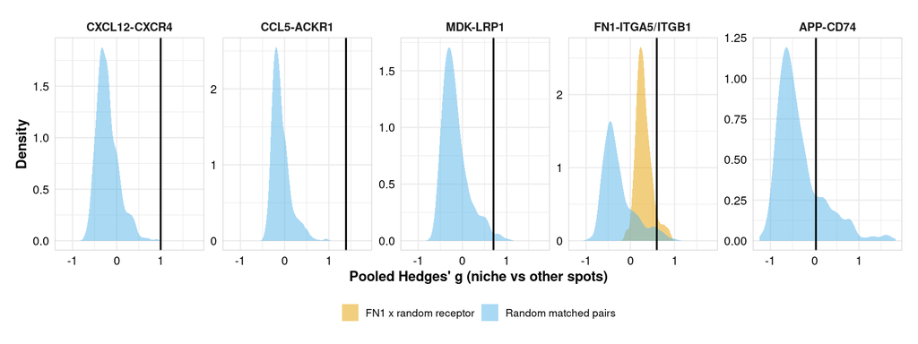

Figure 68: Pooled niche co-expression of each axis (vertical line) against 1,000 expression-matched random gene pairs; for FN1-ITGA5/ITGB1, also against FN1 paired with random receptors.

```r
p_bench_sp <- ggplot(bench_sp$null_g %>% mutate(Axis = factor(axis_labels[axis_id], levels = axis_labels),
                                                null = if_else(null == "fn1_random_receptor", "FN1 x random receptor", "Random matched pairs")),
                     aes(x = g, fill = null)) +
  geom_density(alpha = 0.5, color = NA) +
  geom_vline(data = obs_c %>% mutate(Axis = factor(axis_labels[axis_id], levels = axis_labels)), aes(xintercept = g_obs), linewidth = 0.8) +
  facet_wrap(~Axis, ncol = 5, scales = "free_y") +
  scale_fill_manual(values = c("Random matched pairs" = "#56B4E9", "FN1 x random receptor" = "#E69F00")) +
  labs(x = "Pooled Hedges' g (niche vs other spots)", y = "Density", fill = NULL) +
  theme_publication() +
  theme(legend.position = "bottom")
ggsave(file.path(spatial_res_dir, "fig_spatial_benchmark.png"), p_bench_sp, width = 12, height = 4.5, dpi = 300)
p_bench_sp
```

### Sensitivity analyses

Three variants test whether the main result depends on its settings: the leave-patient-out reference, “high” defined at the 90th instead of the 75th percentile, and a two-ring neighborhood (the spot plus 18 neighbors). The lead axes keep their direction in all of them, and the CCL5-ACKR1 result holds with the leave-patient-out reference, a stricter high cutoff and a wider neighborhood.

```r
secs_lopo <- secs_primary
for (sid in names(rctd_weights$lopo)) secs_lopo[[sid]] <- prepare_section(sid, rctd_weights$lopo[[sid]])

sens_section <- bind_rows(
  run_axis_tests(secs_lopo) %>% mutate(analysis = "S1 leave-patient-out reference"),
  run_axis_tests(secs_primary, high_q = 0.9) %>% mutate(analysis = "S2 high at 90th percentile"),
  run_axis_tests(secs_primary, rings = 0:2) %>% mutate(analysis = "S3 two-ring neighborhood")
)
sens_pooled <- sens_section %>%
  group_by(analysis) %>%
  group_modify(~ pool_axis_tests(.x)) %>%
  ungroup()
write_csv(sens_section, file.path(spatial_res_dir, "spatial_sensitivity_by_section.csv"))
write_csv(sens_pooled, file.path(spatial_res_dir, "spatial_sensitivity_pooled.csv"))
knitr::kable(
  bind_rows(spatial_pooled %>% mutate(analysis = "Main analysis"), sens_pooled) %>%
    filter(axis_id %in% c("fn1_itga5_itgb1", "ccl5_ackr1")) %>%
    arrange(factor(axis_id, levels = spatial_axes$axis_id), test, analysis) %>%
    transmute(Axis = axis_labels[axis_id], test, analysis, k, `Pooled (95% CI)` = fmt_pooled(test, est, lo, hi),
              q = signif(q_bh, 3), `Expected direction` = paste0(n_expected_dir, "/", k), criterion_met),
  caption = "Sensitivity analyses for the lead axes (BH within each family); all axes are in the CSV"
)
```

Sensitivity analyses for the lead axes (BH within each family); all axes are in the CSV

| Axis | test | analysis | k | Pooled (95% CI) | q | Expected direction | criterion_met |
| --- | --- | --- | --- | --- | --- | --- | --- |
| CCL5-ACKR1 | (a) weight correlation | Main analysis | 6 | rho 0.30 (0.20 to 0.39) | 0.001700 | 6/6 | TRUE |
| CCL5-ACKR1 | (a) weight correlation | S1 leave-patient-out reference | 6 | rho 0.30 (0.20 to 0.39) | 0.001630 | 6/6 | TRUE |
| CCL5-ACKR1 | (a) weight correlation | S2 high at 90th percentile | 6 | rho 0.30 (0.20 to 0.39) | 0.000848 | 6/6 | TRUE |
| CCL5-ACKR1 | (a) weight correlation | S3 two-ring neighborhood | 6 | rho 0.30 (0.20 to 0.39) | 0.001700 | 6/6 | TRUE |
| CCL5-ACKR1 | (b) neighborhood enrichment | Main analysis | 6 | 1.02 (0.57 to 1.47) | 0.002880 | 6/6 | TRUE |
| CCL5-ACKR1 | (b) neighborhood enrichment | S1 leave-patient-out reference | 6 | 1.00 (0.54 to 1.47) | 0.002720 | 6/6 | TRUE |
| CCL5-ACKR1 | (b) neighborhood enrichment | S2 high at 90th percentile | 6 | 1.34 (0.96 to 1.72) | 0.000777 | 6/6 | TRUE |
| CCL5-ACKR1 | (b) neighborhood enrichment | S3 two-ring neighborhood | 6 | 0.96 (0.44 to 1.48) | 0.005130 | 6/6 | TRUE |
| CCL5-ACKR1 | (c) L-R co-expression | Main analysis | 6 | 1.39 (0.73 to 2.05) | 0.002880 | 6/6 | TRUE |
| CCL5-ACKR1 | (c) L-R co-expression | S1 leave-patient-out reference | 6 | 1.33 (0.71 to 1.95) | 0.002720 | 6/6 | TRUE |
| CCL5-ACKR1 | (c) L-R co-expression | S2 high at 90th percentile | 6 | 1.65 (0.98 to 2.31) | 0.001410 | 6/6 | TRUE |
| CCL5-ACKR1 | (c) L-R co-expression | S3 two-ring neighborhood | 6 | 1.20 (0.59 to 1.81) | 0.005130 | 6/6 | TRUE |
| FN1-ITGA5/ITGB1 | (a) weight correlation | Main analysis | 6 | rho 0.31 (0.07 to 0.51) | 0.033100 | 6/6 | TRUE |
| FN1-ITGA5/ITGB1 | (a) weight correlation | S1 leave-patient-out reference | 6 | rho 0.30 (0.07 to 0.50) | 0.032300 | 6/6 | TRUE |
| FN1-ITGA5/ITGB1 | (a) weight correlation | S2 high at 90th percentile | 6 | rho 0.31 (0.07 to 0.51) | 0.048200 | 6/6 | TRUE |
| FN1-ITGA5/ITGB1 | (a) weight correlation | S3 two-ring neighborhood | 6 | rho 0.31 (0.07 to 0.51) | 0.033100 | 6/6 | TRUE |
| FN1-ITGA5/ITGB1 | (b) neighborhood enrichment | Main analysis | 6 | 0.55 (0.22 to 0.89) | 0.024900 | 6/6 | TRUE |
| FN1-ITGA5/ITGB1 | (b) neighborhood enrichment | S1 leave-patient-out reference | 6 | 0.56 (0.24 to 0.88) | 0.018400 | 6/6 | TRUE |
| FN1-ITGA5/ITGB1 | (b) neighborhood enrichment | S2 high at 90th percentile | 6 | 0.73 (0.09 to 1.37) | 0.048200 | 6/6 | TRUE |
| FN1-ITGA5/ITGB1 | (b) neighborhood enrichment | S3 two-ring neighborhood | 6 | 0.47 (0.15 to 0.79) | 0.033100 | 6/6 | TRUE |
| FN1-ITGA5/ITGB1 | (c) L-R co-expression | Main analysis | 6 | 0.60 (-0.05 to 1.24) | 0.062700 | 5/6 | FALSE |
| FN1-ITGA5/ITGB1 | (c) L-R co-expression | S1 leave-patient-out reference | 6 | 0.57 (-0.11 to 1.25) | 0.085200 | 5/6 | FALSE |
| FN1-ITGA5/ITGB1 | (c) L-R co-expression | S2 high at 90th percentile | 6 | 0.67 (-0.12 to 1.46) | 0.079500 | 5/6 | FALSE |
| FN1-ITGA5/ITGB1 | (c) L-R co-expression | S3 two-ring neighborhood | 6 | 0.68 (0.07 to 1.29) | 0.035900 | 6/6 | TRUE |

For HER2ST, a section enters the CCL5-ACKR1 tests only if ACKR1 is detected in at least 1% of its spots. Applying the same rule to the Visium sections removes 1142243F, where ACKR1 is detected in 0.2% of spots, and leaves the CCL5-ACKR1 result unchanged.

```r
low_ackr1 <- axis_detection %>% filter(gene == "ACKR1", pct_spots_detected < 1) %>% pull(section)
ackr1_filter_pooled <- pool_axis_tests(spatial_section_res %>% filter(axis_id == "ccl5_ackr1", !section %in% low_ackr1)) %>%
  mutate(sections_excluded = paste(low_ackr1, collapse = ", "))
write_csv(ackr1_filter_pooled, file.path(spatial_res_dir, "spatial_ccl5_ackr1_detection_filter.csv"))
knitr::kable(
  ackr1_filter_pooled %>%
    transmute(test, k, `Pooled (95% CI)` = fmt_pooled(test, est, lo, hi), q = signif(q_bh, 3),
              `Expected direction` = paste0(n_expected_dir, "/", k), criterion_met),
  caption = "CCL5-ACKR1 without the sections in which ACKR1 is detected in fewer than 1% of spots"
)
```

CCL5-ACKR1 without the sections in which ACKR1 is detected in fewer than 1% of spots

| test | k | Pooled (95% CI) | q | Expected direction | criterion_met |
| --- | --- | --- | --- | --- | --- |
| (a) weight correlation | 5 | rho 0.31 (0.19 to 0.42) | 0.00309 | 5/5 | TRUE |
| (b) neighborhood enrichment | 5 | 1.00 (0.39 to 1.60) | 0.01040 | 5/5 | TRUE |
| (c) L-R co-expression | 5 | 1.57 (0.98 to 2.16) | 0.00309 | 5/5 | TRUE |

### Exploratory analyses

Further analyses probe the lead axes and are corrected as one family. They cover spots annotated as stroma (E1), the tumor-stroma boundary (E2), finer cell-type subsets from the second RCTD reference (E3, myCAF-like and iCAF-like senders and CD8+ T-cell senders), the enrichment as a function of distance (E4), the co-expression of every measurable consensus interaction in its own niche (E5), the FN1 receiver program and the endothelial MHC-II program within endothelial-high spots (E6), and T-cell weight around FN1-high stroma (E7).

```r
secs_fine <- lapply(setNames(names(rctd_weights$fine), names(rctd_weights$fine)), function(sid) prepare_section(sid, rctd_weights$fine[[sid]]))
lead_axes <- spatial_axes %>% filter(axis_id %in% c("fn1_itga5_itgb1", "ccl5_ackr1"))
fn1_axis <- spatial_axes %>% filter(axis_id == "fn1_itga5_itgb1")

# E1: stroma-annotated spots only
e1 <- bind_rows(lapply(secs_primary, function(sec) {
  keep <- sec$spots$annotation == "Stroma"
  if (sum(keep) < 30) return(NULL)
  run_axis_tests(list(subset_section(sec, keep)), axes = lead_axes)
})) %>% mutate(analysis = "E1 stroma spots", label = paste(axis_labels[axis_id], test))

# E2: FN1 L-R score at the tumor-stroma boundary
e2 <- bind_rows(lapply(secs_primary, function(sec) {
  A <- ring_adjacency(sec, 0:1)
  boundary <- as.vector(A %*% high_spots(sec$w[, "Cancer"])) > 0 & as.vector(A %*% high_spots(sec$w[, "Fibroblast"])) > 0
  lr <- nb_mean(A, gene_score(sec$expr, "FN1")) * nb_mean(A, gene_score(sec$expr, "ITGA5_ITGB1"))
  hedges_g(lr, boundary) %>% mutate(section = sec$sid, n_niche = sum(boundary))
})) %>% mutate(analysis = "E2 tumor-stroma boundary", axis_id = "fn1_itga5_itgb1", test = "(c) L-R co-expression", label = "FN1-ITGA5/ITGB1 L-R score, boundary vs other spots")

# E3: CAF and T-cell subsets from the finer reference
subset_axes <- tibble::tribble(
  ~axis_id, ~ligand, ~receptor, ~sender, ~receiver, ~label,
  "fn1_itga5_itgb1", "FN1", "ITGA5_ITGB1", "CAF_myCAF", "Endothelial", "FN1-ITGA5/ITGB1, myCAF-like sender",
  "fn1_itga5_itgb1", "FN1", "ITGA5_ITGB1", "CAF_iCAF", "Endothelial", "FN1-ITGA5/ITGB1, iCAF-like sender",
  "ccl5_ackr1", "CCL5", "ACKR1", "T_CD8", "Endothelial_ACKR1", "CCL5-ACKR1, CD8+ T-cell sender"
)
e3 <- bind_rows(lapply(seq_len(nrow(subset_axes)), function(k) {
  run_axis_tests(secs_fine, axes = subset_axes[k, ]) %>% filter(test != "(a) weight correlation") %>% mutate(label = paste(subset_axes$label[k], test))
})) %>% mutate(analysis = "E3 subsets")

# E6: FN1 receiver program and endothelial MHC-II within endothelial-high spots
e6_genes_path <- file.path(spatial_obj_dir, "e6_programme_genes.qs2")
if (file.exists(e6_genes_path)) {
  e6_genes <- qs_read(e6_genes_path)
} else {
  fn1_up <- read_csv("results/revision/pseudobulk_pooled_de_all.csv", show_col_types = FALSE) %>%
    filter(axis_id == "fn1_itga5_itgb1", FDR < 0.05, logFC > 0) %>%
    pull(gene)
  ref_labels <- qs_read(file.path(spatial_obj_dir, "rctd_reference_labels.qs2"))
  ref_counts <- SeuratObject::LayerData(qs_read("objects/seu_wu_filtered.qs2"), assay = "RNA", layer = "counts")
  lib_size <- Matrix::colSums(ref_counts)
  ref_lognorm <- log1p(t(t(as.matrix(ref_counts[intersect(fn1_up, rownames(ref_counts)), ])) / lib_size * 1e4))
  fib_mean <- rowMeans(ref_lognorm[, ref_labels$label_primary == "Fibroblast"])
  endo_mean <- rowMeans(ref_lognorm[, grepl("^Endothelial", ref_labels$label_primary)])
  e6_genes <- list(fn1_up = fn1_up, fn1_programme = names(which(endo_mean >= fib_mean)),
                   mhc2 = c("HLA-DRA", "HLA-DRB1", "HLA-DPA1", "HLA-DPB1", "HLA-DMA", "CD74", "CIITA"))
  qs_save(e6_genes, e6_genes_path)
}
programme_score <- function(sec, genes) {
  g <- intersect(genes, rownames(sec$expr))
  colMeans(t(scale(t(as.matrix(sec$expr[g, , drop = FALSE])))), na.rm = TRUE)
}
e6 <- bind_rows(lapply(secs_primary, function(sec) {
  A <- ring_adjacency(sec, 0:1)
  endo_high <- high_spots(sec$w[, "Endothelial"]) == 1
  lr <- nb_mean(A, gene_score(sec$expr, "FN1")) * nb_mean(A, gene_score(sec$expr, "ITGA5_ITGB1"))
  bind_rows(
    spearman_stat(lr[endo_high], programme_score(sec, e6_genes$fn1_programme)[endo_high]) %>% mutate(label = "FN1 L-R score vs FN1 receiver program (endothelial-high spots)", expected_sign = 1),
    spearman_stat(lr[endo_high], programme_score(sec, e6_genes$mhc2)[endo_high]) %>% mutate(label = "FN1 L-R score vs MHC-II score (endothelial-high spots)", expected_sign = -1)
  ) %>% mutate(section = sec$sid, n_niche = sum(endo_high))
})) %>% mutate(analysis = "E6 receiver program", axis_id = "fn1_itga5_itgb1", test = "rho")

# E7: T-cell weight in FN1-high neighborhoods
e7 <- bind_rows(lapply(names(secs_primary), function(sid) {
  sec <- secs_primary[[sid]]
  A <- ring_adjacency(sec, 0:1)
  fn1_nb <- nb_mean(A, gene_score(sec$expr, "FN1"))
  fn1_high <- fn1_nb >= quantile(fn1_nb, 0.75)
  cd8 <- secs_fine[[sid]]$w[rownames(sec$w), "T_CD8"]
  bind_rows(
    hedges_g(sec$w[, "T_cell"], fn1_high) %>% mutate(label = "T-cell weight, FN1-high neighborhoods vs other spots"),
    hedges_g(cd8, fn1_high) %>% mutate(label = "CD8+ T-cell weight, FN1-high neighborhoods vs other spots")
  ) %>% mutate(section = sid, n_niche = sum(fn1_high), expected_sign = -1)
})) %>% mutate(analysis = "E7 immune exclusion", axis_id = "fn1_itga5_itgb1", test = "g")

exploratory_section <- bind_rows(e1, e2, e3, e6, e7) %>% mutate(expected_sign = coalesce(expected_sign, 1))
exploratory_pooled <- exploratory_section %>%
  group_by(analysis, label) %>%
  group_modify(~ pool_sections(.x$est, .x$var, expected_sign = .x$expected_sign[1]) %>% mutate(expected_sign = .x$expected_sign[1], test = .x$test[1])) %>%
  ungroup() %>%
  mutate(q_bh = p.adjust(p, method = "BH"),
         criterion_met = !is.na(est) & sign(est) == expected_sign & q_bh < 0.05 & n_expected_dir >= 5)
write_csv(exploratory_section, file.path(spatial_res_dir, "spatial_exploratory_by_section.csv"))
write_csv(exploratory_pooled, file.path(spatial_res_dir, "spatial_exploratory_pooled.csv"))
knitr::kable(
  exploratory_pooled %>%
    transmute(analysis, label, k, `Expected sign` = expected_sign,
              `Pooled (95% CI)` = ifelse(test %in% c("(a) weight correlation", "rho"), sprintf("rho %.2f (%.2f to %.2f)", tanh(est), tanh(lo), tanh(hi)), sprintf("%.2f (%.2f to %.2f)", est, lo, hi)),
              p = signif(p, 3), q = signif(q_bh, 3), `Expected direction` = paste0(n_expected_dir, "/", k), criterion_met),
  caption = "Exploratory family (BH across all rows): pooled over sections, random effects with Knapp-Hartung"
)
```

Exploratory family (BH across all rows): pooled over sections, random effects with Knapp-Hartung

| analysis | label | k | Expected sign | Pooled (95% CI) | p | q | Expected direction | criterion_met |
| --- | --- | --- | --- | --- | --- | --- | --- | --- |
| E1 stroma spots | CCL5-ACKR1 (a) weight correlation | 6 | 1 | rho 0.21 (0.17 to 0.25) | 0.000030 | 0.00051 | 6/6 | TRUE |
| E1 stroma spots | CCL5-ACKR1 (b) neighborhood enrichment | 5 | 1 | 0.27 (-0.11 to 0.66) | 0.122000 | 0.18400 | 4/5 | FALSE |
| E1 stroma spots | CCL5-ACKR1 (c) L-R co-expression | 4 | 1 | 0.66 (0.05 to 1.27) | 0.041400 | 0.10700 | 4/4 | FALSE |
| E1 stroma spots | FN1-ITGA5/ITGB1 (a) weight correlation | 6 | 1 | rho 0.07 (-0.23 to 0.36) | 0.585000 | 0.59000 | 4/6 | FALSE |
| E1 stroma spots | FN1-ITGA5/ITGB1 (b) neighborhood enrichment | 6 | 1 | 0.15 (-0.51 to 0.80) | 0.590000 | 0.59000 | 5/6 | FALSE |
| E1 stroma spots | FN1-ITGA5/ITGB1 (c) L-R co-expression | 6 | 1 | 0.67 (0.16 to 1.17) | 0.019300 | 0.06550 | 5/6 | FALSE |
| E2 tumor-stroma boundary | FN1-ITGA5/ITGB1 L-R score, boundary vs other spots | 6 | 1 | 0.33 (-0.05 to 0.71) | 0.075000 | 0.14500 | 6/6 | FALSE |
| E3 subsets | CCL5-ACKR1, CD8+ T-cell sender (b) neighborhood enrichment | 5 | 1 | 0.77 (-0.13 to 1.67) | 0.076800 | 0.14500 | 4/5 | FALSE |
| E3 subsets | CCL5-ACKR1, CD8+ T-cell sender (c) L-R co-expression | 5 | 1 | 1.26 (0.64 to 1.87) | 0.004830 | 0.02740 | 5/5 | TRUE |
| E3 subsets | FN1-ITGA5/ITGB1, iCAF-like sender (b) neighborhood enrichment | 6 | 1 | 0.63 (-0.32 to 1.58) | 0.151000 | 0.18400 | 5/6 | FALSE |
| E3 subsets | FN1-ITGA5/ITGB1, iCAF-like sender (c) L-R co-expression | 6 | 1 | -0.46 (-1.12 to 0.20) | 0.133000 | 0.18400 | 1/6 | FALSE |
| E3 subsets | FN1-ITGA5/ITGB1, myCAF-like sender (b) neighborhood enrichment | 6 | 1 | 0.40 (0.02 to 0.78) | 0.043900 | 0.10700 | 5/6 | FALSE |
| E3 subsets | FN1-ITGA5/ITGB1, myCAF-like sender (c) L-R co-expression | 6 | 1 | 0.72 (0.20 to 1.24) | 0.015800 | 0.06550 | 6/6 | FALSE |
| E6 receiver program | FN1 L-R score vs FN1 receiver program (endothelial-high spots) | 6 | 1 | rho 0.35 (0.23 to 0.45) | 0.000715 | 0.00608 | 6/6 | TRUE |
| E6 receiver program | FN1 L-R score vs MHC-II score (endothelial-high spots) | 6 | -1 | rho 0.20 (-0.05 to 0.44) | 0.097000 | 0.16500 | 2/6 | FALSE |
| E7 immune exclusion | CD8+ T-cell weight, FN1-high neighborhoods vs other spots | 6 | -1 | 0.28 (-0.13 to 0.69) | 0.142000 | 0.18400 | 1/6 | FALSE |
| E7 immune exclusion | T-cell weight, FN1-high neighborhoods vs other spots | 6 | -1 | 0.16 (-0.31 to 0.62) | 0.421000 | 0.47700 | 2/6 | FALSE |

```r
# E4: distance decay of the axis-pair enrichment at exact ring distances (descriptive)
e4 <- bind_rows(lapply(secs_primary, function(sec) {
  bind_rows(lapply(0:3, function(d) {
    A <- ring_adjacency(sec, d)
    bind_rows(lapply(seq_len(nrow(hetero_axes)), function(k) {
      enrich_stat(high_spots(sec$w[, hetero_axes$sender[k]]), high_spots(sec$w[, hetero_axes$receiver[k]]), A) %>%
        mutate(axis_id = hetero_axes$axis_id[k], ring = d)
    }))
  })) %>% mutate(section = sec$sid)
}))
e4_pooled <- e4 %>% group_by(axis_id, ring) %>% group_modify(~ pool_sections(.x$est, .x$var)) %>% ungroup()
write_csv(e4, file.path(spatial_res_dir, "spatial_distance_decay_by_section.csv"))
write_csv(e4_pooled, file.path(spatial_res_dir, "spatial_distance_decay_pooled.csv"))
```

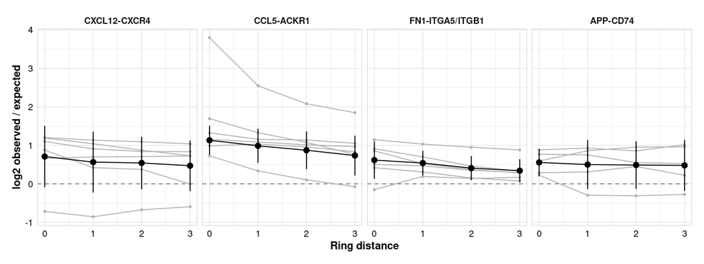

Figure 69: Sender-receiver enrichment as a function of ring distance. Gray, individual sections; black, pooled estimate with 95% CI. Ring 0 is the same spot; one ring is about 100 µm.

```r
p_decay <- ggplot(e4 %>% mutate(Axis = factor(axis_labels[axis_id], levels = axis_labels)), aes(x = ring, y = est)) +
  geom_hline(yintercept = 0, linetype = "dashed", color = "grey50") +
  geom_line(aes(group = section), color = "grey70") +
  geom_point(aes(group = section), color = "grey70", size = 1) +
  geom_pointrange(data = e4_pooled %>% mutate(Axis = factor(axis_labels[axis_id], levels = axis_labels)), aes(ymin = lo, ymax = hi), color = "black") +
  geom_line(data = e4_pooled %>% mutate(Axis = factor(axis_labels[axis_id], levels = axis_labels)), color = "black") +
  facet_wrap(~Axis, nrow = 1) +
  labs(x = "Ring distance", y = "log2 observed / expected") +
  theme_publication()
ggsave(file.path(spatial_res_dir, "fig_spatial_distance_decay.png"), p_decay, width = 12, height = 4.5, dpi = 300)
p_decay
```

```r
# E5: niche co-expression of every measurable consensus interaction in its own sender-receiver niche (descriptive)
consensus_sp <- read_csv("results/cross_cohort_comparison/consensus_interactions_all.csv", show_col_types = FALSE) %>%
  distinct(Source, Target, Ligand, Receptor) %>%
  rowwise() %>%
  filter(all(c(strsplit(Ligand, "_")[[1]], strsplit(Receptor, "_")[[1]]) %in% shared_genes_sp)) %>%
  ungroup() %>%
  transmute(axis_id = paste(Source, Target, Ligand, Receptor, sep = "|"), ligand = Ligand, receptor = Receptor, sender = Source, receiver = Target)
e5_section <- run_axis_tests(secs_primary, axes = consensus_sp, colocalisation = FALSE)
e5 <- e5_section %>%
  group_by(axis_id) %>%
  group_modify(~ pool_sections(.x$est, .x$var)) %>%
  ungroup() %>%
  mutate(percentile = 100 * (rank(est, na.last = "keep") - 1) / (sum(is.finite(est)) - 1)) %>%
  tidyr::separate(axis_id, c("sender", "receiver", "ligand", "receptor"), sep = "\\|", remove = FALSE) %>%
  arrange(desc(est))
write_csv(e5, file.path(spatial_res_dir, "spatial_consensus_pairs_coexpression.csv"))
knitr::kable(
  e5 %>%
    filter(paste(ligand, receptor) %in% paste(candidate_registry$ligand, candidate_registry$receptor)) %>%
    transmute(Interaction = paste0(ligand, "-", receptor, " (", sender, " to ", receiver, ")"), `Pooled g` = round(est, 3),
              `Expected direction` = paste0(n_expected_dir, "/", k), Percentile = round(percentile, 1), Rank = match(axis_id, e5$axis_id)),
  caption = sprintf("E5: the five axes among %d measurable consensus interactions, each scored in its own niche (Endothelial = both classes summed)", sum(is.finite(e5$est)))
)
```

E5: the five axes among 209 measurable consensus interactions, each scored in its own niche (Endothelial = both classes summed)

| Interaction | Pooled g | Expected direction | Percentile | Rank |
| --- | --- | --- | --- | --- |
| CCL5-ACKR1 (T_cell to Endothelial) | 1.011 | 6/6 | 94.2 | 13 |
| CXCL12-CXCR4 (Fibroblast to T_cell) | 0.994 | 6/6 | 91.8 | 18 |
| CXCL12-CXCR4 (Endothelial to T_cell) | 0.982 | 6/6 | 90.9 | 20 |
| CXCL12-CXCR4 (Fibroblast to Myeloid) | 0.880 | 6/6 | 81.2 | 40 |
| CXCL12-CXCR4 (Fibroblast to B_cell) | 0.820 | 5/5 | 76.0 | 51 |
| MDK-LRP1 (Fibroblast to Myeloid) | 0.705 | 6/6 | 65.9 | 72 |
| MDK-LRP1 (Fibroblast to Fibroblast) | 0.703 | 6/6 | 64.4 | 75 |
| FN1-ITGA5_ITGB1 (Fibroblast to Endothelial) | 0.598 | 5/6 | 58.7 | 87 |
| MDK-LRP1 (Endothelial to Fibroblast) | 0.585 | 6/6 | 57.7 | 89 |
| APP-CD74 (Endothelial to Myeloid) | 0.326 | 4/6 | 32.7 | 141 |
| MDK-LRP1 (Normal_epithelial to Fibroblast) | 0.233 | 4/6 | 24.0 | 159 |
| APP-CD74 (Normal_epithelial to Myeloid) | 0.183 | 3/6 | 20.7 | 166 |
| MDK-LRP1 (Cancer to Fibroblast) | 0.082 | 3/6 | 13.9 | 180 |
| APP-CD74 (Endothelial to B_cell) | 0.029 | 3/5 | 8.2 | 192 |

The exploratory results support the lead axes in some places and not in others. The CCL5-ACKR1 niches are concentrated in lymphocyte-rich regions and tertiary lymphoid structures (4.2-fold enrichment in lymphocyte and TLS spots), and with CD8+ T cells as the sender the co-expression remains clearly positive (g 1.26, q = 0.027). Within endothelial-high spots, FN1 co-expression tracks the endothelial basement-membrane and angiogenic program from the pseudobulk analysis (rho 0.35, q = 0.006). For FN1, co-expression with myCAF-like senders is positive in all six sections (g 0.72) but not significant (q = 0.066), and the iCAF-like result is null. Two things did not hold. We did not see immune exclusion around FN1-high stroma: T-cell weight is higher, not lower, there in four of six sections, so immune exclusion rests on the bulk CD8+ association alone. And we did not find the reduced endothelial MHC-II program in the spatial data, so we present it as a pseudobulk observation only. Among the other axes, CXCL12-CXCR4 co-expression is positive in all six sections (g 0.99, q = 0.007) and MDK-LRP1 is as well (g 0.70, q = 0.025, autocrine), whereas APP-CD74 co-localizes weakly (rho 0.26, q = 0.007) with null co-expression (g 0.03). These three are exploratory.

### Histological context

The distribution of niche spots across the pathologist’s annotation categories shows where each niche sits (descriptive, no test).

```r
niche_annotation <- bind_rows(lapply(secs_primary, function(sec) {
  bind_rows(lapply(seq_len(nrow(spatial_axes)), function(k) {
    tibble(section = sec$sid, axis_id = spatial_axes$axis_id[k], annotation = sec$spots$annotation,
           classification = sec$spots$classification, niche = niches_primary[[sec$sid]][[spatial_axes$axis_id[k]]]$niche)
  }))
}))
histology_table <- niche_annotation %>%
  group_by(axis_id, annotation) %>%
  summarise(niche_spots = sum(niche), all_spots = n(), .groups = "drop") %>%
  group_by(axis_id) %>%
  mutate(pct_of_niche = 100 * niche_spots / sum(niche_spots), pct_of_all = 100 * all_spots / sum(all_spots),
         pct_niche_within_category = 100 * niche_spots / all_spots) %>%
  ungroup() %>%
  mutate(annotation = factor(annotation, levels = annotation_levels)) %>%
  arrange(factor(axis_id, levels = spatial_axes$axis_id), annotation)
histology_by_section <- niche_annotation %>%
  group_by(section, axis_id, annotation) %>%
  summarise(niche_spots = sum(niche), all_spots = n(), .groups = "drop")
write_csv(histology_table, file.path(spatial_res_dir, "table_spatial_niche_by_annotation.csv"))
write_csv(histology_by_section, file.path(spatial_res_dir, "table_spatial_niche_by_annotation_by_section.csv"))
knitr::kable(
  histology_table %>% transmute(Axis = axis_labels[axis_id], annotation, niche_spots, `% of niche spots` = round(pct_of_niche, 1),
                                `% of all spots` = round(pct_of_all, 1), `% of category in niche` = round(pct_niche_within_category, 1)),
  caption = "Niche spots of each axis by collapsed pathologist annotation, against all QC spots (six sections pooled)"
)
```

Niche spots of each axis by collapsed pathologist annotation, against all QC spots (six sections pooled)

| Axis | annotation | niche_spots | % of niche spots | % of all spots | % of category in niche |
| --- | --- | --- | --- | --- | --- |
| CXCL12-CXCR4 | Invasive cancer | 111 | 2.7 | 2.7 | 26.6 |
| CXCL12-CXCR4 | Invasive cancer + stroma | 18 | 0.4 | 13.6 | 0.9 |
| CXCL12-CXCR4 | Invasive cancer + lymphocytes | 320 | 7.7 | 4.5 | 46.4 |
| CXCL12-CXCR4 | Invasive cancer + stroma + lymphocytes | 1943 | 46.7 | 52.6 | 24.0 |
| CXCL12-CXCR4 | Stroma | 1196 | 28.7 | 14.2 | 54.7 |
| CXCL12-CXCR4 | Lymphocytes / TLS | 286 | 6.9 | 2.3 | 79.4 |
| CXCL12-CXCR4 | Normal / DCIS | 239 | 5.7 | 5.2 | 29.7 |
| CXCL12-CXCR4 | Other | 52 | 1.2 | 4.8 | 7.1 |
| CCL5-ACKR1 | Invasive cancer | 49 | 1.7 | 2.7 | 11.7 |
| CCL5-ACKR1 | Invasive cancer + stroma | 11 | 0.4 | 13.6 | 0.5 |
| CCL5-ACKR1 | Invasive cancer + lymphocytes | 195 | 6.8 | 4.5 | 28.3 |
| CCL5-ACKR1 | Invasive cancer + stroma + lymphocytes | 1008 | 35.1 | 52.6 | 12.5 |
| CCL5-ACKR1 | Stroma | 973 | 33.9 | 14.2 | 44.5 |
| CCL5-ACKR1 | Lymphocytes / TLS | 283 | 9.8 | 2.3 | 78.6 |
| CCL5-ACKR1 | Normal / DCIS | 320 | 11.1 | 5.2 | 39.7 |
| CCL5-ACKR1 | Other | 35 | 1.2 | 4.8 | 4.8 |
| MDK-LRP1 | Invasive cancer | 174 | 2.0 | 2.7 | 41.6 |
| MDK-LRP1 | Invasive cancer + stroma | 1232 | 14.0 | 13.6 | 59.2 |
| MDK-LRP1 | Invasive cancer + lymphocytes | 354 | 4.0 | 4.5 | 51.3 |
| MDK-LRP1 | Invasive cancer + stroma + lymphocytes | 4305 | 49.0 | 52.6 | 53.2 |
| MDK-LRP1 | Stroma | 1827 | 20.8 | 14.2 | 83.5 |
| MDK-LRP1 | Lymphocytes / TLS | 287 | 3.3 | 2.3 | 79.7 |
| MDK-LRP1 | Normal / DCIS | 325 | 3.7 | 5.2 | 40.3 |
| MDK-LRP1 | Other | 289 | 3.3 | 4.8 | 39.4 |
| FN1-ITGA5/ITGB1 | Invasive cancer | 155 | 2.5 | 2.7 | 37.1 |
| FN1-ITGA5/ITGB1 | Invasive cancer + stroma | 556 | 8.9 | 13.6 | 26.7 |
| FN1-ITGA5/ITGB1 | Invasive cancer + lymphocytes | 222 | 3.6 | 4.5 | 32.2 |
| FN1-ITGA5/ITGB1 | Invasive cancer + stroma + lymphocytes | 3022 | 48.4 | 52.6 | 37.4 |
| FN1-ITGA5/ITGB1 | Stroma | 1596 | 25.6 | 14.2 | 73.0 |
| FN1-ITGA5/ITGB1 | Lymphocytes / TLS | 266 | 4.3 | 2.3 | 73.9 |
| FN1-ITGA5/ITGB1 | Normal / DCIS | 280 | 4.5 | 5.2 | 34.7 |
| FN1-ITGA5/ITGB1 | Other | 144 | 2.3 | 4.8 | 19.6 |
| APP-CD74 | Invasive cancer | 58 | 6.7 | 2.7 | 13.9 |
| APP-CD74 | Invasive cancer + stroma | 163 | 18.9 | 13.6 | 7.8 |
| APP-CD74 | Invasive cancer + lymphocytes | 118 | 13.7 | 4.5 | 17.1 |
| APP-CD74 | Invasive cancer + stroma + lymphocytes | 143 | 16.6 | 52.6 | 1.8 |
| APP-CD74 | Stroma | 265 | 30.7 | 14.2 | 12.1 |
| APP-CD74 | Lymphocytes / TLS | 69 | 8.0 | 2.3 | 19.2 |
| APP-CD74 | Normal / DCIS | 34 | 3.9 | 5.2 | 4.2 |
| APP-CD74 | Other | 13 | 1.5 | 4.8 | 1.8 |

```r
lymph_share <- niche_annotation %>%
  mutate(lymphocyte_category = grepl("ymphocyte|TLS", classification), stroma_category = grepl("troma", classification)) %>%
  group_by(axis_id) %>%
  summarise(pct_niche_lymphocyte = 100 * mean(lymphocyte_category[niche]), pct_all_lymphocyte = 100 * mean(lymphocyte_category),
            pct_niche_stroma = 100 * mean(stroma_category[niche]), pct_all_stroma = 100 * mean(stroma_category), .groups = "drop")
write_csv(lymph_share, file.path(spatial_res_dir, "table_spatial_niche_lymphocyte_stroma_share.csv"))
knitr::kable(lymph_share %>% mutate(Axis = axis_labels[axis_id], .before = 1) %>% select(-axis_id), digits = 1,
             caption = "Share of niche spots in annotation categories that mention lymphocytes (or TLS) or stroma, against all QC spots")
```

Share of niche spots in annotation categories that mention lymphocytes (or TLS) or stroma, against all QC spots

| Axis | pct_niche_lymphocyte | pct_all_lymphocyte | pct_niche_stroma | pct_all_stroma |
| --- | --- | --- | --- | --- |
| APP-CD74 | 38.2 | 62.9 | 66.2 | 82 |
| CCL5-ACKR1 | 58.4 | 62.9 | 69.3 | 82 |
| CXCL12-CXCR4 | 65.5 | 62.9 | 75.9 | 82 |
| FN1-ITGA5/ITGB1 | 59.7 | 62.9 | 83.2 | 82 |
| MDK-LRP1 | 59.2 | 62.9 | 84.1 | 82 |

```r
fn1_tcell <- bind_rows(lapply(names(secs_primary), function(sid) {
  sec <- secs_primary[[sid]]
  A <- ring_adjacency(sec, 0:1)
  fn1_nb <- nb_mean(A, gene_score(sec$expr, "FN1"))
  fn1_high <- fn1_nb >= quantile(fn1_nb, 0.75)
  cd8 <- secs_fine[[sid]]$w[rownames(sec$w), "T_CD8"]
  tibble(section = sid, t_weight_fn1_high = mean(sec$w[fn1_high, "T_cell"]), t_weight_other = mean(sec$w[!fn1_high, "T_cell"]),
         cd8_weight_fn1_high = mean(cd8[fn1_high]), cd8_weight_other = mean(cd8[!fn1_high]))
}))
write_csv(fn1_tcell, file.path(spatial_res_dir, "table_spatial_fn1_high_tcell_weight.csv"))
knitr::kable(fn1_tcell, digits = 3, caption = "Mean T-cell and CD8+ T-cell weight in FN1-high neighborhoods and in the rest of each section")
```

Mean T-cell and CD8+ T-cell weight in FN1-high neighborhoods and in the rest of each section

| section | t_weight_fn1_high | t_weight_other | cd8_weight_fn1_high | cd8_weight_other |
| --- | --- | --- | --- | --- |
| 1142243F | 0.029 | 0.018 | 0.012 | 0.006 |
| 1160920F | 0.074 | 0.066 | 0.023 | 0.015 |
| CID4290 | 0.004 | 0.004 | 0.001 | 0.001 |
| CID4465 | 0.023 | 0.055 | 0.007 | 0.014 |
| CID44971 | 0.078 | 0.054 | 0.016 | 0.005 |
| CID4535 | 0.111 | 0.059 | 0.022 | 0.011 |

### Maps

For each axis, the maps show the H&E image beside the sender weight, the receiver weight and the ligand-receptor co-expression score of the neighborhoods, for the representative section (the section whose co-expression effect is closest to the pooled estimate; Figure 73 and Figure 71) and for all six sections. Colors are scaled per panel.

```r
library(png)

spot_map <- function(sec, values, title, palette = "magma") {
  ggplot(data.frame(x = sec$spots$pxl_col, y = -sec$spots$pxl_row, v = values), aes(x = x, y = y, color = v)) +
    geom_point(size = 0.55) +
    scale_color_viridis_c(option = palette, name = NULL) +
    coord_fixed(xlim = range(sec$spots$pxl_col) + c(-150, 150), ylim = -rev(range(sec$spots$pxl_row)) + c(-150, 150), expand = FALSE) +
    labs(title = title) +
    theme_void(base_size = 13) +
    theme(plot.title = element_text(size = 13, face = "bold", hjust = 0.5), legend.key.height = unit(0.6, "cm"), legend.key.width = unit(0.35, "cm"))
}
# H&E drawn in full-resolution pixel coordinates, so it lines up with the spot maps
he_panel <- function(sid, title) {
  img <- readPNG(file.path(spatial_dir, "spatial", paste0(sid, "_spatial"), "tissue_lowres_image.png"))
  sc <- visium[[sid]]$scalef$tissue_lowres_scalef
  sp <- visium[[sid]]$spots
  pad <- 150
  ggplot() +
    annotation_raster(img, xmin = 0, xmax = dim(img)[2] / sc, ymin = -dim(img)[1] / sc, ymax = 0) +
    coord_fixed(xlim = range(sp$pxl_col) + c(-pad, pad), ylim = -rev(range(sp$pxl_row)) + c(-pad, pad), expand = FALSE) +
    labs(title = title) +
    theme_void(base_size = 13) +
    theme(plot.title = element_text(size = 13, face = "bold", hjust = 0.5))
}
axis_row <- function(ax, sid) {
  sec <- secs_primary[[sid]]
  A <- ring_adjacency(sec, 0:1)
  lr <- nb_mean(A, gene_score(sec$expr, ax$ligand)) * nb_mean(A, gene_score(sec$expr, ax$receptor))
  he_panel(sid, sprintf("H&E (%s)", sid)) +
    spot_map(sec, sec$w[, ax$sender], paste("Sender:", ax$sender), "viridis") +
    spot_map(sec, sec$w[, ax$receiver], paste("Receiver:", ax$receiver), "viridis") +
    spot_map(sec, lr, sprintf("%s x %s (neighborhood)", ax$ligand, gsub("_", "/", ax$receptor)), "magma") +
    plot_layout(nrow = 1)
}

representative <- spatial_section_res %>%
  filter(test == "(c) L-R co-expression", is.finite(est)) %>%
  left_join(spatial_pooled %>% filter(test == "(c) L-R co-expression") %>% select(axis_id, pooled = est), by = "axis_id") %>%
  group_by(axis_id) %>%
  slice_min(abs(est - pooled), n = 1, with_ties = FALSE) %>%
  ungroup() %>%
  select(axis_id, section, g = est, pooled)
write_csv(representative, file.path(spatial_res_dir, "spatial_representative_sections.csv"))

fig1 <- wrap_plots(lapply(spatial_axes$axis_id, function(a) axis_row(spatial_axes[spatial_axes$axis_id == a, ], representative$section[representative$axis_id == a])), ncol = 1)
ggsave(file.path(spatial_res_dir, "fig1_spatial_representative.png"), fig1, width = 14, height = 19, dpi = 300)

for (a in spatial_axes$axis_id) {
  figs <- wrap_plots(lapply(names(secs_primary), function(sid) axis_row(spatial_axes[spatial_axes$axis_id == a, ], sid)), ncol = 1)
  ggsave(file.path(spatial_res_dir, sprintf("figS_spatial_%s_all_sections.png", a)), figs, width = 14, height = 23, dpi = 200)
}
```

````r
spatial_titles <- axis_labels[spatial_axes$axis_id]
fig_tabs(
  c("```{r}",
    "#| label: fig-spatial-rep-{{key}}",
    "#| eval: true",
    "#| fig-cap: \"{{title}} in the representative Visium section: H&E image, sender weight, receiver weight and neighborhood ligand-receptor score.\"",
    "#| fig-width: 14",
    "#| fig-height: 3.8",
    "#| fig-format: jpeg",
    "#| fig-dpi: 55",
    "#| dev.args: !expr list(quality = 80)",
    "axis_row(spatial_axes[spatial_axes$axis_id == \"{{key}}\", ], representative$section[representative$axis_id == \"{{key}}\"])",
    "```", ""),
  keys = spatial_axes$axis_id,
  titles = spatial_titles
)
````

**CXCL12-CXCR4**

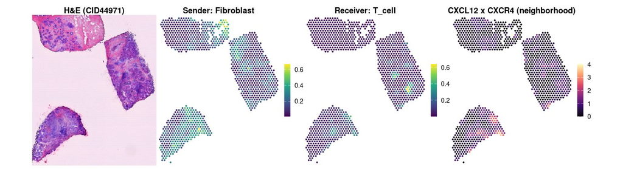

Figure 70: CXCL12-CXCR4 in the representative Visium section: H&E image, sender weight, receiver weight and neighborhood ligand-receptor score.

```r
axis_row(spatial_axes[spatial_axes$axis_id == "cxcl12_cxcr4", ], representative$section[representative$axis_id == "cxcl12_cxcr4"])
```

**CCL5-ACKR1**

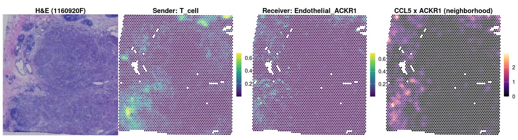

Figure 71: CCL5-ACKR1 in the representative Visium section: H&E image, sender weight, receiver weight and neighborhood ligand-receptor score.

```r
axis_row(spatial_axes[spatial_axes$axis_id == "ccl5_ackr1", ], representative$section[representative$axis_id == "ccl5_ackr1"])
```

**MDK-LRP1**

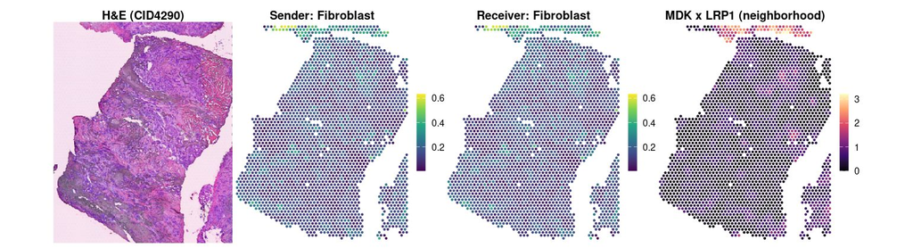

Figure 72: MDK-LRP1 in the representative Visium section: H&E image, sender weight, receiver weight and neighborhood ligand-receptor score.

```r
axis_row(spatial_axes[spatial_axes$axis_id == "mdk_lrp1", ], representative$section[representative$axis_id == "mdk_lrp1"])
```

**FN1-ITGA5/ITGB1**

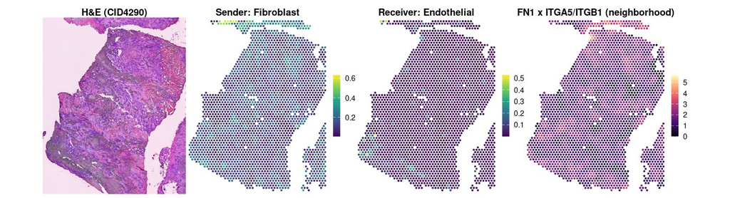

Figure 73: FN1-ITGA5/ITGB1 in the representative Visium section: H&E image, sender weight, receiver weight and neighborhood ligand-receptor score.

```r
axis_row(spatial_axes[spatial_axes$axis_id == "fn1_itga5_itgb1", ], representative$section[representative$axis_id == "fn1_itga5_itgb1"])
```

**APP-CD74**

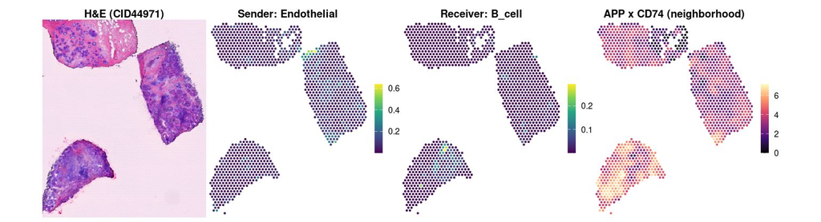

Figure 74: APP-CD74 in the representative Visium section: H&E image, sender weight, receiver weight and neighborhood ligand-receptor score.

```r
axis_row(spatial_axes[spatial_axes$axis_id == "app_cd74", ], representative$section[representative$axis_id == "app_cd74"])
```

The same maps for all six sections follow, one tab per axis.

````r
fig_tabs(
  c("```{r}",
    "#| label: fig-spatial-all-{{key}}",
    "#| eval: true",
    "#| fig-cap: \"{{title}} in all six Visium sections (rows): H&E image, sender weight, receiver weight and neighborhood ligand-receptor score.\"",
    "#| fig-width: 14",
    "#| fig-height: 23",
    "#| fig-format: jpeg",
    "#| fig-dpi: 44",
    "#| dev.args: !expr list(quality = 60)",
    "wrap_plots(lapply(names(secs_primary), function(sid) axis_row(spatial_axes[spatial_axes$axis_id == \"{{key}}\", ], sid)), ncol = 1)",
    "```", ""),
  keys = spatial_axes$axis_id,
  titles = spatial_titles
)
````

**CXCL12-CXCR4**

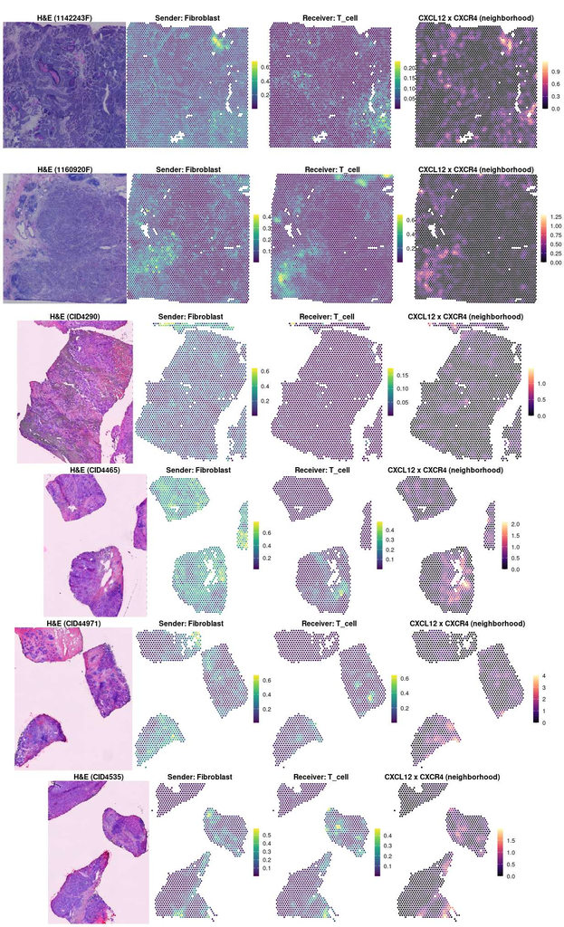

Figure 75: CXCL12-CXCR4 in all six Visium sections (rows): H&E image, sender weight, receiver weight and neighborhood ligand-receptor score.

```r
wrap_plots(lapply(names(secs_primary), function(sid) axis_row(spatial_axes[spatial_axes$axis_id == "cxcl12_cxcr4", ], sid)), ncol = 1)
```

**CCL5-ACKR1**

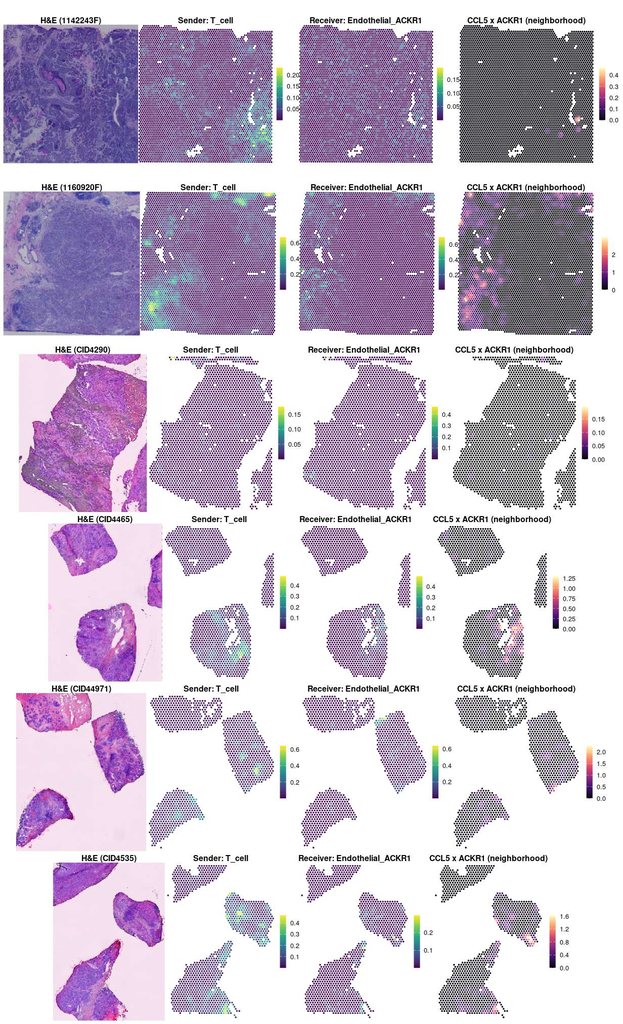

Figure 76: CCL5-ACKR1 in all six Visium sections (rows): H&E image, sender weight, receiver weight and neighborhood ligand-receptor score.

```r
wrap_plots(lapply(names(secs_primary), function(sid) axis_row(spatial_axes[spatial_axes$axis_id == "ccl5_ackr1", ], sid)), ncol = 1)
```

**MDK-LRP1**

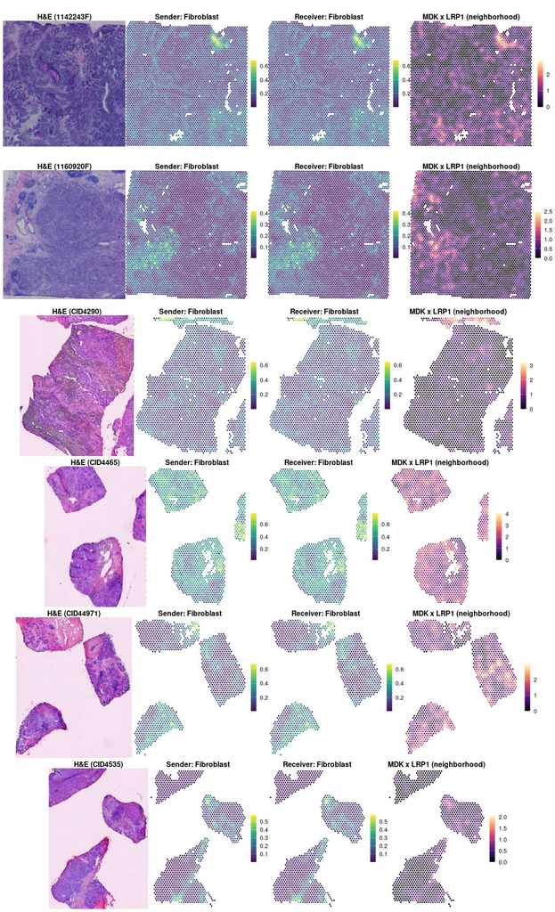

Figure 77: MDK-LRP1 in all six Visium sections (rows): H&E image, sender weight, receiver weight and neighborhood ligand-receptor score.

```r
wrap_plots(lapply(names(secs_primary), function(sid) axis_row(spatial_axes[spatial_axes$axis_id == "mdk_lrp1", ], sid)), ncol = 1)
```

**FN1-ITGA5/ITGB1**

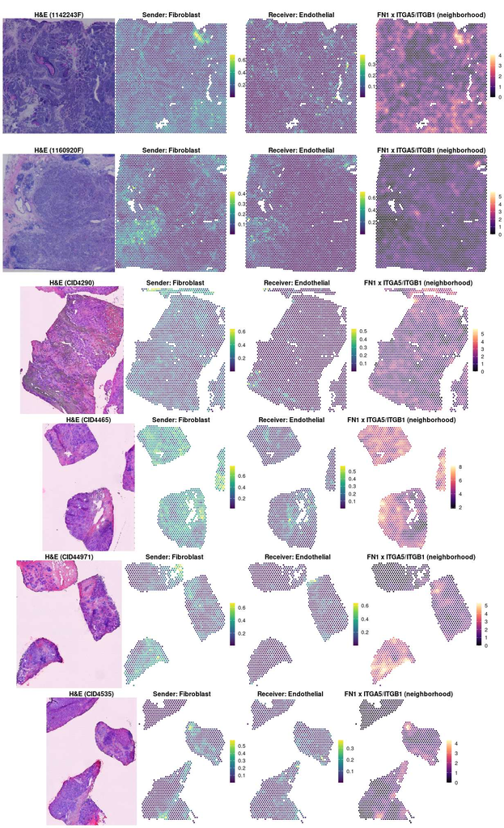

Figure 78: FN1-ITGA5/ITGB1 in all six Visium sections (rows): H&E image, sender weight, receiver weight and neighborhood ligand-receptor score.

```r
wrap_plots(lapply(names(secs_primary), function(sid) axis_row(spatial_axes[spatial_axes$axis_id == "fn1_itga5_itgb1", ], sid)), ncol = 1)
```

**APP-CD74**

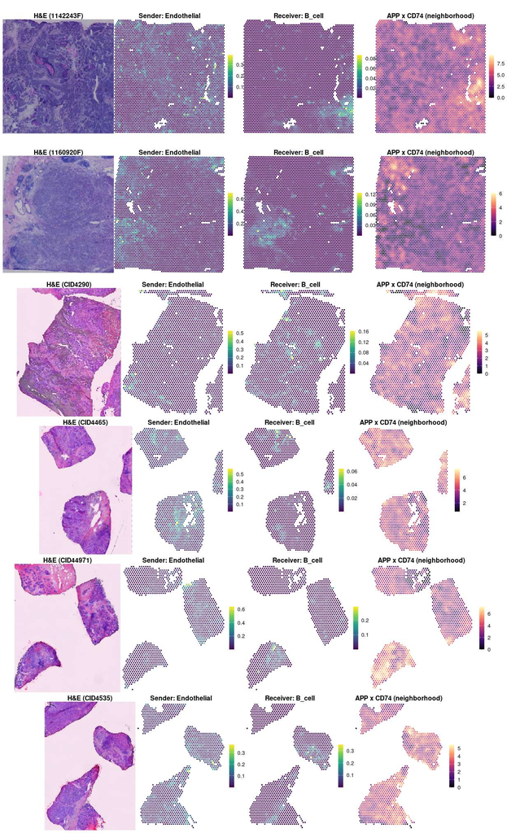

Figure 79: APP-CD74 in all six Visium sections (rows): H&E image, sender weight, receiver weight and neighborhood ligand-receptor score.

```r
wrap_plots(lapply(names(secs_primary), function(sid) axis_row(spatial_axes[spatial_axes$axis_id == "app_cd74", ], sid)), ncol = 1)
```

The forest plot summarizes the three tests for every axis, per section and pooled (Figure 80).

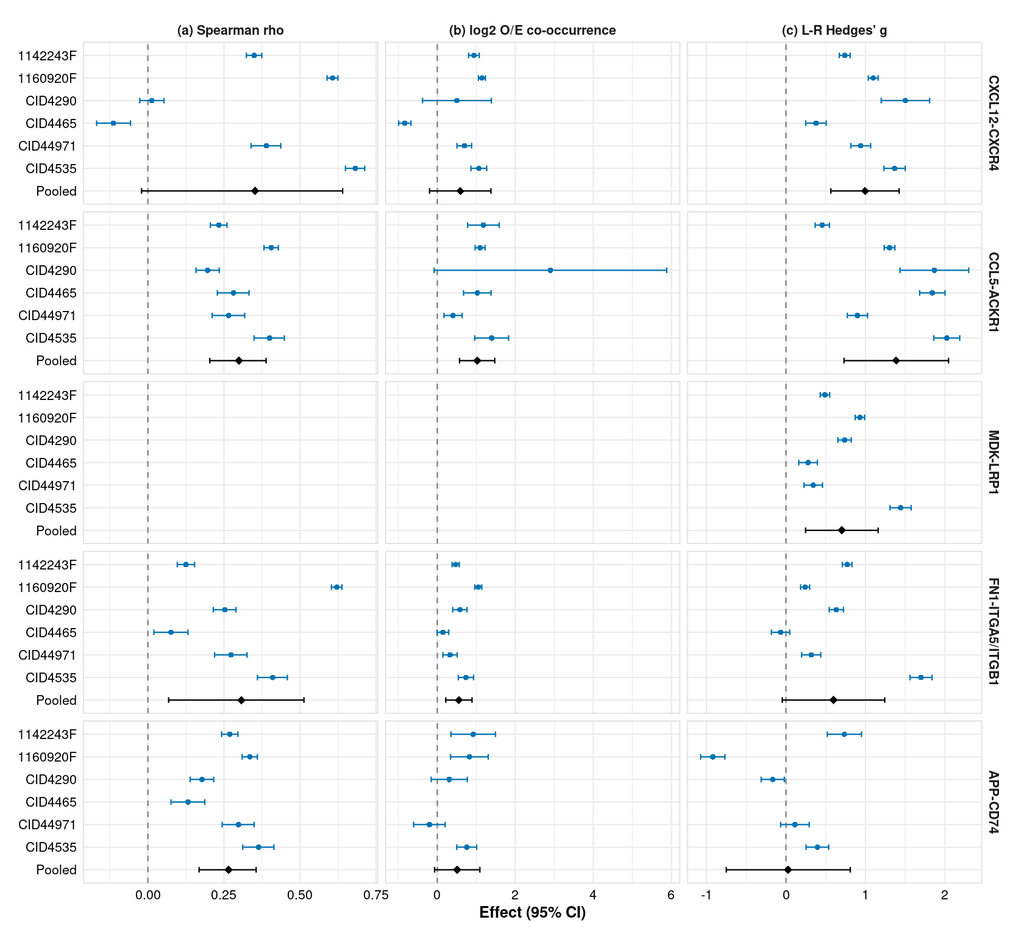

Figure 80: Spatial co-localization and co-expression tests per section and pooled, for each axis. Pooled estimates are random-effects with Knapp-Hartung 95% CIs. MDK-LRP1 is autocrine, so only (c) applies.

```r
forest_df <- bind_rows(
  spatial_section_res %>% transmute(axis_id, test, source = section, est, lo = est - 1.96 * sqrt(var), hi = est + 1.96 * sqrt(var)),
  spatial_pooled %>% transmute(axis_id, test, source = "Pooled", est, lo, hi)
) %>%
  mutate(across(c(est, lo, hi), ~ ifelse(test == "(a) weight correlation", tanh(.x), .x)),
         Axis = factor(axis_labels[axis_id], levels = axis_labels),
         source = factor(source, levels = rev(c(section_ids, "Pooled"))),
         test = recode(test, "(a) weight correlation" = "(a) Spearman rho", "(b) neighborhood enrichment" = "(b) log2 O/E co-occurrence",
                       "(c) L-R co-expression" = "(c) L-R Hedges' g"))
fig2 <- ggplot(forest_df %>% filter(is.finite(est)), aes(x = est, y = source, color = source == "Pooled")) +
  geom_vline(xintercept = 0, linetype = "dashed", color = "grey50") +
  geom_errorbar(aes(xmin = lo, xmax = hi), width = 0.25, orientation = "y") +
  geom_point(aes(size = source == "Pooled", shape = source == "Pooled")) +
  facet_grid(Axis ~ test, scales = "free_x") +
  scale_color_manual(values = c("FALSE" = "#0072B2", "TRUE" = "black"), guide = "none") +
  scale_size_manual(values = c("FALSE" = 1.8, "TRUE" = 3), guide = "none") +
  scale_shape_manual(values = c("FALSE" = 16, "TRUE" = 18), guide = "none") +
  labs(x = "Effect (95% CI)", y = NULL) +
  theme_publication()
ggsave(file.path(spatial_res_dir, "fig2_spatial_forest.png"), fig2, width = 12, height = 11, dpi = 300)
fig2
```

## HER2ST: an independent spatial cohort

The Wu sections overlap with the discovery cohort, so we sought an independent spatial dataset. HER2ST (Andersson et al. 2021, Zenodo 4751624) comes from eight HER2-positive patients who are not in the discovery cohorts, so unlike the Wu sections it is an independent patient population. The Wu single-cell data are used only as the reference for deconvolution. The data are 36 sections with 100 µm spots, from eight patients (A to H). Patients A to D have six serial sections each and patients E to H have three. Because serial sections of one tumor are not independent, the unit of replication is the patient, and our primary analysis uses one pathologist-labeled section per patient (A1, B1, C1, D1, E1, F1, G2 and H1; k = 8). As a sensitivity analysis we use all 36 sections and average the effects within patient before pooling.

We apply the same deconvolution (RCTD in full mode with the Wu reference of nine classes), the same three tests and the same definitions as for Visium, with two changes forced by the platform. The legacy symbol DARC is mapped to ACKR1, and a section is not estimable for CCL5-ACKR1 if ACKR1 is detected in fewer than 1% of its spots. The 100 µm lattice has no fixed six-neighbor layout, so the neighborhood of a spot is the spot plus all spots within 1.5 times the median nearest-neighbor distance of the section. We test only the two lead axes, and we correct the six tests (FN1-ITGA5/ITGB1 and CCL5-ACKR1, tests a to c) as one Benjamini-Hochberg family. A test replicates if the pooled HER2ST effect has the same sign as the Wu pooled estimate, q is below 0.05, and the sign agrees in at least six of the eight patients. A hypothesis replicates if its co-localization test (b) replicates, and its co-expression test (c) is reported alongside. A second sensitivity analysis uses a two-ring neighborhood (2.5 times the median distance).

RCTD is run on the 36 sections.

```r
suppressMessages({
  library(dplyr)
  library(readr)
  library(qs2)
  library(SeuratObject)
  library(spacexr)
  library(data.table)
})

set.seed(42)
her2_obj_dir <- "objects/revision/her2st"
dir.create(her2_obj_dir, recursive = TRUE, showWarnings = FALSE)
her2_sections <- c(sprintf("%s%d", rep(LETTERS[1:4], each = 6), rep(1:6, 4)), sprintf("%s%d", rep(LETTERS[5:8], each = 3), rep(1:3, 4)))

seu_ref <- qs_read("objects/seu_wu_filtered.qs2")
ref_counts <- LayerData(seu_ref, assay = "RNA", layer = "counts")
rm(seu_ref)

# Reference labels are those of the Visium RCTD run, so the reference is identical
ref_labels <- qs_read("objects/revision/spatial/rctd_reference_labels.qs2")
label_primary <- setNames(ref_labels$label_primary, ref_labels$barcode)[colnames(ref_counts)]

build_reference <- function(labels) {
  cells <- unlist(lapply(split(seq_along(labels), labels), function(ix) if (length(ix) > 3000) sample(ix, 3000) else ix))
  counts <- ref_counts[, cells]
  Reference(counts, factor(setNames(labels[cells], colnames(counts))), nUMI = colSums(counts), n_max_cells = 3000)
}
ref_primary <- build_reference(label_primary)

for (sid in her2_sections) {
  out_path <- file.path(her2_obj_dir, paste0("her2st_", sid, ".qs2"))
  if (file.exists(out_path)) next

  expr <- fread(file.path("data/spatial/her2st/counts/count-matrices", paste0(sid, ".tsv.gz")))
  spot_names <- expr[[1]]
  counts_all <- t(as.matrix(expr[, -1, with = FALSE]))
  colnames(counts_all) <- spot_names
  rm(expr)

  sel <- fread(file.path("data/spatial/her2st/spots", paste0(sid, "_selection.tsv.gz")))
  sel <- sel[selected == 1]
  sel$name <- paste0(sel$x, "x", sel$y)
  keep <- intersect(sel$name, colnames(counts_all))
  counts <- counts_all[, keep, drop = FALSE]
  counts <- counts[rowSums(counts) > 0, , drop = FALSE]
  spots <- sel[match(keep, sel$name), ]

  coords <- data.frame(x = spots$pixel_x, y = -spots$pixel_y, row.names = keep)
  puck <- SpatialRNA(coords, counts, nUMI = colSums(counts))
  rctd <- create.RCTD(puck, ref_primary, max_cores = 1)
  rctd <- run.RCTD(rctd, doublet_mode = "full")
  weights <- as.matrix(normalize_weights(rctd@results$weights))

  qs_save(list(weights = weights, spots = spots, counts = counts), out_path)
}
```

We then define the neighborhoods and report the quality of the sections, including the ACKR1 detection that decides whether the CCL5 tests are estimable.

```r
her2_obj_dir <- "objects/revision/her2st"
her2_res_dir <- "results/revision/her2st"
dir.create(her2_res_dir, recursive = TRUE, showWarnings = FALSE)
her2_sections <- c(sprintf("%s%d", rep(LETTERS[1:4], each = 6), rep(1:6, 4)), sprintf("%s%d", rep(LETTERS[5:8], each = 3), rep(1:3, 4)))
her2_primary <- c("A1", "B1", "C1", "D1", "E1", "F1", "G2", "H1")
her2_axes <- spatial_axes %>% filter(axis_id %in% c("fn1_itga5_itgb1", "ccl5_ackr1"))

# Neighborhood on the ST lattice: spots within 1.5 (d = 1) or 2.5 (d = 2) times the median nearest-neighbor distance
prepare_her2st <- function(sid) {
  obj <- qs_read(file.path(her2_obj_dir, paste0("her2st_", sid, ".qs2")))
  w <- obj$weights
  spots <- obj$spots[match(rownames(w), obj$spots$name), ]
  w <- cbind(w, Endothelial = w[, "Endothelial_ACKR1"] + w[, "Endothelial_other"])
  counts <- obj$counts[, rownames(w), drop = FALSE]
  rownames(counts)[rownames(counts) == "DARC"] <- "ACKR1"
  # A gene with no counts in the section is dropped at QC, so it is restored as zeros (0% detected)
  if (!"ACKR1" %in% rownames(counts)) counts <- rbind(counts, ACKR1 = 0)
  expr <- Matrix::Matrix(counts, sparse = TRUE)
  expr@x <- log1p(expr@x / rep(colSums(counts), diff(expr@p)) * 1e4)
  D <- as.matrix(dist(cbind(spots$pixel_x, spots$pixel_y)))
  m <- median(apply(D + diag(Inf, nrow(D)), 1, min))
  pr <- which(D <= 2.5 * m & row(D) != col(D), arr.ind = TRUE)
  pairs <- rbind(data.frame(i = pr[, 1], j = pr[, 2], d = ifelse(D[pr] <= 1.5 * m, 1, 2)),
                 data.frame(i = seq_len(nrow(D)), j = seq_len(nrow(D)), d = 0))
  list(sid = sid, patient = substr(sid, 1, 1), spots = spots, w = w, expr = expr, pairs = pairs,
       ackr1_pct = if ("ACKR1" %in% rownames(counts)) 100 * mean(counts["ACKR1", ] > 0) else 0)
}
her2_secs <- lapply(setNames(her2_sections, her2_sections), prepare_her2st)

her2_qc <- bind_rows(lapply(her2_secs, function(s) {
  tibble(section = s$sid, patient = s$patient, primary = s$sid %in% her2_primary, spots = nrow(s$spots),
         median_umi = median(colSums(s$expr > 0)), ackr1_pct_spots = round(s$ackr1_pct, 2),
         median_dominant_weight = median(apply(s$w, 1, max)))
}))
write_csv(her2_qc, file.path(her2_res_dir, "table_her2st_qc_diagnostics.csv"))
knitr::kable(her2_qc, digits = 2, caption = "HER2ST sections: spots, ACKR1 detection and RCTD dominant-type weight (primary sections marked)")
```

HER2ST sections: spots, ACKR1 detection and RCTD dominant-type weight (primary sections marked)

| section | patient | primary | spots | median_umi | ackr1_pct_spots | median_dominant_weight |
| --- | --- | --- | --- | --- | --- | --- |
| A1 | A | TRUE | 345 | 2345.0 | 0.58 | 0.82 |
| A2 | A | FALSE | 323 | 3684.0 | 0.00 | 0.84 |
| A3 | A | FALSE | 356 | 3175.5 | 0.28 | 0.83 |
| A4 | A | FALSE | 341 | 3118.0 | 0.88 | 0.84 |
| A5 | A | FALSE | 329 | 3145.0 | 0.61 | 0.84 |
| A6 | A | FALSE | 357 | 3066.0 | 0.28 | 0.83 |
| B1 | B | TRUE | 293 | 934.0 | 3.75 | 0.40 |
| B2 | B | FALSE | 268 | 753.5 | 5.60 | 0.38 |
| B3 | B | FALSE | 297 | 687.0 | 2.69 | 0.39 |
| B4 | B | FALSE | 281 | 540.0 | 5.69 | 0.34 |
| B5 | B | FALSE | 287 | 992.0 | 5.92 | 0.39 |
| B6 | B | FALSE | 277 | 882.0 | 7.22 | 0.33 |
| C1 | C | TRUE | 174 | 3622.5 | 4.02 | 0.52 |
| C2 | C | FALSE | 185 | 3733.0 | 8.65 | 0.51 |
| C3 | C | FALSE | 179 | 4198.0 | 7.26 | 0.51 |
| C4 | C | FALSE | 184 | 4231.0 | 8.15 | 0.55 |
| C5 | C | FALSE | 179 | 4185.0 | 5.59 | 0.52 |
| C6 | C | FALSE | 176 | 4729.5 | 6.25 | 0.64 |
| D1 | D | TRUE | 306 | 3377.5 | 1.63 | 0.41 |
| D2 | D | FALSE | 302 | 2423.0 | 2.32 | 0.37 |
| D3 | D | FALSE | 300 | 2564.0 | 1.00 | 0.42 |
| D4 | D | FALSE | 299 | 2270.0 | 1.34 | 0.38 |
| D5 | D | FALSE | 304 | 2551.5 | 0.99 | 0.44 |
| D6 | D | FALSE | 314 | 2382.5 | 3.18 | 0.40 |
| E1 | E | TRUE | 587 | 963.0 | 1.53 | 0.33 |
| E2 | E | FALSE | 572 | 1410.0 | 1.22 | 0.38 |
| E3 | E | FALSE | 570 | 1399.0 | 4.21 | 0.38 |
| F1 | F | TRUE | 691 | 1905.0 | 1.59 | 0.69 |
| F2 | F | FALSE | 695 | 2065.0 | 1.73 | 0.69 |
| F3 | F | FALSE | 712 | 2045.0 | 3.51 | 0.68 |
| G1 | G | FALSE | 441 | 1047.0 | 4.76 | 0.39 |
| G2 | G | TRUE | 467 | 1168.0 | 3.85 | 0.37 |
| G3 | G | FALSE | 463 | 981.0 | 4.32 | 0.37 |
| H1 | H | TRUE | 613 | 778.0 | 13.21 | 0.34 |
| H2 | H | FALSE | 603 | 876.0 | 18.08 | 0.37 |
| H3 | H | FALSE | 510 | 665.0 | 12.35 | 0.33 |

The pooled tests over the eight patients are next, in the same table as the pooled Wu estimates for direct comparison.

```r
# Pooled over patients (k = 8). A patient-level estimate is the mean over its sections when S-all is used.
wu_pooled <- read_csv("results/revision/spatial/spatial_tests_pooled.csv", show_col_types = FALSE) %>%
  filter(axis_id %in% c("fn1_itga5_itgb1", "ccl5_ackr1")) %>%
  select(axis_id, test, wu_est = est)

her2_test_pool <- function(section_res) {
  section_res %>%
    group_by(axis_id, test) %>%
    group_modify(~ pool_sections(.x$est, .x$var)) %>%
    ungroup()
}

# ACKR1 must be detected in at least 1% of spots for the CCL5 tests
her2_run <- function(secs, rings = 0:1) {
  res <- NULL
  for (s in secs) res <- bind_rows(res, run_axis_tests(list(s), axes = her2_axes, rings = rings))
  ackr1_ok <- sapply(secs, function(s) s$ackr1_pct >= 1)
  res$est[res$axis_id == "ccl5_ackr1" & !ackr1_ok[res$section]] <- NA_real_
  res
}

her2_primary_res <- her2_run(her2_secs[her2_primary])
her2_primary_pool <- her2_test_pool(her2_primary_res)

# S-all: section estimates are averaged within patient, then pooled over the 8 patients
her2_all_res <- her2_run(her2_secs)
her2_all_patient <- her2_all_res %>%
  group_by(patient = substr(section, 1, 1), axis_id, test) %>%
  summarise(est = mean(est, na.rm = TRUE), var = mean(var, na.rm = TRUE) / n(), .groups = "drop") %>%
  mutate(est = ifelse(is.nan(est), NA_real_, est))
her2_all_pool <- her2_all_patient %>% group_by(axis_id, test) %>% group_modify(~ pool_sections(.x$est, .x$var)) %>% ungroup()

# S-2ring: two-ring neighborhood
her2_2ring_res <- her2_run(her2_secs[her2_primary], rings = 0:2)
her2_2ring_pool <- her2_test_pool(her2_2ring_res)

declared <- her2_primary_pool %>%
  left_join(wu_pooled, by = c("axis_id", "test")) %>%
  mutate(n_same_dir = sapply(seq_len(n()), function(k) {
    e <- her2_primary_res$est[her2_primary_res$axis_id == axis_id[k] & her2_primary_res$test == test[k]]
    sum(e > 0, na.rm = TRUE)
  }))
declared$q_bh6 <- p.adjust(declared$p, method = "BH")
declared$criterion_met <- !is.na(declared$est) & sign(declared$est) == sign(declared$wu_est) &
  declared$q_bh6 < 0.05 & declared$n_same_dir >= 6
write_csv(declared, file.path(her2_res_dir, "her2st_declared_tests_pooled.csv"))
write_csv(her2_primary_res, file.path(her2_res_dir, "her2st_declared_tests_by_section.csv"))

knitr::kable(
  declared %>%
    transmute(Axis = axis_labels[axis_id], test, k, `HER2ST pooled (95% CI)` = fmt_pooled(test, est, lo, hi),
              `Wu pooled` = round(wu_est, 3), p = signif(p, 3), q = signif(q_bh6, 3),
              `Same direction (of 8)` = n_same_dir, `Replicated` = criterion_met),
  caption = "HER2ST tests, primary (one labeled section per patient, k = 8). BH across the six tests; criterion as defined in the text"
)
```

HER2ST tests, primary (one labeled section per patient, k = 8). BH across the six tests; criterion as defined in the text

| Axis | test | k | HER2ST pooled (95% CI) | Wu pooled | p | q | Same direction (of 8) | Replicated |
| --- | --- | --- | --- | --- | --- | --- | --- | --- |
| CCL5-ACKR1 | (a) weight correlation | 7 | rho 0.13 (0.03 to 0.22) | 0.308 | 0.0214 | 0.0692 | 7 | FALSE |
| CCL5-ACKR1 | (b) neighborhood enrichment | 7 | 0.25 (-0.10 to 0.61) | 1.022 | 0.1330 | 0.1740 | 6 | FALSE |
| CCL5-ACKR1 | (c) L-R co-expression | 7 | 0.36 (0.07 to 0.64) | 1.388 | 0.0231 | 0.0692 | 6 | FALSE |
| FN1-ITGA5/ITGB1 | (a) weight correlation | 8 | rho 0.12 (-0.05 to 0.28) | 0.317 | 0.1450 | 0.1740 | 6 | FALSE |
| FN1-ITGA5/ITGB1 | (b) neighborhood enrichment | 8 | 0.14 (-0.16 to 0.44) | 0.554 | 0.3020 | 0.3020 | 6 | FALSE |
| FN1-ITGA5/ITGB1 | (c) L-R co-expression | 8 | 0.13 (-0.05 to 0.30) | 0.598 | 0.1320 | 0.1740 | 6 | FALSE |

```r
knitr::kable(
  bind_rows(her2_all_pool %>% mutate(analysis = "S-all (36 sections, patient-averaged)"),
            her2_2ring_pool %>% mutate(analysis = "S-2ring (primary sections)")) %>%
    transmute(analysis, Axis = axis_labels[axis_id], test, k, `Pooled (95% CI)` = fmt_pooled(test, est, lo, hi), p = signif(p, 3)),
  caption = "HER2ST sensitivity analyses; reported in full, not used to change the primary result"
)
```

HER2ST sensitivity analyses; reported in full, not used to change the primary result

| analysis | Axis | test | k | Pooled (95% CI) | p |
| --- | --- | --- | --- | --- | --- |
| S-all (36 sections, patient-averaged) | CCL5-ACKR1 | (a) weight correlation | 7 | rho 0.13 (0.03 to 0.21) | 0.0149 |
| S-all (36 sections, patient-averaged) | CCL5-ACKR1 | (b) neighborhood enrichment | 7 | 0.32 (0.06 to 0.59) | 0.0248 |
| S-all (36 sections, patient-averaged) | CCL5-ACKR1 | (c) L-R co-expression | 7 | 0.51 (0.15 to 0.86) | 0.0130 |
| S-all (36 sections, patient-averaged) | FN1-ITGA5/ITGB1 | (a) weight correlation | 8 | rho 0.15 (-0.03 to 0.33) | 0.0953 |
| S-all (36 sections, patient-averaged) | FN1-ITGA5/ITGB1 | (b) neighborhood enrichment | 8 | 0.22 (-0.08 to 0.52) | 0.1230 |
| S-all (36 sections, patient-averaged) | FN1-ITGA5/ITGB1 | (c) L-R co-expression | 8 | 0.12 (-0.16 to 0.39) | 0.3530 |
| S-2ring (primary sections) | CCL5-ACKR1 | (a) weight correlation | 7 | rho 0.13 (0.03 to 0.22) | 0.0214 |
| S-2ring (primary sections) | CCL5-ACKR1 | (b) neighborhood enrichment | 7 | 0.16 (-0.09 to 0.41) | 0.1780 |
| S-2ring (primary sections) | CCL5-ACKR1 | (c) L-R co-expression | 7 | 0.43 (0.08 to 0.78) | 0.0231 |
| S-2ring (primary sections) | FN1-ITGA5/ITGB1 | (a) weight correlation | 8 | rho 0.12 (-0.05 to 0.28) | 0.1450 |
| S-2ring (primary sections) | FN1-ITGA5/ITGB1 | (b) neighborhood enrichment | 8 | 0.11 (-0.17 to 0.39) | 0.3670 |
| S-2ring (primary sections) | FN1-ITGA5/ITGB1 | (c) L-R co-expression | 8 | 0.28 (0.08 to 0.48) | 0.0139 |

```r
her2_pick <- function(col, ax, tst) declared[[col]][declared$axis_id == ax & grepl(tst, declared$test, fixed = TRUE)]
```

HER2ST is directionally consistent with the CCL5-ACKR1 result without meeting the criterion. For co-expression (c), the pooled effect is 0.36 (0.07 to 0.64), against 1.39 in Wu, with the same sign in 6 of the 7 estimable patients, nominal p = 0.023 and q = 0.069 across the six tests. The weight correlation (a) is positive in 7 of 7 patients, and the neighborhood enrichment (b) in 6 of 7. Section A1 is not estimable for CCL5-ACKR1, because ACKR1 is detected in only 0.6% of its spots. The CCL5-ACKR1 signal is therefore consistent in direction across independent patients, which is supportive, but it does not clear our correction, so we call it directionally consistent and not a replication. FN1-ITGA5/ITGB1 is not replicated: its three tests have pooled effects of 0.12 (rho), 0.14 and 0.13, with q of at least 0.17. Averaging all 36 sections within patient gives a nominally significant CCL5-ACKR1 co-expression effect, but this sensitivity analysis is not corrected for multiplicity, so we report it only as such. With a family of three tests per hypothesis, as used for Visium, the CCL5-ACKR1 co-expression test would have q = 0.035. We do not use that figure to call the result significant.

```r
# Random-pair benchmark for (c), 1,000 expression-matched gene pairs per axis, pooled over the 8 primary patients
her2_shared <- Reduce(intersect, lapply(her2_secs[her2_primary], function(s) rownames(s$expr)))
her2_mean <- Reduce(`+`, lapply(her2_secs[her2_primary], function(s) Matrix::rowSums(s$expr[her2_shared, ]))) /
  sum(sapply(her2_secs[her2_primary], function(s) ncol(s$expr)))
her2_universe <- her2_shared[Reduce(`&`, lapply(her2_secs[her2_primary], function(s) Matrix::rowMeans(s$expr[her2_shared, ] > 0) >= 0.01))]
her2_ecdf <- ecdf(her2_mean[her2_universe])
her2_pct <- her2_ecdf(her2_mean[her2_universe])
her2_pools <- lapply(setNames(spatial_axis_genes, spatial_axis_genes), function(g) {
  setdiff(her2_universe[abs(her2_pct - her2_ecdf(her2_mean[g])) <= 0.025], spatial_axis_genes)
})

her2_niches <- lapply(her2_secs[her2_primary], function(s) {
  A <- ring_adjacency(s, 0:1)
  lapply(setNames(seq_len(nrow(her2_axes)), her2_axes$axis_id), function(k) axis_niche(s, her2_axes[k, ], A))
})
her2_nb <- lapply(her2_secs[her2_primary], function(s) {
  A <- ring_adjacency(s, 0:1)
  sweep(as.matrix(s$expr[intersect(c(spatial_axis_genes, unlist(her2_pools)), rownames(s$expr)), ] %*% t(A)), 2, rowSums(A), "/")
})

her2_pooled_g <- function(axis_id, lig, rec) {
  gs <- bind_rows(lapply(her2_primary, function(sid) {
    nc <- her2_niches[[sid]][[axis_id]]
    if (!nc$estimable) return(data.frame(est = NA_real_, var = NA_real_))
    m <- her2_nb[[sid]]
    score <- if (length(lig) == 0) colMeans(m[rec, , drop = FALSE]) else m[lig, ] * colMeans(m[rec, , drop = FALSE])
    hedges_g(score, nc$niche)
  }))
  pool_sections(gs$est, gs$var)$est
}

set.seed(42)
her2_bench <- bind_rows(lapply(c("fn1_itga5_itgb1", "ccl5_ackr1"), function(ax_id) {
  ax <- her2_axes[her2_axes$axis_id == ax_id, ]
  rec_genes <- strsplit(ax$receptor, "_")[[1]]
  g <- unlist(lapply(1:1000, function(j) {
    lig <- sample(her2_pools[[ax$ligand]], 1)
    rec <- vapply(rec_genes, function(r) sample(setdiff(her2_pools[[r]], lig), 1), character(1))
    her2_pooled_g(ax_id, lig, rec)
  }))
  obs <- her2_test_pool(her2_primary_res) %>% filter(axis_id == ax_id, test == "(c) L-R co-expression") %>% pull(est)
  data.frame(axis_id = ax_id, observed_g = obs, null_median = median(g, na.rm = TRUE),
             percentile = 100 * mean(g < obs, na.rm = TRUE), emp_p = (1 + sum(g >= obs, na.rm = TRUE)) / (sum(is.finite(g)) + 1))
}))
write_csv(her2_bench, file.path(her2_res_dir, "her2st_benchmark_random_pairs.csv"))
knitr::kable(her2_bench %>% transmute(Axis = axis_labels[axis_id], `Observed g` = round(observed_g, 3), `Null median` = round(null_median, 3),
                                     Percentile = round(percentile, 1), `Empirical p (one-sided)` = signif(emp_p, 3)),
             caption = "HER2ST (c) against 1,000 expression-matched random gene pairs per axis")
```

HER2ST (c) against 1,000 expression-matched random gene pairs per axis

| Axis | Observed g | Null median | Percentile | Empirical p (one-sided) |
| --- | --- | --- | --- | --- |
| FN1-ITGA5/ITGB1 | 0.125 | -0.140 | 97.4 | 0.027000 |
| CCL5-ACKR1 | 0.356 | -0.112 | 100.0 | 0.000999 |

The per-patient estimates next to the Wu pooled estimates show how close the two datasets are (Figure 81).

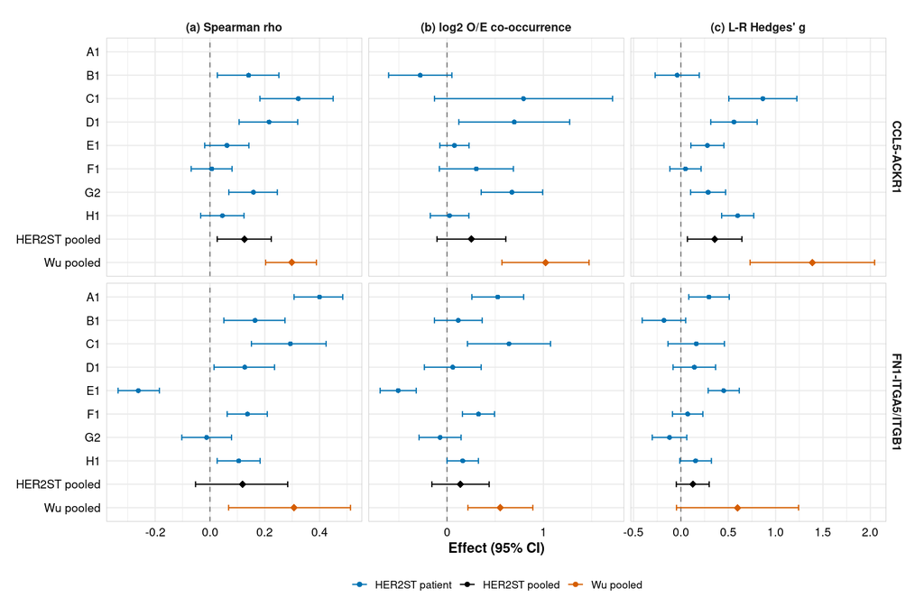

Figure 81: HER2ST tests of the lead axes: per-patient estimates (one section per patient) with 95% CI, the pooled HER2ST estimate, and the pooled Wu Visium estimate for the same test.

```r
her2_forest_df <- bind_rows(
  her2_primary_res %>% transmute(axis_id, test, source = section, est, lo = est - 1.96 * sqrt(var), hi = est + 1.96 * sqrt(var)),
  declared %>% transmute(axis_id, test, source = "HER2ST pooled", est, lo, hi),
  spatial_pooled %>% filter(axis_id %in% her2_axes$axis_id) %>% transmute(axis_id, test, source = "Wu pooled", est, lo, hi)
) %>%
  mutate(
    across(c(est, lo, hi), ~ ifelse(test == "(a) weight correlation", tanh(.x), .x)),
    Axis = factor(axis_labels[axis_id], levels = axis_labels),
    group = case_when(source == "HER2ST pooled" ~ "HER2ST pooled", source == "Wu pooled" ~ "Wu pooled", TRUE ~ "HER2ST patient"),
    source = factor(source, levels = rev(c(her2_primary, "HER2ST pooled", "Wu pooled"))),
    test = recode(test, "(a) weight correlation" = "(a) Spearman rho", "(b) neighborhood enrichment" = "(b) log2 O/E co-occurrence",
                  "(c) L-R co-expression" = "(c) L-R Hedges' g")
  )
ggplot(her2_forest_df %>% filter(is.finite(est)), aes(x = est, y = source, color = group)) +
  geom_vline(xintercept = 0, linetype = "dashed", color = "grey50") +
  geom_errorbar(aes(xmin = lo, xmax = hi), width = 0.25, orientation = "y") +
  geom_point(aes(size = group != "HER2ST patient", shape = group != "HER2ST patient")) +
  facet_grid(Axis ~ test, scales = "free_x") +
  scale_color_manual(values = c("HER2ST patient" = "#0072B2", "HER2ST pooled" = "black", "Wu pooled" = "#D55E00"), name = NULL) +
  scale_size_manual(values = c("FALSE" = 1.8, "TRUE" = 3), guide = "none") +
  scale_shape_manual(values = c("FALSE" = 16, "TRUE" = 18), guide = "none") +
  labs(x = "Effect (95% CI)", y = NULL) +
  theme_publication() +
  theme(legend.position = "bottom")
ggsave(file.path(her2_res_dir, "fig_her2st_forest.png"), last_plot(), width = 12, height = 8, dpi = 300)
```

The HER2ST maps for one patient show the same four panels as for Visium. The representative patient is the one whose primary section has the CCL5-ACKR1 co-expression effect closest to the pooled HER2ST estimate (Figure 82).

```r
her2_rep <- her2_primary_res %>%
  filter(axis_id == "ccl5_ackr1", test == "(c) L-R co-expression", is.finite(est)) %>%
  left_join(declared %>% filter(axis_id == "ccl5_ackr1", test == "(c) L-R co-expression") %>% select(axis_id, pooled = est), by = "axis_id") %>%
  slice_min(abs(est - pooled), n = 1, with_ties = FALSE)
her2_rep_section <- her2_rep$section

# H&E in full-resolution pixel coordinates, downsampled for plotting, so that it lines up with the spot maps
her2_he_panel <- function(sid, title) {
  img <- jpeg::readJPEG(file.path("data/spatial/her2st/images_he/images/HE", paste0(sid, ".jpg")))
  step <- 4
  img <- img[seq(1, dim(img)[1], by = step), seq(1, dim(img)[2], by = step), , drop = FALSE]
  sp <- her2_secs[[sid]]$spots
  pad <- 200
  ggplot() +
    annotation_raster(img, xmin = 0, xmax = dim(img)[2] * step, ymin = -dim(img)[1] * step, ymax = 0) +
    coord_fixed(xlim = range(sp$pixel_x) + c(-pad, pad), ylim = -rev(range(sp$pixel_y)) + c(-pad, pad), expand = FALSE) +
    labs(title = title) +
    theme_void(base_size = 13) +
    theme(plot.title = element_text(size = 13, face = "bold", hjust = 0.5))
}
her2_spot_map <- function(sec, values, title, palette = "magma") {
  ggplot(data.frame(x = sec$spots$pixel_x, y = -sec$spots$pixel_y, v = values), aes(x = x, y = y, color = v)) +
    geom_point(size = 1.4) +
    scale_color_viridis_c(option = palette, name = NULL) +
    coord_fixed(xlim = range(sec$spots$pixel_x) + c(-200, 200), ylim = -rev(range(sec$spots$pixel_y)) + c(-200, 200), expand = FALSE) +
    labs(title = title) +
    theme_void(base_size = 13) +
    theme(plot.title = element_text(size = 13, face = "bold", hjust = 0.5), legend.key.height = unit(0.6, "cm"), legend.key.width = unit(0.35, "cm"))
}
her2_axis_row <- function(ax, sid) {
  sec <- her2_secs[[sid]]
  A <- ring_adjacency(sec, 0:1)
  lr <- nb_mean(A, gene_score(sec$expr, ax$ligand)) * nb_mean(A, gene_score(sec$expr, ax$receptor))
  her2_he_panel(sid, sprintf("H&E (%s)", sid)) +
    her2_spot_map(sec, sec$w[, ax$sender], paste("Sender:", ax$sender), "viridis") +
    her2_spot_map(sec, sec$w[, ax$receiver], paste("Receiver:", ax$receiver), "viridis") +
    her2_spot_map(sec, lr, sprintf("%s x %s (neighborhood)", ax$ligand, gsub("_", "/", ax$receptor)), "magma") +
    plot_layout(nrow = 1)
}
her2_maps <- wrap_plots(lapply(seq_len(nrow(her2_axes)), function(k) her2_axis_row(her2_axes[k, ], her2_rep_section)), ncol = 1)
ggsave(file.path(her2_res_dir, "fig_her2st_maps.png"), her2_maps, width = 14, height = 7.6, dpi = 300)
```

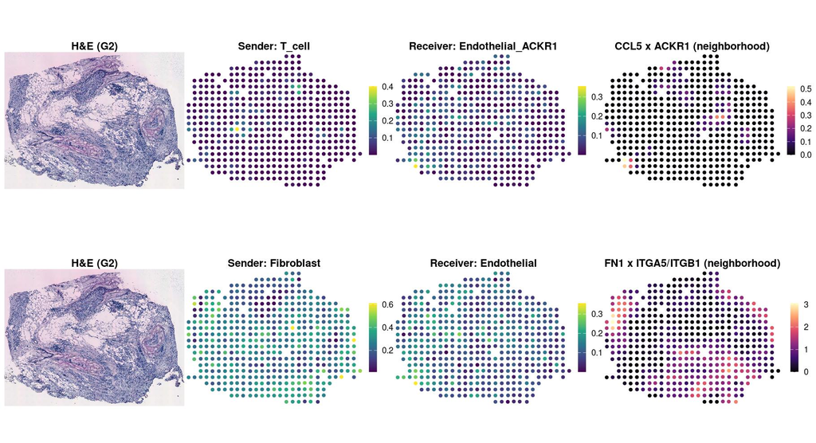

```r
her2_maps
```

# Clinical associations

Does axis co-expression in bulk tumors relate to patient outcome? The outcome is overall survival in three bulk cohorts: TCGA-BRCA and METABRIC first, and SCAN-B as an independent validation. This section describes the bulk data, the primary analysis, the secondary and exploratory analyses, the control for tumor composition, the SCAN-B replication, and the link to the downstream programs.

## Bulk expression and clinical data

For TCGA-BRCA and METABRIC we extract the axis genes from the expression matrices, with the legacy symbols DARC and IL8 mapped to ACKR1 and CXCL8. TCGA RSEM values are scaled to counts per million and log2-transformed. METABRIC values are the log-intensity microarray values as released. The `ITGA5_ITGB1` receptor is the mean of the log2 ITGA5 and ITGB1 values, and the ligand-receptor co-expression score of an axis is the mean of the log2 ligand and receptor values.

```r
# Target genes list to extract
target_genes <- c("CXCL12", "CXCR4", "CCL5", "CXCL8", "ACKR1", "MDK", "LRP1", "FN1", "ITGA5", "ITGB1", "APP", "CD74")

extract_target_genes <- function(mat, target_genes) {
  df_list <- list()
  for (gene in target_genes) {
    if (gene %in% rownames(mat)) {
      df_list[[gene]] <- mat[gene, ]
    } else if (gene == "ACKR1" && "DARC" %in% rownames(mat)) {
      df_list[[gene]] <- mat["DARC", ]
    } else if (gene == "CXCL8" && "IL8" %in% rownames(mat)) {
      df_list[[gene]] <- mat["IL8", ]
    } else {
      df_list[[gene]] <- rep(NA, ncol(mat))
    }
  }
  df <- as.data.frame(df_list)
  rownames(df) <- colnames(mat)
  return(df)
}

dir.create("objects/phase2", recursive = TRUE, showWarnings = FALSE)

expr_tcga_raw <- fread("data/ext/brca_tcga/data_mrna_seq_v2_rsem.txt")

# Clean genes
expr_tcga_raw <- expr_tcga_raw[Hugo_Symbol != "" & !is.na(Hugo_Symbol)]
expr_tcga_raw <- expr_tcga_raw[!duplicated(Hugo_Symbol)]
genes_tcga <- expr_tcga_raw$Hugo_Symbol
mat_tcga <- as.matrix(expr_tcga_raw[, -c("Hugo_Symbol", "Entrez_Gene_Id"), with=FALSE])
rownames(mat_tcga) <- genes_tcga
colnames(mat_tcga) <- gsub("\\.", "-", colnames(mat_tcga))

mat_tcga <- apply(mat_tcga, 2, function(x) {
  s <- sum(x, na.rm = TRUE)
  if (s > 0) (x / s) * 1e6 else x
})

qs_save(mat_tcga, "objects/phase2/mat_tcga.qs2")

expr_tcga_targets <- extract_target_genes(mat_tcga, target_genes)
expr_tcga_targets$sampleId <- rownames(expr_tcga_targets)

# Log2 transformation
max_tcga_val <- max(expr_tcga_targets[, target_genes], na.rm = TRUE)
if (max_tcga_val > 100) {
  for (g in target_genes) {
    expr_tcga_targets[[g]] <- log2(expr_tcga_targets[[g]] + 1)
  }
}
if (all(c("ITGA5", "ITGB1") %in% colnames(expr_tcga_targets))) {
  expr_tcga_targets$ITGA5_ITGB1 <- rowMeans(expr_tcga_targets[, c("ITGA5", "ITGB1")], na.rm = TRUE)
}

cl_sample_tcga <- fread("data/ext/brca_tcga/data_clinical_sample.txt", header = TRUE, skip = "PATIENT_ID")
cl_patient_tcga <- fread("data/ext/brca_tcga/data_clinical_patient.txt", header = TRUE, skip = "PATIENT_ID")
cl_tcga <- merge(cl_sample_tcga, cl_patient_tcga, by = "PATIENT_ID")

tcga_base <- inner_join(cl_tcga, expr_tcga_targets, by = c("SAMPLE_ID" = "sampleId")) %>%
  rename(sampleId = SAMPLE_ID)

qs_save(tcga_base, "objects/phase2/clinical_tcga_base.qs2")

expr_meta_raw <- fread("data/ext/brca_metabric/data_mrna_illumina_microarray.txt")

# Clean genes
expr_meta_raw <- expr_meta_raw[Hugo_Symbol != "" & !is.na(Hugo_Symbol)]
expr_meta_raw <- expr_meta_raw[!duplicated(Hugo_Symbol)]
genes_meta <- expr_meta_raw$Hugo_Symbol
mat_meta <- as.matrix(expr_meta_raw[, -c("Hugo_Symbol", "Entrez_Gene_Id"), with=FALSE])
rownames(mat_meta) <- genes_meta

qs_save(mat_meta, "objects/phase2/mat_meta.qs2")

expr_meta_targets <- extract_target_genes(mat_meta, target_genes)
expr_meta_targets$sampleId <- rownames(expr_meta_targets)

# Log2 transformation
max_meta_val <- max(expr_meta_targets[, target_genes], na.rm = TRUE)
if (max_meta_val > 100) {
  for (g in target_genes) {
    expr_meta_targets[[g]] <- log2(expr_meta_targets[[g]] + 1)
  }
}
if (all(c("ITGA5", "ITGB1") %in% colnames(expr_meta_targets))) {
  expr_meta_targets$ITGA5_ITGB1 <- rowMeans(expr_meta_targets[, c("ITGA5", "ITGB1")], na.rm = TRUE)
}

cl_sample_meta <- fread("data/ext/brca_metabric/data_clinical_sample.txt", header = TRUE, skip = "PATIENT_ID")
cl_patient_meta <- fread("data/ext/brca_metabric/data_clinical_patient.txt", header = TRUE, skip = "PATIENT_ID")
cl_meta <- merge(cl_sample_meta, cl_patient_meta, by = "PATIENT_ID")

metabric_base <- inner_join(cl_meta, expr_meta_targets, by = c("SAMPLE_ID" = "sampleId")) %>%
  rename(sampleId = SAMPLE_ID)

qs_save(metabric_base, "objects/phase2/clinical_metabric_base.qs2")
```

Tumor composition is estimated from the same expression matrices with ESTIMATE (stromal, immune and ESTIMATE scores and tumor purity) and with CIBERSORT against the LM22 signature of 22 immune cell subsets, through `immunedeconv`. Missing values in the METABRIC matrix are replaced by the gene mean before CIBERSORT. The estimates are joined to the clinical tables.

```r
# Register CIBERSORT binary and LM22 signature matrix
set_cibersort_binary("data/ext/CIBERSORT.R")
set_cibersort_mat("data/ext/LM22.txt")

mat_tcga <- qs_read("objects/phase2/mat_tcga.qs2")
mat_meta <- qs_read("objects/phase2/mat_meta.qs2")

tcga_base <- qs_read("objects/phase2/clinical_tcga_base.qs2")
metabric_base <- qs_read("objects/phase2/clinical_metabric_base.qs2")

# TCGA Deconvolution (ESTIMATE + CIBERSORT via immunedeconv)
est_tcga <- deconvolute_estimate(mat_tcga)
est_tcga_df <- as.data.frame(t(est_tcga))
est_tcga_df$sampleId <- rownames(est_tcga_df)
colnames(est_tcga_df) <- c("stromal_score", "immune_score", "ESTIMATEScore", "TumorPurity", "sampleId")

# CIBERSORT (LM22)
res_cib_tcga <- deconvolute(mat_tcga, method = "cibersort")
cib_tcga_df <- as.data.frame(t(res_cib_tcga[, -1]))
colnames(cib_tcga_df) <- res_cib_tcga$cell_type
cib_tcga_df$sampleId <- rownames(cib_tcga_df)

# Join TCGA base data with ESTIMATE & CIBERSORT
tcga_data <- tcga_base %>%
  left_join(est_tcga_df, by = "sampleId") %>%
  left_join(cib_tcga_df, by = "sampleId")

qs_save(tcga_data, "objects/phase2/clinical_tcga_processed.qs2")

# METABRIC Deconvolution (ESTIMATE + CIBERSORT via immunedeconv)
est_meta <- deconvolute_estimate(mat_meta)
est_meta_df <- as.data.frame(t(est_meta))
est_meta_df$sampleId <- rownames(est_meta_df)
colnames(est_meta_df) <- c("stromal_score", "immune_score", "ESTIMATEScore", "TumorPurity", "sampleId")

# CIBERSORT (LM22) - Clean NAs in mat_meta for CIBERSORT
mat_meta_clean <- mat_meta
for (i in which(rowSums(is.na(mat_meta_clean)) > 0)) {
  m <- mean(mat_meta_clean[i, ], na.rm = TRUE)
  if (is.na(m)) m <- 0
  mat_meta_clean[i, is.na(mat_meta_clean[i, ])] <- m
}
res_cib_meta <- deconvolute(mat_meta_clean, method = "cibersort")
cib_meta_df <- as.data.frame(t(res_cib_meta[, -1]))
colnames(cib_meta_df) <- res_cib_meta$cell_type
cib_meta_df$sampleId <- rownames(cib_meta_df)

# Join METABRIC base data with ESTIMATE & CIBERSORT
metabric_data <- metabric_base %>%
  left_join(est_meta_df, by = "sampleId") %>%
  left_join(cib_meta_df, by = "sampleId")

qs_save(metabric_data, "objects/phase2/clinical_metabric_processed.qs2")
```

The two cohorts differ in platform, population and annotation (Figure 83). The table gives the sample counts, the PAM50 subtype distribution, age and the proportion of deaths.

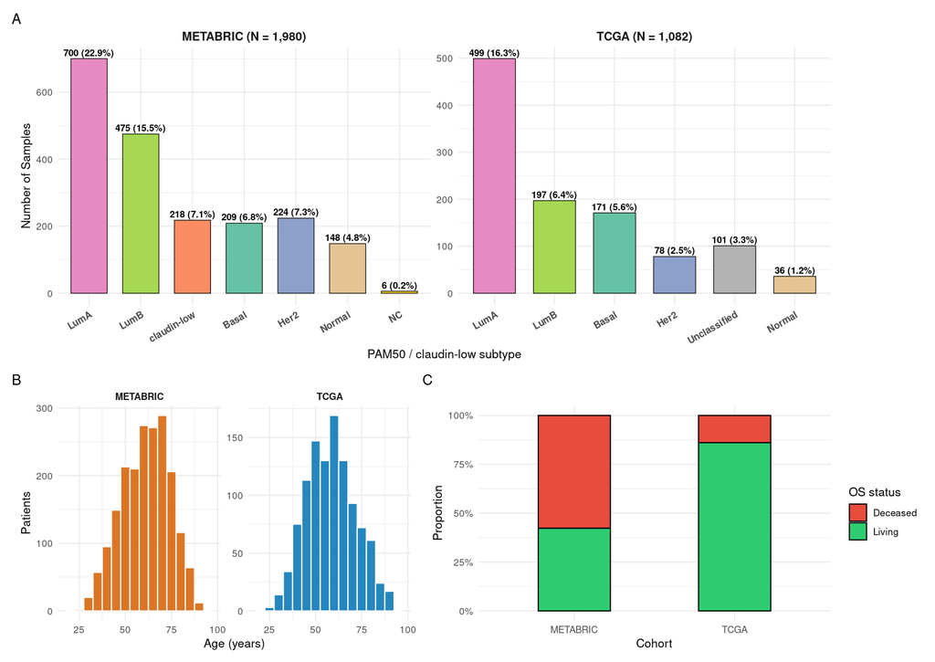

Figure 83: Clinical characteristics of the TCGA-BRCA and METABRIC cohorts: molecular subtype (top), age at diagnosis (bottom left) and overall survival status (bottom right).

```r
dir.create("results/clinical", recursive = TRUE, showWarnings = FALSE)

tcga_df <- tryCatch(qs_read("objects/phase2/clinical_tcga_processed.qs2"), error = function(e) qs_read("objects/phase2/clinical_tcga_base.qs2"))
meta_df <- tryCatch(qs_read("objects/phase2/clinical_metabric_processed.qs2"), error = function(e) qs_read("objects/phase2/clinical_metabric_base.qs2"))

# Subtype distribution preparation
tcga_sub <- tcga_df %>%
  mutate(Subtype_Clean = ifelse(is.na(SUBTYPE) | SUBTYPE == "", "Unclassified", gsub("BRCA_", "", SUBTYPE))) %>%
  dplyr::count(Subtype_Clean) %>%
  mutate(Cohort = "TCGA (N = 1,082)")

meta_sub <- meta_df %>%
  mutate(Subtype_Clean = ifelse(is.na(CLAUDIN_SUBTYPE) | CLAUDIN_SUBTYPE == "", "Unclassified", CLAUDIN_SUBTYPE)) %>%
  dplyr::count(Subtype_Clean) %>%
  mutate(Cohort = "METABRIC (N = 1,980)")

df_subtypes <- bind_rows(tcga_sub, meta_sub)

p_subtypes <- ggplot(df_subtypes, aes(x = reorder(Subtype_Clean, -n), y = n, fill = Subtype_Clean)) +
  geom_bar(stat = "identity", width = 0.7, color = "black", linewidth = 0.3) +
  geom_text(aes(label = sprintf("%d (%.1f%%)", n, n / sum(n) * 100)), vjust = -0.4, size = 3, fontface = "bold") +
  facet_wrap(~Cohort, scales = "free") +
  scale_fill_brewer(palette = "Set2") +
  theme_minimal(base_size = 11) +
  theme(
    legend.position = "none",
    strip.text = element_text(face = "bold", size = 11),
    axis.text.x = element_text(angle = 30, hjust = 1, face = "bold"),
    plot.title = element_text(face = "bold", hjust = 0.5)
  ) +
  labs(
    x = "PAM50 / claudin-low subtype",
    y = "Number of Samples"
  )

# Demographics & Survival Status
tcga_demo <- tcga_df %>%
  mutate(Age = as.numeric(AGE), Status = ifelse(grepl("1|DECEASED|Dead", OS_STATUS, ignore.case = TRUE), "Deceased", "Living"), Cohort = "TCGA") %>%
  filter(!is.na(Age))

meta_demo <- meta_df %>%
  mutate(Age = as.numeric(AGE_AT_DIAGNOSIS), Status = ifelse(grepl("1|DECEASED|Dead", OS_STATUS, ignore.case = TRUE), "Deceased", "Living"), Cohort = "METABRIC") %>%
  filter(!is.na(Age))

df_demo <- bind_rows(tcga_demo %>% select(Age, Status, Cohort), meta_demo %>% select(Age, Status, Cohort))

p_age <- ggplot(df_demo, aes(x = Age, fill = Cohort)) +
  geom_histogram(binwidth = 5, color = "white", alpha = 0.85, position = "identity") +
  facet_wrap(~Cohort, scales = "free_y") +
  scale_fill_manual(values = c("TCGA" = "#0072B2", "METABRIC" = "#D55E00")) +
  theme_minimal(base_size = 11) +
  theme(legend.position = "none", strip.text = element_text(face = "bold"), plot.title = element_text(face = "bold", hjust = 0.5)) +
  labs(x = "Age (years)", y = "Patients")

p_status <- ggplot(df_demo, aes(x = Cohort, fill = Status)) +
  geom_bar(position = "fill", color = "black", width = 0.45) +
  scale_y_continuous(labels = scales::percent) +
  scale_fill_manual(values = c("Living" = "#2ECC71", "Deceased" = "#E74C3C")) +
  theme_minimal(base_size = 11) +
  theme(legend.position = "right", plot.title = element_text(face = "bold", hjust = 0.5)) +
  labs(x = "Cohort", y = "Proportion", fill = "OS status")

p_combined_demo <- p_subtypes / (p_age + p_status) + plot_layout(heights = c(1.2, 1)) + plot_annotation(tag_levels = "A")
ggsave("results/clinical/cohort_overview_dashboard.png", p_combined_demo, width = 12, height = 8.5, dpi = 150)

tcga_summary <- data.frame(
  Metric = c("Total Samples", "Subtype Classified", "Luminal A", "Luminal B", "HER2-enriched", "Basal-like", "Normal-like / Other", "Unclassified", "Median Age (IQR)", "OS Deceased (%)"),
  TCGA = c(
    nrow(tcga_df),
    sum(tcga_df$SUBTYPE != "" & !is.na(tcga_df$SUBTYPE)),
    sum(tcga_df$SUBTYPE == "BRCA_LumA", na.rm=T),
    sum(tcga_df$SUBTYPE == "BRCA_LumB", na.rm=T),
    sum(tcga_df$SUBTYPE == "BRCA_Her2", na.rm=T),
    sum(tcga_df$SUBTYPE == "BRCA_Basal", na.rm=T),
    sum(tcga_df$SUBTYPE == "BRCA_Normal", na.rm=T),
    sum(is.na(tcga_df$SUBTYPE) | tcga_df$SUBTYPE == ""),
    sprintf("%.1f (%.1f - %.1f)", median(as.numeric(tcga_df$AGE), na.rm=T), quantile(as.numeric(tcga_df$AGE), 0.25, na.rm=T), quantile(as.numeric(tcga_df$AGE), 0.75, na.rm=T)),
    sprintf("%d (%.1f%%)", sum(grepl("1|DECEASED|Dead", tcga_df$OS_STATUS)), mean(grepl("1|DECEASED|Dead", tcga_df$OS_STATUS)) * 100)
  )
)

meta_summary <- data.frame(
  Metric = c("Total Samples", "Subtype Classified", "Luminal A", "Luminal B", "HER2-enriched", "Basal-like", "Normal-like / Other", "Unclassified", "Median Age (IQR)", "OS Deceased (%)"),
  METABRIC = c(
    nrow(meta_df),
    sum(meta_df$CLAUDIN_SUBTYPE != "" & !is.na(meta_df$CLAUDIN_SUBTYPE)),
    sum(meta_df$CLAUDIN_SUBTYPE == "LumA", na.rm=T),
    sum(meta_df$CLAUDIN_SUBTYPE == "LumB", na.rm=T),
    sum(meta_df$CLAUDIN_SUBTYPE == "Her2", na.rm=T),
    sum(meta_df$CLAUDIN_SUBTYPE == "Basal", na.rm=T),
    sum(meta_df$CLAUDIN_SUBTYPE %in% c("Normal", "claudin-low", "NC"), na.rm=T),
    sum(is.na(meta_df$CLAUDIN_SUBTYPE) | meta_df$CLAUDIN_SUBTYPE == ""),
    sprintf("%.1f (%.1f - %.1f)", median(as.numeric(meta_df$AGE_AT_DIAGNOSIS), na.rm=T), quantile(as.numeric(meta_df$AGE_AT_DIAGNOSIS), 0.25, na.rm=T), quantile(as.numeric(meta_df$AGE_AT_DIAGNOSIS), 0.75, na.rm=T)),
    sprintf("%d (%.1f%%)", sum(grepl("1|DECEASED|Dead", meta_df$OS_STATUS)), mean(grepl("1|DECEASED|Dead", meta_df$OS_STATUS)) * 100)
  )
)

summary_table <- inner_join(tcga_summary, meta_summary, by = "Metric")
write.csv(summary_table, "results/clinical/cohort_descriptive_summary.csv", row.names = FALSE)
p_combined_demo
```

```r
summary_table <- read.csv("results/clinical/cohort_descriptive_summary.csv")
knitr::kable(summary_table, caption = "Descriptive Summary of TCGA-BRCA and METABRIC Clinical Cohorts")
```

Descriptive Summary of TCGA-BRCA and METABRIC Clinical Cohorts

| Metric | TCGA | METABRIC |
| --- | --- | --- |
| Total Samples | 1082 | 1980 |
| Subtype Classified | 981 | 1980 |
| Luminal A | 499 | 700 |
| Luminal B | 197 | 475 |
| HER2-enriched | 78 | 224 |
| Basal-like | 171 | 209 |
| Normal-like / Other | 36 | 372 |
| Unclassified | 101 | 0 |
| Median Age (IQR) | 58.0 (49.0 - 67.0) | 61.8 (51.4 - 70.6) |
| OS Deceased (%) | 151 (14.0%) | 1143 (57.7%) |

## Primary analysis: pooled overall survival

Our primary analysis asks whether double-high tumors (ligand and receptor both above the cohort median, with medians taken over all patients of the cohort) have different overall survival from all other tumors. We fit a Cox proportional hazards model adjusted for age (continuous), stage (TCGA AJCC I to IV, METABRIC stage 0 to 4) and PAM50 subtype (LumA, LumB, Her2, Basal, Normal-like, and claudin-low in METABRIC), in all patients of each cohort. Stage X, missing stage and unclassified PAM50 calls are treated as missing, so the primary model uses complete cases. TCGA survival comes from the TCGA Pan-Cancer Clinical Data Resource (TCGA-CDR), matched to expression on the 12-character patient barcode (1,081 of 1,082 patients), and METABRIC survival from cBioPortal. The log hazard ratios of the two cohorts are pooled with an inverse-variance fixed-effect meta-analysis, with a random-effects (REML) estimate and Cochran’s Q and I² as checks. We correct the five axes with Benjamini-Hochberg and call q below 0.05 significant. We report the number of patients and events of every model, and check proportional hazards with `cox.zph`. If the exposure term of a model violated proportional hazards, we would also report the hazard ratio with follow-up censored at 10 years. A model that fails to converge, or whose hazard ratio or interval falls outside 10<sup>-3</sup> to 10<sup>3</sup>, is reported as “not estimable”.

```r
meta_pub <- qs_read("objects/phase2/clinical_metabric_processed.qs2")
tcga_pub <- qs_read("objects/phase2/clinical_tcga_processed.qs2")

# Variable preparation shared with the Cox models below
meta_pub$os_time <- as.numeric(meta_pub$OS_MONTHS)
meta_pub$os_stat <- ifelse(grepl("1|DECEASED|Dead", meta_pub$OS_STATUS, ignore.case = TRUE), 1, 0)
meta_pub$Age_Clean <- as.numeric(meta_pub$AGE_AT_DIAGNOSIS)
meta_pub$Stage_Clean <- ifelse(is.na(meta_pub$TUMOR_STAGE) | meta_pub$TUMOR_STAGE == "", NA_character_, paste("Stage", meta_pub$TUMOR_STAGE))
tcga_pub$os_time <- as.numeric(tcga_pub$OS_MONTHS)
tcga_pub$os_stat <- ifelse(grepl("1|DECEASED|Dead", tcga_pub$OS_STATUS, ignore.case = TRUE), 1, 0)
tcga_pub$Age_Clean <- as.numeric(tcga_pub$AGE)
tcga_pub$Stage_Clean <- case_when(
  grepl("STAGE I[AB]?$", tcga_pub$AJCC_PATHOLOGIC_TUMOR_STAGE) ~ "Stage I",
  grepl("STAGE II[AB]?$", tcga_pub$AJCC_PATHOLOGIC_TUMOR_STAGE) ~ "Stage II",
  grepl("STAGE III[ABC]?$", tcga_pub$AJCC_PATHOLOGIC_TUMOR_STAGE) ~ "Stage III",
  grepl("STAGE IV", tcga_pub$AJCC_PATHOLOGIC_TUMOR_STAGE) ~ "Stage IV",
  TRUE ~ NA_character_
)
```

```r
cdr <- readxl::read_excel("data/ext/tcga_cdr/TCGA-CDR-SupplementalTableS1.xlsx", sheet = "TCGA-CDR", guess_max = 20000) %>%
  filter(type == "BRCA") %>%
  transmute(
    PATIENT_ID = bcr_patient_barcode,
    os_time = suppressWarnings(as.numeric(OS.time)) / 30.4375,
    os_stat = suppressWarnings(as.numeric(OS)),
    pfi_time = suppressWarnings(as.numeric(PFI.time)) / 30.4375,
    pfi_stat = suppressWarnings(as.numeric(PFI)),
    dfi_time = suppressWarnings(as.numeric(DFI.time)) / 30.4375,
    dfi_stat = suppressWarnings(as.numeric(DFI))
  )

tcga_rev <- tcga_pub %>%
  select(-os_time, -os_stat) %>%
  left_join(cdr, by = "PATIENT_ID") %>%
  mutate(
    cohort = "TCGA",
    age = as.numeric(AGE),
    stage = factor(case_when(
      grepl("STAGE I[AB]?$", AJCC_PATHOLOGIC_TUMOR_STAGE) ~ "I",
      grepl("STAGE II[AB]?$", AJCC_PATHOLOGIC_TUMOR_STAGE) ~ "II",
      grepl("STAGE III[ABC]?$", AJCC_PATHOLOGIC_TUMOR_STAGE) ~ "III",
      grepl("STAGE IV", AJCC_PATHOLOGIC_TUMOR_STAGE) ~ "IV"
    ), levels = c("I", "II", "III", "IV")),
    pam50 = factor(sub("BRCA_", "", na_if(SUBTYPE, "")), levels = c("LumA", "LumB", "Her2", "Basal", "Normal")),
    t_cat = factor(str_extract(PATH_T_STAGE, "^T[1-4]")),
    n_cat = factor(str_extract(PATH_N_STAGE, "^N[0-3]")),
    m_cat = factor(case_when(grepl("^M1", PATH_M_STAGE) ~ "M1", grepl("M0", PATH_M_STAGE) ~ "M0"))
  )

meta_rev <- meta_pub %>%
  mutate(
    cohort = "METABRIC",
    age = as.numeric(AGE_AT_DIAGNOSIS),
    stage = factor(TUMOR_STAGE, levels = 0:4),
    pam50 = factor(na_if(CLAUDIN_SUBTYPE, "NC"), levels = c("LumA", "LumB", "Her2", "Basal", "Normal", "claudin-low")),
    os_time = as.numeric(OS_MONTHS),
    os_stat = as.numeric(grepl("^1", OS_STATUS)),
    dss_time = os_time,
    dss_stat = case_when(
      VITAL_STATUS == "Died of Disease" ~ 1,
      VITAL_STATUS %in% c("Died of Other Causes", "Living") ~ 0
    ),
    rfs_time = as.numeric(RFS_MONTHS),
    rfs_stat = ifelse(is.na(RFS_STATUS), NA, as.numeric(grepl("^1", RFS_STATUS))),
    tumour_size = as.numeric(TUMOR_SIZE),
    nodes_pos = as.numeric(LYMPH_NODES_EXAMINED_POSITIVE),
    grade = factor(GRADE),
    er = factor(ER_STATUS),
    her2 = factor(HER2_STATUS)
  )

# Exposures use medians over all patients of the cohort
add_axis_exposures <- function(df) {
  for (i in seq_len(nrow(candidate_registry))) {
    ax <- candidate_registry$axis_id[i]
    lig <- df[[candidate_registry$ligand[i]]]
    rec <- df[[candidate_registry$receptor[i]]]
    hl <- lig > median(lig, na.rm = TRUE)
    hr <- rec > median(rec, na.rm = TRUE)
    df[[paste0("dh_", ax)]] <- as.integer(hl & hr)
    df[[paste0("hl_", ax)]] <- as.integer(hl)
    df[[paste0("hr_", ax)]] <- as.integer(hr)
    df[[paste0("zl_", ax)]] <- as.numeric(scale(lig))
    df[[paste0("zr_", ax)]] <- as.numeric(scale(rec))
    df[[paste0("zs_", ax)]] <- as.numeric(scale((lig + rec) / 2))
  }
  df %>% mutate(
    z_immune = as.numeric(scale(immune_score)),
    z_stromal = as.numeric(scale(stromal_score)),
    z_purity = as.numeric(scale(TumorPurity))
  )
}

tcga_rev <- add_axis_exposures(tcga_rev)
meta_rev <- add_axis_exposures(meta_rev)
qs_save(list(tcga = tcga_rev, metabric = meta_rev), "objects/revision/clinical_revision.qs2")

cohort_n <- tibble::tribble(
  ~Metric, ~TCGA, ~METABRIC,
  "Patients with expression", nrow(tcga_rev), nrow(meta_rev),
  "OS available", sum(!is.na(tcga_rev$os_stat)), sum(!is.na(meta_rev$os_stat)),
  "OS events", sum(tcga_rev$os_stat, na.rm = TRUE), sum(meta_rev$os_stat, na.rm = TRUE),
  "Stage missing", sum(is.na(tcga_rev$stage)), sum(is.na(meta_rev$stage)),
  "PAM50 missing/unclassified", sum(is.na(tcga_rev$pam50)), sum(is.na(meta_rev$pam50)),
  "Complete case (age, stage, PAM50, OS)",
  sum(complete.cases(tcga_rev[, c("age", "stage", "pam50", "os_time", "os_stat")])),
  sum(complete.cases(meta_rev[, c("age", "stage", "pam50", "os_time", "os_stat")])),
  "PAM50 Luminal (LumA + LumB)", sum(tcga_rev$pam50 %in% c("LumA", "LumB")), sum(meta_rev$pam50 %in% c("LumA", "LumB")),
  "PAM50 HER2-enriched", sum(tcga_rev$pam50 %in% "Her2"), sum(meta_rev$pam50 %in% "Her2"),
  "PAM50 Basal-like", sum(tcga_rev$pam50 %in% "Basal"), sum(meta_rev$pam50 %in% "Basal"),
  "PFI events (TCGA) / RFS events (METABRIC)", sum(tcga_rev$pfi_stat, na.rm = TRUE), sum(meta_rev$rfs_stat, na.rm = TRUE),
  "DFI events (TCGA) / DSS events (METABRIC)", sum(tcga_rev$dfi_stat, na.rm = TRUE), sum(meta_rev$dss_stat, na.rm = TRUE)
)
write_csv(cohort_n, "results/revision/clinical_analysis_set.csv")
knitr::kable(cohort_n, caption = "Revised clinical analysis set")
```

Revised clinical analysis set

| Metric | TCGA | METABRIC |
| --- | --- | --- |
| Patients with expression | 1082 | 1980 |
| OS available | 1081 | 1980 |
| OS events | 151 | 1143 |
| Stage missing | 19 | 514 |
| PAM50 missing/unclassified | 101 | 6 |
| Complete case (age, stage, PAM50, OS) | 962 | 1463 |
| PAM50 Luminal (LumA + LumB) | 696 | 1175 |
| PAM50 HER2-enriched | 78 | 224 |
| PAM50 Basal-like | 171 | 209 |
| PFI events (TCGA) / RFS events (METABRIC) | 145 | 803 |
| DFI events (TCGA) / DSS events (METABRIC) | 84 | 646 |

In the 1,081 TCGA patients with a CDR record, the legacy cBioPortal `OS` and `PFS` columns are identical to the CDR overall survival and progression-free interval, so the TCGA “progression-free survival” in this analysis is the recommended progression-free interval.

```r
# One Cox fit, returning the exposure term with N, events, estimability and optional PH tests
cox_term <- function(df, time, status, rhs, term, zph = FALSE) {
  fit <- coxph(as.formula(sprintf("Surv(%s, %s) ~ %s", time, status, rhs)), data = df)
  b <- unname(coef(fit)[term])
  se <- unname(sqrt(diag(vcov(fit)))[term])
  hr <- exp(b)
  lo <- exp(b - 1.96 * se)
  hi <- exp(b + 1.96 * se)
  estimable <- is.finite(se) && fit$iter < coxph.control()$iter.max &&
    lo > 1e-3 && hi < 1e3
  out <- data.frame(n = fit$n, events = fit$nevent, b = b, se = se, hr = hr, lo = lo, hi = hi,
                    p = 2 * pnorm(-abs(b / se)), estimable = estimable)
  if (zph) {
    ph <- cox.zph(fit)$table
    out$zph_p_term <- ph[term, "p"]
    out$zph_p_global <- ph["GLOBAL", "p"]
  }
  out
}

# Inverse-variance fixed effect with a REML random-effects sensitivity; non-estimable cohorts are dropped
pool_iv <- function(b, se) {
  keep <- is.finite(b) & is.finite(se)
  if (sum(keep) == 0) {
    return(data.frame(k = 0, b_fe = NA_real_, se_fe = NA_real_, hr_fe = NA_real_, lo_fe = NA_real_, hi_fe = NA_real_,
                      p_fe = NA_real_, hr_re = NA_real_, lo_re = NA_real_, hi_re = NA_real_, p_re = NA_real_,
                      het_q_p = NA_real_, i2 = NA_real_))
  }
  fe <- rma(yi = b[keep], sei = se[keep], method = "FE")
  re <- if (sum(keep) > 1) rma(yi = b[keep], sei = se[keep], method = "REML") else fe
  data.frame(
    k = sum(keep), b_fe = fe$b[1], se_fe = fe$se,
    hr_fe = exp(fe$b[1]), lo_fe = exp(fe$ci.lb), hi_fe = exp(fe$ci.ub), p_fe = fe$pval,
    hr_re = exp(re$b[1]), lo_re = exp(re$ci.lb), hi_re = exp(re$ci.ub), p_re = re$pval,
    het_q_p = if (sum(keep) > 1) fe$QEp else NA_real_,
    i2 = if (sum(keep) > 1) re$I2 else NA_real_
  )
}

fmt_hr <- function(hr, lo, hi, estimable = !is.na(hr)) {
  ifelse(estimable, sprintf("%.2f (%.2f-%.2f)", hr, lo, hi), "not estimable")
}

primary_covars <- "age + stage + pam50"
cohort_data <- list(TCGA = tcga_rev, METABRIC = meta_rev)
```

```r
# Look up a value in a results table by column and filters, and format pooled hazard ratios for the text
pick <- function(df, col, ...) {
  f <- list(...)
  keep <- rep(TRUE, nrow(df))
  for (n in names(f)) keep <- keep & df[[n]] == f[[n]]
  df[[col]][keep]
}
hr_text <- function(df, ...) fmt_hr(pick(df, "hr_fe", ...), pick(df, "lo_fe", ...), pick(df, "hi_fe", ...))
```

```r
primary_cohort <- list()
for (ax in candidate_registry$axis_id) {
  for (coh in names(cohort_data)) {
    term <- paste0("dh_", ax)
    primary_cohort[[length(primary_cohort) + 1]] <- cox_term(
      cohort_data[[coh]], "os_time", "os_stat", paste(term, "+", primary_covars), term, zph = TRUE
    ) %>% mutate(axis_id = ax, cohort = coh)
  }
}
primary_cohort <- bind_rows(primary_cohort)

primary_pooled <- primary_cohort %>%
  group_by(axis_id) %>%
  group_modify(~ pool_iv(.x$b[.x$estimable], .x$se[.x$estimable])) %>%
  ungroup() %>%
  mutate(q_bh = p.adjust(p_fe, method = "BH"))

# PH follow-up: 10-year administrative censoring wherever the exposure term violates PH
ph_flagged <- primary_cohort %>% filter(zph_p_term < 0.05)
ph_followup <- list()
for (j in seq_len(nrow(ph_flagged))) {
  df10 <- cohort_data[[ph_flagged$cohort[j]]] %>%
    mutate(os_stat10 = ifelse(os_time > 120, 0, os_stat), os_time10 = pmin(os_time, 120))
  term <- paste0("dh_", ph_flagged$axis_id[j])
  ph_followup[[j]] <- cox_term(df10, "os_time10", "os_stat10", paste(term, "+", primary_covars), term, zph = TRUE) %>%
    mutate(axis_id = ph_flagged$axis_id[j], cohort = ph_flagged$cohort[j])
}
ph_followup <- bind_rows(ph_followup)

write_csv(primary_cohort, "results/revision/survival_primary_by_cohort.csv")
write_csv(primary_pooled, "results/revision/survival_primary_pooled.csv")
write_csv(ph_followup, "results/revision/survival_primary_ph_10y.csv")

primary_table <- primary_cohort %>%
  mutate(cell = paste0(fmt_hr(hr, lo, hi, estimable), ", p=", signif(p, 2), " [", n, "/", events, "]")) %>%
  select(axis_id, cohort, cell) %>%
  tidyr::pivot_wider(names_from = cohort, values_from = cell) %>%
  left_join(primary_pooled %>% transmute(
    axis_id,
    `Pooled FE HR (95% CI)` = fmt_hr(hr_fe, lo_fe, hi_fe),
    `p (FE)` = signif(p_fe, 3),
    `q (BH, 5 axes)` = signif(q_bh, 3),
    `Pooled RE HR (95% CI)` = fmt_hr(hr_re, lo_re, hi_re),
    `I2 (%)` = round(i2, 1)
  ), by = "axis_id") %>%
  mutate(Axis = axis_labels[axis_id]) %>%
  select(Axis, everything(), -axis_id)
write_csv(primary_table, "results/revision/table_survival_primary.csv")
knitr::kable(primary_table, caption = "Primary analysis: double-high vs others, OS, all patients, adjusted for age, stage and PAM50. Cohort cells show HR (95% CI), p [N/events].")
```

Primary analysis: double-high vs others, OS, all patients, adjusted for age, stage and PAM50. Cohort cells show HR (95% CI), p [N/events].

| Axis | TCGA | METABRIC | Pooled FE HR (95% CI) | p (FE) | q (BH, 5 axes) | Pooled RE HR (95% CI) | I2 (%) |
| --- | --- | --- | --- | --- | --- | --- | --- |
| CXCL12-CXCR4 | 0.93 (0.60-1.47), p=0.77 [962/125] | 0.97 (0.82-1.14), p=0.7 [1463/821] | 0.96 (0.83-1.13) | 0.64700 | 0.8060 | 0.96 (0.83-1.13) | 0 |
| CCL5-ACKR1 | 0.78 (0.51-1.20), p=0.26 [962/125] | 0.94 (0.80-1.11), p=0.48 [1463/821] | 0.92 (0.79-1.07) | 0.28600 | 0.4810 | 0.92 (0.79-1.07) | 0 |
| MDK-LRP1 | 1.03 (0.64-1.65), p=0.91 [962/125] | 0.91 (0.78-1.07), p=0.25 [1463/821] | 0.92 (0.79-1.07) | 0.28900 | 0.4810 | 0.92 (0.79-1.07) | 0 |
| FN1-ITGA5/ITGB1 | 1.34 (0.91-1.98), p=0.13 [962/125] | 1.22 (1.05-1.40), p=0.0079 [1463/821] | 1.23 (1.08-1.41) | 0.00261 | 0.0131 | 1.23 (1.08-1.41) | 0 |
| APP-CD74 | 0.89 (0.58-1.37), p=0.6 [962/125] | 1.00 (0.84-1.17), p=0.95 [1463/821] | 0.98 (0.84-1.14) | 0.80600 | 0.8060 | 0.98 (0.84-1.14) | 0 |

```r
knitr::kable(
  primary_cohort %>% transmute(Axis = axis_labels[axis_id], cohort, zph_p_term = signif(zph_p_term, 3), zph_p_global = signif(zph_p_global, 3)),
  caption = "Proportional-hazards checks (cox.zph) for the primary models"
)
```

Proportional-hazards checks (cox.zph) for the primary models

| Axis | cohort | zph_p_term | zph_p_global |
| --- | --- | --- | --- |
| CXCL12-CXCR4 | TCGA | 0.828 | 0.0452 |
| CXCL12-CXCR4 | METABRIC | 0.380 | 0.0000 |
| CCL5-ACKR1 | TCGA | 0.985 | 0.0553 |
| CCL5-ACKR1 | METABRIC | 0.507 | 0.0000 |
| MDK-LRP1 | TCGA | 0.387 | 0.0363 |
| MDK-LRP1 | METABRIC | 0.227 | 0.0000 |
| FN1-ITGA5/ITGB1 | TCGA | 0.653 | 0.0482 |
| FN1-ITGA5/ITGB1 | METABRIC | 0.433 | 0.0000 |
| APP-CD74 | TCGA | 0.954 | 0.0587 |
| APP-CD74 | METABRIC | 0.393 | 0.0000 |

In the primary analysis of 2,425 patients (946 deaths), FN1-ITGA5/ITGB1 double-high status is associated with worse overall survival: pooled hazard ratio 1.23 (1.08-1.41), p = 0.0026, BH q = 0.013, in the same direction in both cohorts and with no heterogeneity (I² = 0%). It is the only one of the five axes that passes the primary test. CCL5-ACKR1 gives 0.92 (0.79-1.07) (q = 0.48), and the other three axes are null (Figure 84).

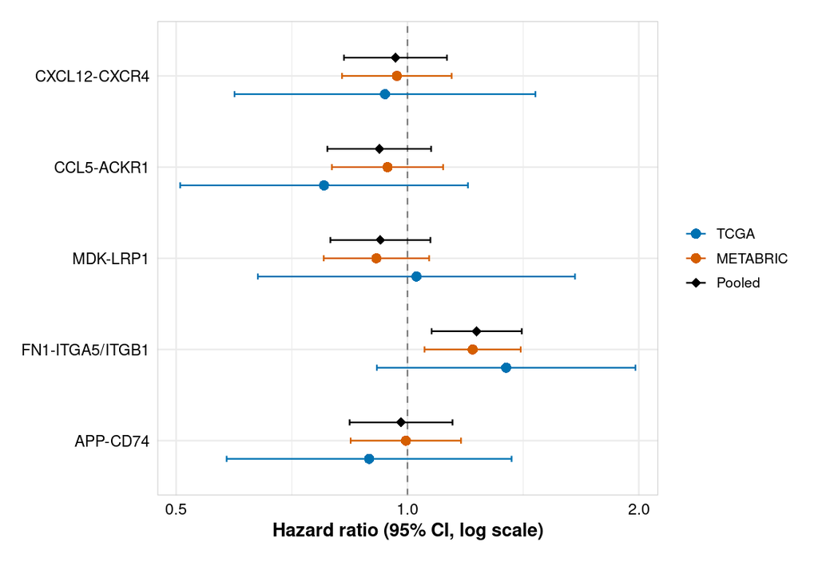

Figure 84: Primary analysis: overall survival of double-high against all other tumors, adjusted for age, stage and PAM50. Hazard ratios with 95% CI per cohort and pooled (fixed effect).

```r
forest_df <- bind_rows(
  primary_cohort %>% transmute(axis_id, source = cohort, hr, lo, hi),
  primary_pooled %>% transmute(axis_id, source = "Pooled", hr = hr_fe, lo = lo_fe, hi = hi_fe)
) %>%
  mutate(
    Axis = factor(axis_labels[axis_id], levels = rev(axis_labels)),
    source = factor(source, levels = c("TCGA", "METABRIC", "Pooled"))
  )

p_forest_primary <- ggplot(forest_df, aes(x = hr, y = Axis, color = source, shape = source)) +
  geom_vline(xintercept = 1, linetype = "dashed", color = "grey50") +
  geom_errorbar(aes(xmin = lo, xmax = hi), width = 0.2, orientation = "y", position = position_dodge(width = 0.6)) +
  geom_point(size = 3, position = position_dodge(width = 0.6)) +
  scale_color_manual(values = cohort_colors) +
  scale_shape_manual(values = c("TCGA" = 16, "METABRIC" = 16, "Pooled" = 18)) +
  scale_x_log10() +
  labs(x = "Hazard ratio (95% CI, log scale)", y = NULL, color = NULL, shape = NULL) +
  theme_publication()
ggsave("results/revision/fig_survival_primary_forest.png", p_forest_primary, width = 8, height = 5.5, dpi = 300)
p_forest_primary
```

The exposure terms satisfy proportional hazards in every primary model (all p above 0.2), so the 10-year censoring follow-up was not needed. The global test fails in METABRIC, which comes from the covariates: the effects of subtype and age are known to vary over follow-up in this cohort. As a check, we stratify the baseline hazard by PAM50 instead of adjusting for it.

```r
zph_covars <- lapply(names(cohort_data), function(coh) {
  fit <- coxph(as.formula(paste("Surv(os_time, os_stat) ~ dh_fn1_itga5_itgb1 +", primary_covars)), data = cohort_data[[coh]])
  data.frame(cohort = coh, term = rownames(cox.zph(fit)$table), p = cox.zph(fit)$table[, "p"])
})
knitr::kable(bind_rows(zph_covars), digits = 4, caption = "cox.zph by term, FN1-ITGA5/ITGB1 primary model")
```

cox.zph by term, FN1-ITGA5/ITGB1 primary model

|  | cohort | term | p |
| --- | --- | --- | --- |
| dh_fn1_itga5_itgb1…1 | TCGA | dh_fn1_itga5_itgb1 | 0.6530 |
| age…2 | TCGA | age | 0.8329 |
| stage…3 | TCGA | stage | 0.0711 |
| pam50…4 | TCGA | pam50 | 0.4044 |
| GLOBAL…5 | TCGA | GLOBAL | 0.0482 |
| dh_fn1_itga5_itgb1…6 | METABRIC | dh_fn1_itga5_itgb1 | 0.4330 |
| age…7 | METABRIC | age | 0.0000 |
| stage…8 | METABRIC | stage | 0.0000 |
| pam50…9 | METABRIC | pam50 | 0.0000 |
| GLOBAL…10 | METABRIC | GLOBAL | 0.0000 |

```r
strat_rows <- list()
for (ax in candidate_registry$axis_id) {
  for (coh in names(cohort_data)) {
    term <- paste0("dh_", ax)
    strat_rows[[length(strat_rows) + 1]] <- cox_term(
      cohort_data[[coh]] %>% filter(!is.na(pam50)), "os_time", "os_stat", paste(term, "+ age + stage + strata(pam50)"), term, zph = TRUE
    ) %>% mutate(axis_id = ax, cohort = coh)
  }
}
strat_cohort <- bind_rows(strat_rows)
strat_pooled <- strat_cohort %>%
  group_by(axis_id) %>%
  group_modify(~ pool_iv(.x$b, .x$se)) %>%
  ungroup() %>%
  mutate(q_bh = p.adjust(p_fe, method = "BH"))
write_csv(strat_pooled, "results/revision/survival_primary_pam50_stratified.csv")
knitr::kable(
  strat_pooled %>% transmute(Axis = axis_labels[axis_id], `Pooled HR (95% CI)` = fmt_hr(hr_fe, lo_fe, hi_fe), p = signif(p_fe, 3), q = signif(q_bh, 3)),
  caption = "Post-hoc sensitivity: Cox model stratified by PAM50 subtype (age and stage adjusted)"
)
```

Post-hoc sensitivity: Cox model stratified by PAM50 subtype (age and stage adjusted)

| Axis | Pooled HR (95% CI) | p | q |
| --- | --- | --- | --- |
| APP-CD74 | 0.99 (0.85-1.15) | 0.86200 | 0.9040 |
| CCL5-ACKR1 | 0.93 (0.79-1.08) | 0.34800 | 0.5790 |
| CXCL12-CXCR4 | 0.99 (0.85-1.16) | 0.90400 | 0.9040 |
| FN1-ITGA5/ITGB1 | 1.21 (1.05-1.38) | 0.00692 | 0.0346 |
| MDK-LRP1 | 0.92 (0.79-1.07) | 0.29100 | 0.5790 |

This model gives 1.21 (1.05-1.38) for FN1-ITGA5/ITGB1 (q = 0.035). We report it as an additional analysis, because the proportional-hazards check prompted it.

Missing stage and PAM50 calls cost patients: multiple imputation (`mice`, 20 imputations, seed 42) of stage and PAM50 recovers 118 TCGA patients, mostly with unclassified PAM50, and 517 METABRIC patients, mostly with missing stage. The imputation model uses age, the five double-high indicators, the event indicator and the Nelson-Aalen cumulative hazard, plus auxiliary staging variables (METABRIC: tumor size, positive lymph nodes, grade, ER and HER2 status; TCGA: pathological T, N and M), with Rubin’s rules within each cohort followed by pooling.

```r
mi_path <- "objects/revision/mi_imputations.qs2"
dh_cols <- paste0("dh_", candidate_registry$axis_id)

if (file.exists(mi_path)) {
  mi_list <- qs_read(mi_path)
} else {
  # Nelson-Aalen cumulative hazard and the event indicator stand in for the outcome (White & Royston 2009)
  mi_input <- list(
    TCGA = tcga_rev %>%
      filter(!is.na(os_time), !is.na(os_stat)) %>%
      select(os_time, os_stat, age, stage, pam50, t_cat, n_cat, m_cat, all_of(dh_cols)),
    METABRIC = meta_rev %>%
      filter(!is.na(os_time), !is.na(os_stat)) %>%
      select(os_time, os_stat, age, stage, pam50, tumour_size, nodes_pos, grade, er, her2, all_of(dh_cols))
  )
  mi_list <- lapply(mi_input, function(df) {
    df$na_haz <- nelsonaalen(df, os_time, os_stat)
    pred <- make.predictorMatrix(df)
    pred[, "os_time"] <- 0
    mice(df, m = 20, maxit = 10, seed = 42, predictorMatrix = pred, printFlag = FALSE)
  })
  qs_save(mi_list, mi_path)
}

mi_rows <- list()
for (ax in candidate_registry$axis_id) {
  for (coh in names(mi_list)) {
    f <- as.formula(sprintf("Surv(os_time, os_stat) ~ dh_%s + %s", ax, primary_covars))
    fits <- lapply(seq_len(mi_list[[coh]]$m), function(j) coxph(f, data = complete(mi_list[[coh]], j)))
    pooled_fit <- summary(pool(as.mira(fits)))
    row <- pooled_fit[pooled_fit$term == paste0("dh_", ax), ]
    mi_rows[[length(mi_rows) + 1]] <- data.frame(axis_id = ax, cohort = coh, n = nrow(mi_list[[coh]]$data),
                                                 b = row$estimate, se = row$std.error)
  }
}
mi_cohort <- bind_rows(mi_rows) %>% mutate(hr = exp(b), lo = exp(b - 1.96 * se), hi = exp(b + 1.96 * se), p = 2 * pnorm(-abs(b / se)))
mi_pooled <- mi_cohort %>%
  group_by(axis_id) %>%
  group_modify(~ pool_iv(.x$b, .x$se)) %>%
  ungroup() %>%
  mutate(q_bh = p.adjust(p_fe, method = "BH"))
write_csv(mi_cohort, "results/revision/survival_mi_by_cohort.csv")
write_csv(mi_pooled, "results/revision/survival_mi_pooled.csv")

knitr::kable(
  mi_cohort %>% transmute(Axis = axis_labels[axis_id], cohort, N = n, `HR (95% CI)` = fmt_hr(hr, lo, hi), p = signif(p, 3)) %>%
    left_join(mi_pooled %>% transmute(Axis = axis_labels[axis_id], `Pooled HR (95% CI)` = fmt_hr(hr_fe, lo_fe, hi_fe),
                                      `Pooled p` = signif(p_fe, 3), q = signif(q_bh, 3)), by = "Axis"),
  caption = "Primary model after multiple imputation of stage and PAM50 (m = 20, Rubin's rules)"
)
```

Primary model after multiple imputation of stage and PAM50 (m = 20, Rubin’s rules)

| Axis | cohort | N | HR (95% CI) | p | Pooled HR (95% CI) | Pooled p | q |
| --- | --- | --- | --- | --- | --- | --- | --- |
| CXCL12-CXCR4 | TCGA | 1080 | 1.00 (0.67-1.49) | 0.99100 | 1.01 (0.89-1.15) | 0.878000 | 0.87800 |
| CXCL12-CXCR4 | METABRIC | 1980 | 1.01 (0.88-1.16) | 0.87400 | 1.01 (0.89-1.15) | 0.878000 | 0.87800 |
| CCL5-ACKR1 | TCGA | 1080 | 0.86 (0.58-1.25) | 0.42200 | 0.97 (0.85-1.10) | 0.632000 | 0.79000 |
| CCL5-ACKR1 | METABRIC | 1980 | 0.98 (0.86-1.13) | 0.82900 | 0.97 (0.85-1.10) | 0.632000 | 0.79000 |
| MDK-LRP1 | TCGA | 1080 | 1.13 (0.75-1.70) | 0.56600 | 0.96 (0.84-1.10) | 0.561000 | 0.79000 |
| MDK-LRP1 | METABRIC | 1980 | 0.94 (0.82-1.09) | 0.41900 | 0.96 (0.84-1.10) | 0.561000 | 0.79000 |
| FN1-ITGA5/ITGB1 | TCGA | 1080 | 1.44 (1.01-2.05) | 0.04210 | 1.23 (1.10-1.38) | 0.000454 | 0.00227 |
| FN1-ITGA5/ITGB1 | METABRIC | 1980 | 1.21 (1.07-1.37) | 0.00267 | 1.23 (1.10-1.38) | 0.000454 | 0.00227 |
| APP-CD74 | TCGA | 1080 | 0.94 (0.64-1.38) | 0.74500 | 1.04 (0.91-1.19) | 0.560000 | 0.79000 |
| APP-CD74 | METABRIC | 1980 | 1.05 (0.92-1.21) | 0.46200 | 1.04 (0.91-1.19) | 0.560000 | 0.79000 |

FN1-ITGA5/ITGB1 stays significant after imputation (pooled 1.23 (1.10-1.38), q = 0.0023), and the other axes stay null.

## Secondary endpoints and subtypes

We then ask whether the primary result extends to other endpoints and to subtypes. These analyses are secondary and exploratory, and each family is corrected on its own with Benjamini-Hochberg.

- **Alternative endpoints (20 tests).** TCGA progression-free and disease-free interval from the TCGA-CDR, and METABRIC disease-specific survival (death from disease is the event, death from other causes is censored) and relapse-free survival, each in the all-patient model.
- **Pooled recurrence endpoint (5 tests).** TCGA progression-free interval pooled with METABRIC relapse-free survival.
- **PAM50 subtype strata (15 tests).** Pooled overall survival in the PAM50 luminal (LumA and LumB), HER2-enriched and basal-like strata, with medians recomputed within the stratum and adjustment for age and stage. In both cohorts subtype is defined by PAM50 only, which reduces the METABRIC luminal stratum to 1,175 patients (888 complete cases). Adding a second subtype classifier would give 1,410 patients.
- **Continuous axis score (5 tests).** The score of an axis, the mean of the log2 ligand and receptor, z-scored within cohort, per standard deviation, with the primary covariates.

```r
endpoint_specs <- tibble::tribble(
  ~cohort, ~endpoint, ~time, ~status,
  "TCGA", "PFI", "pfi_time", "pfi_stat",
  "TCGA", "DFI", "dfi_time", "dfi_stat",
  "METABRIC", "DSS", "dss_time", "dss_stat",
  "METABRIC", "RFS", "rfs_time", "rfs_stat"
)

# S1: alternative endpoints, per cohort (20 tests)
s1_rows <- list()
for (k in seq_len(nrow(endpoint_specs))) {
  for (ax in candidate_registry$axis_id) {
    term <- paste0("dh_", ax)
    s1_rows[[length(s1_rows) + 1]] <- cox_term(
      cohort_data[[endpoint_specs$cohort[k]]], endpoint_specs$time[k], endpoint_specs$status[k],
      paste(term, "+", primary_covars), term, zph = TRUE
    ) %>% mutate(axis_id = ax, cohort = endpoint_specs$cohort[k], endpoint = endpoint_specs$endpoint[k])
  }
}
s1 <- bind_rows(s1_rows) %>% mutate(family = "S1 alternative endpoints", q_bh = p.adjust(p, method = "BH"))

# S2: pooled recurrence endpoint (TCGA PFI + METABRIC RFS)
s2 <- s1 %>%
  filter(endpoint %in% c("PFI", "RFS")) %>%
  group_by(axis_id) %>%
  group_modify(~ pool_iv(.x$b, .x$se)) %>%
  ungroup() %>%
  mutate(family = "S2 pooled PFI/RFS", q_bh = p.adjust(p_fe, method = "BH"))

# S3: PAM50 subtype strata, medians recomputed within stratum, adjusted for age and stage (15 tests)
strata_def <- list(Luminal = c("LumA", "LumB"), HER2 = "Her2", Basal = "Basal")
s3_rows <- list()
for (st in names(strata_def)) {
  for (coh in names(cohort_data)) {
    df_st <- cohort_data[[coh]] %>% filter(pam50 %in% strata_def[[st]])
    for (i in seq_len(nrow(candidate_registry))) {
      ax <- candidate_registry$axis_id[i]
      lig <- df_st[[candidate_registry$ligand[i]]]
      rec <- df_st[[candidate_registry$receptor[i]]]
      df_st$dh_stratum <- as.integer(lig > median(lig, na.rm = TRUE) & rec > median(rec, na.rm = TRUE))
      s3_rows[[length(s3_rows) + 1]] <- cox_term(df_st, "os_time", "os_stat", "dh_stratum + age + stage", "dh_stratum") %>%
        mutate(axis_id = ax, cohort = coh, stratum = st)
    }
  }
}
s3_cohort <- bind_rows(s3_rows)
s3 <- s3_cohort %>%
  group_by(axis_id, stratum) %>%
  group_modify(~ pool_iv(.x$b[.x$estimable], .x$se[.x$estimable])) %>%
  ungroup() %>%
  mutate(family = "S3 subtype strata", q_bh = p.adjust(p_fe, method = "BH"))

# S4: continuous axis score per SD (5 tests)
s4_rows <- list()
for (ax in candidate_registry$axis_id) {
  for (coh in names(cohort_data)) {
    term <- paste0("zs_", ax)
    s4_rows[[length(s4_rows) + 1]] <- cox_term(cohort_data[[coh]], "os_time", "os_stat", paste(term, "+", primary_covars), term, zph = TRUE) %>%
      mutate(axis_id = ax, cohort = coh)
  }
}
s4_cohort <- bind_rows(s4_rows)
s4 <- s4_cohort %>%
  group_by(axis_id) %>%
  group_modify(~ pool_iv(.x$b, .x$se)) %>%
  ungroup() %>%
  mutate(family = "S4 continuous axis score", q_bh = p.adjust(p_fe, method = "BH"))

write_csv(s1, "results/revision/survival_S1_alternative_endpoints.csv")
write_csv(s2, "results/revision/survival_S2_pooled_recurrence.csv")
write_csv(s3_cohort, "results/revision/survival_S3_subtype_by_cohort.csv")
write_csv(s3, "results/revision/survival_S3_subtype_pooled.csv")
write_csv(s4_cohort, "results/revision/survival_S4_continuous_by_cohort.csv")
write_csv(s4, "results/revision/survival_S4_continuous_pooled.csv")

knitr::kable(
  s1 %>% transmute(Axis = axis_labels[axis_id], cohort, endpoint, `HR (95% CI)` = fmt_hr(hr, lo, hi, estimable),
                   p = signif(p, 3), q = signif(q_bh, 3), N = n, events, zph_p = signif(zph_p_term, 3)),
  caption = "S1: alternative endpoints, all patients, primary covariates (BH across 20 tests)"
)
```

S1: alternative endpoints, all patients, primary covariates (BH across 20 tests)

| Axis | cohort | endpoint | HR (95% CI) | p | q | N | events | zph_p |
| --- | --- | --- | --- | --- | --- | --- | --- | --- |
| CXCL12-CXCR4 | TCGA | PFI | 0.90 (0.59-1.39) | 0.63900 | 0.9740 | 962 | 123 | 0.20600 |
| CCL5-ACKR1 | TCGA | PFI | 0.68 (0.44-1.04) | 0.07770 | 0.6160 | 962 | 123 | 0.86000 |
| MDK-LRP1 | TCGA | PFI | 1.10 (0.70-1.72) | 0.69100 | 0.9740 | 962 | 123 | 0.84300 |
| FN1-ITGA5/ITGB1 | TCGA | PFI | 1.32 (0.91-1.93) | 0.14500 | 0.6810 | 962 | 123 | 0.35800 |
| APP-CD74 | TCGA | PFI | 0.86 (0.56-1.30) | 0.47200 | 0.9740 | 962 | 123 | 0.14000 |
| CXCL12-CXCR4 | TCGA | DFI | 0.94 (0.55-1.62) | 0.83300 | 0.9740 | 841 | 70 | 0.23200 |
| CCL5-ACKR1 | TCGA | DFI | 0.62 (0.36-1.08) | 0.09240 | 0.6160 | 841 | 70 | 0.54300 |
| MDK-LRP1 | TCGA | DFI | 0.99 (0.54-1.83) | 0.97400 | 0.9740 | 841 | 70 | 0.85700 |
| FN1-ITGA5/ITGB1 | TCGA | DFI | 1.15 (0.70-1.88) | 0.57900 | 0.9740 | 841 | 70 | 0.63100 |
| APP-CD74 | TCGA | DFI | 0.75 (0.42-1.33) | 0.32400 | 0.9740 | 841 | 70 | 0.31400 |
| CXCL12-CXCR4 | METABRIC | DSS | 1.02 (0.83-1.26) | 0.86000 | 0.9740 | 1462 | 485 | 0.21600 |
| CCL5-ACKR1 | METABRIC | DSS | 0.99 (0.80-1.23) | 0.93200 | 0.9740 | 1462 | 485 | 0.84900 |
| MDK-LRP1 | METABRIC | DSS | 0.99 (0.81-1.21) | 0.90900 | 0.9740 | 1462 | 485 | 0.49300 |
| FN1-ITGA5/ITGB1 | METABRIC | DSS | 1.32 (1.10-1.59) | 0.00268 | 0.0536 | 1462 | 485 | 0.70900 |
| APP-CD74 | METABRIC | DSS | 0.95 (0.77-1.18) | 0.66800 | 0.9740 | 1462 | 485 | 0.54800 |
| CXCL12-CXCR4 | METABRIC | RFS | 1.04 (0.86-1.25) | 0.68800 | 0.9740 | 1462 | 603 | 0.00136 |
| CCL5-ACKR1 | METABRIC | RFS | 1.01 (0.83-1.22) | 0.93800 | 0.9740 | 1462 | 603 | 0.08210 |
| MDK-LRP1 | METABRIC | RFS | 0.93 (0.78-1.12) | 0.43700 | 0.9740 | 1462 | 603 | 0.19400 |
| FN1-ITGA5/ITGB1 | METABRIC | RFS | 1.12 (0.95-1.33) | 0.17000 | 0.6810 | 1462 | 603 | 0.83000 |
| APP-CD74 | METABRIC | RFS | 0.99 (0.82-1.20) | 0.95600 | 0.9740 | 1462 | 603 | 0.03880 |

```r
knitr::kable(
  s2 %>% transmute(Axis = axis_labels[axis_id], `Pooled HR (95% CI)` = fmt_hr(hr_fe, lo_fe, hi_fe), p = signif(p_fe, 3), q = signif(q_bh, 3), I2 = round(i2, 1)),
  caption = "S2: pooled recurrence endpoint (TCGA PFI + METABRIC RFS)"
)
```

S2: pooled recurrence endpoint (TCGA PFI + METABRIC RFS)

| Axis | Pooled HR (95% CI) | p | q | I2 |
| --- | --- | --- | --- | --- |
| APP-CD74 | 0.97 (0.82-1.15) | 0.7290 | 0.853 | 0.0 |
| CCL5-ACKR1 | 0.95 (0.80-1.12) | 0.5280 | 0.853 | 63.2 |
| CXCL12-CXCR4 | 1.02 (0.86-1.20) | 0.8530 | 0.853 | 0.0 |
| FN1-ITGA5/ITGB1 | 1.15 (0.99-1.34) | 0.0656 | 0.328 | 0.0 |
| MDK-LRP1 | 0.95 (0.81-1.13) | 0.5660 | 0.853 | 0.0 |

```r
knitr::kable(
  s3_cohort %>% transmute(Axis = axis_labels[axis_id], stratum, cohort, `HR (95% CI)` = fmt_hr(hr, lo, hi, estimable), p = signif(p, 3), N = n, events),
  caption = "S3: subtype strata by cohort (PAM50 only)"
)
```

S3: subtype strata by cohort (PAM50 only)

| Axis | stratum | cohort | HR (95% CI) | p | N | events |
| --- | --- | --- | --- | --- | --- | --- |
| CXCL12-CXCR4 | Luminal | TCGA | 1.26 (0.77-2.04) | 0.3530 | 682 | 82 |
| CCL5-ACKR1 | Luminal | TCGA | 0.58 (0.35-0.99) | 0.0459 | 682 | 82 |
| MDK-LRP1 | Luminal | TCGA | 0.73 (0.42-1.27) | 0.2630 | 682 | 82 |
| FN1-ITGA5/ITGB1 | Luminal | TCGA | 1.72 (1.08-2.76) | 0.0232 | 682 | 82 |
| APP-CD74 | Luminal | TCGA | 0.67 (0.40-1.14) | 0.1410 | 682 | 82 |
| CXCL12-CXCR4 | Luminal | METABRIC | 1.02 (0.84-1.24) | 0.8090 | 888 | 505 |
| CCL5-ACKR1 | Luminal | METABRIC | 0.84 (0.70-1.02) | 0.0807 | 888 | 505 |
| MDK-LRP1 | Luminal | METABRIC | 0.95 (0.78-1.16) | 0.6220 | 888 | 505 |
| FN1-ITGA5/ITGB1 | Luminal | METABRIC | 1.13 (0.94-1.36) | 0.1980 | 888 | 505 |
| APP-CD74 | Luminal | METABRIC | 1.04 (0.85-1.27) | 0.7070 | 888 | 505 |
| CXCL12-CXCR4 | HER2 | TCGA | not estimable | 0.9980 | 76 | 15 |
| CCL5-ACKR1 | HER2 | TCGA | 0.85 (0.24-3.03) | 0.8030 | 76 | 15 |
| MDK-LRP1 | HER2 | TCGA | 0.70 (0.19-2.61) | 0.5920 | 76 | 15 |
| FN1-ITGA5/ITGB1 | HER2 | TCGA | 0.89 (0.24-3.39) | 0.8690 | 76 | 15 |
| APP-CD74 | HER2 | TCGA | 0.89 (0.18-4.46) | 0.8910 | 76 | 15 |
| CXCL12-CXCR4 | HER2 | METABRIC | 1.07 (0.70-1.65) | 0.7470 | 148 | 109 |
| CCL5-ACKR1 | HER2 | METABRIC | 0.80 (0.53-1.21) | 0.2850 | 148 | 109 |
| MDK-LRP1 | HER2 | METABRIC | 0.70 (0.44-1.11) | 0.1310 | 148 | 109 |
| FN1-ITGA5/ITGB1 | HER2 | METABRIC | 1.24 (0.82-1.87) | 0.3070 | 148 | 109 |
| APP-CD74 | HER2 | METABRIC | 1.12 (0.71-1.75) | 0.6340 | 148 | 109 |
| CXCL12-CXCR4 | Basal | TCGA | not estimable | 0.4500 | 168 | 21 |
| CCL5-ACKR1 | Basal | TCGA | not estimable | 0.9780 | 168 | 21 |
| MDK-LRP1 | Basal | TCGA | not estimable | 0.6270 | 168 | 21 |
| FN1-ITGA5/ITGB1 | Basal | TCGA | not estimable | 0.5850 | 168 | 21 |
| APP-CD74 | Basal | TCGA | not estimable | 0.6700 | 168 | 21 |
| CXCL12-CXCR4 | Basal | METABRIC | 1.05 (0.63-1.75) | 0.8420 | 144 | 79 |
| CCL5-ACKR1 | Basal | METABRIC | 0.69 (0.39-1.23) | 0.2090 | 144 | 79 |
| MDK-LRP1 | Basal | METABRIC | 0.83 (0.48-1.44) | 0.5160 | 144 | 79 |
| FN1-ITGA5/ITGB1 | Basal | METABRIC | 1.40 (0.87-2.24) | 0.1610 | 144 | 79 |
| APP-CD74 | Basal | METABRIC | 1.31 (0.77-2.25) | 0.3210 | 144 | 79 |

```r
knitr::kable(
  s3 %>% transmute(Axis = axis_labels[axis_id], stratum, k, `Pooled HR (95% CI)` = fmt_hr(hr_fe, lo_fe, hi_fe), p = signif(p_fe, 3), q = signif(q_bh, 3), I2 = round(i2, 1)),
  caption = "S3: pooled subtype strata (BH across 15 tests; non-estimable cohort models excluded from pooling)"
)
```

S3: pooled subtype strata (BH across 15 tests; non-estimable cohort models excluded from pooling)

| Axis | stratum | k | Pooled HR (95% CI) | p | q | I2 |
| --- | --- | --- | --- | --- | --- | --- |
| APP-CD74 | Basal | 1 | 1.31 (0.77-2.25) | 0.3210 | 0.663 | NA |
| APP-CD74 | HER2 | 2 | 1.10 (0.71-1.70) | 0.6740 | 0.842 | 0.0 |
| APP-CD74 | Luminal | 2 | 0.98 (0.82-1.19) | 0.8670 | 0.867 | 56.1 |
| CCL5-ACKR1 | Basal | 1 | 0.69 (0.39-1.23) | 0.2090 | 0.626 | NA |
| CCL5-ACKR1 | HER2 | 2 | 0.80 (0.54-1.19) | 0.2740 | 0.663 | 0.0 |
| CCL5-ACKR1 | Luminal | 2 | 0.81 (0.68-0.97) | 0.0204 | 0.306 | 39.6 |
| CXCL12-CXCR4 | Basal | 1 | 1.05 (0.63-1.75) | 0.8420 | 0.867 | NA |
| CXCL12-CXCR4 | HER2 | 1 | 1.07 (0.70-1.65) | 0.7470 | 0.862 | NA |
| CXCL12-CXCR4 | Luminal | 2 | 1.05 (0.88-1.26) | 0.5700 | 0.777 | 0.0 |
| FN1-ITGA5/ITGB1 | Basal | 1 | 1.40 (0.87-2.24) | 0.1610 | 0.603 | NA |
| FN1-ITGA5/ITGB1 | HER2 | 2 | 1.21 (0.81-1.79) | 0.3540 | 0.663 | 0.0 |
| FN1-ITGA5/ITGB1 | Luminal | 2 | 1.19 (1.01-1.42) | 0.0426 | 0.320 | 63.0 |
| MDK-LRP1 | Basal | 1 | 0.83 (0.48-1.44) | 0.5160 | 0.774 | NA |
| MDK-LRP1 | HER2 | 2 | 0.70 (0.45-1.08) | 0.1090 | 0.545 | 0.0 |
| MDK-LRP1 | Luminal | 2 | 0.92 (0.77-1.11) | 0.4010 | 0.668 | 0.0 |

```r
knitr::kable(
  s4 %>% transmute(Axis = axis_labels[axis_id], `Pooled HR per SD (95% CI)` = fmt_hr(hr_fe, lo_fe, hi_fe), p = signif(p_fe, 3), q = signif(q_bh, 3), I2 = round(i2, 1)),
  caption = "S4: continuous axis score per SD, pooled OS"
)
```

S4: continuous axis score per SD, pooled OS

| Axis | Pooled HR per SD (95% CI) | p | q | I2 |
| --- | --- | --- | --- | --- |
| APP-CD74 | 1.08 (1.01-1.15) | 1.96e-02 | 3.26e-02 | 90.5 |
| CCL5-ACKR1 | 0.88 (0.81-0.94) | 4.76e-04 | 1.19e-03 | 37.5 |
| CXCL12-CXCR4 | 1.02 (0.95-1.09) | 5.45e-01 | 5.45e-01 | 0.0 |
| FN1-ITGA5/ITGB1 | 1.16 (1.08-1.23) | 1.46e-05 | 7.29e-05 | 0.0 |
| MDK-LRP1 | 0.98 (0.92-1.04) | 5.00e-01 | 5.45e-01 | 64.2 |

For FN1-ITGA5/ITGB1, the disease-specific survival association in METABRIC reaches a hazard ratio of 1.32 (1.10-1.59) (q = 0.054), and the pooled recurrence endpoint gives 1.15 (0.99-1.34) (q = 0.33). In the luminal stratum the pooled estimate is 1.19 (1.01-1.42) (nominal p = 0.043, q = 0.32). Nothing else among the alternative endpoints stands out. For CCL5-ACKR1, the dichotomized association is concentrated in luminal tumors (pooled 0.81 (0.68-0.97), nominal p = 0.020, q = 0.31 within the subtype family), and it does not survive correction.

In TCGA basal-like tumors every model is flagged as not estimable. The non-convergence comes from the stage covariate, because there are no deaths among stage I basal-like patients, while the exposure estimate itself is stable. It is kept in `survival_S3_subtype_by_cohort.csv` and not pooled. The TCGA HER2 model for CXCL12-CXCR4 is not estimable because the double-high group has no deaths.

The continuous axis score is more informative than the dichotomy. Per standard deviation, the FN1-ITGA5/ITGB1 score has a pooled hazard ratio of 1.16 (1.08-1.23) (q = 7.3 × 10<sup>-5</sup>, I² = 0%), and the CCL5-ACKR1 score is protective, with 0.88 (0.81-0.94) (q = 0.0012). The CCL5-ACKR1 association is nominally significant in each cohort on its own. APP-CD74 shows a pooled hazard ratio of 1.08 with opposite directions in the two cohorts (I² = 90%), so it is not interpretable.

## Tumor composition and benchmarks

Bulk expression mixes cell types, so an association of an axis with survival could be an association of immune or stromal content with survival. We probed this in several ways, all with the primary covariates and pooled over the two cohorts: adding the ESTIMATE immune and stromal scores and the purity to the model; testing the ligand alone and the receptor alone; and a model of the continuous ligand, receptor and their product. In the interaction model, the CCL5 by ACKR1 term directly tests whether ACKR1 counteracts the protective effect of CCL5, as proposed by Yang and Du (2026), which would appear as an interaction hazard ratio above 1. We also fit the continuous score together with the ESTIMATE covariates, as an additional analysis.

```r
comp_specs <- tibble::tribble(
  ~model, ~rhs_template, ~terms_template,
  "Double-high + ESTIMATE (immune, stromal, purity)", "dh_%1$s + %2$s + z_immune + z_stromal + z_purity", "dh_%1$s",
  "Ligand high only", "hl_%1$s + %2$s", "hl_%1$s",
  "Receptor high only", "hr_%1$s + %2$s", "hr_%1$s",
  "Continuous ligand x receptor", "zl_%1$s * zr_%1$s + %2$s", "zl_%1$s|zr_%1$s|zl_%1$s:zr_%1$s",
  "Continuous axis score + ESTIMATE (post hoc)", "zs_%1$s + %2$s + z_immune + z_stromal + z_purity", "zs_%1$s"
)

comp_rows <- list()
for (k in seq_len(nrow(comp_specs))) {
  for (ax in candidate_registry$axis_id) {
    rhs <- sprintf(comp_specs$rhs_template[k], ax, primary_covars)
    for (term in strsplit(sprintf(comp_specs$terms_template[k], ax), "\\|")[[1]]) {
      for (coh in names(cohort_data)) {
        comp_rows[[length(comp_rows) + 1]] <- cox_term(cohort_data[[coh]], "os_time", "os_stat", rhs, term) %>%
          mutate(model = comp_specs$model[k], axis_id = ax, term = gsub(paste0("_", ax), "", term), cohort = coh)
      }
    }
  }
}
comp_cohort <- bind_rows(comp_rows)
comp_pooled <- comp_cohort %>%
  group_by(model, term, axis_id) %>%
  group_modify(~ pool_iv(.x$b, .x$se)) %>%
  group_by(model, term) %>%
  mutate(q_bh = p.adjust(p_fe, method = "BH")) %>%
  ungroup()
write_csv(comp_cohort, "results/revision/survival_composition_by_cohort.csv")
write_csv(comp_pooled, "results/revision/survival_composition_pooled.csv")

comp_display <- bind_rows(
  primary_pooled %>% mutate(model = "Double-high (primary)", term = "dh"),
  s4 %>% mutate(model = "Continuous axis score (S4)", term = "zs"),
  comp_pooled
) %>%
  transmute(
    Axis = axis_labels[axis_id], Model = model, Term = term,
    `Pooled HR (95% CI)` = fmt_hr(hr_fe, lo_fe, hi_fe), p = signif(p_fe, 3), q = signif(q_bh, 3), I2 = round(i2, 1)
  ) %>%
  arrange(Axis, Model)
write_csv(comp_display, "results/revision/table_composition_models.csv")
knitr::kable(comp_display, caption = "Composition-adjusted, single-gene and continuous interaction models (pooled OS, primary covariates; BH across the five axes within each model and term)")
```

Composition-adjusted, single-gene and continuous interaction models (pooled OS, primary covariates; BH across the five axes within each model and term)

| Axis | Model | Term | Pooled HR (95% CI) | p | q | I2 |
| --- | --- | --- | --- | --- | --- | --- |
| APP-CD74 | Continuous axis score (S4) | zs | 1.08 (1.01-1.15) | 1.96e-02 | 3.26e-02 | 90.5 |
| APP-CD74 | Continuous axis score + ESTIMATE (post hoc) | zs | 1.13 (1.04-1.22) | 2.27e-03 | 3.78e-03 | 85.0 |
| APP-CD74 | Continuous ligand x receptor | zl | 1.09 (1.02-1.17) | 1.58e-02 | 2.63e-02 | 0.0 |
| APP-CD74 | Continuous ligand x receptor | zl:zr | 0.97 (0.91-1.03) | 2.71e-01 | 3.39e-01 | 83.2 |
| APP-CD74 | Continuous ligand x receptor | zr | 0.99 (0.92-1.06) | 7.21e-01 | 8.20e-01 | 89.3 |
| APP-CD74 | Double-high (primary) | dh | 0.98 (0.84-1.14) | 8.06e-01 | 8.06e-01 | 0.0 |
| APP-CD74 | Double-high + ESTIMATE (immune, stromal, purity) | dh | 0.98 (0.84-1.16) | 8.47e-01 | 9.92e-01 | 0.0 |
| APP-CD74 | Ligand high only | hl | 1.10 (0.97-1.26) | 1.45e-01 | 2.42e-01 | 0.0 |
| APP-CD74 | Receptor high only | hr | 0.98 (0.86-1.12) | 7.99e-01 | 7.99e-01 | 86.7 |
| CCL5-ACKR1 | Continuous axis score (S4) | zs | 0.88 (0.81-0.94) | 4.76e-04 | 1.19e-03 | 37.5 |
| CCL5-ACKR1 | Continuous axis score + ESTIMATE (post hoc) | zs | 0.82 (0.74-0.92) | 6.96e-04 | 1.74e-03 | 0.0 |
| CCL5-ACKR1 | Continuous ligand x receptor | zl | 0.94 (0.86-1.02) | 1.34e-01 | 1.34e-01 | 69.1 |
| CCL5-ACKR1 | Continuous ligand x receptor | zl:zr | 1.05 (0.98-1.13) | 1.63e-01 | 2.71e-01 | 0.0 |
| CCL5-ACKR1 | Continuous ligand x receptor | zr | 0.93 (0.85-1.01) | 7.79e-02 | 1.95e-01 | 0.0 |
| CCL5-ACKR1 | Double-high (primary) | dh | 0.92 (0.79-1.07) | 2.86e-01 | 4.81e-01 | 0.0 |
| CCL5-ACKR1 | Double-high + ESTIMATE (immune, stromal, purity) | dh | 1.00 (0.83-1.20) | 9.92e-01 | 9.92e-01 | 0.0 |
| CCL5-ACKR1 | Ligand high only | hl | 0.90 (0.78-1.03) | 1.23e-01 | 2.42e-01 | 84.1 |
| CCL5-ACKR1 | Receptor high only | hr | 0.88 (0.77-1.02) | 9.00e-02 | 2.25e-01 | 0.0 |
| CXCL12-CXCR4 | Continuous axis score (S4) | zs | 1.02 (0.95-1.09) | 5.45e-01 | 5.45e-01 | 0.0 |
| CXCL12-CXCR4 | Continuous axis score + ESTIMATE (post hoc) | zs | 1.03 (0.93-1.14) | 5.61e-01 | 5.61e-01 | 0.0 |
| CXCL12-CXCR4 | Continuous ligand x receptor | zl | 0.90 (0.83-0.98) | 1.33e-02 | 2.63e-02 | 21.0 |
| CXCL12-CXCR4 | Continuous ligand x receptor | zl:zr | 0.95 (0.89-1.00) | 7.07e-02 | 1.77e-01 | 0.0 |
| CXCL12-CXCR4 | Continuous ligand x receptor | zr | 1.09 (1.01-1.18) | 3.21e-02 | 1.61e-01 | 0.0 |
| CXCL12-CXCR4 | Double-high (primary) | dh | 0.96 (0.83-1.13) | 6.47e-01 | 8.06e-01 | 0.0 |
| CXCL12-CXCR4 | Double-high + ESTIMATE (immune, stromal, purity) | dh | 0.97 (0.81-1.15) | 7.22e-01 | 9.92e-01 | 0.0 |
| CXCL12-CXCR4 | Ligand high only | hl | 0.94 (0.81-1.08) | 3.87e-01 | 3.87e-01 | 0.0 |
| CXCL12-CXCR4 | Receptor high only | hr | 1.06 (0.93-1.22) | 3.86e-01 | 5.77e-01 | 0.0 |
| FN1-ITGA5/ITGB1 | Continuous axis score (S4) | zs | 1.16 (1.08-1.23) | 1.46e-05 | 7.29e-05 | 0.0 |
| FN1-ITGA5/ITGB1 | Continuous axis score + ESTIMATE (post hoc) | zs | 1.21 (1.10-1.32) | 3.39e-05 | 1.70e-04 | 0.0 |
| FN1-ITGA5/ITGB1 | Continuous ligand x receptor | zl | 1.13 (1.03-1.24) | 8.55e-03 | 2.63e-02 | 0.0 |
| FN1-ITGA5/ITGB1 | Continuous ligand x receptor | zl:zr | 0.99 (0.94-1.05) | 8.41e-01 | 8.41e-01 | 84.8 |
| FN1-ITGA5/ITGB1 | Continuous ligand x receptor | zr | 1.05 (0.97-1.15) | 2.36e-01 | 3.93e-01 | 0.0 |
| FN1-ITGA5/ITGB1 | Double-high (primary) | dh | 1.23 (1.08-1.41) | 2.61e-03 | 1.31e-02 | 0.0 |
| FN1-ITGA5/ITGB1 | Double-high + ESTIMATE (immune, stromal, purity) | dh | 1.21 (1.03-1.42) | 2.08e-02 | 1.04e-01 | 0.0 |
| FN1-ITGA5/ITGB1 | Ligand high only | hl | 1.25 (1.10-1.43) | 6.90e-04 | 3.45e-03 | 0.0 |
| FN1-ITGA5/ITGB1 | Receptor high only | hr | 1.26 (1.11-1.44) | 5.60e-04 | 2.80e-03 | 79.9 |
| MDK-LRP1 | Continuous axis score (S4) | zs | 0.98 (0.92-1.04) | 5.00e-01 | 5.45e-01 | 64.2 |
| MDK-LRP1 | Continuous axis score + ESTIMATE (post hoc) | zs | 0.96 (0.90-1.02) | 2.06e-01 | 2.58e-01 | 83.4 |
| MDK-LRP1 | Continuous ligand x receptor | zl | 0.95 (0.89-1.01) | 9.76e-02 | 1.22e-01 | 54.2 |
| MDK-LRP1 | Continuous ligand x receptor | zl:zr | 0.92 (0.87-0.98) | 9.93e-03 | 4.97e-02 | 46.2 |
| MDK-LRP1 | Continuous ligand x receptor | zr | 1.01 (0.94-1.08) | 8.20e-01 | 8.20e-01 | 0.0 |
| MDK-LRP1 | Double-high (primary) | dh | 0.92 (0.79-1.07) | 2.89e-01 | 4.81e-01 | 0.0 |
| MDK-LRP1 | Double-high + ESTIMATE (immune, stromal, purity) | dh | 0.88 (0.75-1.03) | 1.15e-01 | 2.89e-01 | 0.0 |
| MDK-LRP1 | Ligand high only | hl | 0.92 (0.81-1.05) | 2.22e-01 | 2.78e-01 | 0.0 |
| MDK-LRP1 | Receptor high only | hr | 1.05 (0.92-1.20) | 4.61e-01 | 5.77e-01 | 0.0 |

```r
knitr::kable(
  bind_rows(lapply(names(cohort_data), function(coh) {
    d <- cohort_data[[coh]]
    data.frame(cohort = coh,
               r_immune_purity = cor(d$immune_score, d$TumorPurity),
               r_stromal_purity = cor(d$stromal_score, d$TumorPurity),
               r_immune_stromal = cor(d$immune_score, d$stromal_score))
  })),
  digits = 3,
  caption = "Correlation among the ESTIMATE covariates (purity is a monotone transform of immune + stromal)"
)
```

Correlation among the ESTIMATE covariates (purity is a monotone transform of immune + stromal)

| cohort | r_immune_purity | r_stromal_purity | r_immune_stromal |
| --- | --- | --- | --- |
| TCGA | -0.909 | -0.821 | 0.547 |
| METABRIC | -0.928 | -0.852 | 0.611 |

For FN1-ITGA5/ITGB1, adjustment for composition leaves the point estimate nearly unchanged and widens the interval: 1.23 (1.08-1.41) becomes 1.21 (1.03-1.42), with q = 0.10. The three ESTIMATE covariates are strongly collinear (see the table), so the adjusted model has less information. For CCL5-ACKR1, adjustment absorbs the dichotomized association (1.00 (0.83-1.20)). The continuous score tells a different story. After the same adjustment its hazard ratio per standard deviation is 0.82 (0.74-0.92) for CCL5-ACKR1 and 1.21 (1.10-1.32) for FN1-ITGA5/ITGB1. A reading that fits both results is that the median split mostly captures “immune-infiltrated or not”, whereas the graded CCL5-ACKR1 level carries prognostic information beyond bulk immune and stromal content. Because that model is an additional analysis, it supports the claim and does not establish it.

For FN1-ITGA5/ITGB1, FN1 alone and ITGA5/ITGB1 alone are each about as prognostic as the pair, and in the interaction model the FN1 main effect carries the signal while the interaction term is null. The bulk signal therefore marks a fibronectin-rich stromal and vascular state. It does not show that the pairing of ligand and receptor is prognostic, because the receptor adds no information beyond the ligand. The single-cell analysis supplies the cellular specificity that bulk data cannot. For CCL5-ACKR1, the interaction hazard ratio is 1.05 (0.98-1.13) (p = 0.16), with the same direction in both cohorts. That is directionally compatible with a modest attenuation of the CCL5 effect at high ACKR1, but gives no significant evidence for antagonism. Both main effects are protective, and the joint high state is not adverse.

Finally, we ask how unusual the FN1-ITGA5/ITGB1 association is. We compare the pooled log hazard ratio of each axis with two null distributions: 1,000 random gene pairs per axis, with each gene matched to the corresponding axis gene within 2.5 percentiles of mean expression (averaged over the cohorts, among genes measured in both; for `ITGA5_ITGB1` the mean of two matched genes), and every other unique ligand-receptor pair of the consensus set that is measurable in both cohorts. The empirical p-value is two-sided, (1 + the number of null values at least as extreme) over (N + 1), with seed 42.

```r
bench_path <- "objects/revision/benchmark_null.qs2"

# Log2 expression with harmonized symbols; samples aligned to the clinical rows
mat_tcga_log <- log2(qs_read("objects/phase2/mat_tcga.qs2")[, tcga_rev$sampleId] + 1)
rownames(mat_tcga_log)[rownames(mat_tcga_log) == "DARC"] <- "ACKR1"
rownames(mat_tcga_log)[rownames(mat_tcga_log) == "IL8"] <- "CXCL8"
mat_meta_log <- qs_read("objects/phase2/mat_meta.qs2")[, meta_rev$sampleId]
shared_genes <- intersect(rownames(mat_tcga_log), rownames(mat_meta_log))
bench_mats <- list(TCGA = mat_tcga_log[shared_genes, ], METABRIC = mat_meta_log[shared_genes, ])
bench_base <- lapply(cohort_data, function(d) d %>% select(os_time, os_stat, age, stage, pam50))

pair_log_hr <- function(lig_genes, rec_genes) {
  per_cohort <- lapply(names(bench_mats), function(coh) {
    m <- bench_mats[[coh]]
    lig <- colMeans(m[lig_genes, , drop = FALSE])
    rec <- colMeans(m[rec_genes, , drop = FALSE])
    d <- bench_base[[coh]]
    d$dh <- as.integer(lig > median(lig, na.rm = TRUE) & rec > median(rec, na.rm = TRUE))
    fit <- coxph(Surv(os_time, os_stat) ~ dh + age + stage + pam50, data = d)
    c(b = unname(coef(fit)["dh"]), se = unname(sqrt(vcov(fit)["dh", "dh"])))
  })
  b <- sapply(per_cohort, `[`, "b")
  se <- sapply(per_cohort, `[`, "se")
  sum(b / se^2) / sum(1 / se^2)
}

if (file.exists(bench_path)) {
  bench <- qs_read(bench_path)
} else {
  mean_pct <- rowMeans(sapply(bench_mats, function(m) dplyr::percent_rank(rowMeans(m, na.rm = TRUE))))
  names(mean_pct) <- shared_genes
  axis_genes <- unique(c(candidate_registry$ligand, "ITGA5", "ITGB1", "CCL5", "ACKR1", "CXCR4", "LRP1", "CD74"))
  matched_pool <- function(gene) {
    pool <- names(mean_pct)[abs(mean_pct - mean_pct[gene]) <= 0.025]
    setdiff(pool, axis_genes)
  }

  set.seed(42)
  random_draws <- list()
  for (i in seq_len(nrow(candidate_registry))) {
    rec_genes <- strsplit(candidate_registry$receptor[i], "_")[[1]]
    lig_pool <- matched_pool(candidate_registry$ligand[i])
    rec_pools <- lapply(setNames(rec_genes, rec_genes), matched_pool)
    random_draws[[candidate_registry$axis_id[i]]] <- lapply(seq_len(1000), function(j) {
      lig <- sample(lig_pool, 1)
      rec <- vapply(rec_genes, function(g) sample(setdiff(rec_pools[[g]], lig), 1), character(1))
      list(lig = lig, rec = rec)
    })
  }

  random_null <- lapply(names(random_draws), function(ax) {
    b <- unlist(parallel::mclapply(random_draws[[ax]], function(dr) pair_log_hr(dr$lig, dr$rec), mc.cores = num_cores))
    data.frame(axis_id = ax, draw = seq_along(b), b = b)
  }) %>% bind_rows()

  cons <- read_csv("results/cross_cohort_comparison/consensus_interactions_all.csv", show_col_types = FALSE)
  axis_pairs <- paste(candidate_registry$ligand, candidate_registry$receptor)
  conserved_pairs <- cons %>%
    distinct(Ligand, Receptor) %>%
    filter(!paste(Ligand, Receptor) %in% axis_pairs) %>%
    rowwise() %>%
    filter(all(c(strsplit(Ligand, "_")[[1]], strsplit(Receptor, "_")[[1]]) %in% shared_genes)) %>%
    ungroup()
  conserved_null <- conserved_pairs %>%
    mutate(b = unlist(parallel::mclapply(seq_len(n()), function(j) {
      pair_log_hr(strsplit(Ligand[j], "_")[[1]], strsplit(Receptor[j], "_")[[1]])
    }, mc.cores = num_cores)))

  bench <- list(random_null = random_null, conserved_null = conserved_null, n_conserved_total = nrow(distinct(cons, Ligand, Receptor)))
  qs_save(bench, bench_path)
}

bench_summary <- primary_pooled %>%
  select(axis_id, b_obs = b_fe) %>%
  rowwise() %>%
  mutate(
    random_n = sum(bench$random_null$axis_id == axis_id),
    random_emp_p = (1 + sum(abs(bench$random_null$b[bench$random_null$axis_id == axis_id]) >= abs(b_obs))) / (random_n + 1),
    random_pct_signed = mean(bench$random_null$b[bench$random_null$axis_id == axis_id] < b_obs),
    conserved_n = nrow(bench$conserved_null),
    conserved_emp_p = (1 + sum(abs(bench$conserved_null$b) >= abs(b_obs))) / (conserved_n + 1),
    conserved_pct_signed = mean(bench$conserved_null$b < b_obs)
  ) %>%
  ungroup() %>%
  mutate(hr_obs = exp(b_obs))
write_csv(bench_summary, "results/revision/benchmark_empirical_p.csv")
write_csv(bench$conserved_null %>% mutate(hr = exp(b)) %>% arrange(desc(abs(b))), "results/revision/benchmark_conserved_pairs.csv")
knitr::kable(
  bench_summary %>% transmute(Axis = axis_labels[axis_id], `Observed pooled HR` = round(hr_obs, 3),
                              `Random pairs (n)` = random_n, `Empirical p (random)` = signif(random_emp_p, 3),
                              `Percentile vs random` = round(100 * random_pct_signed, 1),
                              `Conserved pairs (n)` = conserved_n, `Empirical p (conserved)` = signif(conserved_emp_p, 3),
                              `Percentile vs conserved` = round(100 * conserved_pct_signed, 1)),
  caption = "Benchmarks of the primary pooled log HR against expression-matched random gene pairs and the other conserved consensus pairs (two-sided empirical p)"
)
```

Benchmarks of the primary pooled log HR against expression-matched random gene pairs and the other conserved consensus pairs (two-sided empirical p)

| Axis | Observed pooled HR | Random pairs (n) | Empirical p (random) | Percentile vs random | Conserved pairs (n) | Empirical p (conserved) | Percentile vs conserved |
| --- | --- | --- | --- | --- | --- | --- | --- |
| APP-CD74 | 0.981 | 1000 | 0.853 | 31.5 | 89 | 0.8560 | 28.1 |
| CCL5-ACKR1 | 0.919 | 1000 | 0.396 | 15.2 | 89 | 0.4670 | 13.5 |
| CXCL12-CXCR4 | 0.965 | 1000 | 0.704 | 25.8 | 89 | 0.7670 | 24.7 |
| FN1-ITGA5/ITGB1 | 1.231 | 1000 | 0.042 | 96.8 | 89 | 0.0556 | 95.5 |
| MDK-LRP1 | 0.922 | 1000 | 0.427 | 14.8 | 89 | 0.4670 | 13.5 |

FN1-ITGA5/ITGB1 exceeds 96.8% of the expression-matched random pairs (empirical p = 0.042) and 95.5% of the 89 other conserved consensus pairs (empirical p = 0.056). The four conserved pairs with larger hazard ratios are stromal matrix pairs, SPP1-ITGA5/ITGB1, COL4A1-SDC1, SPP1-ITGAV/ITGB5 and FN1-SDC1, which again points to a shared fibronectin and matrix state and not to a unique pair. CCL5-ACKR1 sits at the 15th percentile of the random pairs for the dichotomized model (empirical p = 0.40) (Figure 85).

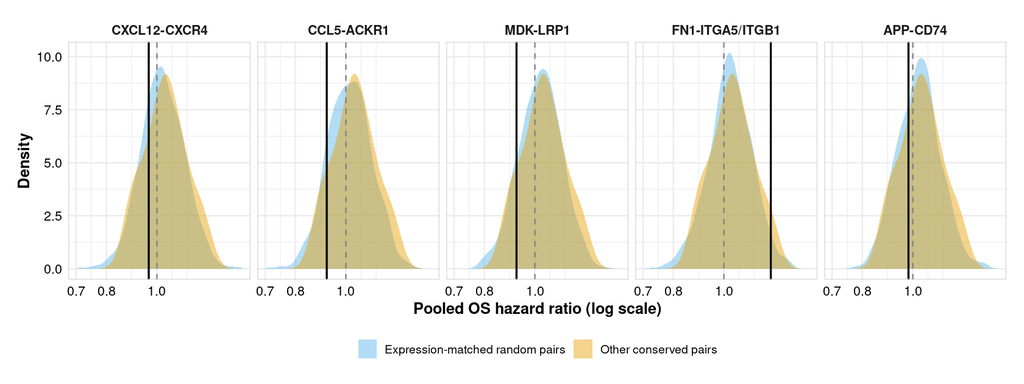

Figure 85: Pooled hazard ratio of each axis (vertical line) against expression-matched random gene pairs and the other conserved consensus pairs.

```r
null_plot_df <- bind_rows(
  bench$random_null %>% transmute(axis_id, null = "Expression-matched random pairs", hr = exp(b)),
  tidyr::crossing(axis_id = candidate_registry$axis_id, bench$conserved_null %>% transmute(null = "Other conserved pairs", hr = exp(b)))
) %>% mutate(Axis = factor(axis_labels[axis_id], levels = axis_labels))
p_null <- ggplot(null_plot_df, aes(x = hr, fill = null)) +
  geom_density(alpha = 0.45, color = NA) +
  geom_vline(data = bench_summary %>% mutate(Axis = factor(axis_labels[axis_id], levels = axis_labels)),
             aes(xintercept = hr_obs), linewidth = 0.8) +
  geom_vline(xintercept = 1, linetype = "dashed", color = "grey50") +
  facet_wrap(~Axis, ncol = 5) +
  scale_x_log10() +
  scale_fill_manual(values = c("Expression-matched random pairs" = "#56B4E9", "Other conserved pairs" = "#E69F00")) +
  labs(x = "Pooled OS hazard ratio (log scale)", y = "Density", fill = NULL) +
  theme_publication() +
  theme(legend.position = "bottom")
ggsave("results/revision/fig_benchmark_null.png", p_null, width = 12, height = 4.5, dpi = 300)
p_null
```

## Replication in SCAN-B

SCAN-B (GEO GSE96058) is a population-based cohort with contemporary treatment. The exposures, covariates and endpoint are those of the primary analysis, and three families of five tests each are corrected with Benjamini-Hochberg. The first family (C1) is the primary double-high model. The second (C2) is the continuous axis score, expected to have a hazard ratio below 1 for CCL5-ACKR1 and above 1 for FN1-ITGA5/ITGB1. The third (C3) is the continuous score plus the ESTIMATE immune and stromal scores and purity, the model that was an additional analysis in TCGA and METABRIC, now tested in an independent cohort. We judge replication on direction and on the confidence interval of each test, and not on significance alone, because one cohort with short follow-up has limited power. Ligand-only and receptor-only models, the luminal stratum and the CCL5 by ACKR1 interaction are exploratory.

SCAN-B does not release a patient identifier or AJCC stage. Records are treated as patients, and a sensitivity analysis removes records that may duplicate a patient (same age, survival time, event and ER, PgR and HER2 status). Stage is replaced by its two released components, tumor size (at most 20, 21 to 50, over 50 mm) and lymph-node status. The analysis set has 3,273 tumors after exclusion of 136 technical replicates (3,153 complete cases, 317 deaths, median follow-up 52 months). Power was computed from the event count with Schoenfeld’s formula, at the two-cohort effect sizes, before any model was fitted.

```r
scanb_path <- "objects/revision/scanb_processed.qs2"

if (file.exists(scanb_path)) {
  scanb_raw <- qs_read(scanb_path)
} else {
  read_geo_characteristics <- function(path) {
    l <- readLines(gzfile(path))
    field <- function(tag) gsub('"', "", strsplit(l[grep(paste0("^!Sample_", tag), l)][1], "\t")[[1]][-1])
    ch <- lapply(l[grep("^!Sample_characteristics_ch1", l)], function(x) gsub('"', "", strsplit(x, "\t")[[1]][-1]))
    out <- as.data.frame(lapply(ch, function(x) trimws(sub("^[^:]*:", "", x))), stringsAsFactors = FALSE)
    names(out) <- make.names(vapply(ch, function(x) sub(":.*", "", x[1]), character(1)))
    data.frame(title = field("title"), gsm = field("geo_accession"), out, stringsAsFactors = FALSE)
  }
  scanb_meta <- bind_rows(
    read_geo_characteristics("data/ext/scanb/GSE96058-GPL11154_series_matrix.txt.gz"),
    read_geo_characteristics("data/ext/scanb/GSE96058-GPL18573_series_matrix.txt.gz")
  ) %>%
    filter(!grepl("repl$", title))

  expr <- fread("data/ext/scanb/GSE96058_gene_expression_3273_samples_and_136_replicates_transformed.csv.gz")
  genes <- expr[[1]]
  scanb_mat <- as.matrix(expr[, -1, with = FALSE])
  rownames(scanb_mat) <- genes
  rm(expr)
  scanb_mat <- scanb_mat[, scanb_meta$title]
  rownames(scanb_mat)[rownames(scanb_mat) == "DARC"] <- "ACKR1"
  rownames(scanb_mat)[rownames(scanb_mat) == "IL8"] <- "CXCL8"

  est <- immunedeconv::deconvolute_estimate(scanb_mat)
  est_df <- as.data.frame(t(est))
  colnames(est_df) <- c("stromal_score", "immune_score", "ESTIMATEScore", "TumorPurity")
  est_df$title <- rownames(est_df)

  axis_gene_cols <- c("CXCL12", "CXCR4", "CCL5", "ACKR1", "MDK", "LRP1", "FN1", "ITGA5", "ITGB1", "APP", "CD74")
  scanb_raw <- list(meta = scanb_meta, est = est_df, axis_expr = as.data.frame(t(scanb_mat[axis_gene_cols, ])), mat = scanb_mat)
  qs_save(scanb_raw, scanb_path)
}

scanb <- scanb_raw$meta %>%
  bind_cols(scanb_raw$axis_expr[scanb_raw$meta$title, ]) %>%
  left_join(scanb_raw$est, by = "title") %>%
  mutate(
    cohort = "SCAN-B",
    ITGA5_ITGB1 = (ITGA5 + ITGB1) / 2,
    age = as.numeric(age.at.diagnosis),
    size_mm = suppressWarnings(as.numeric(tumor.size)),
    size_cat = factor(cut(size_mm, c(-Inf, 20, 50, Inf), labels = c("<=20", "21-50", ">50"))),
    node = factor(na_if(lymph.node.status, "NA"), levels = c("NodeNegative", "NodePositive")),
    pam50 = factor(pam50.subtype, levels = c("LumA", "LumB", "Her2", "Basal", "Normal")),
    os_time = as.numeric(overall.survival.days) / 30.4375,
    os_stat = as.numeric(overall.survival.event),
    dup_key = paste(age.at.diagnosis, overall.survival.days, overall.survival.event, er.status, pgr.status, her2.status),
    possible_duplicate = duplicated(dup_key)
  ) %>%
  add_axis_exposures()

scanb_covars <- "age + size_cat + node + pam50"
scanb_n <- tibble::tibble(
  Metric = c("Tumor samples (replicates excluded)", "OS events", "Median follow-up (months)", "Complete case (age, size, node, PAM50, OS)",
             "Possible duplicate patients (sensitivity)", "PAM50 Luminal (LumA + LumB)"),
  Value = c(nrow(scanb), sum(scanb$os_stat), round(median(scanb$os_time), 1),
            sum(complete.cases(scanb[, c("age", "size_cat", "node", "pam50", "os_time", "os_stat")])),
            sum(scanb$possible_duplicate), sum(scanb$pam50 %in% c("LumA", "LumB")))
)
write_csv(scanb_n, "results/revision/scanb_analysis_set.csv")
knitr::kable(scanb_n %>% mutate(Value = format(Value, big.mark = ",", drop0trailing = TRUE, trim = TRUE)), caption = "SCAN-B (GSE96058) analysis set")
```

SCAN-B (GSE96058) analysis set

| Metric | Value |
| --- | --- |
| Tumor samples (replicates excluded) | 3,273 |
| OS events | 336 |
| Median follow-up (months) | 52.2 |
| Complete case (age, size, node, PAM50, OS) | 3,153 |
| Possible duplicate patients (sensitivity) | 76 |
| PAM50 Luminal (LumA + LumB) | 2,386 |

```r
cc_scanb <- scanb %>% filter(complete.cases(age, size_cat, node, pam50, os_time, os_stat))
d_events <- sum(cc_scanb$os_stat)
two_cohort_events <- sum(primary_cohort$events[primary_cohort$axis_id == "fn1_itga5_itgb1"])
power_two_sided <- function(log_hr, se) pnorm(abs(log_hr) / se - qnorm(0.975)) + pnorm(-abs(log_hr) / se - qnorm(0.975))

dh_prev <- sapply(setNames(candidate_registry$axis_id, candidate_registry$axis_id), function(ax) mean(cc_scanb[[paste0("dh_", ax)]]))
scanb_power <- bind_rows(
  primary_pooled %>% transmute(axis_id, test = "C1 double-high", log_hr = b_fe,
                               se = 1 / sqrt(d_events * dh_prev[axis_id] * (1 - dh_prev[axis_id]))),
  s4 %>% transmute(axis_id, test = "C2 continuous", log_hr = b_fe, se = 1 / sqrt(d_events)),
  comp_pooled %>% filter(model == "Continuous axis score + ESTIMATE (post hoc)") %>%
    transmute(axis_id, test = "C3 continuous + ESTIMATE", log_hr = b_fe, se = se_fe * sqrt(two_cohort_events / d_events))
) %>%
  rowwise() %>%
  mutate(assumed_hr = exp(log_hr), expected_se = se, power = power_two_sided(log_hr, se)) %>%
  ungroup()
write_csv(scanb_power, "results/revision/scanb_power.csv")
knitr::kable(
  scanb_power %>% transmute(Axis = axis_labels[axis_id], test, assumed_hr = round(assumed_hr, 3), expected_se = round(expected_se, 3), power = round(power, 2)),
  caption = sprintf("Power in SCAN-B (two-sided alpha 0.05, %d complete-case events) at the two-cohort effect sizes", d_events)
)
```

Power in SCAN-B (two-sided alpha 0.05, 317 complete-case events) at the two-cohort effect sizes

| Axis | test | assumed_hr | expected_se | power |
| --- | --- | --- | --- | --- |
| APP-CD74 | C1 double-high | 0.981 | 0.133 | 0.05 |
| CCL5-ACKR1 | C1 double-high | 0.919 | 0.123 | 0.11 |
| CXCL12-CXCR4 | C1 double-high | 0.965 | 0.126 | 0.06 |
| FN1-ITGA5/ITGB1 | C1 double-high | 1.231 | 0.115 | 0.44 |
| MDK-LRP1 | C1 double-high | 0.922 | 0.130 | 0.10 |
| APP-CD74 | C2 continuous | 1.080 | 0.056 | 0.28 |
| CCL5-ACKR1 | C2 continuous | 0.875 | 0.056 | 0.66 |
| CXCL12-CXCR4 | C2 continuous | 1.022 | 0.056 | 0.07 |
| FN1-ITGA5/ITGB1 | C2 continuous | 1.156 | 0.056 | 0.73 |
| MDK-LRP1 | C2 continuous | 0.979 | 0.056 | 0.07 |
| APP-CD74 | C3 continuous + ESTIMATE | 1.127 | 0.068 | 0.42 |
| CCL5-ACKR1 | C3 continuous + ESTIMATE | 0.825 | 0.098 | 0.50 |
| CXCL12-CXCR4 | C3 continuous + ESTIMATE | 1.030 | 0.088 | 0.06 |
| FN1-ITGA5/ITGB1 | C3 continuous + ESTIMATE | 1.208 | 0.079 | 0.67 |
| MDK-LRP1 | C3 continuous + ESTIMATE | 0.959 | 0.058 | 0.11 |

```r
scanb_specs <- tibble::tribble(
  ~family, ~rhs_template, ~term_template,
  "C1 double-high", "dh_%1$s + %2$s", "dh_%1$s",
  "C2 continuous", "zs_%1$s + %2$s", "zs_%1$s",
  "C3 continuous + ESTIMATE", "zs_%1$s + %2$s + z_immune + z_stromal + z_purity", "zs_%1$s",
  "E ligand high only", "hl_%1$s + %2$s", "hl_%1$s",
  "E receptor high only", "hr_%1$s + %2$s", "hr_%1$s",
  "E ligand x receptor", "zl_%1$s * zr_%1$s + %2$s", "zl_%1$s:zr_%1$s"
)
fit_scanb <- function(df, label) {
  rows <- list()
  for (k in seq_len(nrow(scanb_specs))) {
    for (ax in candidate_registry$axis_id) {
      term <- sprintf(scanb_specs$term_template[k], ax)
      rows[[length(rows) + 1]] <- cox_term(df, "os_time", "os_stat", sprintf(scanb_specs$rhs_template[k], ax, scanb_covars), term, zph = TRUE) %>%
        mutate(family = scanb_specs$family[k], axis_id = ax, analysis = label)
    }
  }
  bind_rows(rows) %>% group_by(family) %>% mutate(q_bh = p.adjust(p, method = "BH")) %>% ungroup()
}
scanb_res <- bind_rows(
  fit_scanb(scanb, "All records"),
  fit_scanb(scanb %>% filter(!possible_duplicate), "Possible duplicates removed")
)

# Exploratory luminal stratum, medians recomputed within the stratum as in S3
scanb_lum <- scanb %>% filter(pam50 %in% c("LumA", "LumB"))
lum_rows <- list()
for (i in seq_len(nrow(candidate_registry))) {
  lig <- scanb_lum[[candidate_registry$ligand[i]]]
  rec <- scanb_lum[[candidate_registry$receptor[i]]]
  scanb_lum$dh_stratum <- as.integer(lig > median(lig) & rec > median(rec))
  lum_rows[[i]] <- cox_term(scanb_lum, "os_time", "os_stat", "dh_stratum + age + size_cat + node", "dh_stratum", zph = TRUE) %>%
    mutate(family = "E luminal double-high", axis_id = candidate_registry$axis_id[i], analysis = "All records")
}
scanb_res <- bind_rows(scanb_res, bind_rows(lum_rows) %>% mutate(q_bh = p.adjust(p, method = "BH")))
write_csv(scanb_res, "results/revision/scanb_validation_models.csv")

knitr::kable(
  scanb_res %>% filter(analysis == "All records") %>%
    transmute(family, Axis = axis_labels[axis_id], `HR (95% CI)` = fmt_hr(hr, lo, hi, estimable), p = signif(p, 3), q = signif(q_bh, 3),
              N = n, events, zph_p = signif(zph_p_term, 2)),
  caption = "SCAN-B validation (OS; age, tumor size, node status and PAM50; BH within each family). C1-C3 are confirmatory; E families are exploratory."
)
```

SCAN-B validation (OS; age, tumor size, node status and PAM50; BH within each family). C1-C3 are confirmatory; E families are exploratory.

| family | Axis | HR (95% CI) | p | q | N | events | zph_p |
| --- | --- | --- | --- | --- | --- | --- | --- |
| C1 double-high | CXCL12-CXCR4 | 1.07 (0.82-1.39) | 0.60900 | 0.7620 | 3153 | 317 | 0.7900 |
| C1 double-high | CCL5-ACKR1 | 0.91 (0.69-1.20) | 0.49900 | 0.7620 | 3153 | 317 | 0.0570 |
| C1 double-high | MDK-LRP1 | 1.01 (0.76-1.35) | 0.93800 | 0.9380 | 3153 | 317 | 0.7400 |
| C1 double-high | FN1-ITGA5/ITGB1 | 1.34 (1.06-1.69) | 0.01300 | 0.0648 | 3153 | 317 | 0.0510 |
| C1 double-high | APP-CD74 | 0.82 (0.63-1.08) | 0.15300 | 0.3820 | 3153 | 317 | 0.5100 |
| C2 continuous | CXCL12-CXCR4 | 1.00 (0.89-1.12) | 0.98400 | 0.9840 | 3153 | 317 | 0.9900 |
| C2 continuous | CCL5-ACKR1 | 0.89 (0.80-0.99) | 0.03020 | 0.0754 | 3153 | 317 | 0.3200 |
| C2 continuous | MDK-LRP1 | 1.03 (0.92-1.14) | 0.61000 | 0.7860 | 3153 | 317 | 0.1500 |
| C2 continuous | FN1-ITGA5/ITGB1 | 1.17 (1.05-1.31) | 0.00465 | 0.0232 | 3153 | 317 | 0.0760 |
| C2 continuous | APP-CD74 | 0.97 (0.87-1.09) | 0.62800 | 0.7860 | 3153 | 317 | 0.4600 |
| C3 continuous + ESTIMATE | CXCL12-CXCR4 | 0.95 (0.79-1.14) | 0.59300 | 0.7410 | 3153 | 317 | 0.9700 |
| C3 continuous + ESTIMATE | CCL5-ACKR1 | 0.89 (0.77-1.02) | 0.09980 | 0.2500 | 3153 | 317 | 0.3500 |
| C3 continuous + ESTIMATE | MDK-LRP1 | 0.95 (0.83-1.08) | 0.43900 | 0.7310 | 3153 | 317 | 0.1500 |
| C3 continuous + ESTIMATE | FN1-ITGA5/ITGB1 | 1.18 (0.98-1.42) | 0.08050 | 0.2500 | 3153 | 317 | 0.0750 |
| C3 continuous + ESTIMATE | APP-CD74 | 0.98 (0.84-1.13) | 0.74200 | 0.7420 | 3153 | 317 | 0.4700 |
| E ligand high only | CXCL12-CXCR4 | 1.00 (0.79-1.28) | 0.96900 | 0.9690 | 3153 | 317 | 0.9300 |
| E ligand high only | CCL5-ACKR1 | 0.91 (0.72-1.15) | 0.43300 | 0.6460 | 3153 | 317 | 0.8000 |
| E ligand high only | MDK-LRP1 | 0.85 (0.68-1.06) | 0.15300 | 0.3830 | 3153 | 317 | 0.4200 |
| E ligand high only | FN1-ITGA5/ITGB1 | 1.23 (0.98-1.54) | 0.07310 | 0.3650 | 3153 | 317 | 0.0760 |
| E ligand high only | APP-CD74 | 0.93 (0.73-1.17) | 0.51700 | 0.6460 | 3153 | 317 | 0.6600 |
| E receptor high only | CXCL12-CXCR4 | 1.18 (0.94-1.49) | 0.15100 | 0.3780 | 3153 | 317 | 0.9900 |
| E receptor high only | CCL5-ACKR1 | 0.88 (0.68-1.15) | 0.36500 | 0.5900 | 3153 | 317 | 0.0570 |
| E receptor high only | MDK-LRP1 | 1.09 (0.86-1.39) | 0.47200 | 0.5900 | 3153 | 317 | 0.5800 |
| E receptor high only | FN1-ITGA5/ITGB1 | 1.26 (1.00-1.59) | 0.04760 | 0.2380 | 3153 | 317 | 0.0033 |
| E receptor high only | APP-CD74 | 0.98 (0.78-1.23) | 0.84800 | 0.8480 | 3153 | 317 | 0.1400 |
| E ligand x receptor | CXCL12-CXCR4 | 0.95 (0.86-1.04) | 0.25800 | 0.6620 | 3153 | 317 | 0.1400 |
| E ligand x receptor | CCL5-ACKR1 | 0.98 (0.89-1.07) | 0.63100 | 0.7890 | 3153 | 317 | 0.1100 |
| E ligand x receptor | MDK-LRP1 | 1.04 (0.95-1.14) | 0.39700 | 0.6620 | 3153 | 317 | 0.5200 |
| E ligand x receptor | FN1-ITGA5/ITGB1 | 1.04 (0.97-1.12) | 0.28900 | 0.6620 | 3153 | 317 | 0.0390 |
| E ligand x receptor | APP-CD74 | 1.00 (0.92-1.09) | 0.97400 | 0.9740 | 3153 | 317 | 0.9900 |
| E luminal double-high | CXCL12-CXCR4 | 1.12 (0.81-1.54) | 0.50400 | 0.6310 | 2315 | 186 | 0.3800 |
| E luminal double-high | CCL5-ACKR1 | 0.81 (0.57-1.16) | 0.24800 | 0.5630 | 2315 | 186 | 0.7100 |
| E luminal double-high | MDK-LRP1 | 1.05 (0.74-1.51) | 0.77600 | 0.7760 | 2315 | 186 | 0.4900 |
| E luminal double-high | FN1-ITGA5/ITGB1 | 1.48 (1.10-1.99) | 0.00995 | 0.0498 | 2315 | 186 | 0.0620 |
| E luminal double-high | APP-CD74 | 0.85 (0.60-1.19) | 0.33800 | 0.5630 | 2315 | 186 | 0.8100 |

```r
knitr::kable(
  scanb_res %>% filter(analysis == "Possible duplicates removed", family %in% c("C1 double-high", "C2 continuous", "C3 continuous + ESTIMATE")) %>%
    transmute(family, Axis = axis_labels[axis_id], `HR (95% CI)` = fmt_hr(hr, lo, hi, estimable), p = signif(p, 3), N = n, events),
  caption = "SCAN-B sensitivity: records that may duplicate a patient removed"
)
```

SCAN-B sensitivity: records that may duplicate a patient removed

| family | Axis | HR (95% CI) | p | N | events |
| --- | --- | --- | --- | --- | --- |
| C1 double-high | CXCL12-CXCR4 | 1.09 (0.84-1.41) | 0.52200 | 3080 | 317 |
| C1 double-high | CCL5-ACKR1 | 0.91 (0.69-1.20) | 0.49800 | 3080 | 317 |
| C1 double-high | MDK-LRP1 | 1.01 (0.75-1.35) | 0.94800 | 3080 | 317 |
| C1 double-high | FN1-ITGA5/ITGB1 | 1.34 (1.06-1.69) | 0.01290 | 3080 | 317 |
| C1 double-high | APP-CD74 | 0.83 (0.63-1.08) | 0.16500 | 3080 | 317 |
| C2 continuous | CXCL12-CXCR4 | 1.00 (0.90-1.12) | 0.98100 | 3080 | 317 |
| C2 continuous | CCL5-ACKR1 | 0.89 (0.80-0.99) | 0.03040 | 3080 | 317 |
| C2 continuous | MDK-LRP1 | 1.03 (0.93-1.14) | 0.59900 | 3080 | 317 |
| C2 continuous | FN1-ITGA5/ITGB1 | 1.17 (1.05-1.31) | 0.00471 | 3080 | 317 |
| C2 continuous | APP-CD74 | 0.97 (0.87-1.09) | 0.63700 | 3080 | 317 |
| C3 continuous + ESTIMATE | CXCL12-CXCR4 | 0.96 (0.80-1.15) | 0.66900 | 3080 | 317 |
| C3 continuous + ESTIMATE | CCL5-ACKR1 | 0.89 (0.77-1.03) | 0.10900 | 3080 | 317 |
| C3 continuous + ESTIMATE | MDK-LRP1 | 0.95 (0.83-1.09) | 0.44700 | 3080 | 317 |
| C3 continuous + ESTIMATE | FN1-ITGA5/ITGB1 | 1.18 (0.98-1.42) | 0.08370 | 3080 | 317 |
| C3 continuous + ESTIMATE | APP-CD74 | 0.98 (0.85-1.13) | 0.77300 | 3080 | 317 |

```r
# Three-cohort pooling for the confirmatory families
two_cohort <- bind_rows(
  primary_cohort %>% mutate(family = "C1 double-high"),
  s4_cohort %>% mutate(family = "C2 continuous"),
  comp_cohort %>% filter(model == "Continuous axis score + ESTIMATE (post hoc)") %>% mutate(family = "C3 continuous + ESTIMATE")
) %>% select(family, axis_id, cohort, b, se, hr, lo, hi, n, events)
three_cohort <- bind_rows(
  two_cohort,
  scanb_res %>% filter(analysis == "All records", family %in% unique(two_cohort$family)) %>% mutate(cohort = "SCAN-B") %>%
    select(family, axis_id, cohort, b, se, hr, lo, hi, n, events)
)
pooled_3 <- three_cohort %>%
  group_by(family, axis_id) %>%
  group_modify(~ pool_iv(.x$b, .x$se) %>% mutate(n_total = sum(.x$n), events_total = sum(.x$events))) %>%
  group_by(family) %>%
  mutate(q_bh = p.adjust(p_fe, method = "BH")) %>%
  ungroup()
write_csv(three_cohort, "results/revision/scanb_three_cohort_inputs.csv")
write_csv(pooled_3, "results/revision/scanb_three_cohort_pooled.csv")
knitr::kable(
  pooled_3 %>% transmute(family, Axis = axis_labels[axis_id], k, N = n_total, events = events_total,
                         `Pooled FE HR (95% CI)` = fmt_hr(hr_fe, lo_fe, hi_fe), p = signif(p_fe, 3), q = signif(q_bh, 3),
                         `RE HR (95% CI)` = fmt_hr(hr_re, lo_re, hi_re), I2 = round(i2, 1)),
  caption = "Three-cohort pooled estimates (TCGA-BRCA, METABRIC, SCAN-B); C3 was post hoc in the first two cohorts"
)
```

Three-cohort pooled estimates (TCGA-BRCA, METABRIC, SCAN-B); C3 was post hoc in the first two cohorts

| family | Axis | k | N | events | Pooled FE HR (95% CI) | p | q | RE HR (95% CI) | I2 |
| --- | --- | --- | --- | --- | --- | --- | --- | --- | --- |
| C1 double-high | APP-CD74 | 3 | 5578 | 1263 | 0.94 (0.82-1.07) | 3.55e-01 | 4.55e-01 | 0.94 (0.81-1.08) | 5.1 |
| C1 double-high | CCL5-ACKR1 | 3 | 5578 | 1263 | 0.92 (0.80-1.05) | 2.07e-01 | 4.55e-01 | 0.92 (0.80-1.05) | 0.0 |
| C1 double-high | CXCL12-CXCR4 | 3 | 5578 | 1263 | 0.99 (0.87-1.13) | 8.93e-01 | 8.93e-01 | 0.99 (0.87-1.13) | 0.0 |
| C1 double-high | FN1-ITGA5/ITGB1 | 3 | 5578 | 1263 | 1.26 (1.12-1.41) | 1.17e-04 | 5.83e-04 | 1.26 (1.12-1.41) | 0.0 |
| C1 double-high | MDK-LRP1 | 3 | 5578 | 1263 | 0.94 (0.82-1.07) | 3.64e-01 | 4.55e-01 | 0.94 (0.82-1.07) | 0.0 |
| C2 continuous | APP-CD74 | 3 | 5578 | 1263 | 1.05 (0.99-1.11) | 7.65e-02 | 1.27e-01 | 0.98 (0.82-1.17) | 86.4 |
| C2 continuous | CCL5-ACKR1 | 3 | 5578 | 1263 | 0.88 (0.83-0.94) | 4.04e-05 | 1.01e-04 | 0.88 (0.83-0.94) | 0.0 |
| C2 continuous | CXCL12-CXCR4 | 3 | 5578 | 1263 | 1.02 (0.96-1.08) | 6.14e-01 | 7.45e-01 | 1.02 (0.96-1.08) | 0.0 |
| C2 continuous | FN1-ITGA5/ITGB1 | 3 | 5578 | 1263 | 1.16 (1.10-1.23) | 2.00e-07 | 1.20e-06 | 1.16 (1.10-1.23) | 0.0 |
| C2 continuous | MDK-LRP1 | 3 | 5578 | 1263 | 0.99 (0.94-1.05) | 7.45e-01 | 7.45e-01 | 0.99 (0.94-1.05) | 0.0 |
| C3 continuous + ESTIMATE | APP-CD74 | 3 | 5578 | 1263 | 1.09 (1.02-1.17) | 1.11e-02 | 1.85e-02 | 1.00 (0.81-1.22) | 81.2 |
| C3 continuous + ESTIMATE | CCL5-ACKR1 | 3 | 5578 | 1263 | 0.85 (0.77-0.92) | 2.22e-04 | 5.55e-04 | 0.85 (0.77-0.92) | 0.0 |
| C3 continuous + ESTIMATE | CXCL12-CXCR4 | 3 | 5578 | 1263 | 1.01 (0.93-1.10) | 8.00e-01 | 8.00e-01 | 1.01 (0.93-1.10) | 0.0 |
| C3 continuous + ESTIMATE | FN1-ITGA5/ITGB1 | 3 | 5578 | 1263 | 1.20 (1.11-1.30) | 7.00e-06 | 3.51e-05 | 1.20 (1.11-1.30) | 0.0 |
| C3 continuous + ESTIMATE | MDK-LRP1 | 3 | 5578 | 1263 | 0.96 (0.90-1.01) | 1.40e-01 | 1.75e-01 | 0.91 (0.79-1.05) | 72.0 |

In SCAN-B alone, FN1-ITGA5/ITGB1 has the direction and size of the primary estimate: the double-high hazard ratio is 1.34 (1.06-1.69) (q = 0.065), and the continuous score has 1.17 (1.05-1.31) per SD (q = 0.023). CCL5-ACKR1 has the expected direction as a continuous score, with 0.89 (0.80-0.99) per SD (nominal p = 0.030, q = 0.075 at 66% power), while the dichotomized all-patient test is null again. The composition-adjusted continuous scores have the expected direction, but neither is significant on its own at 50 to 67% power. Removing possible duplicates changes nothing. The other three axes are null in C1 to C3.

Pooled over the three cohorts (Figure 86), with no heterogeneity, the FN1-ITGA5/ITGB1 association and the continuous CCL5-ACKR1 association hold, including after adjustment for composition, while the dichotomized CCL5-ACKR1 association remains null. The caveat is that the pooled estimate still includes the two cohorts in which the association was first found.

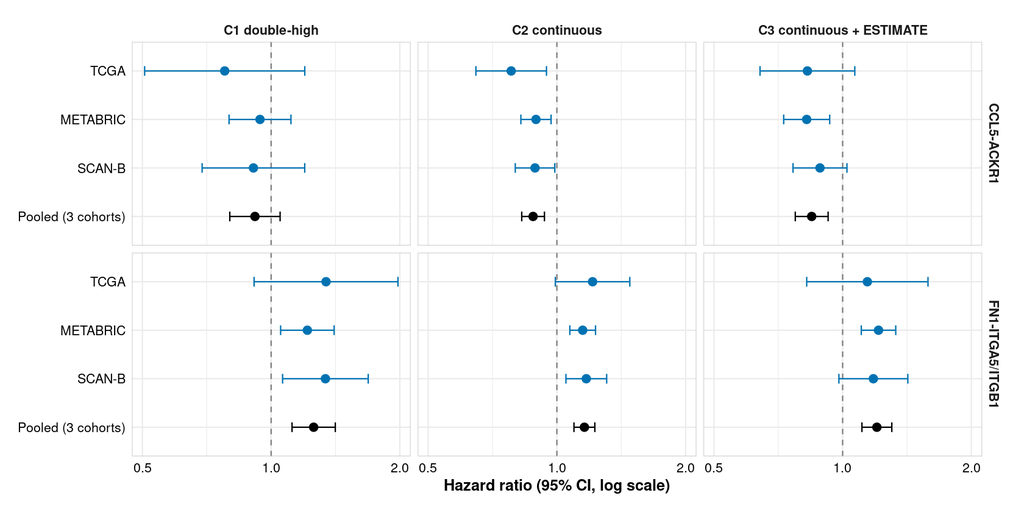

Figure 86: The two lead axes in three independent bulk cohorts (TCGA-BRCA, METABRIC, SCAN-B) and pooled: C1, double-high; C2, continuous score per SD; C3, continuous score adjusted for ESTIMATE composition. Hazard ratios with 95% CI.

```r
forest3 <- bind_rows(
  three_cohort %>% transmute(family, axis_id, source = cohort, hr, lo, hi),
  pooled_3 %>% transmute(family, axis_id, source = "Pooled (3 cohorts)", hr = hr_fe, lo = lo_fe, hi = hi_fe)
) %>%
  filter(axis_id %in% c("ccl5_ackr1", "fn1_itga5_itgb1")) %>%
  mutate(Axis = axis_labels[axis_id], source = factor(source, levels = rev(c("TCGA", "METABRIC", "SCAN-B", "Pooled (3 cohorts)"))))
p_forest3 <- ggplot(forest3, aes(x = hr, y = source, color = source == "Pooled (3 cohorts)")) +
  geom_vline(xintercept = 1, linetype = "dashed", color = "grey50") +
  geom_errorbar(aes(xmin = lo, xmax = hi), width = 0.2, orientation = "y") +
  geom_point(size = 3) +
  facet_grid(Axis ~ family) +
  scale_color_manual(values = c("FALSE" = "#0072B2", "TRUE" = "black"), guide = "none") +
  scale_x_log10() +
  labs(x = "Hazard ratio (95% CI, log scale)", y = NULL) +
  theme_publication()
ggsave("results/revision/fig_scanb_three_cohort_forest.png", p_forest3, width = 12, height = 6, dpi = 300)
p_forest3
```

Table 7: Three-cohort pooled hazard ratios (fixed effect; TCGA-BRCA, METABRIC and SCAN-B, 5,578 patients, 1,263 deaths).

| Test | FN1-ITGA5/ITGB1 | CCL5-ACKR1 |
| --- | --- | --- |
| C1 double-high | 1.26 (1.12-1.41) | 0.92 (0.80-1.05) |
| C2 continuous score per SD | 1.16 (1.10-1.23) | 0.88 (0.83-0.94) |
| C3 continuous plus ESTIMATE | 1.20 (1.11-1.30) | 0.85 (0.77-0.92) |

The APP-CD74 axis reaches q = 0.018 in the pooled C3 family, with I² = 81% and a null random-effects estimate, so it is not interpretable.

## Pathway activity and survival

Do the programs of the receiver cells carry the survival association? For each axis we score two kinds of feature in both bulk cohorts: a NicheNet target-set score, the mean z-score of the union of the top-20 targets from the pseudobulk NicheNet analysis, and the decoupleR activity of the cohort-concordant TFs from the TF tables. Each feature is tested per standard deviation in the primary framework (pooled overall survival, adjusted for age, stage and PAM50), as one Benjamini-Hochberg family.

```r
pathway_path <- "objects/revision/pathway_scores.qs2"
collectri_db <- read.csv("data/decoupler/collectri.csv")

pb_targets <- read_csv("results/revision/pseudobulk_nichenet_top20_targets.csv", show_col_types = FALSE)
target_sets <- lapply(setNames(candidate_registry$axis_id, candidate_registry$axis_id), function(ax) {
  intersect(unique(pb_targets$Gene[pb_targets$axis_id == ax]), shared_genes)
})
concordant_tfs <- lapply(setNames(candidate_registry$axis_id, candidate_registry$axis_id), function(ax) {
  d <- read.csv(file.path(tf_dir, "tables", sprintf("tf_table_%s.csv", ax)))
  d$TF[d$Concordance == "Concordant"]
})

if (file.exists(pathway_path)) {
  pathway_scores <- qs_read(pathway_path)
} else {
  all_tfs <- unique(unlist(concordant_tfs))
  net_sub <- collectri_db %>% filter(source %in% all_tfs)
  pathway_scores <- lapply(names(bench_mats), function(coh) {
    m <- bench_mats[[coh]]
    m[is.na(m)] <- rowMeans(m, na.rm = TRUE)[row(m)[is.na(m)]]
    z <- t(scale(t(m)))
    target_scores <- sapply(target_sets, function(g) colMeans(z[g, , drop = FALSE], na.rm = TRUE))
    tf_act <- decoupleR::run_wmean(mat = m, net = net_sub, .source = "source", .target = "target", .mor = "weight", times = 100, minsize = 5, seed = 42) %>%
      filter(statistic == "norm_wmean") %>%
      select(source, condition, score) %>%
      tidyr::pivot_wider(names_from = source, values_from = score)
    list(targets = target_scores, tf = tf_act[match(colnames(m), tf_act$condition), ])
  })
  names(pathway_scores) <- names(bench_mats)
  qs_save(pathway_scores, pathway_path)
}

pathway_features <- bind_rows(
  tibble::tibble(axis_id = names(target_sets), feature = "NicheNet target-set score", column = paste0("targets_", names(target_sets)),
                 n_genes = lengths(target_sets)),
  bind_rows(lapply(names(concordant_tfs), function(ax) {
    tfs <- intersect(concordant_tfs[[ax]], colnames(pathway_scores$TCGA$tf))
    tibble::tibble(axis_id = rep(ax, length(tfs)), feature = paste("TF activity:", tfs), column = make.names(paste0("tf_", tfs)), n_genes = NA_integer_)
  }))
) %>% distinct(column, .keep_all = TRUE)

path_rows <- list()
for (coh in names(cohort_data)) {
  d <- cohort_data[[coh]]
  ts <- pathway_scores[[coh]]$targets
  colnames(ts) <- paste0("targets_", colnames(ts))
  tf <- pathway_scores[[coh]]$tf %>% select(-condition)
  colnames(tf) <- make.names(paste0("tf_", colnames(tf)))
  d <- bind_cols(d, as.data.frame(scale(ts)), as.data.frame(scale(tf)))
  for (j in seq_len(nrow(pathway_features))) {
    col <- pathway_features$column[j]
    path_rows[[length(path_rows) + 1]] <- cox_term(d, "os_time", "os_stat", paste(col, "+", primary_covars), col) %>%
      mutate(column = col, cohort = coh)
  }
}
path_cohort <- bind_rows(path_rows)
path_pooled <- path_cohort %>%
  group_by(column) %>%
  group_modify(~ pool_iv(.x$b, .x$se)) %>%
  ungroup() %>%
  mutate(q_bh = p.adjust(p_fe, method = "BH")) %>%
  left_join(pathway_features, by = "column")
write_csv(path_cohort, "results/revision/pathway_survival_by_cohort.csv")
write_csv(path_pooled, "results/revision/pathway_survival_pooled.csv")
write_csv(tibble::tibble(axis_id = names(target_sets), genes = vapply(target_sets, paste, character(1), collapse = ", ")),
          "results/revision/pathway_target_sets.csv")
knitr::kable(
  path_pooled %>% transmute(Axis = axis_labels[axis_id], feature, n_genes, `Pooled HR per SD (95% CI)` = fmt_hr(hr_fe, lo_fe, hi_fe),
                            p = signif(p_fe, 3), q = signif(q_bh, 3), I2 = round(i2, 1)) %>% arrange(Axis, p),
  caption = "Pathway and TF activity scores vs OS in the primary framework (per SD, age + stage + PAM50, pooled; BH across all features)"
)
```

Pathway and TF activity scores vs OS in the primary framework (per SD, age + stage + PAM50, pooled; BH across all features)

| Axis | feature | n_genes | Pooled HR per SD (95% CI) | p | q | I2 |
| --- | --- | --- | --- | --- | --- | --- |
| APP-CD74 | TF activity: AIP | NA | 1.16 (1.05-1.28) | 0.00270 | 0.0807 | 0.0 |
| APP-CD74 | TF activity: ZHX2 | NA | 0.91 (0.84-0.97) | 0.00732 | 0.0807 | 0.0 |
| APP-CD74 | TF activity: ZNF24 | NA | 0.94 (0.88-1.01) | 0.08890 | 0.3080 | 0.0 |
| APP-CD74 | TF activity: TBPL2 | NA | 1.06 (0.99-1.13) | 0.11400 | 0.3160 | 0.0 |
| APP-CD74 | TF activity: HOXA13 | NA | 0.97 (0.91-1.04) | 0.41100 | 0.6610 | 0.0 |
| APP-CD74 | TF activity: NR2C1 | NA | 1.02 (0.95-1.09) | 0.57900 | 0.8140 | 63.9 |
| APP-CD74 | TF activity: ASCL2 | NA | 0.99 (0.92-1.05) | 0.66700 | 0.8340 | 0.0 |
| APP-CD74 | TF activity: SUPT20H | NA | 1.01 (0.94-1.08) | 0.80600 | 0.9550 | 59.6 |
| APP-CD74 | NicheNet target-set score | 59 | 1.00 (0.93-1.07) | 0.94200 | 0.9640 | 88.7 |
| CCL5-ACKR1 | TF activity: TSC22D1 | NA | 1.09 (1.02-1.17) | 0.00955 | 0.0807 | 0.0 |
| CCL5-ACKR1 | TF activity: GATA6 | NA | 1.09 (1.02-1.17) | 0.01210 | 0.0807 | 0.0 |
| CCL5-ACKR1 | NicheNet target-set score | 59 | 1.06 (0.99-1.14) | 0.08540 | 0.3080 | 55.8 |
| CCL5-ACKR1 | TF activity: ASCL1 | NA | 0.94 (0.88-1.01) | 0.10600 | 0.3160 | 0.0 |
| CCL5-ACKR1 | TF activity: ARID1A | NA | 1.04 (0.97-1.12) | 0.26400 | 0.5020 | 52.4 |
| CCL5-ACKR1 | TF activity: TCF20 | NA | 1.04 (0.97-1.11) | 0.27900 | 0.5020 | 0.0 |
| CCL5-ACKR1 | TF activity: NCOR1 | NA | 1.03 (0.96-1.11) | 0.37200 | 0.6200 | 58.8 |
| CCL5-ACKR1 | TF activity: CTBP1 | NA | 0.99 (0.92-1.06) | 0.74300 | 0.9040 | 72.0 |
| CCL5-ACKR1 | TF activity: HOXA1 | NA | 1.00 (0.93-1.07) | 0.96400 | 0.9640 | 85.6 |
| CXCL12-CXCR4 | TF activity: PAX5 | NA | 0.93 (0.86-1.00) | 0.05480 | 0.2470 | 74.0 |
| CXCL12-CXCR4 | TF activity: ZMYND8 | NA | 0.95 (0.88-1.01) | 0.11900 | 0.3160 | 0.0 |
| CXCL12-CXCR4 | TF activity: HOXB7 | NA | 1.05 (0.98-1.13) | 0.15800 | 0.3530 | 0.0 |
| CXCL12-CXCR4 | TF activity: HNF1A | NA | 0.96 (0.89-1.02) | 0.19300 | 0.3960 | 20.8 |
| CXCL12-CXCR4 | TF activity: HINFP | NA | 1.04 (0.97-1.11) | 0.27100 | 0.5020 | 0.0 |
| CXCL12-CXCR4 | TF activity: GABPA | NA | 1.02 (0.95-1.10) | 0.61500 | 0.8140 | 80.2 |
| CXCL12-CXCR4 | TF activity: UBTF | NA | 0.99 (0.92-1.05) | 0.66700 | 0.8340 | 76.1 |
| CXCL12-CXCR4 | NicheNet target-set score | 58 | 1.00 (0.93-1.06) | 0.90700 | 0.9640 | 68.8 |
| CXCL12-CXCR4 | TF activity: PHOX2B | NA | 1.00 (0.94-1.06) | 0.96200 | 0.9640 | 0.0 |
| FN1-ITGA5/ITGB1 | TF activity: EBF1 | NA | 0.90 (0.83-0.97) | 0.00842 | 0.0807 | 0.0 |
| FN1-ITGA5/ITGB1 | NicheNet target-set score | 54 | 1.09 (1.02-1.17) | 0.01680 | 0.0946 | 0.0 |
| FN1-ITGA5/ITGB1 | TF activity: NFX1 | NA | 0.94 (0.89-1.01) | 0.07510 | 0.3070 | 0.0 |
| FN1-ITGA5/ITGB1 | TF activity: RORC | NA | 0.95 (0.88-1.02) | 0.12900 | 0.3230 | 0.0 |
| FN1-ITGA5/ITGB1 | TF activity: IRX1 | NA | 1.05 (0.98-1.12) | 0.15200 | 0.3530 | 75.4 |
| FN1-ITGA5/ITGB1 | TF activity: ID2 | NA | 0.95 (0.89-1.02) | 0.16500 | 0.3530 | 0.0 |
| FN1-ITGA5/ITGB1 | TF activity: NAB2 | NA | 1.03 (0.96-1.11) | 0.35400 | 0.6130 | 6.3 |
| FN1-ITGA5/ITGB1 | TF activity: ZFP64 | NA | 0.97 (0.90-1.05) | 0.45800 | 0.6870 | 0.0 |
| FN1-ITGA5/ITGB1 | TF activity: ETV7 | NA | 0.99 (0.92-1.08) | 0.87200 | 0.9640 | 25.6 |
| MDK-LRP1 | TF activity: MTF2 | NA | 1.11 (1.03-1.21) | 0.01020 | 0.0807 | 0.0 |
| MDK-LRP1 | TF activity: ZNF331 | NA | 0.92 (0.86-0.98) | 0.01260 | 0.0807 | 80.2 |
| MDK-LRP1 | TF activity: YBX3 | NA | 1.08 (1.01-1.16) | 0.03460 | 0.1730 | 30.6 |
| MDK-LRP1 | NicheNet target-set score | 58 | 1.06 (0.99-1.13) | 0.10400 | 0.3160 | 0.0 |
| MDK-LRP1 | TF activity: CTBP2 | NA | 1.03 (0.96-1.10) | 0.42900 | 0.6650 | 78.2 |
| MDK-LRP1 | TF activity: USF2 | NA | 1.02 (0.95-1.09) | 0.58800 | 0.8140 | 81.2 |
| MDK-LRP1 | TF activity: RARB | NA | 1.02 (0.95-1.09) | 0.60400 | 0.8140 | 0.0 |
| MDK-LRP1 | TF activity: NFYA | NA | 1.00 (0.93-1.07) | 0.92500 | 0.9640 | 70.5 |
| MDK-LRP1 | TF activity: USF1 | NA | 1.00 (0.93-1.08) | 0.96400 | 0.9640 | 68.9 |

No feature of the 45 passes q below 0.05 (smallest q = 0.081). The FN1-ITGA5/ITGB1 target-set score goes the same way as the axis, with 1.09 (1.02-1.17) per SD (nominal p = 0.017, q = 0.095), and the CCL5-ACKR1 target-set score is null. The FN1-associated receiver program therefore shows a directionally consistent adverse association with overall survival that does not survive correction across the features, so we do not call pathway activities prognostic.

# Tumor microenvironment deconvolution

The survival results raise the question of what the axes track in the tumor microenvironment. We correlate the co-expression score of each axis (the mean of the log2 ligand and receptor) with the four ESTIMATE scores (stromal, immune, ESTIMATE and purity) and with the 22 CIBERSORT LM22 immune subsets, in TCGA-BRCA and METABRIC. The figures show Pearson correlations, and stars mark p below 0.05, 0.01 and 0.001 (Figure 87 and the other tabs of the set).

```r
dir.create("results/clinical", recursive = TRUE, showWarnings = FALSE)

tcga <- tryCatch(qs_read("objects/phase2/clinical_tcga_processed.qs2"), error = function(e) NULL)
meta <- tryCatch(qs_read("objects/phase2/clinical_metabric_processed.qs2"), error = function(e) NULL)

cibersort_celltypes <- c(
  "B cell naive", "B cell memory", "B cell plasma", "T cell CD8+",
  "T cell CD4+ naive", "T cell CD4+ memory resting", "T cell CD4+ memory activated",
  "T cell follicular helper", "T cell regulatory (Tregs)", "T cell gamma delta",
  "NK cell resting", "NK cell activated", "Monocyte", "Macrophage M0",
  "Macrophage M1", "Macrophage M2", "Myeloid dendritic cell resting",
  "Myeloid dendritic cell activated", "Mast cell resting", "Mast cell activated",
  "Eosinophil", "Neutrophil"
)

estimate_scores <- c("stromal_score", "immune_score", "ESTIMATEScore", "TumorPurity")

clean_labels <- c(
  "stromal_score"                  = "Stromal Score",
  "immune_score"                   = "Immune Score",
  "ESTIMATEScore"                  = "ESTIMATE Score",
  "TumorPurity"                    = "Tumor Purity",
  "B cell naive"                   = "Naive B cells",
  "B cell memory"                  = "Memory B cells",
  "B cell plasma"                  = "Plasma cells",
  "T cell CD8+"                    = "CD8+ T cells",
  "T cell CD4+ naive"              = "Naive CD4+ T cells",
  "T cell CD4+ memory resting"     = "Resting CD4+ Memory T cells",
  "T cell CD4+ memory activated"   = "Activated CD4+ Memory T cells",
  "T cell follicular helper"       = "T follicular helper (Tfh)",
  "T cell regulatory (Tregs)"      = "Regulatory T cells (Tregs)",
  "T cell gamma delta"             = "Gamma delta (γδ) T cells",
  "NK cell resting"                = "Resting NK cells",
  "NK cell activated"              = "Activated NK cells",
  "Monocyte"                       = "Monocytes",
  "Macrophage M0"                  = "M0 Macrophages",
  "Macrophage M1"                  = "M1 Macrophages",
  "Macrophage M2"                  = "M2 Macrophages",
  "Myeloid dendritic cell resting" = "Resting Dendritic cells",
  "Myeloid dendritic cell activated" = "Activated Dendritic cells",
  "Mast cell resting"              = "Resting Mast cells",
  "Mast cell activated"            = "Activated Mast cells",
  "Eosinophil"                     = "Eosinophils",
  "Neutrophil"                     = "Neutrophils"
)

lr_pairs <- list(
  cxcl12_cxcr4    = c("CXCL12", "CXCR4"),
  ccl5_ackr1      = c("CCL5", "ACKR1"),
  mdk_lrp1        = c("MDK", "LRP1"),
  fn1_itga5_itgb1 = c("FN1", "ITGA5_ITGB1"),
  app_cd74        = c("APP", "CD74")
)

calc_correlations <- function(df, lig, rec, cohort_name) {
  axis_score <- rowMeans(cbind(df[[lig]], df[[rec]]), na.rm = TRUE)
  target_vars <- c(estimate_scores, cibersort_celltypes)
  cor_list <- list()
  for (v in target_vars) {
    if (!(v %in% colnames(df))) next
    val <- suppressWarnings(as.numeric(df[[v]]))
    valid <- complete.cases(axis_score, val)
    if (sum(valid) < 10) next
    cr <- cor(axis_score[valid], val[valid], method = "pearson")
    pv <- cor.test(axis_score[valid], val[valid])$p.value
    type <- ifelse(v %in% estimate_scores, "ESTIMATE", "CIBERSORT")
    cor_list[[v]] <- data.frame(
      Cohort = cohort_name, Feature = v, Type = type,
      Correlation = cr, PValue = pv, stringsAsFactors = FALSE
    )
  }
  bind_rows(cor_list)
}

all_corrs <- list()
deconv_plots <- list()

for (pair_id in names(lr_pairs)) {
  lig <- lr_pairs[[pair_id]][1]
  rec <- lr_pairs[[pair_id]][2]
  pair_label <- sprintf("%s – %s", lig, rec)

  tcga_corr <- calc_correlations(tcga, lig, rec, "TCGA")
  meta_corr <- calc_correlations(meta, lig, rec, "METABRIC")
  df_corr <- bind_rows(tcga_corr, meta_corr) %>%
    mutate(Feature_Clean = ifelse(Feature %in% names(clean_labels), clean_labels[Feature], Feature))

  all_corrs[[pair_id]] <- df_corr

  df_est <- df_corr %>%
    filter(Type == "ESTIMATE") %>%
    mutate(
      Sig = case_when(
        PValue < 0.001 ~ "***",
        PValue < 0.01  ~ "**",
        PValue < 0.05  ~ "*",
        TRUE ~ ""
      ),
      HJust = ifelse(Correlation >= 0, -0.15, 1.15)
    )

  est_order <- c("Stromal Score", "Immune Score", "ESTIMATE Score", "Tumor Purity")
  df_est$Feature_Factor <- factor(df_est$Feature_Clean, levels = rev(est_order))

  min_est <- min(df_est$Correlation, na.rm = TRUE)
  max_est <- max(df_est$Correlation, na.rm = TRUE)
  y_lim_est <- c(
    min(-1.05, min_est - 0.38),
    max(1.05, max_est + 0.38)
  )

  p_est <- ggplot(df_est, aes(x = Feature_Factor, y = Correlation, fill = Cohort)) +
    geom_bar(stat = "identity", position = position_dodge(0.75), width = 0.65, color = "black", linewidth = 0.35) +
    geom_text(aes(label = sprintf("%.2f%s", Correlation, Sig), hjust = HJust),
              position = position_dodge(0.75),
              size = 3.3, fontface = "bold") +
    geom_hline(yintercept = 0, linetype = "dashed", color = "grey30", linewidth = 0.4) +
    scale_fill_manual(values = c("TCGA" = "#1F77B4", "METABRIC" = "#D95F02")) +
    scale_y_continuous(limits = y_lim_est) +
    coord_flip() +
    theme_publication() +
    labs(x = NULL, y = "Pearson correlation (r)") +
    theme(
      plot.title = element_text(face = "bold", size = 11, hjust = 0),
      axis.text.y = element_text(face = "bold", color = "black", size = 10),
      axis.text.x = element_text(color = "black", size = 9),
      axis.title.x = element_text(face = "bold", size = 10),
      legend.position = "top",
      legend.title = element_text(face = "bold", size = 10)
    )

  top_cib_features <- df_corr %>%
    filter(Type == "CIBERSORT") %>%
    group_by(Feature) %>%
    summarise(mean_abs_r = mean(abs(Correlation))) %>%
    top_n(10, mean_abs_r) %>%
    pull(Feature)

  df_cib <- df_corr %>%
    filter(Type == "CIBERSORT", Feature %in% top_cib_features) %>%
    mutate(
      Sig = case_when(
        PValue < 0.001 ~ "***",
        PValue < 0.01  ~ "**",
        PValue < 0.05  ~ "*",
        TRUE ~ ""
      ),
      HJust = ifelse(Correlation >= 0, -0.15, 1.15)
    )

  ord_features <- df_cib %>%
    filter(Cohort == "TCGA") %>%
    arrange(Correlation) %>%
    pull(Feature_Clean)

  df_cib$Feature_Factor <- factor(df_cib$Feature_Clean, levels = ord_features)

  min_cib <- min(df_cib$Correlation, na.rm = TRUE)
  max_cib <- max(df_cib$Correlation, na.rm = TRUE)
  y_lim_cib <- c(
    min(-0.7, min_cib - 0.22),
    max(0.7, max_cib + 0.22)
  )

  p_cib <- ggplot(df_cib, aes(x = Feature_Factor, y = Correlation, fill = Cohort)) +
    geom_bar(stat = "identity", position = position_dodge(0.75), width = 0.65, color = "black", linewidth = 0.35) +
    geom_text(aes(label = sprintf("%.2f%s", Correlation, Sig), hjust = HJust),
              position = position_dodge(0.75),
              size = 3.0, fontface = "bold") +
    geom_hline(yintercept = 0, linetype = "dashed", color = "grey30", linewidth = 0.4) +
    scale_fill_manual(values = c("TCGA" = "#1F77B4", "METABRIC" = "#D95F02")) +
    scale_y_continuous(limits = y_lim_cib) +
    coord_flip() +
    theme_publication() +
    labs(x = NULL, y = "Pearson correlation (r)") +
    theme(
      plot.title = element_text(face = "bold", size = 11, hjust = 0),
      axis.text.y = element_text(face = "bold", color = "black", size = 10),
      axis.text.x = element_text(color = "black", size = 9),
      axis.title.x = element_text(face = "bold", size = 10),
      legend.position = "top",
      legend.title = element_text(face = "bold", size = 10)
    )

  p_combined <- (p_est + p_cib + plot_layout(widths = c(1, 1.25), guides = "collect") & theme(legend.position = "top")) + plot_annotation(tag_levels = "A")
  deconv_plots[[pair_id]] <- p_combined

  out_png <- sprintf("results/clinical/corr_lr_deconv_%s.png", pair_id)
  ggsave(out_png, plot = p_combined, width = 12, height = 5.5, dpi = 300)
}

write.csv(bind_rows(all_corrs, .id = "axis_id"), "results/clinical/lr_deconv_correlations.csv", row.names = FALSE)
```

````r
fig_tabs(
  c("```{r}",
    "#| label: fig-deconv-{{key}}",
    "#| eval: true",
    "#| fig-cap: \"Correlation of the {{title}} co-expression score with ESTIMATE scores (A) and with the ten CIBERSORT immune subsets that correlate most strongly (B), in TCGA-BRCA and METABRIC. Stars mark p < 0.05, 0.01 and 0.001.\"",
    "#| fig-width: 12",
    "#| fig-height: 5.5",
    "deconv_plots[[\"{{key}}\"]]",
    "```", ""),
  keys = names(lr_pairs),
  titles = axis_labels[names(lr_pairs)]
)
````

**CXCL12-CXCR4**

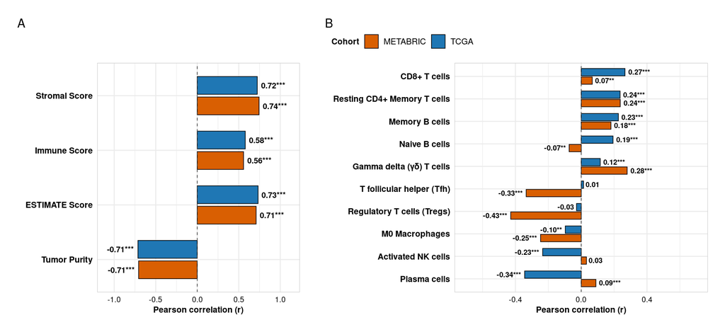

Figure 87: Correlation of the CXCL12-CXCR4 co-expression score with ESTIMATE scores (A) and with the ten CIBERSORT immune subsets that correlate most strongly (B), in TCGA-BRCA and METABRIC. Stars mark p < 0.05, 0.01 and 0.001.

```r
deconv_plots[["cxcl12_cxcr4"]]
```

**CCL5-ACKR1**